# Metaphors We Live By.Lakoff1980

*Purpose:* From birth (and even before), we have needs and desires, and we realize very early that we can perform certain actions (crying, moving, manipulating objects) to satisfy them.

这些是我们经验的一些基本维度。我们用这些维度来对我们的经验进行分类。当我们能够对不同的经验进行分类时，我们就能看到它们之间的*连贯性。*从格式塔的角度来理解它们，至少要考虑这些维度。

These are some of the basic dimensions of our experience. We classify our experiences in such terms. And we see *coherence* in diverse experiences when we can categorize them in terms of gestalts with at least these dimensions.

概念与体验的契合度意味着什么？

What Does It Mean for a Concept to Fit an Experience?

让我们回到对话演变成争论的体验。正如我们所见，对话是一种结构化的体验。当我们经历对话时，我们会自动且无意识地根据自然维度对体验进行分类。的对话的整体框架：谁在参与？轮到谁了？（即哪个部分？）我们处于哪个阶段？等等。正是通过将对话的整体框架应用于正在发生的事情，我们才能将我们参与的说话和倾听体验为一种特殊*的*体验，即对话。当我们感知到我们的体验维度符合战争的整体框架时，我们意识到自己正在参与另一种*体验*，即论证。正是通过这种方式，我们对特定的体验进行分类；我们需要对我们的体验进行分类，才能理解它们，从而知道该怎么做。

Let us return to the experience of being in a conversation that turns into an argument. As we saw, being in a conversation is a structured experience. As we experience a conversation, we are automatically and unconsciously classifying our experience in terms of the natural dimensions of the CONVERSATION gestalt: Who’s participating? Whose turn is it? (= which part?) What stage are we at? And so on. It is in terms of imposing the CONVERSATION gestalt on what is happening that we experience the talking and listening that we engage in as a particular *kind* of experience, namely, a conversation. When we perceive dimensions of our experience as fitting the WAR gestalt in addition, we become aware that we are participating in another *kind* of experience, namely, an argument. It is by this means that we classify particular experiences, and we need to classify our experiences in order to comprehend, so that we will know what to do.

因此，在我们的概念体系中，我们根据经验格式塔对特定经验进行分类。这里我们必须区分：（1）经验（2）它本身，正如我们所构建的那样；（3）我们在构建它时所使用的概念，即像“对话”和“论证”这样的多维整体概念。概念（例如，“对话” ）具体指明了某些自然维度（例如，参与者、组成部分、阶段等）以及这些维度之间的关系。概念“对话”与各个方面之间存在着逐维度的关联。指的是实际的对话活动。这就是我们所说的“概念契合经验”的含义。

Thus we classify particular experiences in terms of experiential gestalts in our conceptual system. Here we must distinguish between: (1) the experience itself, as we structure it, and (2) the concepts that we employ in structuring it, that is, the multidimensional gestalts like CONVERSATION and ARGUMENT. The concept (say, CONVERSATION) specifies certain natural dimensions (e.g., participants, parts, stages, etc.) and how these dimensions are related. There is a correlation, dimension by dimension, between the concept CONVERSATION and the aspects of the actual activity of conversing. This is what we mean when we say that a concept fits an experience.

正是通过这种方式将我们的经验概念化，我们才能从中挑选出“重要”的方面。通过挑选出经验中的“重要”之处，我们就能对经验进行分类、理解和记忆。如果我们告诉你我们有一个争论，昨天，如果我们对“论证”的概念（我们作为参与者）能够逐个维度地契合我们昨天的经历，那么我们所说的就是真话。

It is by means of conceptualizing our experiences in this manner that we pick out the “important” aspects of an experience. And by picking out what is “important” in the experience, we can categorize the experience, understand it, and remember it. If we were to tell you that we had an argument yesterday, we would be telling you the truth if our concept of an ARGUMENT, with us as participants, fits an experience that we had yesterday, dimension by dimension.

隐喻结构与子类别划分

Metaphorical Structuring versus Subcategorization

在讨论“论证”这一概念时，我们一直假设子范畴化之间存在着清晰的区分。以及隐喻结构。一方面，我们采用了“一个论点”。“对话”是次范畴化的一个例子，因为论证本质上是一种*对话*。两者都涉及同一种活动，即说话，而且论证具备对话的所有基本结构特征。因此，我们进行次范畴化的标准是：（*a*）同一种活动；（*b*）足够多的相同结构特征。另一方面，我们以“论证”为例。“战争”之所以可以被视为一种隐喻，是因为争论和战争本质上是两种不同的活动，而“争论”一词的结构部分借鉴了“战争”的概念。争论之所以是一种不同的活动，是因为它涉及对话而非战斗。这种结构是部分性的，因为它只使用了“战争”概念中的部分要素。因此，我们对隐喻的判断标准是：( *a* ) 活动类型的差异（*b*）部分结构化（使用某些选定的部分）。

In our discussion of the concept ARGUMENT, we have been assuming a clear-cut distinction between subcategorization and metaphorical structuring. On the one hand, we took “An argument is a conversation” to be an instance of subcategorization, because an argument is basically a *kind* of conversation. The same kind of activity occurs in both, namely, talking, and an argument has all the basic structural features of a conversation. Thus our criteria for subcategorization were (*a*) same kind of activity and (*b*) enough of the same structural features. On the other hand, we took ARGUMENT IS WAR to be a metaphor because an argument and a war are basically different kinds of activity, and ARGUMENT is partially structured in terms of WAR. Argument is a different kind of activity because it involves talking instead of combat. The structure is partial, because only selected elements of the concept WAR are used. Thus our criteria for metaphor were (*a*) a difference in kind of activity and (*b*) partial structuring (use of certain selected parts).

但我们不能总是仅凭这些标准来区分次范畴化和隐喻。原因在于，两种活动（或两件事物）究竟是同类还是异类，有时并不明确。例如，“争论就是打架”。这究竟是次范畴化还是隐喻？问题的关键在于，打架是否属于同一范畴。争吵和打架是同一种行为。这并非一个简单的问题。打架是为了争夺支配地位，通常涉及伤害、造成疼痛、致残等等。但其中既有身体上的疼痛，也有所谓的心理上的痛苦；既有身体上的优势，也有心理上的优势。如果你认为“打架”的概念包含了心理上的优势和心理上的痛苦，那么……如果将“争论即打架”与身体上的优势和痛苦相提并论，那么你可能会将“争论即打架”视为一种子类别而非比喻，因为两者都涉及心理上的优势。在这种观点下，争论就是一种打架，其形式类似于对话。另一方面，如果你将“打架”理解为纯粹的身体上的，并将心理上的痛苦仅仅视为一种比喻意义上的痛苦，那么你可能会把“争论即打架”看作是一种比喻。

But we cannot always distinguish subcategorization from metaphor on the basis of these criteria. The reason is that it is not always clear when two activities (or two things) are of the same kind or of different kinds. Take, for example, AN ARGUMENT IS A FIGHT. Is this a subcategorization or a metaphor? The issue here is whether fighting and arguing are the same kind of activity. This is not a simple issue. Fighting is an attempt to gain dominance that typically involves hurting, inflicting pain, injuring, etc. But there is both physical pain and what is called psychological pain; there is physical dominance and there is psychological dominance. If your concept FIGHT includes psychological dominance and psychological pain on a par with physical dominance and pain, then you may see AN ARGUMENT IS A FIGHT as a subcategorization rather than a metaphor, since both would involve gaining psychological dominance. On this view an argument would be a kind of fight, structured in the form of a conversation. If, on the other hand, you conceive of FIGHT as purely physical, and if you view psychological pain only as pain taken metaphorically, then you might view AN ARGUMENT IS A FIGHT as metaphorical.

关键在于，子范畴化和隐喻是连续体上的两个端点。例如， *“A*是*B”*（例如，“争论就是打架”）这种关系，如果*A*和*B*是同一类事物或活动，则显然是子范畴化；如果 A 和 B 是明显不同的事物或活动，则显然是隐喻。但是当如果还不清楚*A*和*B*是否是同一种事物或活动，那么*A*是*B*的关系就处于连续体的中间位置。

The point here is that subcategorization and metaphor are endpoints on a continuum. A relationship of the form *A* is *B* (for example, AN ARGUMENT IS A FIGHT) will be a clear subcategorization if *A* and *B* are the same kind of thing or activity and will be a clear metaphor if they are clearly different kinds of things or activities. But when it is not clear whether *A* and *B* are the same kind of thing or activity, then the relationship *A* is *B* falls somewhere in the middle of the continuum.

需要注意的是，第14章概述的理论既适用于清晰的情况，也适用于模糊的情况。模糊的情况将涉及相同类型的结构（具有相同的维度和相同的复杂程度）。*例如，在A*是B 的不明确案例中*，A*和*B*都是构成特定类型活动（或事物）的格式塔，唯一的问题是这些格式塔所构成的活动或事物是否属于同一*类型。*

The important thing to note is that the theory outlined in chapter 14 allows for such unclear cases as well as for the clear ones. The unclear cases will involve the same kinds of structures (with the same dimensions and the same possible complexities) as the clear cases. In an unclear case of the form *A* is *B, A* and *B* will both be gestalts that structure certain kinds of activities (or things), and the only question will be whether the activities or things structured by those gestalts are of the same *kind.*

到目前为止，我们已经从经验格式塔的角度对连贯性进行了描述，这些格式塔具有从经验中自然涌现的各种维度。有些格式塔相对简单（例如“对话”），有些则极其复杂（例如“战争”）。还有一些复杂的格式塔，它们部分地由其他格式塔构成。我们称这些为*隐喻结构的概念。*某些概念几乎完全由隐喻构成。例如，“爱”这个概念主要由隐喻术语构成：爱爱是一段旅程，爱是耐心，爱是一种力量，爱是疯狂，爱是战争，等等。爱的概念核心由“爱是一种情感”这一子类别以及与其他情感（例如喜欢）的联系所构建。这是情感概念的典型特征，它们在我们的经验中并非以任何直接的方式清晰界定，因此必须主要通过其他方式来理解。间接地，通过比喻。

We have so far characterized coherence in terms of experiential gestalts, which have various dimensions that emerge naturally from experience. Some gestalts are relatively simple (CONVERSATION) and some are extremely elaborate (WAR). There are also complex gestalts, which are structured partially in terms of other gestalts. These are what we have been calling *metaphorically structured concepts.* Certain concepts are structured almost entirely metaphorically. The concept LOVE, for example, is structured mostly in metaphorical terms: LOVE IS A JOURNEY, LOVE IS A PATIENT, LOVE IS A PHYSICAL FORCE, LOVE IS MADNESS, LOVE IS WAR, etc. The concept of LOVE has a core that is minimally structured by the subcategorization LOVE IS AN EMOTION and by links to other emotions, e.g., liking. This is typical of emotional concepts, which are not clearly delineated in our experience in any direct fashion and therefore must be comprehended primarily indirectly, via metaphor.

但连贯性不仅仅体现在结构上。多维格式塔。当一个概念由多个隐喻构成时，不同的隐喻结构通常会以一种连贯的方式契合在一起。接下来，我们将探讨连贯性的其他方面，包括单个隐喻结构内部的连贯性以及两个或多个隐喻之间的连贯性。

But there is more to coherence than structuring in terms of multidimensional gestalts. When a concept is structured by more than one metaphor, the different metaphorical structurings usually fit together in a coherent fashion. We will now turn to other aspects of coherence, both within a single metaphorical structuring and across two or more metaphors.

16

16

隐喻连贯性

Metaphorical Coherence

概念的特殊方面

Specialized Aspects of a Concept

到目前为止，我们已经对“论证”这一概念进行了足够详细的探讨，对其整体结构有了大致的了解。与我们许多其他一般概念一样，“论证”这一概念也有一些专门化的方面，用于特定的亚文化或特定情境中。例如，我们看到，在学术界、法律界等等，“论证”这一概念特指“理性论证”，它与日常生活中“非理性”的论证截然不同。在理性论证中，策略理想*情况下*仅限于陈述前提、引用佐证和得出合乎逻辑的结论。然而，正如我们所见，在实践中，日常论证的策略（恐吓、诉诸权威等）也出现在实际的“理性”论证中。一种伪装或精炼的形式。这些额外的限制将理性论证定义为论证这一一般概念的一个专门分支。此外，在理性论证中，论证的目的也受到进一步的限制。在理想情况下，赢得论证的目的被视为服务于理解这一更高层次的目的。

So far we have looked at the concept ARGUMENT in enough detail to get a sense of its general overall structure. As is the case with many of our general concepts, the concept ARGUMENT has specialized aspects that are used in certain subcultures or in certain situations. We saw, for example, that in the academic world, legal world, etc., the concept ARGUMENT is specialized to RATIONAL ARGUMENT, which is distinguished from everyday, “irrational” argument. In RATIONAL ARGUMENT the tactics are *ideally* restricted to stating premises, citing supporting evidence, and drawing logical conclusions. In practice, as we saw, the tactics of everyday argument (intimidation, appeal to authority, etc.) appear in actual “rational” argument in a disguised or refined form. These additional restrictions define RATIONAL ARGUMENT as a specialized branch of the general concept ARGUMENT. Moreover, the purpose of argument is further restricted in the case of RATIONAL ARGUMENT. In the ideal case, the purpose of winning the argument is seen as serving the higher purpose of understanding.

理性论证本身还有更细致的分类。由于书面话语排除了双边论证中固有的对话，一种特殊的单方论证形式应运而生。在这种论证中，口头表达通常转化为书面表达，作者并非面向实际的对手，而是面向一组假想的对手，或是面向那些无法在场进行辩护、反击等的实际对手。我们在这里看到的是……专门概念：单方理性论证。

Within RATIONAL ARGUMENT itself there is a further specialization. Since written discourse rules out the dialogue inherent in two-party arguments, a special form of one-party argument has developed. Here speaking typically becomes writing, and the author addresses himself, not to an actual adversary, but to a set of hypothetical adversaries or to actual adversaries who are not present to defend themselves, counterattack, etc. What we have here is the specialized concept ONE-PARTY RATIONAL ARGUMENT.

最后，论证过程*（*论证本身）与论证结果*（*论证过程中所写或所说的内容）之间存在区别。在这种情况下，过程和结果是同一概念中密切相关的两个方面，二者缺一不可，并且可以分别作为研究的重点。因此，我们谈论论证的阶段时，可以不偏袒过程或结果。

Finally, there is a distinction between an argument as a *process* (arguing) and an argument as a *product* (what has been written or said in the course of arguing). In this case, the process and the product are intimately related aspects of the same general concept, neither of which can exist without the other, and either of which can be focused on. Thus we speak of the stage of an argument as applying indifferently to the process or the product.

单方理性论证是论证这一一般概念的一个特殊分支，因此它受到许多特殊限制。由于没有实际的对手，必须假定存在一个理想化的对手。如果要保持胜利的目的，那么这种胜利必须是战胜一个理想化的对手。理想化的对手并不存在。确保胜利的唯一途径是战胜所有可能的对手，并争取中立方的支持。为此，你必须预见可能出现的反对意见、防御措施、攻击等等，并在构建论证的过程中加以应对。由于这是一个理性论证，所有这些步骤都必须采取，不仅是为了赢得辩论，更是为了最终的胜利。服务于更高层次的理解目的。

A ONE-PARTY RATIONAL ARGUMENT is a specialized branch of the general concept ARGUMENT and, as such, has many special constraints on it. Since there is no particular adversary present, an idealized adversary must be assumed. If the purpose of victory is to be maintained, it must be victory over an idealized adversary who is not present. The only way to guarantee victory is to be able to overcome all possible adversaries and to win neutral parties over to your side. To do this, you have to anticipate possible objections, defenses, attacks, etc., and deal with them as you construct your argument. Since this is a RATIONAL ARGUMENT, all of these steps must be taken, not just to win, but in the service of the higher purpose of understanding.

对单方理性论证的进一步限制要求我们特别关注论证中的某些方面，这些方面在日常论证中并不那么重要（甚至可能根本不存在）。其中包括：

The further restrictions placed on one-party rational arguments require us to pay special attention to certain aspects of argument which are not so important (or perhaps not even present) in everyday argument. Among them are:

*内容：*你必须有足够的佐证，并且说足够多的正确的话，才能阐明你的观点。并克服任何可能的反对意见。

*Content:* You have to have enough supporting evidence and say enough of the right things in order to make your point and to overcome any possible objections.

*进展：*你必须从普遍认可的前提出发，按线性方式逐步得出结论。

*Progress:* You have to start with generally agreed upon premises and move in linear fashion toward some conclusion.

*结构：* 理性论证需要各个部分之间建立适当的逻辑联系。

*Structure:* RATIONAL ARGUMENT requires appropriate logical connections among the various parts.

*强度：*论点经受住攻击的能力取决于证据的分量和逻辑联系的紧密程度。

*Strength:* The ability of the argument to withstand assault depends on the weight of the evidence and the tightness of the logical connections.

*基本性：*有些主张比其他主张更重要，需要维护和捍卫，因为后续的主张将以此为基础。

*Basicness:* Some claims are more important to maintain and defend than others, since subsequent claims will be based upon them.

*显而易见性：*任何论证中都会存在一些不显而易见的因素。这些因素需要被识别出来，并进行充分详细的探讨。

*Obviousness:* In any argument there will be things which are not obvious. These need to be identified and explored in sufficient detail.

*直接性：*论证的力量取决于你从前提到结论的直接程度。

*Directness:* The force of an argument can depend on how straightforwardly you move from premises to conclusions.

*清晰：*你是谁你的论点以及论点之间的联系必须足够清晰，以便读者能够理解。

*Clarity:* What you are claiming and the connections between your claims must be sufficiently clear for the reader to understand them.

这些是单方理性论证的某些方面，而这些方面并非日常论证中必然存在。“对话”的概念和“论证即战争”的比喻并未关注这些方面，而这些方面对于理想化的理性论证至关重要。因此，“理性”的概念论证还可以通过其他比喻来进一步定义，这些比喻*有助于*我们关注以下重要方面：论证是一段旅程，论证是一个容器，论证是一座建筑。正如我们将看到的，这些比喻都帮助我们把握理性论证概念的某些方面。然而，任何单一比喻都不足以让我们对理性论证有一个完整、连贯和全面的理解。所有这些方面都各不相同，但它们共同作用，使我们能够对理性论证的本质形成一个连贯的理解。接下来，我们将探讨各种不同的隐喻如何共同构成一个完整的概念，每个隐喻都部分地构建了一个概念。

These are aspects of a one-party rational argument that are not necessarily present in an ordinary everyday argument. The concept CONVERSATION and the ARGUMENT IS WAR metaphor do not focus on these aspects, which are crucial to idealized RATIONAL ARGUMENT. As a result, the concept RATIONAL ARGUMENT is further defined by means of other metaphors which *do* enable us to focus on these important aspects: AN ARGUMENT IS A JOURNEY, AN ARGUMENT IS A CONTAINER, and AN ARGUMENT IS A BUILDING. As we will see, each of these gives us a handle on some of the above aspects of the concept RATIONAL ARGUMENT. No one of them is sufficient to give us a complete, consistent, and comprehensive understanding of all these aspects, but together they do the job of giving us a coherent understanding of what a rational argument is. We will now take up the question of what it means for various different metaphors, each of which partially structures a concept, to jointly provide a coherent understanding of the concept as a whole.

单一隐喻内部的连贯性

Coherence within a Single Metaphor

我们可以对这种机制有所了解。通过以“论证是一段旅程”这一隐喻为起点，在单一的隐喻结构中建立连贯性。这个隐喻具有这与论证的目标有关，论证必须有一个开端，以线性方式进行，并分阶段朝着目标推进。以下是一些明显的例子：

We can get some idea of the mechanism of coherence within a single metaphorical structuring by starting with the metaphor AN ARGUMENT IS A JOURNEY. This metaphor has to do with the goal of the argument, the fact that it must have a beginning, proceed in a linear fashion, and make progress in stages toward that goal. Here are some obvious instances of the metaphor:

争论是一段旅程

AN ARGUMENT IS A JOURNEY

我们*决心*证明蝙蝠是鸟类。

We have *set out* to prove that bats are birds.

*当我们谈到下一个要点时，*就会发现哲学已经死了。

*When we get to the next point,* we shall see that philosophy is dead.

*到目前为止，*我们已经看到，现有的任何理论都行不通。

*So far,* we’ve seen that no current theories will work.

我们将按部就班*地**进行*。

We will *proceed* in a *step-by-step* fashion.

我们的*目标*是证明蜂鸟对军事防御至关重要。

Our *goal* is to show that hummingbirds are essential to military defense.

这一观察*为我们指明了*一个巧妙的解决方案。

This observation *points the way to* an elegant solution.

我们*得出了*一个令人不安的结论。

We have *arrived at* a disturbing conclusion.

我们对旅程的了解之一是，旅程定义路径。

One thing we know about journeys is that a JOURNEY DEFINES A PATH.

旅程定义路径

A JOURNEY DEFINES A PATH

他*偏离了*道路。

He *strayed from* the path.

他*走错方向了。*

He’s *gone off in the wrong direction.*

他们*跟踪*我们。

They’re *following* us.

我*迷路了。*

I’m *lost.*

将“论证是一段旅程”和“旅程定义一条路径”结合起来，我们得到：

Putting together AN ARGUMENT IS A JOURNEY and A JOURNEY DEFINES A PATH, we get:

参数定义了一条路径

AN ARGUMENT DEFINES A PATH

他*偏离了论点*。

He *strayed from the line* of argument

你*明白*我的意思吗？

Do you *follow* my argument?

我们又*走错方向了*。

Now we’ve *gone off in the wrong direction* again.

我*迷路了。*

I’m *lost.*

你正在*四处走动画圈。*

You’re *going around in circles.*

此外，路径被视为一种表面（想象一下，当你沿着地毯走的时候，地毯会展开，从而在你身后形成一条路径）：

Moreover, paths are conceived of as surfaces (think of a carpet unrolling as you go along, thus creating a path behind you):

旅程的路径是一片表面

THE PATH OF A JOURNEY IS A SURFACE

我们*走了*很多路。

We *covered* a lot of ground.

他*盯上*我们了。

He’s *on* our trail.

他偏离*了*小路。

He strayed *off* the trail.

*我们沿着*原路返回。

We went back *over* the same trail.

鉴于论证定义了一条路径，而旅程的路径是一个表面，我们得到：

Given that AN ARGUMENT DEFINES A PATH and THE PATH OF A JOURNEY IS A SURFACE, we get:

论证路径是一个表面

THE PATH OF AN ARGUMENT IS A SURFACE

这些要点我们已经*讨论过了。*

We have already *covered* those points.

我们的论点已经*涵盖了*很多*方面。*

We have *covered* a lot of *ground* in our argument.

让我们再回顾*一下*这个论点。

Let’s go back *over* the argument again.

你跑题*了*。

You’re getting *off* the subject.

你说的很*有道理*。

You’re really *onto* something there.

我们*解决*这个问题已经*进展*顺利。

We’re well *on* our *way* to solving this problem.

这里有一系列案例符合“论证是一段旅程”这一比喻。使它们具有系统性的是一对比喻性的……基于关于旅程的两个事实的推论。

Here we have a set of cases that fall under the metaphor AN ARGUMENT IS A JOURNEY. What makes them systematic is a pair of metaphorical entailments that are based on two facts about journeys.

*关于旅行的事实：*

*The facts about journeys:*

旅程定义路径

A JOURNEY DEFINES A PATH

旅程的路径是一片表面

THE PATH OF A JOURNEY IS A SURFACE

*隐喻含义：*

*The metaphorical entailments:*

争论是一段旅程

AN ARGUMENT IS A JOURNEY

旅程定义路径

A JOURNEY DEFINES A PATH

因此，一个论证定义了一条路径。

Therefore, AN ARGUMENT DEFINES A PATH

争论是一段旅程

AN ARGUMENT IS A JOURNEY

旅程的路径是一片表面

THE PATH OF A JOURNEY IS A SURFACE

因此，论证路径是一个表面。

Therefore, THE PATH OF AN ARGUMENT IS A SURFACE

这里是比喻性的蕴含关系体现了“论证是一段旅程”这一隐喻的*内在*系统性，也就是说，它们使所有属于该隐喻的例子都具有连贯性。

Here metaphorical entailments characterize the *internal* systematicity of the metaphor AN ARGUMENT IS A JOURNEY, that is, they make coherent all the examples that fall under that metaphor.

单一概念的两个方面之间的一致性

Coherence between Two Aspects of a Single Concept

“论证是一段旅程”只是论证的众多比喻之一，我们用它来强调或谈论论证本身。论证的目标、方向或进展。当我们想要在讨论论证的内容时，我们使用结构复杂的比喻“论证是一个容器”。容器可以被视为界定一个有限空间（具有边界、中心和边缘）并容纳某种物质（物质的量可能变化，并且可能有一个位于中心的核心）。当我们想要强调以下任何一点时，我们都会使用“论证是一个容器”的比喻。论证的各个方面。

AN ARGUMENT IS A JOURNEY is only one of the metaphors for arguments, the one we use to highlight or talk about the goal, direction, or progress of an argument. When we want to talk about the content of an argument, we use the structurally complex metaphor AN ARGUMENT IS A CONTAINER. Containers can be viewed as defining a limited space (with a bounding surface, a center, and a periphery) and as holding a substance (which may vary in amount, and which may have a core located in the center). We use the ARGUMENT IS A CONTAINER metaphor when we want to highlight any of these aspects of an argument.

论点是一个容器

AN ARGUMENT IS A CONTAINER

你的论点缺乏实质*内容。*

Your argument doesn’t have much *content.*

这种说法*存在漏洞。*

That argument *has holes in it.*

你的论点没什么*说服力*，但他的反对意见更*站不住脚。*

You don’t have *much of* an argument, but his objections have even *less substance.*

你的论点*毫无根据。*

Your argument is *vacuous.*

我厌倦了你那些*空洞的*辩解。

I’m tired of your *empty* arguments.

你不会*在他的论证中**找到*这种观点。

You won’t *find* that idea *in* his argument.

这个结论*与我的论证不符*。

That conclusion *falls out of* my argument.

你的论点*站不住脚。*

Your argument *won’t hold water.*

那些论点是论证的*核心——其余部分都是**次要的。*

Those points are *central* to the argument—the rest is *peripheral.*

我还没完全理解他论点的*核心*。

I still haven’t gotten to the *core* of his argument.

由于“旅程”和“容器”这两个比喻的目的不同，也就是说，它们分别用于详细关注论证的不同方面（目标和进展与内容），因此我们不应期望这两个比喻完全重叠。在某些情况下，它们之间可能存在重叠。同时关注论证的“旅程”（进展）和“容器” （内容）两个方面。由此，我们得到一些混合隐喻，它们同时展现了这两个方面。

Since the purposes of the JOURNEY and CONTAINER metaphors are different, that is, since they are used to focus in detail on different aspects of an argument (goal and progress versus content), we would not expect these metaphors to overlap completely. It is possible in some cases to focus jointly on both the JOURNEY (progress) and CONTAINER (content) aspects of an argument. Thus we get certain mixed metaphors that display both of these aspects at once.

“旅程”和“容器”隐喻的重叠之处：

Overlap between JOURNEY and CONTAINER metaphors:

*到目前为止，*我们的论点还没有*太多实质内容。*

*At this point* our argument doesn’t have *much content.*

*到目前为止**，*我们已经提供了我们论点的*核心。*

*In* what we’ve done *so far,* we have provided the *core* of our argument.

如果我们继续*这样下去，*我们就能*适应。所有事实都已包含在内。*

If we keep *going the way we’re going,* we’ll *fit all the facts in.*

这种重叠之所以成为可能，是因为“旅程”和“容器”这两个比喻具有共同的内涵。比喻使我们能够区分论证的形式和内容。在“旅程”这个比喻中，路径对应于论证的形式，而行进的路程对应于论证的内容。当我们原地打转时，我们可能走了很长的路，但我们论证内容空洞，缺乏实质内容。然而，好的论证中，形式上的每一个要素都用来表达某种内容。用“旅程”的比喻来说，路径越长（论证越长），所涵盖的范围就越广（论证的内容就越丰富）。用“容器”的比喻来说，容器的边界表面对应于论证的形式。容器内的内容对应于论证的“内容”。在一个设计和使用都达到最佳效率的容器中，所有边界表面都被用来容纳内容。理想情况下，表面积越大（论证越长），容器内的实质内容就越多（论证的内容越丰富）。随着论证的展开，越来越多的表面积被定义。路径由此形成，正如容器的表面也逐渐被创造出来一样。这两个比喻的重叠之处在于表面的逐步形成。随着论证覆盖范围的扩大（通过“旅程”表面），它的内容也随之增加（通过“容器”表面）。

What makes this overlap possible is that the JOURNEY and CONTAINER metaphors have shared entailments. Both metaphors allow us to distinguish the form of the argument from the content. In the JOURNEY metaphor, the path corresponds to the form of the argument and the ground covered corresponds to the content. When we are going around in circles, we may have a long path, but we don’t cover much ground; that is, the argument doesn’t have much content. In a good argument, however, each element of form is used to express some content. In the JOURNEY metaphor, the longer the path (the longer the argument), the more ground is covered (the more content the argument has). In the CONTAINER metaphor, the bounding surface of the container corresponds to the form of the argument, and what is in the container corresponds to the “content” of the argument. In a container that is designed and used most efficiently, all of the bounding surface is used to hold content. Ideally, the more surface there is (the longer the argument), the more substance there is in the container (the more content the argument has). As the path of the journey unfolds, more and more of the surface defined by that path is created, just as more and more of the surface of the container is created. The overlap between the two metaphors is the progressive creation of a surface. As the argument covers more ground (via the JOURNEY surface), it gets more content (via the CONTAINER surface).

这种重叠的特点是存在一种共同的蕴含关系，这种蕴含关系以如下方式产生。

What characterizes this overlap is a shared entailment that arises in the following way.

*非隐喻性的蕴涵关于旅程：*

*A nonmetaphorical entailment about journeys:*

随着我们前行，道路也逐渐清晰起来。

As we make a journey, more of a path is created.

路径也是一种表面。

A PATH IS A SURFACE.

因此，随着我们不断前行，表面也会逐渐形成。

Therefore, As we make a journey, more of a surface is created.

*关于论证的一个隐喻性推论（基于旅程）：*

*A metaphorical entailment about arguments (based on journeys):*

争论是一段旅程。

AN ARGUMENT IS A JOURNEY.

随着我们不断前行，越来越多的表面逐渐形成。

As we make a journey, more of a surface is created.

因此，当我们进行论证时，就会创造出更多的论据。

Therefore, As we make an argument, more of a surface is created.

*关于论证的隐喻蕴含（基于容器）：*

*A metaphorical entailment about arguments (based on containers):*

论点是一个容器。

AN ARGUMENT IS A CONTAINER.

当我们制作容器时，就会产生更多的表面积。

As we make a container, more of a surface is created.

因此，当我们进行论证时，就会创造出更多的论据。

Therefore, As we make an argument, more of a surface is created.

这里，两种比喻蕴含关系得出了相同的结论。这可以用附图来表示。

Here the two metaphorical entailments have the same conclusion. This can be represented by the accompanying diagram.

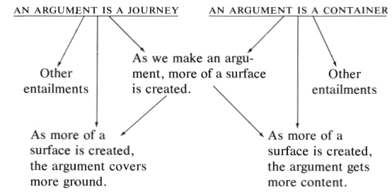

正是这两个隐喻之间蕴含关系的重叠，构成了它们之间的连贯性，并建立了论证涵盖范围与内容量之间的联系。这使得它们能够“契合”，即便它们并非完全一致，也就是说，并不存在一个能够完全契合这两个隐喻的“单一意象”。容器的表面地面和容器表面都属于表面，因为它们具有共同的拓扑属性。但是，我们对地面表面的印象与我们对各种容器表面的印象截然不同。构成这两种隐喻重叠部分的抽象拓扑概念——表面——不够具体，无法形成具体的图像。一般来说，当隐喻具有连贯性但不一致时，我们不应期望它们形成一致的图像。

It is this overlap of entailments between the two metaphors that defines the coherence between them and provides the link between the amount of ground the argument covers and the amount of content it has. This is what allows them to “fit together,” even though they are not completely consistent, that is, there is no “single image” that completely fits both metaphors. The surface of a container and the surface of the ground are both surfaces by virtue of common topological properties. But our image of ground surface is very different than our images of various kinds of container surfaces. The abstract topological concept of a surface which forms the overlap between these two metaphors is not concrete enough to form an image. In general when metaphors are coherent but not consistent, we should not expect them to form consistent images.

连贯性和一致性之间的区别是至关重要。每个比喻都聚焦于“论证”概念的一个方面：因此，每个比喻都服务于单一目的。此外，每个比喻都使我们能够根据一个更清晰界定的概念（例如“旅程”或“容器” ）来理解“论证”概念的某个方面。我们需要两个比喻的原因是：因为没有一个单一的比喻能够胜任这项工作——没有一个单一的比喻能够让我们同时把握论证的方向和内容。这两个目的无法由一个比喻同时实现。如果目的无法融合，比喻自然也无法融合。因此，我们就会看到一些不恰当的混合比喻，而这些混合比喻正是由以下原因造成的：不可能存在一个清晰明确的隐喻能够同时满足这两个目的。例如，我们可以谈论论证的*方向*和论证的*内容*，但不能谈论论证*内容的方向，也不能谈论论证**方向*的内容。因此，我们不会得到如下句子：

The difference between coherence and consistency is crucial. Each metaphor focuses on one aspect of the concept ARGUMENT: in this, each serves a single purpose. Moreover, each metaphor allows us to understand one aspect of the concept in terms of a more clearly delineated concept, e.g., JOURNEY or CONTAINER. The reason we need two metaphors is because there is no one metaphor that will do the job—there is no one metaphor that will allow us to get a handle simultaneously on both the direction of the argument and the content of the argument. These two purposes cannot both be served at once by a single metaphor. And where the purposes won’t mix, the metaphors won’t mix. Thus we get instances of impermissible mixed metaphors resulting from the impossibility of a single clearly delineated metaphor that satisfies both purposes at once. For example, we can speak of the *direction* of the argument and of the *content* of the argument but not of the *direction of the content* of the argument nor of the *content of the direction* of the argument. Thus we do not get sentences like:

现在我们可以沿着论证的核心*路径进行分析**了。*

We can now follow the *path* of the *core* of the argument.

这论证*内容**如下*。

The *content* of the argument *proceeds* as follows.

他的论点毫无实质*内容**。*

The *direction* of his argument has no *substance.*

你的论证思路*空洞无物，*令我感到不安。

I am disturbed by the *vacuous path* of your argument.

如果存在一种方法，能够用一个清晰界定的概念*完全*满足这两个目的，那么这两个比喻就能够保持一致。然而，我们得到的只是连贯性，即两个目的都得到了部分满足。例如，“旅程”隐喻既强调了方向，也强调了朝着目标前进的进程。“容器”隐喻强调了内容的数量、密度、中心性和边界。“旅程”隐喻的*进程*性与“容器”隐喻的*数量*性可以同时被强调，因为随着论证的进行，数量会增加。而且，正如我们所看到的，这导致了……混合比喻。

The two metaphors would be consistent if there were a way to *completely* satisfy both purposes with one clearly delineated concept. Instead, what we get is coherence, where there is a partial satisfaction of both purposes. For instance, the JOURNEY metaphor highlights both direction and progress toward a goal. The CONTAINER metaphor highlights the content with respect to its amount, density, centrality, and boundaries. The *progress* aspect of the JOURNEY metaphor and the *amount* aspect of the CONTAINER metaphor can be highlighted simultaneously because the amount increases as the argument progresses. And, as we saw, this results in permissible mixed metaphors.

到目前为止，我们已经研究了“论证”这一概念的两种隐喻结构之间的一致性，并发现了以下几点：

So far we have looked at the coherences between two metaphorical structurings of the concept ARGUMENT, and we have found the following:

*—隐喻蕴含在将一个概念的单一*隐喻结构的所有实例联系起来方面起着至关重要的作用（例如“论证是一段旅程”隐喻的各种实例）。

—Metaphorical entailments play an essential role in linking all of the instances of a *single* metaphorical structuring of a concept (as in the various instances of the AN ARGUMENT IS A JOURNEY metaphor).

—隐喻蕴含也发挥着作用在连接同一概念的*两种不同隐喻结构方面起着至关重要的作用（例如，用*“旅程”和“容器”隐喻来表示“论证”）。

—Metaphorical entailments also play an essential role in linking *two different* metaphorical structurings of a single concept (as in the JOURNEY and CONTAINER metaphors for ARGUMENT).

—共同的隐喻蕴含可以建立跨隐喻的对应关系。例如，共同的隐喻蕴含“当我们进行论证时，会创造出更多的表面”就建立了论证中涵盖的范围与表面之间的对应关系。（这符合“旅程”的比喻）以及论证中的内容量（这符合“容器”的比喻）。

—A shared metaphorical entailment can establish a cross-metaphorical correspondence. For example, the shared entailment AS WE MAKE AN ARGUMENT, MORE OF A SURFACE IS CREATED establishes a correspondence between the amount of ground covered in the argument (which is in the JOURNEY metaphor) and the amount of content in the argument (which is in the CONTAINER metaphor).

—概念的各种隐喻结构通过突出概念的不同方面来发挥不同的作用。

—The various metaphorical structurings of a concept serve different purposes by highlighting different aspects of the concept.

—当目的重叠时，隐喻也会重叠，因此它们之间会产生连贯性。允许的混合隐喻属于以下几种情况：这种重叠。

—Where there is an overlapping of purposes, there is an overlapping of metaphors and hence a coherence between them. Permissible mixed metaphors fall into this overlap.

—一般来说，比喻之间完全一致的情况很少见；而连贯性则是常见的。

—In general, complete consistency across metaphors is rare; coherence, on the other hand, is typical.

17

17

隐喻之间的复杂连贯性

Complex Coherences across Metaphors

在讨论连贯性时，最重要的是要牢记目的的作用。对概念进行隐喻式的结构化，例如用“旅程”隐喻来描述论证，可以帮助我们把握概念的某个方面。因此，当一个隐喻满足某个目的，即理解概念的某个方面时，它就有效。当两个隐喻……如果成功满足两个目的，那么目的上的重叠就对应于隐喻上的重叠。我们认为，这种重叠可以用共享的隐喻蕴含以及由此建立的跨隐喻对应关系来刻画。

The most important thing to bear in mind throughout our discussion of coherence is the role of purpose. A metaphorical structuring of a concept, say the JOURNEY metaphor for arguments, allows us to get a handle on one aspect of the concept. Thus a metaphor works when it satisfies a purpose, namely, understanding an aspect of the concept. When two metaphors successfully satisfy two purposes, then overlaps in the purposes will correspond to overlaps in the metaphors. Such overlaps, we claim, can be characterized in terms of shared metaphorical entailments and the cross-metaphorical correspondences established by them.

我们在上一章的一个简单的例子中看到了这一点。现在，我们想说明同样的机制也适用于复杂的例子。这种复杂性源于两个方面：(1) 很多隐喻常常部分地构建同一个概念；(2) 当我们讨论一个概念时，会用到其他本身就以隐喻方式理解的概念，这导致隐喻进一步重叠。我们可以通过进一步考察“论证”这一概念来找出导致这种复杂性的因素。

We saw this in a simple example in the last chapter. We would now like to show that the same mechanisms are involved in complex examples. There are two sources of such complexity: (1) there are often many metaphors that partially structure a single concept and (2) when we discuss one concept, we use other concepts that are themselves understood in metaphorical terms, which leads to further overlapping of metaphors. We can isolate the factors that lead to such complexities by examining further the concept ARGUMENT.

总的来说，论点论证的目的是为了理解。当我们想要展现显而易见（我们习以为常）的事物与那些不那么显而易见的事物之间的联系时，我们就会构建论证。我们通过将各种观点组合在一起来实现这一点。这些观点构成了论证的内容。我们习以为常的事物是论证的起点。我们希望……展示的是目标我们必须达成目标。在朝着这些目标前进的过程中，我们通过建立联系来取得进展。这些联系可能强也可能弱，而联系网络本身也具有整体结构。在任何论证中，某些观点和联系可能比其他观点和联系更为基础，某些观点也可能比其他观点和联系更为显而易见。一个论证的好坏取决于其内容、联系的强度以及……它如何直接地建立联系，以及这些联系如何易于理解。简而言之，各种论证隐喻旨在帮助理解该概念的以下几个方面：

In general, arguments serve the purpose of understanding. We construct arguments when we need to show the connections between things that are obvious—that we take for granted—and other things that are not obvious. We do this by putting ideas together. These ideas constitute the content of the argument. The things we take for granted are the starting point of the argument. The things we wish to show are the goals that we must reach. As we proceed toward these goals, we make progress by establishing connections. The connections may be strong or weak, and the network of connections has an overall structure. In any argument certain ideas and connections may be more basic than others, certain ideas will be more obvious than others. How good an argument is will depend on its content, the strength of the connections, how directly it establishes the connections, and how easy it is to understand the connections. Briefly, the various ARGUMENT metaphors serve the purpose of providing an understanding of the following aspects of the concept:

| 内容 | 基本性 |
| --- | --- |
| 进步 | 显而易见 |
| 结构 | 直接 |
| 力量 | 明晰 |

在前一章中我们看到，“旅程”这一比喻至少侧重于内容和进展，“容器”隐喻至少关注内容，并且基于内容的逐步积累，两者之间存在重叠。但这两个隐喻还有更多用途，并涉及更复杂的逻辑关系。我们可以通过考察第三个论证隐喻来理解这一点：

In the preceding chapter we saw that the JOURNEY metaphor focuses at least on content and progress, that the CONTAINER metaphor focuses at least on content, and that there is an overlap based on the progressive accumulation of content. But these two metaphors serve even more purposes and are involved in even more complex coherences. We can see this by considering a third metaphor for arguments:

论点是一座建筑

AN ARGUMENT IS A BUILDING

我们已经有了构建*有力论证的**框架*。

We’ve got the *framework* for a *solid* argument.

如果你不*支持*你的*如果用确凿的*事实进行反驳，整个论点就会*站不住脚。*

If you don’t *support* your argument with *solid* facts, the whole thing will *collapse.*

他试图用很多无关的事实来*支撑自己的论点，但这个论点仍然非常**不稳固*，很容易在批评面前*崩溃*。

He is trying to *buttress* his argument with a lot of irrelevant facts, but it is still so *shaky* that it will easily *fall apart* under criticism.

有了这些*基础*，你就能*构建*一个相当*有力的*论点。

With the *groundwork* you’ve got, you can *construct* a pretty *strong* argument.

“旅程”、“容器”和“建筑”这三个比喻共同聚焦于“论证”概念的上述所有方面。如下表所示：

Together, the JOURNEY, CONTAINER, and BUILDING metaphors focus on all of the above aspects of the concept ARGUMENT, as the following lists show:

| 旅行 | 容器 | 建筑 |
| --- | --- | --- |
| 内容 | 内容 | 内容 |
| 进步 | 进步 | 进步 |
| 直接 | 基本性 | 基本性 |
| 显而易见 | 力量 | 力量 |
|  | 明晰 | 结构 |

以下是一些我们如何用比喻来理解这些方面的例子：

Here are some examples of how we understand each of these aspects in terms of the metaphors:

旅行

JOURNEY

*到目前为止，*我们还没有*取得太多进展。*（*进展、内容*）

*So far,* we haven’t *covered much ground.* (*progress, content*)

这是一个*迂回的*论证。（*直截了当*）

This is a *roundabout* argument. (*directness*)

我们需要深入*研究，*以便*清楚地了解*其中涉及的内容。（*进展，显而易见性*）

We need to *go into this further* in order to *see clearly* what’s involved. (*progress, obviousness*)

容器

CONTAINER

*你的论点中*所有观点都正确，但论证本身*仍然*不够*清晰明了。*（*内容、进展、清晰度*）

You have all the right ideas *in* your argument, but the argument is *still* not *transparent.* (*content, progress, clarity*)

这些观点构成了论证的*核心。（**有力、基本*）

These ideas form the *solid core* of the argument. (*strength, basicness*)

建筑

BUILDING

我们已经有了论证的*基础*，现在需要一个*坚实的框架。*（*基本性、强度、结构*）

We’ve got a *foundation* for the argument, now we need a *solid framework.* (*basicness, strength, structure*)

我们*已经构建了大部分论证。*（*进展，内容*）

We *have now constructed most of the argument.* (*progress, content*)

我们在前一章中看到，旅程和容器都定义了表面，这是“旅程”和“容器”这两个隐喻重叠的基础。而建筑物也具有表面，即地基和外壳，这使得它与“建筑物”这个隐喻进一步重叠。在每种情况下，*表面*都定义了*内容，*但方式各不相同：

We saw in the preceding chapter that the fact that both journeys and containers define surfaces was the basis for the overlap between the JOURNEY and CONTAINER metaphors. The fact that a building also has a surface, namely, the foundation and the outer shell, makes possible further overlaps with the BUILDING metaphor. In each case the *surface* defines the *content,* but in different ways:

| 旅行： | 论证路径所定义的表面“覆盖了地面”，而内容就是论证所覆盖的地面。 |
| --- | --- |
| 容器： | 内容物位于容器内部，容器的边界由其表面定义。 |
| 建筑： | 表面是建筑物的外壳和地基，它们界定了建筑物的内部空间。但在“建筑物”的比喻中，与“容器”的比喻不同，内容并不*在*内部；相反，地基和外壳*构成了*内容。我们可以从以下例子中看出这一点：“你的论证基础缺乏足够的内容来支撑你的论点”以及“你的论证框架缺乏足够的实质内容来经受批评”。 |

我们不妨称这些表面为“内容定义表面”。表面。”

Let us call these surfaces “content-defining surfaces.”

仅仅用内容界定表面的概念不足以解释我们在隐喻中发现的许多一致性。例如，有些隐喻的重叠是基于深度概念的。由于深度也是相对于某个表面定义的，我们可能会认为每个隐喻的深度界定表面应该与内容界定表面相同。然而，情况并非总是如此，如下例所示：

The notion of a content-defining surface is not sufficient to account for many of the coherences that we find among the metaphors. For example, there are instances of metaphorical overlap based on the notion of depth. Since depth is also defined relative to a surface, we might think that the depth-defining surface for each metaphor would be the same as the content-defining surface. However, this is not always the case, as the following examples show:

这种论点*过于肤浅*，需要更多*论据支撑。*（建设）

This is a *shallow* argument; it needs more *foundation.* (BUILDING)

我们已经*深入探讨了*这些想法*。*（旅程）

We have *gone over* these ideas *in great depth.* (JOURNEY)

你还没有触及到最*深刻的*要点——论点的*核心*。 （容器）

You haven’t gotten to the *deepest* points yet—those at the *core* of the argument. (CONTAINER)

在“建筑”和“旅程”这两个比喻中，定义深度的表面都是地面。在“容器”中……这是一种比喻，它再次指的是容器表面。

In both the BUILDING and JOURNEY metaphors, the depth-defining surface is the ground level. In the CONTAINER metaphor, it is again the container surface.

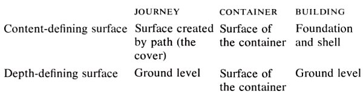

在探讨这些连贯性之前，必须认识到这里存在两种不同的深度概念。在“建筑”和“容器”的隐喻中，更深层的是更基本的。最基本的论证的某些部分最为深刻：它们是基础和核心。然而，在“旅程”的比喻中，深刻的事实指的是那些不显而易见的事实。那些不在表面之下的事实是……它们隐藏在不易察觉之处；我们需要深入探究。论证的目的包括涵盖某些主题（并最终完成——“盖上盖子”），此外，还要对这些主题进行*适当的深入探讨。*论证的进展不仅仅是涵盖主题；它还要求我们对主题进行充分的深入研究。对主题进行必要的深入研究是……的一部分旅程：

Before proceeding to the coherences, it is important to recognize that there are two different notions of depth operating here. In the BUILDING and CONTAINER metaphors, what is deeper is more basic. The most basic parts of the argument are the deepest: the foundation and the core. However, in the JOURNEY metaphor, deep facts are those that are not obvious. Facts that are not on the surface are hidden from immediate view; we need to go into them in depth. The purposes of an argument include covering certain topics (finishing with them—“putting the lid on”) and, in addition, covering them at *appropriate depths.* Progress in an argument is not merely a matter of covering topics; it also requires us to go sufficiently deeply into them. Going into the topic to the required depth is part of the journey:

随着我们*对*这个话题的*深入探讨，*我们发现……

As we *go into* the topic *more deeply,* we find . . .

我们已经*到了*必须深入*探讨*这些问题的地步*。*

We have *come to a point* where we must *explore* the issues at a *deeper level.*

由于大部分旅程都在地球表面进行，因此正是这地表决定了我们所要探讨主题的*深度*。但是，当我们深入研究任何一个主题时，我们都会留下痕迹（地表），就像我们在旅程的其他部分一样。正是通过超越表面现象，我们才能对某个主题进行*更深入的**探讨*。这可以解释以下表达方式：

Since most of the journey is over the surface of the earth, it is that surface that defines the *depth* of the topics to be covered. But as we go into any one topic in depth, we leave a trail (a surface) behind us, as we do on all parts of the journey. It is by leaving this surface behind that we *cover* a topic *at a certain depth.* This accounts for the following expressions:

我们将*深入探讨*各种主题。

We will be *going deeply into* a variety of topics.

*接下来，*我们将深入探讨这些问题*。*

*As we go along,* we will go through these issues *in depth.*

我们现在已经*涵盖了所有**相应级别的*主题。

We have now *covered* all the topics *at the appropriate levels.*

因此，深度这一隐喻取向与“建筑物”和“容器”这两个隐喻中的基本性相对应。但“旅程”这一比喻缺乏显而易见性。由于深度和进展是论证中截然不同的两个方面，因此在任何“论证”比喻中都不可能存在*一致的*意象。但在这里，正如之前所述，虽然无法保持一致性，但比喻本身却具有连贯性。

Thus the metaphorical orientation of depth corresponds to basicness in the BUILDING and CONTAINER metaphors but to lack of obviousness in the JOURNEY metaphor. Since depth and progress are very different aspects of an argument, there is no *consistent* image possible within any of the ARGUMENT metaphors. But here, as before, though consistency is not possible, there is metaphorical coherence.

在明确了内容定义表面和深度定义表面之间的区别之后，我们现在可以……可以看到许多其他复杂的内在联系。正如“旅程”和“容器”这两个隐喻之间的内在联系一样，这三个隐喻之间也存在着内在联系。基于这三者都具有定义内容的表面这一事实。随着论证的进行，表面不断扩展，论证的内容也随之增加。这体现了概念的三种隐喻结构之间的重叠。允许使用以下类型的混合隐喻：

Having clarified the distinction between content-defining surfaces and depth-defining surfaces, we are in a position to see a number of other complex coherences. As in the case of the coherence between the JOURNEY and CONTAINER metaphors, there is coherence among all three metaphors based on the fact that all three have content-defining surfaces. As the argument proceeds, more of a surface is created, and hence the argument gets more content. This overlap among the three metaphorical structurings of the concept allows mixed metaphors of the following sort:

*至此，*我们已经*构建了*论证的*核心部分*。

*So far* we have *constructed* the *core* of our argument.

这里的“到目前为止”源自“旅程”的比喻，“构建”源自“建筑”的比喻，“核心”源自“容器”的比喻。请注意，我们可以用建筑概念“基础”或中性概念“最基本部分”来代替“核心”，表达几乎相同的意思：

Here “so far” is from the JOURNEY metaphor, “construct” is from the BUILDING metaphor, and “core” is from the CONTAINER metaphor. Notice that we can say pretty much the same thing by using the building concept “foundation” or the neutral concept “most basic part” in place of “core”:

*到目前为止*我们已经*构建了**论证*的基础。

*So far* we have *constructed* the *foundation* of the argument.

*至此，*我们已经*构建了*论证中最基本*的部分。*

*So far* we have *constructed* the *most basic part* of the argument.

之所以能够做到这一点，是因为“建筑”和“容器”这两个隐喻都具有“深度”这一基本特征。它们都包含一个最深层、也就是最基本的部分：在“容器”隐喻中，它是*核心；*在“建筑”隐喻中，它是*基础。*因此，它们之间存在着对应关系。这两个比喻之间存在着联系。这一点可以从以下例子中看出，由于对应关系，容器和建筑物这两个比喻可以自由地混合使用。

What makes this possible is that depth characterizes basicness in both the BUILDING and CONTAINER metaphors. Both of them have a deepest, that is, most basic part: In the CONTAINER metaphor it is the *core,* and in the BUILDING metaphor it is the *foundation.* Thus we have a correspondence between the two metaphors. This can be seen in the following examples, where the CONTAINER and BUILDING metaphors can be freely mixed by virtue of the correspondence.

这些要点是我们论证的*核心*，也是接下来一切的*基础。*

These points are *central* to our argument and provide the *foundation* for all that is to come.

我们可以通过指出该论点的*核心*论点薄弱来*削弱它。*

We can *undermine* the argument by showing that the *central* points in it are weak.

最重要的理念，其他一切都建立在这些理念*之上。**休息*是论证的*核心。*

The most important ideas, *upon* which everything else *rests,* are at the *core* of the argument.

此处的对应关系基于共同蕴含关系：

The correspondence here is based on the shared entailment:

争论就像一座建筑物。

AN ARGUMENT IS A BUILDING.

建筑物有最深处。

A building has a deepest part.

因此，论证有一个最深刻的部分。

Therefore, AN ARGUMENT HAS A DEEPEST PART.

论点是一个容器。

AN ARGUMENT IS A CONTAINER.

容器有最深处。

A container has a deepest part.

因此，论证有一个最深刻的部分。

Therefore, AN ARGUMENT HAS A DEEPEST PART.

由于深度是这两个比喻的基本特征，因此最深的部分也是最基本的。部分。因此， “最基本部分”这一概念介于这两个隐喻之间，处于两者之间，是中性的。

Since depth characterizes basicness for both metaphors, the deepest part is the most basic part. The concept MOST BASIC PART therefore falls into the overlap of the two metaphors and is neutral between them.

既然论证的目的是为了增进理解，那么“理解即是看见”这一比喻与各种论证比喻相呼应也就不足为奇了。正如旅行中，你会随着旅程的推进而看到更多一样， “论证也是一段旅程”这一比喻也同样适用。随着论证的深入，你会看到更多——而且，由于理解本身就是一种观察，你也会更加理解。这就解释了诸如此类的表达：

Since the purpose of an argument is to provide understanding, it is not surprising that the metaphor UNDERSTANDING IS SEEING should overlap with the various ARGUMENT metaphors. When you travel, you see more as you go along. This carries over to the metaphor AN ARGUMENT IS A JOURNEY. As you go along through the argument, you see more—and, since UNDERSTANDING IS SEEING, you understand more. This accounts for expressions like:

我们刚才已经*观察到*，阿奎那运用了某些柏拉图式的概念。

We have just *observed* that Aquinas used certain Platonic notions.

*既然我们已经了解了这一点，*现在就可以*明白*黑格尔错在哪里了。

*Having come this far,* we can now *see* how Hegel went wrong.

因为旅途中可能会有向导沿途指出有趣的地方，所以我们也会听到这样的表达：

Because a journey may have a guide who points out things of interest along the way, we also get expressions like:

我们现在将 *证明*格林误解了康德关于意志的论述。

We will now *show* that Green misinterpreted Kant’s account of will.

*注意*，如果不附加假设，*X*不能从*Y推导出来。*

*Notice* that *X* does not follow from *Y* without added assumptions.

我们应该*指出*，目前尚未找到此类证据。

We ought to *point out* that no such proof has yet been found.

在这些情况下，作者就像向导一样，带领我们了解整个论证过程。

In these cases, the author is the guide who takes us through the argument.

“旅程”这一比喻的一部分在于深入探究某个主题。“理解即看见”这一比喻也适用于此。在论证中表面现象（显而易见的方面）显而易见，容易理解。但深层现象却并非如此。我们需要付出努力——深入挖掘——才能将其揭示出来。随着我们对问题的深入探究，我们会发现更多。这使我们能够看得更远，也就是说，理解得更透彻。这就解释了诸如此类的表达：

Part of the JOURNEY metaphor involves going deeply into a subject. The UNDERSTANDING IS SEEING metaphor applies in this case too. In an argument the superficial points (those on the surface) are obvious; they are easy to see, easy to understand. But the deeper points are not obvious. It requires effort—digging—to reveal them so that we can see them. As we go more deeply into an issue, we reveal more, which allows us to see more, that is, to understand more. This accounts for expressions like:

*深入研究*他的论点，你会发现*发现*很多好东西。

*Dig further into* his argument and you will *discover* a great deal.

只有*深入研究*这些问题，我们才能*看到这一点。*

We can *see* this only if we *delve deeply into* the issues.

*肤浅的*论点几乎毫无价值，因为它们无法向我们*展示*太多东西。

*Shallow* arguments are practically worthless, since they don’t *show* us very much.

“理解即看见”的比喻也与“构建”的比喻有所重叠，其中所看见的是论证的结构（形状、形式、轮廓等）：

The UNDERSTANDING IS SEEING metaphor also overlaps with the BUILDING metaphor, where what is seen is the structure (shape, form, outline, etc.) of the argument:

现在我们可以*看到*论点的轮廓*了。*

We can now *see* the *outline* of the argument.

如果我们仔细*观察*一下论证*结构……*

If we *look* carefully at the *structure* of the argument . . .

最后，“理解即看见”这一比喻与“容器”这一比喻有所重叠，我们所看到的正是内容（透过容器的表面），例如：

Finally, the UNDERSTANDING IS SEEING metaphor overlaps with the CONTAINER metaphor, where what we see is the content (through the surface of the container), as in:

这是一个非常*显而易见的*论点。

That is a remarkably *transparent* argument.

我没*看出你论点**中的*这一点。

I didn’t *see* that point *in* your argument.

由于你的论点不太*清晰，*我不太*明白*你的意思。

Since your argument isn’t very *clear,* I can’t *see* what you’re getting at.

你的论点毫无*实质内容*——我一眼就能*看穿*。

Your argument has no *content* at all—I can *see right through* it.

在讨论论证质量时，又出现了一种跨隐喻的连贯性。各种“论证”隐喻所关注的论证的许多方面都可以量化——例如，内容、清晰度、力度、直接性和显而易见性。“多多益善”隐喻与所有“论证”隐喻都有重叠之处，使我们能够从多个角度看待论证质量。就数量而言。因此，我们有如下示例：

Another cross-metaphorical coherence appears in discussing the quality of an argument. Many of the aspects of an argument that are focused on by the various ARGUMENT metaphors can be quantified—for example, content, clarity, strength, directness, and obviousness. The MORE IS BETTER metaphor overlaps with all of the ARGUMENT metaphors and allows us to view quality in terms of quantity. Thus we have examples like the following:

这*算不上什么有力的论点。*

That’s *not much of an argument.*

你的论点*没有任何实质内容。*

Your argument *doesn’t have any content.*

这个论点并不充分，因为它*几乎没有涉及任何实质内容*。

It’s not a very good argument, since it *covers hardly any ground* at all.

这种论点行不通——它*不够清晰。*

This argument won’t do—it’s just *not clear enough.*

你的论据*太薄弱，*不足以支撑你的主张。

Your argument is *too weak* to support your claims.

这个论点*太绕弯了*——没人能听懂。

The argument is *too roundabout*—no one will be able to follow it.

你的论点不成立对主题*进行足够深入的探讨。*

Your argument doesn’t cover the subject matter *in enough depth.*

所有这些都以数量来衡量质量。

All of these assess quality in terms of quantity.

我们远未穷尽所有涉及“论证”隐喻的跨隐喻关联。例如，考虑一下基于“论证即战争”隐喻的庞大关联网络。在这里，胜负、攻防、制定和实施策略等都可能发生。这里存在着论证。我们可以把论点比作堡垒（借用“建筑物”的比喻），从而发起攻击，攻破它的漏洞，最终将其摧毁。我们也可以把论点比作导弹（借用“容器”的比喻），这样我们就可以发出“发射！”的挑战，而对方的回应论点可能正中靶心，一击制胜。在防守中，你可以尝试击退对手的论点。

We have by no means exhausted all the cross-metaphorical coherences involving ARGUMENT metaphors. Consider, for example, the extensive network of coherences based on the ARGUMENT IS WAR metaphor. Here it is possible to win or lose, to attack and defend, to plan and pursue a strategy, etc. Here arguments may be fortresses via the BUILDING metaphor, so that we can launch an attack on an argument, knock holes in it, tear it down and destroy it. Arguments may also be missiles, via the CONTAINER metaphor. Thus we can offer the challenge “Shoot!” and the argument in reply may be right on target and hit the mark. In defense you can try to shoot down your opponent’s argument.

现在应该很清楚了。简单例子中展现出的那种连贯性，同样也出现在我们刚才探讨的更为复杂的案例中。乍看之下，那些看似随机、孤立的比喻表达——例如，“*涵盖这些要点”、“强化你的论点”、“直击核心”、“深入挖掘”、“攻击某个立场”*和*“驳斥*”——实际上并非随机。相反，它们是整个比喻体系的一部分。这些系统共同服务于一个复杂的目的：在我们理解的意义上，从各个方面刻画论证的概念。尽管这类隐喻无法为我们提供单一且连贯的具体形象，但它们仍然是连贯的，并且在存在重叠蕴含关系时能够相互契合，否则则不然。这些隐喻源于我们清晰明确且具体的经验。并允许我们构建高度抽象和复杂的概念，例如论证。

By now it should be clear that the same kinds of coherence found in simple examples also occur in far more complex cases of the sort we have just examined. What may at first appear to be random, isolated metaphorical expressions—for example, *cover those points, buttress your argument, get to the core, dig deeper, attack a position,* and *shoot down*—turn out to be not random at all. Rather, they are part of whole metaphorical systems that together serve the complex purpose of characterizing the concept of an argument in all of its aspects, as we conceive them. Though such metaphors do not provide us with a single consistent concrete image, they are nonetheless coherent and do fit together when there are overlapping entailments, though not otherwise. The metaphors come out of our clearly delineated and concrete experiences and allow us to construct highly abstract and elaborate concepts, like that of an argument.

18

18

对概念结构理论的一些影响

Some Consequences for Theories of Conceptual Structure

任何充分的人类概念系统理论都必须解释概念是如何（1）建立基础、（2）构建结构、（3）相互关联以及（4）定义的。到目前为止，我们已经对概念的基础、结构和相互关系（子范畴化、隐喻蕴含、部分、参与者）给出了初步解释。等等）对于我们认为的典型案例。此外，我们已经论证过，我们的大部分概念体系都是隐喻结构的，并简要说明了这意味着什么。在我们探讨我们的观点对定义的影响之前，我们需要了解语言学家和逻辑学家在不提及隐喻的情况下处理我们称之为隐喻性概念的两种主要策略。概念。

Any adequate theory of the human conceptual system will have to give an account of how concepts are (1) grounded, (2) structured, (3) related to each other, and (4) defined. So far we have given a provisional account of grounding, structuring, and relations among concepts (subcategorization, metaphorical entailment, part, participant, etc.) for what we take to be typical cases. We have argued, moreover, that most of our conceptual system is metaphorically structured and have given a brief account of what that means. Before we explore the implications of our views for definition, we need to look at two major strategies that linguists and logicians have used to handle, without any reference to metaphor, what we have called metaphorical concepts.

这两种策略分别是*抽象*和*同音异义。*为了了解它们与我们提出的解释有何不同，请考虑“He buttressed the wall”（他加固了墙）和“He buttress his argument with more facts”（他用更多事实支撑了他的论点）中的“buttress”一词*。**根据*我们的解释，我们根据“BUTTRESS”（支撑）这一概念来理解“He buttressed his argument”（他用更多事实支撑了他的论点），而“BUTTRESS”是“ BUILDING”（建造）这一格式塔的一部分。由于“ARGUMENT”（论点）这一概念是……部分理解“论证如同建筑物”这一比喻，概念“论证”中“支撑”一词的含义将源于其在“建筑物”概念中的含义，以及“建筑物”这一比喻对“论证”概念的整体结构作用。因此，在“他支撑了他的论证”这句话中，我们不需要对“支撑”这一概念进行独立的定义。

The two strategies are *abstraction* and *homonymy.* To see how these differ from the account we have offered, consider the word *buttress* in “He buttressed the wall” and “He buttressed his argument with more facts.” On our account, we understand *buttress* in “He buttressed his argument” in terms of the concept BUTTRESS, which is part of the BUILDING gestalt. Since the concept ARGUMENT is comprehended partly in terms of the metaphor AN ARGUMENT IS A BUILDING, the meaning of “buttress” in the concept ARGUMENT will follow from the meaning it has in the concept BUILDING, plus the way that the BUILDING metaphor in general structures the concept ARGUMENT. Thus we do not need an independent definition for the concept BUTTRESS in “He buttressed his argument.”

与此相反，*抽象*观点认为存在一个单一的、非常普遍且抽象的概念“扶壁” （BUTTRESS），它在建筑物的“扶壁”（buttress）和论证的“扶壁”（buttress）之间保持中立。根据这种观点，“他扶壁了墙”（He buttressed the wall）和“他扶壁了他的论证”（He buttressed his argument）都是同一个非常抽象概念的特例。*同音异义*论则采取相反的立场。它并不认为存在一个抽象且中立的概念。关于“扶壁”（BUTTRESS）概念，同音异义论认为存在两个不同且独立的概念：扶壁<sub>1</sub> *和* 扶壁<sub>2。</sub>强同音异义论认为扶壁<sub>1</sub>和扶壁<sub>2完全不同，彼此毫无关联，因为前者指的是物理对象（建筑构件）</sub>*，*后者指的是抽象概念（论证的一部分）。*弱*同音异义论该观点认为存在两个截然不同且独立的“支撑<sub>1”</sub>和“支撑<sub>2”</sub>概念，但承认它们在某些方面含义可能相似，并且这两个概念因这种相似性而相关。然而，该观点否认任何一个概念都可以通过另一个概念来理解。它所主张的仅仅是这两个概念具有某种共同之处：一种抽象的相似性。关于这一点，弱同音异义论与抽象论有一个共同点，因为抽象相似性恰好具有抽象理论所假设的核心概念的属性。

Against this, the *abstraction* view claims that there is a single, very general, and abstract concept BUTTRESS, which is neutral between the BUILDING “buttress” and the ARGUMENT “buttress.” According to this view, “He buttressed the wall” and “He buttressed his argument” are both special cases of the same very abstract concept. The *homonymy* view takes the opposite tack. Instead of claiming that there is one abstract and neutral concept BUTTRESS, the homonymy view claims that there are two different and independent concepts, BUTTRESS<sub>1</sub> *and* BUTTRESS<sub>2</sub>. There is a *strong* homonymy view, according to which BUTTRESS<sub>1</sub> and BUTTRESS<sub>2</sub> are entirely different and have nothing to do with each other, since one refers to physical objects (building parts) and the other to an abstract concept (a part of an argument). The *weak* homonymy view maintains that there are distinct and independent concepts BUTTRESS<sub>1</sub> and BUTTRESS<sub>2</sub> but allows that their meanings may be similar in some respects and that the concepts are related by virtue of this similarity. It denies, however, that either concept is understood in terms of the other. All it claims is that the two concepts have something in common: an abstract similarity. On this point, the weak homonymy view shares an element with the abstraction view, since the abstract similarity would have precisely the properties of the core concept that is hypothesized by the abstraction theory.

现在，我们想阐明为什么抽象理论和同音异义理论都无法解释那些促使我们提出隐喻概念理论的事实——特别是那些事实。关于隐喻类型（方向性、物理性和结构性）及其属性（内部系统性、外部系统性、基础性和连贯性）。

We would now like to show why neither the abstraction nor the homonymy theory can account for the kinds of facts that have led us to the theory of metaphorical concepts—in particular, the facts concerning the metaphorical types (orientational, physical, and structural) and their properties (internal systematicity, external systematicity, grounding, and coherence).

抽象观点的不足之处

Inadequacies of the Abstraction View

抽象理论在几个方面都存在不足。首先，它似乎完全没有意义，尤其是在以下方面：上下方向的隐喻，例如“快乐在上，控制在下”。向上，越多越好，美德越高，未来越高，理性越高，等等。究竟有什么单一的、包含任何内涵的通用概念，能够抽象出高度、幸福、控制、更多、美德、未来、理性以及北方，并且能够精确地涵盖所有这些概念呢？此外，向上和向下似乎不可能处于同一抽象层次，因为向上适用于未来，而向下并不适用于未来。回到过去。我们用部分隐喻结构来解释这一点，但根据抽象的提议，“向上”在某种意义上必须比“向下”更抽象，这似乎没有道理。

The abstraction theory is inadequate in several respects. First, it does not seem to make any sense at all with respect to UP-DOWN orientation metaphors, such as HAPPY IS UP, CONTROL IS UP, MORE IS UP, VIRTUE IS UP, THE FUTURE IS UP, REASON IS UP, etc. What single general concept with any content at all could be an abstraction of HEIGHT, HAPPINESS, CONTROL, MORE, VIRTUE, THE FUTURE, REASON, and NORTH and would precisely fit them all? Moreover, it would seem that UP and DOWN could not be at the same level of abstraction, since UP applies to the FUTURE, while DOWN does not apply to the PAST. We account for this by partial metaphorical structuring, but under the abstraction proposal UP would have to be more abstract in some sense than DOWN, and that does not seem to make sense.

其次，抽象理论不会区分*A 是 B形式的隐喻和**B 是 A*形式的隐喻，因为它会声称存在涵盖这两个领域的中性术语。例如，英语中有“爱是一段旅程”的隐喻，但没有“旅程即爱”的隐喻。抽象论观点会否认爱可以用旅程来理解，并得出一种反直觉的论断：爱和旅程可以用某种介于两者之间的抽象概念来理解。

Second, the abstraction theory would not distinguish between metaphors of the form *A is B* and those of the form *B is A,* since it would claim that there are neutral terms covering both domains. For example, English has the LOVE IS A JOURNEY metaphor but no JOURNEYS ARE LOVE metaphor. The abstraction view would deny that love is understood in terms of journeys, and it would be left with the counterintuitive claim that love and journeys are understood in terms of some abstract concept neutral between them.

第三，不同的隐喻可以构建同一个概念的不同方面；例如，“爱是一段旅程”、“爱是一场战争”、“爱是一种力量”、“爱是疯狂”。每一种说法都从不同的角度诠释了“爱”的概念，并构建了该概念的众多面向之一。抽象假设试图寻找一个足够抽象的、能够涵盖所有这些面向的单一的“爱”的概念。即便这种假设成立，它也忽略了这些比喻并非共同构成爱的关键所在。都体现了爱的核心概念，但分别体现了爱的不同方面。

Third, different metaphors can structure different aspects of a single concept; for example, LOVE IS A JOURNEY, LOVE IS WAR, LOVE IS A PHYSICAL FORCE, LOVE IS MADNESS. Each of these provides one perspective on the concept LOVE and structures one of many aspects of the concept. The abstraction hypothesis would seek a single general concept LOVE abstract enough to fit all of these aspects. Even if this were possible, it would miss the point that these metaphors are not jointly characterizing a core concept LOVE but are separately characterizing different aspects of LOVE.

第四，如果我们考察*A是B*形式的结构隐喻（例如，爱是一段旅程，心灵是一台机器，思想是食粮，争论是一座建筑），我们会发现*B*（定义概念）在……中更加清晰地被界定。我们的经验通常比*A*（已定义的概念）更具体。此外，定义概念所包含的内容总是比被定义概念所包含的内容更多。以“思想是食物”为例。我们可能拥有*未经加工的事实*和*不成熟的想法，*但不存在*炒熟、烤熟*或*煮熟的想法。*在“论证是建筑物”的比喻中，只有地基和外壳起作用，内部的房间、走廊、屋顶等等则无关紧要。我们已经用以下方式解释了这种不对称性：那些界限模糊（通常也不太具体）的概念，往往需要借助那些界限清晰（通常也更具体）的概念才能被理解，而后者又直接植根于我们的经验。抽象观点无法解释这种不对称性，因为它无法解释我们为何倾向于用更具体的概念来理解不那么具体的概念。

Fourth, if we look at structural metaphors of the form *A is B* (e.g., LOVE IS A JOURNEY, THE MIND IS A MACHINE, IDEAS ARE FOOD, AN ARGUMENT IS A BUILDING), we find that *B* (the defining concept) is more clearly delineated in our experience and typically more concrete than *A* (the defined concept). Moreover, there is always more in the defining concept than is carried over to the defined concept. Take IDEAS ARE FOOD. We may have *raw facts* and *half-baked ideas,* but there are no *sautéed, broiled,* or *poached ideas.* In AN ARGUMENT IS A BUILDING only the foundation and outer shell play a part in the metaphor, not the inner rooms, corridors, roof, etc. We have explained this asymmetry in the following way: the less clearly delineated (and usually less concrete) concepts are partially understood in terms of the more clearly delineated (and usually more concrete) concepts, which are directly grounded in our experience. The abstraction view has no explanation for this asymmetry, since it cannot explain the tendency to understand the less concrete in terms of the more concrete.

第五，在抽象层面该提议认为，根本不存在任何隐喻概念，因此，没有理由期待我们发现的那种系统性。例如，没有理由期待一整套食物概念体系适用于思想，或者一整套建筑概念体系适用于论证。也没有理由期待我们在《时间是一个运动的物体》中发现的那种内部一致性。例如，一般来说，抽象观点无法解释内部系统性的事实。

Fifth, under the abstraction proposal there are no metaphorical concepts at all and, therefore, no reason to expect the kind of systematicity that we have found. Thus, for example, there is no reason to expect a whole system of food concepts to apply to ideas or a whole system of building concepts to apply to arguments. There is no reason to expect the kind of internal consistency that we found in the TIME IS A MOVING OBJECT cases. In general, the abstraction view cannot explain the facts of internal systematicity.

抽象也无法解释外部系统性。我们的方案解释了同一概念的各种隐喻（例如，用“旅程”、“建筑”、“容器”和“战争”来指代论点）之间相互重叠的方式。这是基于它们共同的目的和共同的蕴含。隐喻概念之间的混合方式，取决于整个隐喻系统中共同的目标和蕴含关系。各个概念（例如核心、基础、掩护、击落等）之间的混合方式，是基于它们在整个隐喻系统中的共同目标和蕴含关系来预测的。由于抽象方案本身没有任何隐喻系统，因此它无法解释隐喻为何会以这种方式混合。

Abstraction also fails to explain external systematicity. Our proposal accounts for the way that various metaphors for a single concept (e.g., the JOURNEY, BUILDING, CONTAINER, and WAR metaphors for arguments) overlap in the way that they do. This is based on the shared purposes and shared entailments of the metaphorical concepts. The way that individual concepts (such as CORE, FOUNDATION, COVER, SHOOT DOWN, etc.) mix with each other is predicted on the basis of shared purposes and entailments in the entire metaphorical system. Since the abstraction proposal does not have any metaphorical systems, it cannot explain why metaphors can mix the way they do.

第六，自从抽象提案提出以来没有部分隐喻结构无法解释隐喻延伸到隐喻中未使用的部分，例如“你的理论是用廉价灰泥建造的”，以及许多其他属于“理论是建筑物”隐喻中未使用部分的例子。

Sixth, since the abstraction proposal has no partial metaphorical structuring, it cannot account for metaphorical extensions into the unused part of the metaphor, as in “Your theory is constructed out of cheap stucco” and many others that fall within the unused portion of the THEORIES ARE BUILDINGS metaphor.

最后，抽象假设（例如，以《爱是一段旅程》为例）假定存在一组抽象概念。有些概念本身与爱情和旅程无关，却能“契合”或“适用于”二者。但为了使这些抽象概念能够“契合”或“适用于”爱情，爱情这一概念本身必须具有独立的结构，才能实现这种“契合”。正如我们将要展示的，爱情并非一个结构清晰的概念；它所拥有的任何结构都只能通过隐喻获得。但这种抽象这种观点没有隐喻来进行结构化构建，因此必须假定存在一种与旅程相关方面一样清晰的结构，这种结构独立于“爱”的概念而存在。这很难想象它是如何实现的。

Finally, the abstraction hypothesis assumes, in the case of LOVE IS A JOURNEY, for example, that there is a set of abstract concepts, neutral with respect to love and journeys, that can “fit” or “apply to” both of them. But in order for such abstract concepts to “fit” or “apply to” love, the concept LOVE must be independently structured so that there can be such a “fit.” As we will show, LOVE is not a concept that has a clearly delineated structure; whatever structure it has it gets only via metaphors. But the abstraction view, which has no metaphors to do the structuring, must assume that a structure as clearly delineated as the relevant aspects of journeys exists independently for the concept LOVE. It’s hard to imagine how.

同音异义论的不足之处

Inadequacies of the Homonymy View

*强同音异义词*

*Strong Homonymy*

*同音异义*词是指用同一个词来指代不同的概念，例如*河岸*和存款*银行。*根据我们讨论过的这类例子的同音异义理论，在“他们*攻击了*堡垒”和“他们*攻击了*我的论点”中，“攻击”一词代表的是两个完全不同且不相关的概念。使用同一个词“攻击”被认为是一个巧合。同样地，“*在*厨房里”、“*在*麋鹿俱乐部”和“恋爱*中*”中的“在”也代表着三个完全不同的概念。独立且不相关的概念——而且使用同一个词纯属偶然。根据这种观点，英语中有几十个独立且不相关的概念，所有这些概念都偶然地用“in”这个词来表达。总的来说，强同音异义论无法解释我们在隐喻概念系统中发现的关系；也就是说，它将所有关系都视为偶然的。我们用系统性术语解释的现象。

Homonymy is the use of the same word for different concepts, as in the *bank* of a river and the *bank* you put your money in. Under the *strong* homonymy theory of the kinds of examples we have been considering, the word “attack” in “They *attacked* the fort” and “They *attacked* my argument” would stand for two entirely different and unrelated concepts. The fact that the same word, “attack,” is used would be considered an accident. Similarly, the word “in” of “*in* the kitchen,” “*in* the Elks,” and “*in* love” would stand for three entirely different, independent, and unrelated concepts—and again it would be accidental that the same word was used. According to this view, English has dozens of separate and unrelated concepts, all accidentally expressed by the word “in.” In general, the strong homonymy view cannot account for the relationships that we have identified in systems of metaphorical concepts; that is, it views as accidental all the phenomena that we explain in systematic terms.

首先，强同音异义论无法解释我们所描述的任何内部系统性。例如，根据这种观点，“I'm feeling up”可以表示“I'm happy”，同时，“my spirits rise”也可以表示“I got sadder”。此外，这种观点也无法解释整个系统为何如此运作。用于战争的词语应该系统地应用于论点，或者说，食品术语系统应该系统地应用于理念。

In the first place, the strong homonymy position cannot account for any of the internal systematicity that we have described. For example, it would be possible, according to this view, for “I’m feeling up” to mean “I’m happy” and, simultaneously, for “my spirits rose” to mean “I got sadder.” Nor can this position account for why the whole system of words used for war should apply in a systematic way to arguments or why a system of food terminology should apply in a systematic way to ideas.

其次，强同音异义论在解释外部系统性问题时也存在同样的问题。也就是说，它无法解释隐喻的重叠和混合的可能性。例如，它无法解释为什么论证中的“ground covered”会是同一个意思。可以指与论证“内容”相同的事物。这一点普遍适用于我们给出的所有混合示例。

Second, the strong homonymy view has the same problems with cases of external systematicity. That is, it cannot account for the overlap of metaphors and the possibility of mixing. It cannot explain, for example, why the “ground covered” in an argument can refer to the same thing as the “content” of the argument. This holds in general for all the examples of mixing that we have given.

第三，强同音异义论无法解释隐喻中已使用（或未使用）部分的延伸，例如“他的理论是哥特式的，布满了石像鬼”。由于该理论没有像“论证是一座建筑物”这样的普遍隐喻，因此它必须考虑这种情况。随机生成。

Third, the strong homonymy view cannot explain extensions of the used (or unused) portion of a metaphor, as in “His theories are Gothic and covered with gargoyles.” Since that theory has no general metaphors like AN ARGUMENT IS A BUILDING, it must view such cases as random.

*弱同音异义*

*Weak Homonymy*

强同音异义论的明显缺陷在于，它无法解释我们在隐喻概念中发现的任何系统性关系，因为它认为每个概念不仅独立，而且与其他用同一个词表达的概念毫无关联。*弱*同音异义论优于强同音异义论，恰恰是因为它允许……这种关系的可能性。特别是，它认为一个词所表达的各种概念在很多情况下可以是……通过相似性联系起来。弱同音异义论认为这种相似性是既定的，并假定它们足以解释我们观察到的所有现象，尽管它不使用任何隐喻结构。

The obvious general inadequacy of the strong homonymy view is that it cannot account for any of the systematic relationships that we have found in metaphorical concepts because it sees each concept as not only independent but unrelated to other concepts expressed by the same word. The *weak* homonymy view is superior to the strong view precisely because it does allow for the possibility of such relationships. In particular, it holds that the various concepts expressed by a single word can in many cases be related by similarity. The weak homonymy view takes such similarities as given and assumes that they are sufficient to account for all the phenomena that we have observed, though without the use of any metaphorical structuring.

最明显的区别在于弱同音异义论和我们的观点都认为，弱同音异义论缺乏用一物来理解另一物的理念，因此也缺乏普遍的隐喻结构。原因在于，大多数持这种观点的人并不关心我们的概念体系是如何建立在经验之上的，以及理解又是如何从这种经验基础中产生的。我们在弱同音异义论中发现的大多数不足之处都源于……这种立场的问题在于它缺乏对理解和基础问题的关注。当然，这些不足之处也同样适用于同音异义论的强版本。

The most obvious difference between the weak homonymy position and ours is that it has no notion of understanding one thing in terms of another and hence no general metaphorical structuring. The reason for this is that most of those who hold this position are not concerned with how our conceptual system is grounded in experience and how understanding emerges from such grounding. Most of the inadequacies we find in the weak homonymy position have to do with its lack of concern for issues of understanding and grounding. These same inadequacies will, of course, apply also to the strong version of the homonymy position.

首先，我们已经提出隐喻具有*方向性*，也就是说，我们倾向于用一个概念来理解另一个概念。具体来说，我们倾向于构建那些不太具体、本质上比较模糊的概念。（就像那些关于情感的概念一样）用更具体的概念来描述，这些概念在我们的经验中更加清晰地界定。

First, we have suggested that there is *directionality* in metaphor, that is, that we understand one concept in terms of another. Specifically, we tend to structure the less concrete and inherently vaguer concepts (like those for the emotions) in terms of more concrete concepts, which are more clearly delineated in our experience.

弱同音异义论否认我们能用具体事物来理解抽象概念，或者否认我们能用另一种概念来理解一*类*概念*。*它仅仅声称我们能够感知不同概念之间的相似性，并且这种相似性……这将解释为何概念之间会使用相同的词语。例如，它会否认“扶壁”（BUTTRESS）这个概念作为“论证”（ARGUMENT）概念的一部分时，其含义与“建筑”（BUILDING）中所使用的物理概念“扶壁”（BUTTRESS）相同。它会简单地声称，这是两个不同的概念，彼此之间互不影响，只是恰好存在抽象上的相似性。同样地，*它会说，所有关于“在……之中”*或*“向上”*的概念并非部分基于空间方位来理解概念的方式，而是相互关联的独立概念。相似性。从这个角度来看，大多数表现出“相似性”的概念对恰好由一个相对具体的概念和一个相对抽象的概念组成（正如实际情况），这纯属偶然。（有BUTTRESS）。在我们的解释中，具体概念被用来理解更抽象的概念；在他们的解释中，抽象概念和具体概念之间的相似性并没有理由比两个抽象概念之间或两个具体概念之间的相似性更多。

The weak homonymy position would deny that we understand the abstract in terms of the concrete or that we understand concepts of one *kind* in terms of concepts of another *kind* at all. It claims only that we can perceive similarities between various concepts and that such similarities will account for the use of the same words for the concepts. It would deny, for example, that the concept BUTTRESS, when part of the concept ARGUMENT, is understood in terms of the physical concept BUTTRESS as used in BUILDING. It would simply claim that these are two distinct concepts, neither of which is used to understand the other but which happen to have an abstract similarity. Similarly, it would say that all of the concepts for *in* or *up* are not ways of understanding concepts partly in terms of spatial orientation but, rather, are independent concepts related by similarity. On this view, it would be an accident that most of the pairs of concepts that exhibit “similarities” happen to consist of one relatively concrete concept and one relatively abstract concept (as is the case with BUTTRESS). In our account the concrete concept is being used to understand the more abstract concept; in theirs, there would be no reason for there to be more similarities between an abstract and a concrete concept than between two abstract concepts or two concrete concepts.

其次，声称存在此类相似之处的说法非常值得怀疑。例如，究竟存在哪些可能的相似之处？所有向上指向的概念之间是否存在共同点？“向上”与“幸福”、“健康”、“控制”、“意识”、“美德”、“理性”、“更多”等等之间可能存在哪些相似之处？心灵与易碎物体之间，或者思想与食物之间，可能存在哪些非隐喻性的相似之处？是否存在非隐喻性的事物？是否存在一个时间瞬间本身就具有前后方向性，正如我们在讨论“时间是一个运动的物体”这一隐喻时所看到的？根据弱同音异义论的观点，如果要用内在属性来解释“跟随”、“先于”、“迎向未来”、“面对未来”等表达，那么这种前后方向性就必须被视为时间瞬间的固有属性。概念上的相似性。就我们目前所见，没有任何合理的内在相似性理论能够解释这些案例。

Second, the claim that such similarities exist is highly questionable. For example, what possible similarities could there be that are shared by all of the concepts that are oriented UP? What similarity could there be between UP, on the one hand, and HAPPINESS, HEALTH, CONTROL, CONSCIOUSNESS, VIRTUE, RATIONALITY, MORE, etc., on the other? What similarities (which are not themselves metaphorical) could there be between a MIND and a BRITTLE OBJECT, or between IDEAS and FOOD? What is there that is not metaphorical about an instant of time in itself that gives it the front-back orientation that we saw in our discussion of the TIME IS A MOVING OBJECT metaphor? On the weak homonymy view, this front-back orientation must be assumed as an inherent property of instants of time if expressions like “follow,” “precede,” “meet the future head on,” “face the future,” etc., are to be explained on the basis of inherent conceptual similarity. So far as we can see, there is no reasonable theory of inherent similarity that can account for any of these cases.

第三，我们已经从经验中的系统对应关系的角度解释了隐喻的基础，例如，在打斗中占据优势和身体强壮。但是，经验中的对应关系和相似性之间存在区别。因为这种对应关系并不一定基于任何相似性。根据我们经验中的此类对应关系，我们可以描述可能的隐喻范围。弱同音异义论完全没有预测能力。它并不寻求任何相似之处。它只是试图事后解释存在哪些相似之处。因此，在能够找到相似之处的情况下，弱同音异义词位置仍然无法解释为什么只有这些相似之处才会存在。

Third, we have given an account of metaphorical grounding in terms of systematic correspondences in our experience, for example, being dominant in a fight and being physically up. But there is a difference between correspondences in our experience and similarities, since the correspondence need not be based on any similarity. On the basis of such correspondences in our experience, we can give an account of the range of possible metaphors. The weak homonymy position has no predictive power at all and seeks none. It simply tries to provide an after-the-fact account of what similarities there are. Thus, in the cases where similarities can be found, the weak homonymy position still gives no account of why just those similarities should be there.

据我们所知，没有人*明确*持有强同音异义论立场，即认为同一个词所表达的概念（例如“扶壁”的两种含义或“在……里面”的多种含义）是独立的，彼此之间没有任何显著联系。持有同音异义论立场的人往往会把自己定义为……处于弱势地位的观点认为，概念之间观察到的相互依赖性和相互关系应该用基于概念固有性质的相似性来解释。然而，据我们所知，至今还没有人着手构建一个能够处理我们所讨论的各种例子的相似性理论。尽管几乎所有同音异义词理论家们拥护的是弱同音异义词理论，但实际上似乎只有强同音异义词理论，因为没有人尝试提供维持弱同音异义词理论所必需的相似性详细解释。而之所以没有人尝试对我们一直在讨论的这类例子进行如此详细的解释，是有充分理由的。原因在于，这样的解释……这就要求我们探讨如何理解那些自身定义模糊、必须借助其他经验领域才能把握的经验领域。一般来说，哲学家和语言学家并未关注此类问题。

To our knowledge, no one *explicitly* holds the strong homonymy position, according to which concepts expressed by the same word (like the two senses of “buttress” or the many senses of “in”), are independent and have no significant relationships. Those who hold the homonymy position tend to identify themselves as holding the weak position, where the interdependencies and interrelationships that are observed between concepts are to be accounted for by similarities based on the inherent nature of the concept. However, to our knowledge, no one has ever begun to provide a detailed account of a theory of similarity that could deal with the wide range of examples we have discussed. Although virtually all homonymy theorists espouse the weak version, in practice there seem to be only strong homonymy theories, since no one has attempted to provide the detailed account of similarity necessary to maintain the weak version of the theory. And there is a good reason why no attempt has been made to give such a detailed account of the kinds of examples we have been discussing. The reason is that such an account would require one to address the issue of how we comprehend and understand areas of experience that are not well-defined in their own terms and must be grasped in terms of other areas of experience. In general, philosophers and linguists have not been concerned with such questions.

19

19

定义与理解

Definition and Understanding

我们已经看到，隐喻渗透在我们日常的概念体系中。因为对我们而言重要的许多概念要么是抽象的，要么是在我们的经验中难以清晰界定的（例如情感、想法、时间等等），所以我们需要借助其他我们更容易理解的概念（例如空间方位、物体等等）来把握它们。这种需求这导致了我们概念体系中的隐喻定义。我们已经尝试用例子来表明，隐喻在我们日常运作、概念化经验以及说话方式中扮演着多么广泛的角色。

We have seen that metaphor pervades our normal conceptual system. Because so many of the concepts that are important to us are either abstract or not clearly delineated in our experience (the emotions, ideas, time, etc.), we need to get a grasp on them by means of other concepts that we understand in clearer terms (spatial orientations, objects, etc.). This need leads to metaphorical definition in our conceptual system. We have tried with examples to give some indication of just how extensive a role metaphor plays in the way we function, the way we conceptualize our experience, and the way we speak.

我们的大部分证据都来自语言——来自词语和短语的含义，以及人类理解自身经验的方式。然而学生们词典编纂者似乎并不认为有必要对人们如何理解诸如“爱是一段旅程”、“争论即战争”、“时间就是金钱”等系统性隐喻给出普遍的解释。例如，如果你查阅词典中“爱”的词条，你会发现其中提到了喜爱、喜爱、奉献、迷恋，甚至性欲，但却没有提到“爱”本身。提到我们理解爱情的方式，比如用“爱情是一段旅程”、“爱情是疯狂”、“爱情是战争”等比喻。如果我们用“看看我们走了多远”或“我们现在在哪里？”这样的表达，从标准词典或任何其他标准的意义解释中都无法看出，这些表达是我们文化中谈论爱情体验的正常方式。暗示这类普遍隐喻的存在可能体现在*其他*词语的第二或第三层含义中。例如，“爱即疯狂”这一隐喻的蛛丝马迹可能出现在“疯狂”一词的第三层含义（=“过度迷恋，痴迷”）中，但这种暗示是作为“疯狂”的定义的一部分出现的，而不是作为“爱”的定义的一部分出现的。

Most of our evidence has come from language—from the meanings of words and phrases and from the way humans make sense of their experiences. Yet students of meaning and dictionary makers have not found it important to try to give a general account of how people understand normal concepts in terms of systematic metaphors like LOVE IS A JOURNEY, ARGUMENT IS WAR, TIME IS MONEY, etc. For example, if you look in a dictionary under “love,” you find entries that mention affection, fondness, devotion, infatuation, and even sexual desire, but there is no mention of the way in which we comprehend love by means of metaphors like LOVE IS A JOURNEY, LOVE IS MADNESS, LOVE IS WAR, etc. If we take expressions like “Look how far we’ve come” or “Where are we now?” there would be no way to tell from a standard dictionary or any other standard account of meaning that these expressions are normal ways of talking about the experience of love in our culture. Hints of the existence of such general metaphors may be given in the secondary or tertiary senses of *other* words. For instance, a hint of the LOVE IS MADNESS metaphor may show up in a tertiary sense of the word “crazy” (= “immoderately fond, infatuated”), but this hint shows up as part of the definition of “crazy” rather than as part of the definition of “love.”

这告诉我们的是：词典编纂者和其他意义研究者关注的重点与我们不同。我们主要关注人们如何理解自身的经验。我们认为语言提供的数据可以引出理解的一般原则。这些一般原则涉及整个概念体系，而非单个词语或单个概念。我们发现，这些原则往往……本质上是比喻性的，涉及用一种经验来理解另一种经验。

What this suggests to us is that dictionary makers and other students of meaning have different concerns than we do. We are concerned primarily with how people understand their experiences. We view language as providing data that can lead to general principles of understanding. The general principles involve whole systems of concepts rather than individual words or individual concepts. We have found that such principles are often metaphoric in nature and involve understanding one kind of experience in terms of another kind of experience.

考虑到这一点，我们就能看到我们这项工作与词典编纂者和其他意义研究者的主要区别。如果词典里把“疯狂”或“旅行”列为“爱”的释义，那将非常奇怪。它们并非“爱”的释义，正如“食物”并非“爱”的释义一样。“理念”一词的其中一个含义是：对概念的定义旨在描述概念本身所固有的特质。而我们则关注人类如何掌握这一概念——他们如何理解它，并如何运用它。疯狂和旅程让我们得以理解爱的概念，食物则让我们得以理解理念的概念。

Bearing this in mind, we can see the main difference between our enterprise and that of dictionary makers and other students of meaning. It would be very strange in a dictionary to see “madness” or “journeying” as senses of “love.” They are not senses of “love,” any more than “food” is one of the senses of “idea.” Definitions for a concept are seen as characterizing the things that are inherent in the concept itself. We, on the other hand, are concerned with how human beings get a handle on the concept—how they understand it and function in terms of it. Madness and journeys give us handles on the concept of love, and food gives us a handle on the concept of an idea.

这样一个对我们如何理解经验的关注，需要一种与标准定义截然不同的定义概念。这种定义理论的核心问题在于：什么被定义，以及谁在定义。这就是我们接下来要探讨的问题。

Such a concern for how we comprehend experience requires a very different concept of definition from the standard one. The principal issue for such an account of definition is what gets defined and what does the defining. That is the issue we turn to next.

隐喻定义的对象：自然经验类型

The Objects of Metaphorical Definition: Natural Kinds of Experience

我们发现，隐喻使我们能够理解经验的某一领域。从另一个角度来看。这表明理解是在整个经验领域而非孤立的概念层面进行的。我们之所以会提出诸如“爱是一段旅程”、“时间就是金钱”和“争论就是战争”之类的比喻，是因为我们意识到定义的重点在于爱、时间、争论等基本经验领域。然后，这些概念会根据其他基本经验领域（例如旅程、金钱和战争）进行概念化和定义。诸如“时间预算”和“反驳论点”之类的子概念的定义，应该作为以隐喻方式定义更一般概念（时间、论证等）的必然结果而得出。

We have found that metaphors allow us to understand one domain of experience in terms of another. This suggests that understanding takes place in terms of entire domains of experience and not in terms of isolated concepts. The fact that we have been led to hypothesize metaphors like LOVE IS A JOURNEY, TIME IS MONEY, and ARGUMENT IS WAR suggests to us that the focus of definition is at the level of basic domains of experience like love, time, and argument. These experiences are then conceptualized and defined in terms of other basic domains of experience like journeys, money, and war. The definition of subconcepts, like BUDGETING TIME AND ATTACKING A CLAIM, should fall out as consequences of defining the more general concepts (TIME, ARGUMENT, etc.) in metaphorical terms.

这就引出了一个根本性问题：何谓“基本经验领域”？每一种这样的经验领域都可能构成一个基本经验领域。领域是我们经验中一个结构化的整体，它被概念化为我们所说的*经验格式塔。*这类格式塔是*经验上的基础，*因为它们刻画了反复出现的人类经验中的结构化整体。它们代表了我们经验在自然维度（部分、阶段、原因等）上的连贯组织。经验领域是组织起来的。从这种自然维度来看，格式塔在我们看来似乎是*自然的体验类型。*

This raises a fundamental question: What constitutes a “basic domain of experience”? Each such domain is a structured whole within our experience that is conceptualized as what we have called an *experiential gestalt.* Such gestalts are *experientially basic* because they characterize structured wholes within recurrent human experiences. They represent coherent organizations of our experiences in terms of natural dimensions (parts, stages, causes, etc.). Domains of experience that are organized as gestalts in terms of such natural dimensions seem to us to be *natural kinds of experience.*

它们是*自然的*，从以下意义上说：这类经历是……的产物

They are *natural* in the following sense: These kinds of experiences are a product of

我们的身体（感知和运动器官、心理能力、情感构成等）

Our bodies (perceptual and motor apparatus, mental capacities, emotional makeup, etc.)

我们与物理环境的互动（移动、操作物体、进食等）

Our interactions with our physical environment (moving, manipulating objects, eating, etc.)

我们与他人的互动在我们文化中（就社会、政治、经济和宗教制度而言）

Our interactions with other people within our culture (in terms of social, political, economic, and religious institutions)

换句话说，这些“自然”的体验*是人性的产物。*有些可能是普遍存在的，而另一些则会因文化而异。

In other words, these “natural” kinds of experience *are products of human nature.* Some may be universal, while others will vary from culture to culture.

我们提出，隐喻定义中出现的概念与自然经验类型相对应。从这些概念来看……*以下列举了一些由*我们目前发现的隐喻所定义的、代表我们文化中自然经验的概念：爱、时间、思想、理解、争论、劳动、幸福、健康、控制、地位、道德等等。这些概念需要用隐喻来定义，因为它们本身的描述不够清晰，不足以满足我们的目的。我们日常运作的一部分。

We are proposing that the concepts that occur in metaphorical definitions are those that correspond to natural kinds of experience. Judging by the concepts that are *defined by* the metaphors we have uncovered so far, the following would be examples of concepts for natural kinds of experience in our culture: LOVE, TIME, IDEAS, UNDERSTANDING, ARGUMENTS, LABOR, HAPPINESS, HEALTH, CONTROL, STATUS, MORALITY, etc. These are concepts that require metaphorical definition, since they are not clearly enough delineated in their own terms to satisfy the purposes of our day-to-day functioning.

同样地，我们认为，在隐喻定义中用来*定义*其他概念的概念也对应于自然经验类型。例如，物理方位、物体、物质、视觉、旅程、战争、疯狂、食物、建筑物等等。这些用于描述自然经验和物体的概念结构清晰，并且……它们具备足够的内部结构，足以定义其他概念。也就是说，它们提供了合适的结构，使我们能够把握那些不太具体或难以用自身术语清晰界定的自然经验。

Similarly, we would suggest that concepts that are used in metaphorical definitions *to define* other concepts also correspond to natural kinds of experience. Examples are PHYSICAL ORIENTATIONS, OBJECTS, SUBSTANCES, SEEING, JOURNEYS, WAR, MADNESS, FOOD, BUILDINGS, etc. These concepts for natural kinds of experience and objects are structured clearly enough and with enough of the right kind of internal structure to do the job of defining other concepts. That is, they provide the right kind of structure to allow us to get a handle on those natural kinds of experience that are less concrete or less clearly delineated in their own terms.

由此可见，某些自然经验本质上是隐喻性的，因为隐喻起着至关重要的作用。在刻画经验结构方面发挥着作用。论证就是一个明显的例子，因为将某些谈话和倾听活动体验为论证，部分地需要“论证即战争”这一隐喻赋予“论证”概念的结构。时间体验是一种自然的体验，几乎完全是通过隐喻的方式（通过空间化）来理解的。时间以及“时间是运动的物体”和“时间就是金钱”的比喻）。同样，所有概念（例如，控制、地位、幸福）等概念，以上下和其他空间化概念为导向，根植于自然经验，而这些经验又部分地以隐喻的方式理解。

It follows from this that some natural kinds of experience are partly metaphorical in nature, since metaphor plays an essential role in characterizing the structure of the experience. Argument is an obvious example, since experiencing certain activities of talking and listening as an argument partly requires the structure given to the concept ARGUMENT by the ARGUMENT IS WAR metaphor. The experience of time is a natural kind of experience that is understood almost entirely in metaphorical terms (via the spatialization of TIME and the TIME IS A MOVING OBJECT and TIME IS MONEY metaphors). Similarly, all of the concepts (e.g., CONTROL, STATUS, HAPPINESS) that are oriented by UP-DOWN and other spatialization concepts are grounded in natural kinds of experience that are partly understood in metaphorical terms.

交互特性

Interactional Properties

我们已经看到，我们的概念体系根植于我们在世界上的经验。无论是直接涌现的概念（例如上下、物体和直接操控），还是隐喻（例如快乐向上、事件是物体、争论即战争），都根植于我们与物质和文化环境的持续互动之中。同样，我们构建自身经验的维度（例如，组成部分、阶段、目的）也自然而然地从我们在世界中的活动中涌现出来。我们所拥有的概念体系是我们自身类型以及我们与物质和文化环境互动方式的产物。

We have seen that our conceptual system is grounded in our experiences in the world. Both directly emergent concepts (like UP-DOWN, OBJECT, and DIRECT MANIPULATION) and metaphors (like HAPPY IS UP, EVENTS ARE OBJECTS, ARGUMENT IS WAR) are grounded in our constant interaction with our physical and cultural environments. Likewise, the dimensions in terms of which we structure our experience (e.g., parts, stages, purposes) emerge naturally from our activity in the world. The kind of conceptual system we have is a product of the kind of beings we are and the way we interact with our physical and cultural environments.

我们对理解自身经验方式的关注，使我们形成了一种与标准观点截然不同的*定义观。标准观点力求“客观”，它假定经验和对象具有内在属性，并且*人类对事物的理解完全基于这些属性。对客观主义者而言，定义就是通过给出应用该概念的必要且充分条件来阐明这些内在属性。“爱”在客观主义视角下有多种含义，每一种含义都可以用诸如喜爱、亲昵、性欲等内在属性来定义。与此观点相反，我们认为我们对爱的理解仅部分基于其固有属性。在很大程度上，我们对爱的理解是隐喻性的，我们主要通过其他自然经验的概念来理解它，例如旅程、疯狂、战争、健康等等。因为定义性概念（旅程、疯狂、战争、健康）源于我们彼此之间的互动。以及世界，他们用比喻来定义的概念（例如，爱）将根据我们称之为*互动属性的东西来理解。*

Our concern with the way we understand our experience has led us to a view of *definition* that is very different from the standard view. The standard view seeks to be “objective,” and it assumes that experiences and objects have inherent properties and that human beings understand them solely in terms of these properties. Definition for the objectivist is a matter of saying what those inherent properties are by giving necessary and sufficient conditions for the application of the concept. “Love,” on the objectivist view, has various senses, each of which can be defined in terms of such inherent properties as fondness, affection, sexual desire, etc. Against this view, we would claim that we comprehend love only partly in terms of such inherent properties. For the most part, our comprehension of love is metaphorical, and we understand it primarily in terms of concepts for other natural kinds of experience: JOURNEYS, MADNESS, WAR, HEALTH, etc. Because defining concepts (JOURNEYS, MADNESS, WAR, HEALTH) emerge from our interactions with one another and with the world, the concept they metaphorically define (e.g., LOVE) will be understood in terms of what we will call *interactional properties.*

为了更清楚地了解交互属性的一般含义，让我们来看一个对象的交互属性。以“枪”这个概念为例。你可能会认为，这样的概念可以完全用其固有特性来描述。物体本身的属性，例如形状、重量、部件的组装方式等等。但我们的“枪”的概念超越了这些，当我们给这个概念添加各种修饰词时，就能看出这种超越。例如，看看“黑色”和“假货”这两个修饰词应用于“枪”时的区别。对于客观主义的定义解释来说，主要区别在于：一把黑色的枪就是一把枪。虽然假枪 *不是*真枪，但“黑色”被视为给“枪”添加了一个额外的属性，而“假”则被视为应用于“枪”的概念，从而产生另一个并非“枪”的子范畴的概念。这就是客观主义观点的全部内容。它将允许以下蕴含关系：

In order to get a clearer idea of what interactional properties are in general, let us look at the interactional properties of an object. Take the concept GUN. You might think that such a concept could be characterized entirely in terms of inherent properties of the object itself, for example, its shape, its weight, how its parts are put together, etc. But our concept GUN goes beyond this in ways that can be seen when we apply various modifiers to the concept. For example, take the difference between the modifiers BLACK and FAKE as applied to GUN. The principal difference for objectivist accounts of definition is that a BLACK GUN is a GUN, while a FAKE GUN *is not* a GUN. BLACK is seen as adding an additional property to GUN, while FAKE is seen as applying to the concept GUN to yield another concept that is not a subcategory of GUN. This is about all that is said on the objectivist view. It will allow the entailments:

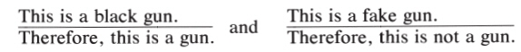

这种解释并没有说明什么*是假枪，*也没有考虑到以下蕴含关系：

What such an account does not do is to say what a fake gun *is.* It does not account for entailments like:

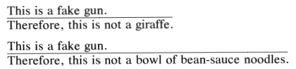

以及以及……

And on and on . . .

为了解释如此冗长的蕴含关系，我们需要详细阐述“假枪”是如何修饰“枪”这个概念的。假枪必须足够像真枪才能满足特定用途。也就是说，它必须具备与真枪在语境中相符的感知属性。你必须能够像使用真枪一样，对假枪进行足够多的相应物理操作。真枪（例如，（例如，以特定方式握持）。换句话说，假枪必须具备我们所说的真枪的*运动特性*。此外，拥有假枪的意义在于，它可以实现真枪的某些功能（例如，用于威胁、展示等）。假枪之所以是假的，是因为它不能像真枪一样*运作*。如果它能射杀你，那就是真枪。不是假枪。最后，它原本就不可能被设计成能像真枪一样使用的：一把损坏或无法使用的枪不是假枪。

To account for such an indefinitely long list of entailments, we need a detailed account of just how FAKE modifies the concept GUN. A fake gun has to look enough like a gun for the purpose at hand. That is, it has to have the contextually appropriate perceptual properties of a gun. You have to be able to perform enough of the appropriate physical manipulations that you would with a real gun (e.g., hold it a certain way). In other words, a fake gun has to maintain what we might call *motor-activity properties* of a gun. Moreover, the point of having a fake gun is that it will serve certain of the purposes that a real gun could serve (threatening, being on display, etc.). What makes a fake gun fake is that it cannot *function* like a gun. If it can shoot you, it is a real gun, not a fake gun. Finally, it cannot originally have been made to function like a gun: a broken or inoperable gun is not a fake gun.

因此，修饰词FAKE保留了GUNS的某些*属性*，同时否定了其他属性。总结如下：

Thus, the modifier FAKE preserves certain *kinds* of the properties of GUNS and negates others. To summarize:

FAKE保留了：感知属性（假枪看起来像真枪）

FAKE preserves: Perceptual properties (a fake gun looks like a gun)

运动特性（你像使用枪支一样使用它）

Motor-activity properties (you handle it like a gun)

目的性属性（它服务于）枪支的一些用途）

Purposive properties (it serves some of the purposes of a gun)

“假”否定了：功能特性（假枪不能发射）。

FAKE negates: Functional properties (a fake gun doesn't shoot)

功能历史（如果它被制造成真枪，那么它就不是假枪）

History of function (if it was made to be a real gun, then it's not a fake)

这种对“假”如何影响“枪”的概念的解释表明， “枪”的概念至少有五个维度，其中三个维度被“假”所保留，两个维度被否定。这表明我们对枪的概念化是这样的：从多维属性整体的角度来看，这些属性的维度包括感知、运动活动、目的性、功能性等等。

This account of how FAKE affects the concept of GUN indicates that the concept GUN has at least five dimensions, three of which are preserved by FAKE and two of which are negated. This suggests that we conceptualize a gun in terms of a multidimensional gestalt of properties where the dimensions are PERCEPTUAL, MOTOR ACTIVITY, PURPOSIVE, FUNCTIONAL, etc.

如果我们考察感知、运动和目的属性，就会发现它们并非枪支本身固有的属性。相反，它们与我们与枪支的互动方式有关。这表明，人们对“枪”这个概念的实际理解是……至少部分是由与感知、运动活动、目的、功能等相关的交互属性所定义的。因此，我们发现我们对物体的概念，就像我们对事件和活动的概念一样，可以被描述为多维格式塔，其维度自然地从我们在世界上的经验中涌现出来。

If we look at what perceptual, motor-activity, and purposive properties are, we see that they are not inherent in guns themselves. Instead, they have to do with the way we interact with guns. This indicates that the concept GUN, as people actually understand it, is at least partly defined by interactional properties having to do with perception, motor activity, purpose, function, etc. Thus we find that our concepts of objects, like our concepts of events and activities, are characterizable as multidimensional gestalts whose dimensions emerge naturally from our experience in the world.

分类

Categorization

从标准的客观主义观点来看，我们可以理解（因此）我们完全根据对象的一*组**固有*属性来定义对象。但是，正如我们刚才看到的，至少有一些构成我们对对象概念的属性是*互动性的。*此外，这些属性并非仅仅构成一个*集合*，而是一个*结构化的整体，*其维度自然地从我们的经验中涌现出来。

On the standard objectivist view, we can understand (and hence define) an object entirely in terms of a *set* of its *inherent* properties. But, as we have just seen, at least some of the properties that characterize our concept of an object are *interactional.* In addition, the properties do not merely form a *set* but rather a *structured gestalt,* with dimensions that emerge naturally from our experience.

The objectivist account of definition is inadequate to account for understanding in another way as well. On the objectivist view, a category is defined in terms of set theory: it is characterized by a set of inherent properties of the entities in the category. Everything in the universe is either inside or outside the category. The things that are in the category are those that have all the requisite inherent properties. Anything that fails to have one or more of the inherent properties falls outside the category.

这种基于集合论的范畴概念与人们对事物和经验进行分类的方式并不一致。对人类而言，分类主要是一种理解世界的方式，因此它必须以足够灵活的方式服务于这一目的。集合论的分类，作为一种人类分类的模型，分类方面，缺少以下内容：

This set-theoretical concept of a category does not accord with the way people categorize things and experiences. For human beings, categorization is primarily a means of comprehending the world, and as such it must serve that purpose in a sufficiently flexible way. Set-theoretical categorization, as a model for human categorization, misses the following:

1. 正如罗施（Rosch，1977）所确立的，我们根据原型对事物进行分类。对我们而言，一把典型的椅子具有清晰的靠背、座椅、四条腿，以及（可选的）两个扶手。但椅子也并非都是典型的：例如豆袋椅、吊椅、转椅、人体工学椅、理发椅等等。我们将这些非典型的椅子理解为……它们是椅子，不仅就其自身而言，而且由于它们与原型椅子的关系而成为椅子。

1. As Rosch (1977) has established, we categorize things in terms of prototypes. A prototypical chair, for us, has a well-defined back, seat, four legs, and (optionally) two armrests. But there are nonprototypical chairs as well: beanbag chairs, hanging chairs, swivel chairs, contour chairs, barber chairs, etc. We understand the nonprototypical chairs as being chairs, not just on their own terms, but by virtue of their relation to a prototypical chair.

2. 我们之所以将豆袋椅、理发椅和人体工学椅视为椅子，并非因为它们与原型椅子共享某些固定的定义属性，而是因为它们与原型椅子具有足够的家族相似性。豆袋椅可能与原型椅子在某些方面相似。这与理发椅有所不同。豆袋椅和理发椅并不一定需要具备原型椅所共有的*固定核心属性。然而，它们都是椅子，因为它们各自以不同的方式与原型椅足够接近。*

2. We understand beanbag chairs, barber chairs, and contour chairs as being chairs, not because they share some fixed set of defining properties with the prototype, but rather because they bear a sufficient family resemblance to the prototype. A beanbag chair may resemble a prototypical chair in a different way than a barber chair does. There need be *no fixed core* of properties of prototypical chairs that are shared by both beanbag and barber chairs. Yet they are both chairs because each, in its different way, is sufficiently close to the prototype.

3. 在决定家族相似性的众多属性中，互动属性尤为突出。椅子椅子与凳子和其他类型的座椅一样，都具有让我们坐下的功能。但椅子所允许的运动范围通常与凳子和其他座椅不同。因此，与我们理解椅子相关的交互属性包括感知属性（外观、触感等）、功能属性（让我们坐下）和运动属性。（我们在进入和离开容器时以及在容器内时如何运用我们的身体），以及目的性功能（放松、进食、写信等）。

3. Interactional properties are prominent among the kinds of properties that count in determining sufficient family resemblance. Chairs share with stools and other kinds of seats the PURPOSIVE property of allowing us to sit. But the range of MOTOR ACTIVITIES permitted by chairs is usually different from stools and other seats. Thus the interactional properties relevant to our comprehension of chairs will include perceptual properties (the way they look, feel, etc.), functional properties (allowing us to sit), motor-activity properties (what we do with our bodies in getting in and out of them and while we’re in them), and purposive properties (relaxing, eating, writing letters, etc.).

4. 类别可以根据不同的目的，以各种方式进行系统性的扩展。有一些修饰语，称为限定词（参见 Lakoff 1975），它们用于指出某个类别的原型，并定义与该原型之间的各种关系。以下是……举几个例子：

4. Categories can be systematically extended in various ways for various purposes. There are modifiers, called hedges (see Lakoff 1975), that pick out the prototype for a category and that define various kinds of relationships to it. Here are a few examples:

卓越典范：这指的是某一类别中的典型代表。例如，知更鸟是鸟类中的卓越典范，但鸡、鸵鸟和企鹅则不是。

PAR EXCELLENCE: This picks out prototypical members of a category. For example, a robin is a bird par excellence, but chickens, ostriches, and penguins are not birds par excellence.

严格来说：这指的是那些通常属于该类别但并非典型的例子。严格来说，鸡、鸵鸟和企鹅都是鸟类，尽管它们实际上并不是鸟类。堪称鱼类中的佼佼者。鲨鱼、河豚、鲶鱼和金鱼虽然算不上鱼类中的佼佼者，但严格来说，它们都是鱼类。

STRICTLY SPEAKING: This picks out the nonprototypical cases that ordinarily fall within the category. Strictly speaking, chickens, ostriches, and penguins are birds even though they are not birds par excellence. Sharks, blowfish, catfish, and goldfish are not fish par excellence, but they are fish, strictly speaking.

通俗地说：这挑选出那些通常不属于该类别的事物，因为它们缺乏某些核心属性，但它们拥有足够多的其他属性，因此在某些情况下，将它们视为该类别的成员是合理的。严格来说，鲸鱼并不属于该类别。虽然从广义上讲，在某些情况下，它也可以被视为一种鱼。严格来说，轻便摩托车不是摩托车，但从广义上讲，轻便摩托车也可以被归类为摩托车。

LOOSELY SPEAKING: This picks out things that are not ordinarily in the category because they lack some central property but which share enough properties so that for certain purposes it could make sense to consider them category members. Strictly speaking, a whale is not a fish, though, loosely speaking, it may be considered one in certain contexts. Strictly speaking, a moped is not a motorcycle, though, loosely speaking, mopeds could be included among motorcycles.

从技术角度来看：这指的是基于某种技术目的对类别进行界定。某事物是否在技术上属于该类别，取决于对其进行分类的目的。从保险的角度来看，轻便摩托车严格来说不算摩托车，但从桥梁通行费的角度来看，它又算是摩托车。

TECHNICALLY: This circumscribes a category relative to some technical purpose. Whether something is technically in the category or not will depend on what the purpose in classifying it is. For the purpose of insurance, a moped is technically not a motorcycle, though for purposes of bridge tolls it technically is.

其他一些限定词包括：*在某种重要意义上，几乎、实际上、非常、在某种程度上、在某些方面*等等。这些不同的限定词使我们能够将事物、事件和经历置于各种各样的语境之下。分类用于各种目的，例如，以合理的方式进行实际区分，提供新的视角，以及理解看似不同的现象。

Some other hedges include *in an important sense, to all intents and purposes, a regular . . . , a veritable . . . , to the extent that . . . , in certain respects,* and many, many more. These various hedges allow us to place objects, events, and experiences under a wide variety of categories for various purposes, e.g., to draw practical distinctions in sensible ways, to provide new perspectives, and to make sense of apparently disparate phenomena.

5. 类别是开放式的。隐喻性的定义可以帮助我们更好地理解已经分类的事物和经历，或者也可能导致重新分类。例如，将“爱”视为“战争”或许能够解释……某些经历，你曾将其视为某种形式的爱的体验，但却无法将它们以任何有意义的方式联系起来。“爱即战争”的比喻也可能引导你将某些你之前从未视为爱的经历归类为爱的体验。模糊的表达方式也揭示了我们分类的开放性；也就是说，一个事物通常可以被视为属于某个类别。或者不分类，取决于我们分类的目的。虽然类别是开放式的，但分类并非随机的，因为隐喻和限定词都以系统的方式定义（或重新定义）类别。

5. Categories are open-ended. Metaphorical definitions can give us a handle on things and experiences we have already categorized, or they may lead to a recategorization. For example, viewing LOVE as WAR may make sense of certain experiences that you took as LOVE experiences of some kind or other but that you could not fit together in any meaningful way. The LOVE IS WAR metaphor may also lead you to categorize certain experiences as LOVE experiences that you had previously not viewed as such. Hedges also reveal the open-ended nature of our categories; that is, an object may often be seen as being in a category or not, depending on our purposes in classifying it. Though categories are open-ended, categorization is not random, since both metaphors and hedges define (or redefine) categories in systematic ways.

概括

Summary

我们认为，要解释人们如何理解自身经验，需要一种与标准解释截然不同的定义观。一种基于经验的定义理论……对于需要定义的事物以及定义本身，我们持有不同的观点。在我们看来，单个概念并非孤立地定义，而是根据它们在自然经验中所扮演的角色来定义的。概念的定义并非仅仅基于其固有属性，而是主要基于其互动属性。最后，定义并非简单地赋予某种事物。概念的应用并非由一套固定的必要且充分条件构成（尽管在某些特殊情况下，例如科学或其他技术学科中，这或许可行，但即便如此也并非总是如此）；相反，概念是由原型以及与原型的关系类型所定义的。概念并非僵化地定义，而是源于我们的经验。它们是开放式的。隐喻和限定语是系统性的手段，用于进一步定义概念并改变其适用范围。

We have argued that an account of how people understand their experiences requires a view of definition very different from the standard account. An experiential theory of definition has a different notion of what needs to be defined and what does the defining. On our account, individual concepts are not defined in an isolated fashion, but rather in terms of their roles in natural kinds of experiences. Concepts are not defined solely in terms of inherent properties; instead, they are defined primarily in terms of interactional properties. Finally, definition is not a matter of giving some fixed set of necessary and sufficient conditions for the application of a concept (though this may be possible in certain special cases, such as in science or other technical disciplines, though even there it is not always possible); instead, concepts are defined by prototypes and by types of relations to prototypes. Rather than being rigidly defined, concepts arising from our experience are open-ended. Metaphors and hedges are systematic devices for further defining a concept and for changing its range of applicability.

20

20

隐喻如何赋予形式意义

How Metaphor Can Give Meaning to Form

我们说话时遵循线性顺序；在一个句子中，有些词在前，有些词在后。由于说话与时间相关，而时间又被隐喻地用空间来概念化，因此我们很自然地会用空间隐喻的方式来概念化语言。我们的书写系统强化了这种概念化。写下一个句子使我们能够……我们更容易将其概念化为一个空间对象，其中的词语呈线性排列。因此，我们的空间概念自然而然地适用于语言表达。我们知道哪个词位于句子的*首位*，两个词是彼此*靠近还是**相距甚远，*一个词是相对*较长*还是相对*较短。*

We speak in linear order; in a sentence, we say some words earlier and others later. Since speaking is correlated with time and time is metaphorically conceptualized in terms of space, it is natural for us to conceptualize language metaphorically in terms of space. Our writing system reinforces this conceptualization. Writing a sentence down allows us to conceptualize it even more readily as a spatial object with words in a linear order. Thus our spatial concepts naturally apply to linguistic expressions. We know which word occupies the *first position* in the sentence, whether two words are *close* to each other or *far apart,* whether a word is relatively *long* or *short.*

因为我们以空间术语来概念化语言形式，所以这成为可能某些空间隐喻可以直接应用于句子的*形式*，正如我们从空间角度理解的那样。这可以基于我们概念系统中的一般隐喻，在形式和内容之间建立起自动的直接联系。这种联系使得形式和内容之间的关系并非任意的，句子的某些意义可能源于其具体的形式。因此，正如德怀特·博林格（1977）所言，精确的释义通常是不可能的，因为所谓的释义是以不同的形式表达的。我们现在可以对此做出解释：

Because we conceptualize linguistic form in spatial terms, it is possible for certain spatial metaphors to apply directly to the *form* of a sentence, as we conceive of it spatially. This can provide automatic direct links between form and content, based on general metaphors in our conceptual system. Such links make the relationship between form and content anything but arbitrary, and some of the meaning of a sentence can be due to the precise form the sentence takes. Thus, as Dwight Bolinger (1977) has claimed, exact paraphrases are usually impossible because the so-called paraphrases are expressed in different forms. We can now offer an explanation for this:

—我们将语言形式空间化。

—We spatialize linguistic form.

—空间隐喻适用于空间化的语言形式。

—Spatial metaphors apply to linguistic form as it is spatialized.

—语言形式本身通过空间化隐喻而被赋予了内容。

—Linguistic forms are themselves endowed with content by virtue of spatialization metaphors.

更多的形式重于内容

More of Form Is More of Content

例如，“管道”隐喻定义了形式与内容之间的空间关系：语言表达是容器，其意义是这些容器的*内容*。当我们看到实际的小容器时，我们预期它们的内容物也小。当我们看到实际的大容器时，我们通常预期它们的内容物也大。结合“管道”这个比喻，我们可以得出这样的预期：

For example, the CONDUIT metaphor defines a spatial relationship between form and content: LINGUISTIC EXPRESSIONS ARE CONTAINERS, and their meanings are the *content* of those containers. When we see actual containers that are small, we expect their contents to be small. When we see actual containers that are large, we normally expect their contents to be large. Applying this to the CONDUIT metaphor, we get the expectation:

形式越多，内容越丰富。

MORE OF FORM IS MORE OF CONTENT.

正如我们将看到的，这是一个非常普遍的原则，似乎自然而然地存在于世界各种语言中。尽管“管道”隐喻十分普遍，但我们尚不清楚它是否具有普遍性。然而，我们可以预期，每种语言中都会出现某种程度的语言空间化隐喻。无论细节如何，发现这种数量上的相关性也不足为奇。

As we shall see, this is a very general principle that seems to occur naturally throughout the world’s languages. Though the CONDUIT metaphor is widespread, we do not know yet whether it is universal. We would expect, however, that some metaphorical spatialization of language would occur in every language and, whatever the details, it would not be surprising to find such correlations of amount.

英语中“形式越多，内容越多”的一个例子是迭代：

An English example of MORE OF FORM IS MORE OF CONTENT is iteration:

He ran and ran and ran and ran.

这表明跑步的次数不止一次。

which indicates more running than just

他跑了。

He ran.

相似地，

Similarly,

他非常非常非常高。

He is very very very tall.

这表明他比……高

indicates that he is taller than

他个子很高。

He is very tall.

确实如此。延长元音也能达到同样的效果。话说

does. Extended lengthening of a vowel can have the same effect. Saying

他好大！

He is bi-i-i-i-ig!

这表明他比你所说的要大，仅仅是指他比你所说的要大。

indicates that he is bigger than you indicate when you say just

他个子很高。

He is big.

世界上许多语言都使用*重叠这种形态学手段，*即重复一个词的一个或两个音节，甚至整个词。据我们所知，世界语言中所有重叠的例子都是“MORE OF FORM”表示“MORE”的情况。内容方面。最典型的设备有：

Many languages of the world use the morphological device of *reduplication,* that is, the repetition of one or two syllables of a word, or of the whole word, in this way. To our knowledge, all cases of reduplication in the languages of the world are instances where MORE OF FORM stands for MORE OF CONTENT. The most typical devices are:

名词重叠会使单数变为复数或集合形式。

Reduplication applied to noun turns singular to plural or collective.

动词重复表示继续或完成。

Reduplication applied to verb indicates continuation or completion.

形容词的重复表示加强或增加。

Reduplication applied to adjective indicates intensification or increase.

重复用于表示小事物的词语，表示减少。

Reduplication applied to a word for something small indicates diminution.

概括如下：

The generalization is as follows:

名词代表物体属于某一特定类别。  
该名词的“更多”表示该类别的更多对象。

A noun stands for an object of a certain kind.  
More of the noun stands for more objects of that kind.

动词表示一个动作。  
动词的更多形式表示该动作的更多形式（或许直至完成）。

A verb stands for an action.  
More of the verb stands for more of the action (perhaps until completion).

形容词代表某种属性。  
形容词越多，表示该属性越强。

An adjective stands for a property.  
More of the adjective stands for more of the property.

一个词代表较小的事物。  
这个词的更多部分代表更小的事物。

A word stands for something small.  
More of the word stands for something smaller.

亲近程度即效果强度

Closeness Is Strength of Effect

一种更为微妙的方式英语中就存在隐喻赋予形式意义的例子（可能其他语言中也有，尽管尚未进行详细研究）。英语有传统的隐喻。

A much subtler example of the way metaphor gives meaning to form occurs in English (and possibly in other languages as well, though detailed studies have not been done). English has the conventional metaphor

接近程度即效果强度。

CLOSENESS IS STRENGTH OF EFFECT.

因此，这句话

Thus, the sentence

霍梅尼*身边最亲近的*人是谁？

Who are the men *closest to* Khomeini?

方法

means

对霍梅尼*影响最大的*人是谁？

Who are the men *who have the strongest effect on* Khomeini?

这里的比喻只有语义上的效果。这与“接近”一词的含义有关。然而，*这种比喻也可以应用于句子的句法形式。*原因在于，句子的句法结构所表明的一点就是两个表达方式之间的接近程度。这种接近程度是一种*形式上的接近。*

Here the metaphor has a purely semantic effect. It has to do with the meaning of the word “close.” However, *the metaphor can also apply to the syntactic form of a sentence.* The reason is that one of the things the syntax of the sentence indicates is how CLOSE two expressions are to each other. The CLOSENESS is one of *form.*

这个比喻可以用来描述形式与意义之间的关系，具体如下：

This metaphor can apply to the relation between form and meaning in the following way:

如果表格 A 的含义影响那么，对于形式*B*的含义，形式*A*与形式B越接近*，形式**A*的含义对形式*B*的含义的影响就越强。

If the meaning of form A affects the meaning of form *B,* then, the CLOSER form *A* is to form *B,* the STRONGER will be the EFFECT of the meaning of *A* on the meaning of *B.*

例如，像*“not”*这样的句子否定词具有否定谓词的效果，如：

For example, a sentential negative like *not* has the effect of negating a predicate, as in

约翰要到明天*才会离开。*

John *won’t* leave until tomorrow.

*n't*形式对 leave 形式的谓词具有否定作用*。*

The form *n’t* has the effect of negation on the predicate with the form *leave.*

英语中有一条规则，有时被称为*否定运输规则。*这样做的效果是将否定词与其逻辑上否定的谓词拉得更远；例如，

There is a rule in English, sometimes called *negative transportation,* which has the effect of placing the negative further away from the predicate it logically negates; for example,

玛丽认为他要到明天*才会**离开。*

Mary does*n’t* think he’ll *leave* until tomorrow.

这里*“n't”*逻辑上否定了*“离开”*而不是*“思考”。*这句话的意思大致相同，

Here *n’t* logically negates *leave* rather than *think.* This sentence has roughly the same meaning as

玛丽认为他要到明天*才会离开。*

Mary thinks he wo*n’t leave* until tomorrow.

但第一句话中，否定词是“further away”，*它*有一个否定的力量较弱。在第二句中，否定词离得更近，否定的力量反而更强。

except that in the first sentence, where the negative is FURTHER AWAY from *leave,* it has a WEAKER negative force. In the second sentence, where the negative is CLOSER, the force of negation is STRONGER.

卡尔·齐默（私人交流）观察到，同样的原则也适用于诸如此类的差异。

Karl Zimmer (personal communication) has observed that the same principle governs differences like

哈利很不高兴。

Harry is not happy

*相对*

*versus*

哈利不开心。

Harry is unhappy.

否定前缀*un-*比单独的单词not更接近形容词*happy* *。在**“哈利不快乐”这*句话中，否定效果更强。比哈利*不高兴的情况要好得多。“不高兴”*意味着*悲伤，*而*“不快乐”*则可以解释为中性状态——既不高兴也不悲伤，而是介于两者之间。这体现了否定词和否定词缀之间的区别，无论是在英语还是其他语言中都是如此。

The negative prefix *un-* is closer to the adjective *happy* than is the separate word *not.* The negative has a stronger effect in *Harry is unhappy* than in *Harry is not happy. Unhappy* means *sad,* while *not happy* is open to the interpretation of being neutral—neither happy nor sad, but in between. This is typical of the difference between negatives and negative affixes, both in English and in other languages.

以下例子也运用了同样的比喻：

The same metaphor can be seen at work in the following examples:

我*教*哈利希腊语*。*

I *taught* Greek to *Harry.*

我教*哈利希腊语。*

I taught *Harry Greek.*

在第二句中，如果*“教导”*和*“哈利”*之间的距离更近，则更能暗示哈利确实学到了所学的内容——也就是说，教导对他产生了影响。以下例子则更为微妙：

In the second sentence, where *taught* and *Harry* are closer, there is more of a suggestion that Harry actually learned what was taught him—that is, that the teaching had an effect on him. The following examples are even subtler:

我觉得这把椅子很舒服。

I found that the chair was comfortable.

我觉得椅子很舒服。

I found the chair comfortable.

*第二句话表明，我是通过直接体验*——坐上去——才发现椅子很舒服。*第一句话留下了我间接*发现椅子舒适的可能性——比如，通过询问他人或参与调查。在第二句话中，“*我”*这个形式更接近*“椅子”*和“舒适”这两个形式*。*句子的句法表明，我是通过与椅子的直接接触才发现椅子舒适的。*“我”*这个形式越接近*“椅子”*和“舒适”这两个形式*，*所指的体验越直接，效果就越好。这里，句法的作用在于表明体验的直接性，而闭合性则表明了这种效果的强度。Borkin（即将出版）详细证实了英语中的这种现象。

The second sentence indicates that I found out that the chair was comfortable *by direct experience*—by sitting in it. The first sentence leaves open the possibility that I found it out *indirectly*—say, by asking people or taking a survey. In the second sentence, the form *I* is CLOSER to the forms *the chair* and *comfortable.* The syntax of the sentence indicates the directness of the experience with the chair by which I found that the chair was comfortable. The CLOSER the form *I* is to the forms *the chair* and *comfortable,* the more direct is the experience that is indicated. Here the effect of the syntax is to indicate the directness of the experience, and CLOSENESS indicates the STRENGTH OF that EFFECT. This phenomenon in English is verified in detail by Borkin (in press).

同样的比喻也可以运用在以下例子中：

The same metaphor can be seen at work in examples like:

山姆杀了哈利。

Sam killed Harry.

山姆害死了哈利。

Sam caused Harry to die.

如果原因是单一事件，例如第一句话中，因果关系更为直接。第二句话则表明了间接或远因关系——两个独立的事件：哈利的死以及山姆导致哈利死亡的行为。如果想要表达更加间接的因果关系，可以这样说：

If the cause is a single event, as in the first sentence, the causation is more direct. The second sentence indicates indirect or remote causation—two separate events, Harry’s death and what Sam did to cause it. If one wants to indicate causation that is even more indirect, one can say:

是山姆导致了哈利的死亡。

Sam brought it about that Harry died.

*这些句子中的句法作用*在于表明因果*关系的直接程度。*山姆做了这件事，以及哈利后来的遭遇。其中的原理是这样的：

The *effect that the syntax has* in these sentences is to indicate *how direct the causal link is* between what Sam did and what happened to Harry. The principle at work is this:

表示因果关系的形式与表示结果的形式越接近，因果关系就越强。

The CLOSER the form indicating CAUSATION is to the form indicating the EFFECT, the STRONGER the causal link is.

在*“Sam killed Harry”这句话中，*只有一个词形——“ *kill”* ——既表示原因又表示结果（死亡）。表达这个意思的词形非常接近：一个词包含了两者。这表明因果关系尽可能强：这是一个单一事件。在*“Sam caused Harry to die”中，*有两个独立的词*——cause*和*die——*分别表示原因和结果。这表明原因和结果之间的联系并不像它应该的那样强——原因和结果并非同一事件的一部分。在*“Sam bring it about that Harry death”中，*有两个独立的从句：*Sam bring它*与*哈利的死有关，*这表明因果关系更弱。

In *Sam killed Harry,* there is only a single form—the word *kill*—to indicate both the CAUSATION and the EFFECT (death). The forms for this meaning are as close as they can be: one word includes them both. This indicates that the causal link is as strong as it could be: a single event. In *Sam caused Harry to die,* there are two separate words—*cause* and *die*—indicating cause and effect. This indicates that the link between the cause and the effect is not as strong as it could be—the cause and the effect are not part of the same event. In *Sam brought it about that Harry died,* there are two separate clauses: *Sam brought it about* and *that Harry died,* which indicates a still weaker causal link.

总之，在所有这些例子中，形式的差异都暗示着意义上的细微差别。这种细微差别究竟是什么，可以用“接近即效果强”这个比喻来解释，其中“接近”指的是句子句法要素之间的相似性，而“效果强”指的是句子的含义。这接近程度与形式有关，而效果强度与意义有关。因此，“接近程度即效果强度”这一隐喻是我们正常概念体系的一部分，它既可以纯粹从语义角度出发，例如在句子“谁是霍梅尼身边最亲近的人？”中，也可以将*形式*与*意义联系起来，*因为接近程度可以表明句子中两种*形式*之间存在某种关联。因此，我们在以上例子中看到的细微的含义差别，并非英语特殊规则的结果，而是我们概念体系中自然而然地应用于语言*形式的隐喻的结果。*

In summary, in all of these cases a difference in form indicates a subtle difference in meaning. Just what the subtle differences are is given by the metaphor CLOSENESS IS STRENGTH OF EFFECT, where CLOSENESS applies to elements of the syntax of the sentence, while STRENGTH OF EFFECT applies to the meaning of the sentence. The CLOSENESS has to do with form, while the STRENGTH OF EFFECT has to do with meaning. Thus the metaphor CLOSENESS IS STRENGTH OF EFFECT, which is part of our normal conceptual system, can work either in purely semantic terms, as in the sentence “Who are the men closest to Khomeini?,” or it can link *form* to *meaning,* since CLOSENESS can indicate a relation holding between two *forms* in a sentence. The subtle shades of meaning that we see in the examples given above are thus the consequences not of special rules of English but of a metaphor that is in our conceptual system applying naturally to the *form* of the language.

ME -FIRST导向

The ME-FIRST Orientation

库珀和罗斯（1975）指出，我们文化中对本文化典型成员的看法决定了概念的取向。在我们的概念体系中，典型人物构成了一个概念参照点，我们概念体系中的大量概念都取决于它们是否与原型人物的属性相似。由于人们通常保持*直立*姿势，向前看、*向前移动，*大部分时间都在进行*各种活动，*并且总是以自我为中心看待事物。本质上*，我们倾向于认为自己是善良的，*这源于我们的经验，让我们觉得我们更倾向于向上而非向下，更倾向于向前而非向后，更倾向于主动而非被动，更倾向于善良而非邪恶。既然我们身处当下，存在于此时此刻，我们便认为自己存在于此而非彼，存在于此时而非彼时。这决定了库珀和罗斯所说的“自我优先”取向：向上、向前、主动、善良。“这里”和“现在”都是以标准人称为中心；“向下”、“向后”、“被动”、“坏”、“那里”和“然后”都是以反标准人称为中心。

Cooper and Ross (1975) observe that our culture’s view of what a prototypical member of our culture is like determines an orientation of concepts within our conceptual system. The canonical person forms a conceptual reference point, and an enormous number of concepts in our conceptual system are oriented with respect to whether or not they are similar to the properties of the prototypical person. Since people typically function in an *upright* position, see and move *frontward,* spend most of their time performing *actions,* and view themselves as being basically *good,* we have a basis in our experience for viewing ourselves as more UP than DOWN, more FRONT than BACK, more ACTIVE than PASSIVE, more GOOD than BAD. Since we are where we are and exist in the present, we conceive of ourselves as being HERE rather than THERE, and NOW rather than THEN. This determines what Cooper and Ross call the ME-FIRST orientation: UP, FRONT, ACTIVE, GOOD, HERE, and NOW are all oriented toward the canonical person; DOWN, BACKWARD, PASSIVE, BAD, THERE, and THEN are all oriented away from the canonical person.

这种文化取向与以下事实相关：英语中某些词序比其他词序更正常：

This cultural orientation correlates with the fact that in English certain orders of words are more normal than others:

[output not shown]

总原则是：相对于原型人物的属性而言，含义最接近的词排在最前面。

The general principle is: Relative to the properties of the prototypical person, the word whose meaning is NEAREST comes FIRST.

这条原则阐述了形式与内容之间的关联。与我们目前为止看到的其他原则一样，它源于我们正常概念体系中的一种隐喻：最近的即是首先，例如，假设你在照片中指出某人。如果你说

This principle states a correlation between form and content. Like the other principles that we have seen so far, it is a consequence of a metaphor in our normal conceptual system: NEAREST IS FIRST. For example, suppose you are pointing out someone in a picture. If you say

比尔左边第一个人是萨姆*。*

The *first* person on Bill’s left is Sam.

你的意思是

you mean

站在比尔左边、离他*最近的人是萨姆。*

The person who is on Bill’s left and *nearest* to him is Sam.

总结一下：因为我们说话是按顺序进行的，所以我们必须不断地选择先说哪个词。如果要在*“上”和“下”*以及*“下”和“上”之间随机选择，*我们会自动选择*“上”。向下。在*“向上”和“向下”这两个概念中，“向上”与典型的说话者关系最为密切。由于“最接近即最先”是我们概念体系的一部分，我们将意义最接近的词（即“*向上”*）放在首位。因此， *“向上”和“向下”的*词序比“向下”和“向上”的词序更符合我们的概念体系*。*

To summarize: Since we speak in linear order, we constantly have to choose which words to put first. Given an otherwise random choice between *up and down* and *down and up,* we automatically choose *up and down.* Of the two concepts UP and DOWN, UP is oriented NEAREST to the prototypical speaker. Since NEAREST IS FIRST is part of our conceptual system, we place the word whose meaning is NEAREST (namely, *up*) in FIRST position. The word order *up and down* is thus more coherent with our conceptual system than the order *down and up.*

有关此现象的详细描述和表观讨论。反例参见 Cooper 和 Ross (1975)。

For a detailed account of this phenomenon and a discussion of apparent counterexamples, see Cooper and Ross (1975).

语法中的隐喻连贯性

Metaphorical Coherence in Grammar

*乐器是伴侣*

*An Instrument Is a Companion*

孩子玩玩具时，常常会像对待伙伴一样对待它，跟它说话，晚上把它放在枕边等等。娃娃就是专门为此目的设计的玩具。成年人也会有类似的行为，他们会把某些重要的乐器当作伴侣。就像把汽车和枪支当作伙伴一样，给它们取名字，和它们说话等等。同样地，在我们的概念体系中，也存在着“工具即伙伴”这种传统的比喻，以下例子可以说明这一点：

It is common for a child playing with a toy to act toward it as if it were a companion, talking to it, putting it on his pillow next to him at night, etc. Dolls are toys designed especially for this purpose. Behavior like this occurs in adults, who treat certain significant instruments like cars and guns as companions, giving them names, talking to them, etc. Likewise, in our conceptual system, there is the conventional metaphor AN INSTRUMENT IS A COMPANION, which is reflected in the following examples:

乐器是伴侣

AN INSTRUMENT IS A COMPANION

我和我的老雪佛兰一起游历了美国很多地方。

Me and my old Chevy have seen a lot of the country together.

问：谁能阻止我？

Q: Who’s gonna stop me?

A：我和老贝茜在这儿呢（牛仔伸手说道）他的枪]。

A: Me and old Betsy here [said by the cowboy reaching for his gun].

多梅尼科将带着他那把价值连城的斯特拉迪瓦里小提琴去巡回演出。

Domenico is going on tour with his priceless Stradivarius.

魔术师斯利佐和他的魔术口琴今晚将在里亚托剧院演出。

Sleezo the Magician and his Magic Harmonica will be performing tonight at the Rialto.

为什么*“With”*既表示乐器演奏也表示伴奏

Why *With* Indicates Both INSTRUMENTALITY and ACCOMPANIMENT

*在英语中， with*一词表示“伴随”，例如：

The word *with* indicates ACCOMPANIMENT in English, as in:

*我和*莎莉一起去看电影了。（伴侣）

I went to the movies *with* Sally. (COMPANION)

*它用“with”*而不是其他表示陪伴的词语，这一事实表明了这一点。“with”是英语中一种任意的约定。在其他语言中，其他词语（或语法手段，例如词尾变化）表示伴随（例如法语中的*“avec”*）。但鉴于*“with* ”在英语中表示伴随，*那么它*也表示工具性就并非偶然了，例如：

The fact that it is *with* and not some other word that indicates ACCOMPANIMENT is an arbitrary convention of English. In other languages, other words (or grammatical devices like case endings) indicate ACCOMPANIMENT (e.g., *avec* in French). But given the fact that *with* indicates ACCOMPANIMENT in English, it is no accident that *with* also indicates INSTRUMENTALITY, as in:

*我用刀把*萨拉米香肠切片。（乐器）

I sliced the salami *with* a knife. (INSTRUMENT)

这并非随意之举，原因在于我们的概念该系统以“乐器即伴侣”这一隐喻为结构基础。英语中表示“陪伴”的词也表示“工具性”，这是一个*系统性的*而非*偶然的事实*。这一英语语法事实与英语的概念体系*相一致*。

The reason that this is not arbitrary is that our conceptual system is structured by the metaphor AN INSTRUMENT IS A COMPANION. It is a *systematic,* not an *accidental,* fact about English that the same word that indicates ACCOMPANIMENT also indicates INSTRUMENTALITY. This grammatical fact about English is *coherent* with the conceptual system of English.

事实上，这不仅仅是英语特有的事实。除少数例外情况外，以下原则普遍适用。用世界上所有语言来说：

As it happens, this is not merely a fact about English. With few exceptions, the following principle holds in all the languages of the world:

表示“伴随”的词语或语法手段也表示“工具性”。

The word or grammatical device that indicates ACCOMPANIMENT also indicates INSTRUMENTALITY.

由于“乐器即伴侣”这一比喻所依据的经验很可能是普遍存在的，因此这一语法原则在大多数语言中都成立也就不足为奇了。那些符合这一原则的语言与这一比喻相符；这些语言如果某个原则不成立，则与这种比喻不符。如果某种语言中不存在“乐器即伴侣”这种连贯性，通常会用其他概念连贯性来代替。因此，有些语言中， “乐器”用动词“*使用*”的某种形式来表示，或者用表示“和”的词来表示“伴侣*”。*这些都是其他非比喻性的方式。形式可以与内容保持一致。

Since the experiences on which the metaphor AN INSTRUMENT IS A COMPANION are based are likely to be universal, it is natural that this grammatical principle holds in most languages. Those languages where the principle holds are coherent with the metaphor; those languages where the principle does not hold are not coherent with this metaphor. Where the INSTRUMENT IS A COMPANION coherence does not appear in a language, it is common for some other conceptual coherence to appear in its place. Thus, there are languages where INSTRUMENT is indicated by a form of the verb *use* or where ACCOMPANIMENT is indicated by the word for *and.* These are other, nonmetaphorical, ways in which form may be coherent with content.

*语言的“逻辑”*

*The “Logic” of a Language*

用同一个词来表示工具性和伴奏是合理的。这使得形式与内容之间的联系与语言的概念体系保持一致。同样，使用像*in*和*at*这样的空间词来表达时间（例如，一小时*后*，*十*点钟）也是合理的，因为时间本身就是一种隐喻。以空间为概念框架。概念系统中的隐喻表明概念之间存在连贯且系统的关系。相同词语的使用以及对于具有系统隐喻对应关系的概念（如时间和空间），语法手段是语言中形式与意义之间的对应关系是“合乎逻辑的”而不是任意的。

The use of the same word to indicate INSTRUMENTALITY as well as ACCOMPANIMENT makes sense. It makes such form-content links coherent with the conceptual system of the language. Similarly, the use of spatial words like *in* and *at* for time expressions (e.g., *in* an hour, *at* ten o’clock) makes sense given that TIME is metaphorically conceptualized in terms of SPACE. Metaphors in the conceptual system indicate coherent and systematic relationships between concepts. The use of the same words and grammatical devices for concepts with systematic metaphorical correspondences (like TIME and SPACE) is one of the ways in which the correspondences between form and meaning in a language are “logical” rather than arbitrary.

结论

Conclusion

*含义上的细微差别*

*Subtle Variations in Meaning*

释义是否可能？两个不同的句子有可能表达完全相同的意思吗？德怀特·博林格毕生致力于证明这几乎是不可能的，句子中几乎任何改变——无论是词序、词汇、语调还是语法结构的改变——都会改变句子的含义，尽管这种改变往往很微妙。现在我们能够理解*为什么*会这样了。

Is paraphrase possible? Can two different sentences ever mean exactly the same thing? Dwight Bolinger has spent most of his career showing that this is virtually impossible and that almost any change in a sentence—whether a change in word order, vocabulary, intonation, or grammatical construction—will alter the sentence’s meaning, though often in a subtle way. We are now in a position to see *why* this should be so.

我们以空间隐喻的方式概念化句子，认为语言形式的要素具有空间属性（如长度）和关系（如接近程度）。因此，我们概念系统中固有的空间隐喻（如“接近程度即效果强度”）会自动构建形式与内容之间的关系。句子意义的某些方面源于语言中某些相对任意的约定俗成，而另一些方面则源于我们自然而然地试图使所说的话与我们的概念体系保持一致。这包括我们表达事物的*形式*，因为这种形式是以空间概念来构建的。

We conceptualize sentences metaphorically in spatial terms, with elements of linguistic form bearing spatial properties (like length) and relations (like closeness). Therefore, the spatial metaphors inherent in our conceptual system (like CLOSENESS IS STRENGTH OF EFFECT) will automatically structure relationships between form and content. While some aspects of the meaning of a sentence are consequences of certain relatively arbitrary conventions of the language, other aspects of meaning arise by virtue of our natural attempt to make what we say coherent with our conceptual system. This includes the *form* that we say things in, since that form is conceptualized in spatial terms.

*语言形式的规律*

*Regularities of Linguistic Form*

我们已经看到，隐喻在描述语言形式的规律性方面发挥着重要作用。其中一种规律是使用同一个词来表示伴奏和乐器。这种规律与“乐器是伙伴”这一概念隐喻相一致。许多我们感知到的“自然”规律语言形式的规律性是与我们概念中的隐喻相一致的规律。例如，疑问句通常以我们认为的“升调”结尾，而陈述句通常以我们认为的“降调”结尾。

We have seen that metaphors play an important role in characterizing regularities of linguistic form. One such regularity is the use of the same word to indicate both accompaniment and instrumentality. This regularity is coherent with the conceptual metaphor INSTRUMENTS ARE COMPANIONS. Many of what we perceive as “natural” regularities of linguistic form are regularities that are coherent with metaphors in our conceptual system. Take, for example, the fact that questions typically end in what we perceive as a “rising” intonation, while statements typically end in what we perceive as a “falling” intonation.

这与“未知在上，已知在下”的方位隐喻相一致。这种概念隐喻可以在以下例子中看到：

This is coherent with the orientational metaphor UNKNOWN IS UP; KNOWN IS DOWN. This conceptual metaphor can be seen in examples like:

这件事目前还*悬而未决。*

That’s still *up in the air.*

我想就此*提出一些问题。*

I’d like to *raise* some questions about that.

问题*解决*了。

That *settles* the question.

它仍然*待售*。

It’s still *up* for grabs.

我们*来讨论一下这个问题*。

Let’s *bring it up* for discussion.

之所以在*“提出答案”*中使用动词“*来”* ，是因为答案的概念是从向下开始，到我们现在所在的地方（即向上）结束。

And the reason that the verb *come* is used in *come up with an answer* is that the answer is conceptualized as starting out DOWN and ending where we are, namely, UP.

疑问句通常表示未知的事物。因此，疑问句中使用升调与“未知即存在”的表达方式相符。而使用降调则与疑问句中使用降调。因此，陈述句的语调与“已知即下降”的原则相符。事实上，降调疑问句并非真正的疑问，而是表示陈述的反问句。例如，降调的“你永远学不会吗？”实际上是在间接地表达“你永远学不会”。同样，升调陈述句则表示不确定或无能为力。为了理解某事。例如，用升调说“你的名字叫弗雷德”表示你不确定，想要确认。用升调说“巨人队交易了马德洛克”表示你无法理解某事——它与你已知的信息不符。这些都是运用升调和降调的例子，它们与“未知即已知”的原则相一致。是向下的隐喻。

Questions typically indicate what is unknown. The use of rising intonation in questions is therefore coherent with UNKNOWN IS UP. The use of falling intonations with statements is therefore coherent with KNOWN IS DOWN. In fact, questions with falling intonation are understood not as real questions but as rhetorical questions indicating statements. For example, “Will you ever learn?” said with falling intonation is a way of saying, indirectly, “You’ll never learn.” Similarly, statements with rising intonation indicate uncertainty or inability to make sense of something. For example, “Your name’s Fred” said with rising intonation indicates that you’re not sure and want confirmation. “The Giants traded Madlock” said with rising intonation indicates an inability to make sense of something—that it doesn’t fit with what you know. These are all examples of the use of rising and falling intonation coherently with the UNKNOWN IS UP, KNOWN IS DOWN metaphor.

顺便一提，英语中的疑问词疑问句语调是下降的，例如，“约翰昨天见到了谁？”我们猜测其原因在于，大部分内容……疑问词（WH-questions）表示已知信息，只有一条信息被认为是未知的。例如，“约翰昨天见到了谁？”预设约翰昨天见到了某人。正如预期的那样，语调语言通常情况下，疑问句并不使用语调，而是使用疑问词。总的来说，如果语调用于区分疑问句和陈述句，那么升调通常用于表示未知（是非）的疑问句，降调则用于表示已知（陈述句）。

Incidentally, WH-questions in English have falling intonation, for example, “Who did John see yesterday?” Our guess as to the reason for this is that most of the content of WH-questions is known, and only a single piece of information is taken to be unknown. For instance, “Who did John see yesterday?” presupposes that John saw someone yesterday. As might be expected, tone languages generally do not use intonation to mark questions at all, usually making use of question particles. On the whole, where intonation signals the difference between questions and statements, rising intonation goes with the unknown (yes-no) questions and falling intonation with the known (statements).

诸如此类的例子表明，语言形式的规律性无法用形式术语来解释。仅凭这一点，许多此类规律只有在将概念隐喻应用于我们对语言形式的空间概念化时才能得到理解。换句话说，句法并非独立于意义，尤其与意义的隐喻层面相关。一种语言的“逻辑”建立在语言的空间化形式与概念系统之间的一致性之上，尤其与隐喻层面相关。概念体系的隐喻方面。

Examples like this indicate that regularities of linguistic form cannot be explained in formal terms alone. Many such regularities make sense only when they are seen in terms of the application of conceptual metaphors to our spatial conceptualization of linguistic form. In other words, syntax is not independent of meaning, especially metaphorical aspects of meaning. The “logic” of a language is based on the coherences between the spatialized form of the language and the conceptual system, especially the metaphorical aspects of the conceptual system.

21

21

新含义

New Meaning

我们目前讨论的隐喻都是*传统*隐喻，也就是说，它们构成了我们文化中常见的概念体系，并体现在我们的日常语言中。现在，我们想转向那些超越传统概念体系的隐喻，那些富有想象力和创造性的隐喻。这类隐喻能够赋予我们全新的理解。它们源于我们的经验。因此，它们可以赋予我们的过去、我们的日常活动以及我们的认知和信仰新的意义。

The metaphors we have discussed so far are *conventional* metaphors, that is, metaphors that structure the ordinary conceptual system of our culture, which is reflected in our everyday language. We would now like to turn to metaphors that are outside our conventional conceptual system, metaphors that are imaginative and creative. Such metaphors are capable of giving us a new understanding of our experience. Thus, they can give new meaning to our pasts, to our daily activity, and to what we know and believe.

为了理解这一点，让我们来思考一下“爱是一件合作的艺术品”这个新的比喻。鉴于我们这一代人和我们文化背景的经历，我们认为这个比喻尤其有力、深刻且贴切。原因如下：它使我们对爱的体验变得连贯——它赋予这些体验意义。我们认为，新的隐喻以与传统隐喻相同的方式赋予我们的体验意义：它们提供连贯的结构，突出某些方面，同时隐藏另一些方面。

To see how this is possible, let us consider the new metaphor LOVE IS A COLLABORATIVE WORK OF ART. This is a metaphor that we personally find particularly forceful, insightful, and appropriate, given our experiences as members of our generation and our culture. The reason is that it makes our experiences of love coherent—it makes sense of them. We would like to suggest that new metaphors make sense of our experience in the same way conventional metaphors do: they provide coherent structure, highlighting some things and hiding others.

与传统隐喻一样，新隐喻也具有蕴含意义，这些蕴含意义可能包括其他隐喻和字面陈述。例如， “爱是一件合作的艺术作品”这一比喻的内涵源于我们对“合作的艺术作品”这一概念的信念和经验。我们个人对工作和艺术的看法至少为这一比喻引申出以下内涵：

Like conventional metaphors, new metaphors have entailments, which may include other metaphors and literal statements as well. For example, the entailments of LOVE IS A COLLABORATIVE WORK OF ART arise from our beliefs about, and experiences of, what it means for something to be a collaborative work of art. Our personal views of work and art give rise to at least the following entailments for this metaphor:

爱需要付出。

Love is work.

爱是主动的。

Love is active.

爱需要合作。

Love requires cooperation.

爱需要付出。

Love requires dedication.

爱需要妥协。

Love requires compromise.

爱需要自律。

Love requires a discipline.

爱包含共同责任。

Love involves shared responsibility.

爱需要耐心。

Love requires patience.

爱情需要共同的价值观和目标。

Love requires shared values and goals.

爱需要牺牲。

Love demands sacrifice.

爱情常常带来挫折。

Love regularly brings frustration.

爱需要本能的沟通。

Love requires instinctive communication.

爱情是一种审美体验。

Love is an aesthetic experience.

爱的价值主要在于它本身。

Love is primarily valued for its own sake.

爱包含创造力。

Love involves creativity.

爱情需要共同的审美观。

Love requires a shared aesthetic.

爱无法通过以下方式获得：公式。

Love cannot be achieved by formula.

爱情在每一种情况下都是独一无二的。

Love is unique in each instance.

爱是你内心世界的表达。

Love is an expression of who you are.

爱创造现实。

Love creates a reality.

爱反映了你如何看待世界。

Love reflects how you see the world.

爱需要最大的诚实。

Love requires the greatest honesty.

爱情可能是短暂的，也可能是永恒的。

Love may be transient or permanent.

爱需要资金。

Love needs funding.

爱能从共同的努力中获得共同的审美满足。

Love yields a shared aesthetic satisfaction from your joint efforts.

这些推论中有些是比喻性的（例如，“爱是一种审美体验”）；其他一些则不然（例如，“爱包含共同责任”）。这些蕴含关系中的每一个本身可能还包含其他蕴含关系。最终形成一个庞大而连贯的蕴含关系网络，这个网络整体上可能符合也可能不符合我们对爱的体验。当这个网络符合我们的体验时，这些体验就构成了一个连贯的整体，作为该隐喻的实例。我们通过这样的隐喻所体验到的是一种这种回响沿着关联网络向下传递，唤醒并连接我们对过去爱情经历的记忆，并可能为未来的爱情提供指引。

Some of these entailments are metaphorical (e.g., “Love is an aesthetic experience”); others are not (e.g., “Love involves shared responsibility”). Each of these entailments may itself have further entailments. The result is a large and coherent network of entailments, which may, on the whole, either fit or not fit our experiences of love. When the network does fit, the experiences form a coherent whole as instances of the metaphor. What we experience with such a metaphor is a kind of reverberation down through the network of entailments that awakens and connects our memories of our past love experiences and serves as a possible guide for future ones.

让我们更具体地解释一下“爱是一件合作的艺术作品”这个比喻中的“回响”是什么意思。

Let’s be more specific about what we mean by “reverberations” in the metaphor LOVE IS A COLLABORATIVE WORK OF ART.

首先，这种比喻突出了某些特征，同时忽略了其他特征。例如，积极的一面在合作工作和艺术作品中， “工作”的概念将爱凸显出来。这需要掩盖爱的某些被动层面。事实上，在我们传统的观念体系中，爱的情感层面几乎从未被视为处于恋人主动掌控之下。即使在“爱是一段旅程”的比喻中，这种关系也被视为……就像一辆不受伴侣主动控制的车，它可能*脱轨、触礁*，甚至*原地**踏步。*在“爱即疯狂”的比喻中（“我为她疯狂”，“她让我神魂颠倒”），爱情展现出彻底的失控感。而在“爱即健康”的比喻中，爱情就像一个病人（“这是一段健康的关系”，“这是一段病态的关系”，“他们的关系……”）。在“正在复苏”的语境下，这种文化中对健康的被动理解被转移到了爱上。因此，通过关注活动的各个方面（例如，工作、创造、追求目标、建设、帮助等等），这种隐喻提供了一种重要的爱的体验的组织方式，而我们传统的观念体系却无法提供这种组织方式。

First, the metaphor highlights certain features while suppressing others. For example, the active side of love is brought into the foreground through the notion of WORK both in COLLABORATIVE WORK and in WORK OF ART. This requires the masking of certain aspects of love that are viewed passively. In fact, the emotional aspects of love are almost never viewed as being under the lovers’ active control in our conventional conceptual system. Even in the LOVE IS A JOURNEY metaphor, the relationship is viewed as a vehicle that is not in the couple’s active control, since it can be *off the tracks,* or *on the rocks,* or *not going anywhere.* In the LOVE IS MADNESS metaphor (“I’m crazy about her,” “She’s driving me wild”), there is the ultimate lack of control. In the LOVE IS HEALTH metaphor, where the relationship is a patient (“It’s a healthy relationship,” “It’s a sick relationship,” “Their relationship is reviving”), the passivity of health in this culture is transferred to love. Thus, in focusing on various aspects of activity (e.g., WORK, CREATION, PURSUING GOALS, BUILDING, HELPING, etc.), the metaphor provides an organization of important love experiences that our conventional conceptual system does not make available.

其次，这个比喻不仅仅包含其他概念，例如“工作”。或者说，追求共同目标，但它包含了这些概念的非常具体的*方面*。它并非任何工作，例如在汽车装配线上工作。它需要一种特殊的控制与放手的平衡，这种平衡适用于艺术创作，因为所追求的目标并非任何目标，而是一个共同的审美目标。尽管这种比喻可能压制“爱即疯狂”这一比喻中失控的一面，它突显了另一个方面，即在我们文化中艺术天才与疯狂之间的联系背后，隐藏着一种近乎恶魔附身的感觉。

Second, the metaphor does not merely entail other concepts, like WORK or PURSUING SHARED GOALS, but it entails very specific *aspects* of these concepts. It is not just any work, like working on an automobile assembly line, for instance. It is work that requires that special balance of control and letting-go that is appropriate to artistic creation, since the goal that is pursued is not just any kind of goal but a joint aesthetic goal. And though the metaphor may suppress the out-of-control aspects of the LOVE IS MADNESS metaphor, it highlights another aspect, namely, the sense of almost demonic possession that lies behind our culture’s connection between artistic genius and madness.

第三，因为这种比喻突出了重要的爱情经历并使其连贯一致，同时掩盖了其他爱情经历，所以这种比喻赋予了爱情新的意义。如果这个比喻所蕴含的要素对我们而言是我们爱情体验中最重要的方面，那么这个比喻就能获得真理的地位；对许多人来说，爱情*是*一件合作的艺术作品。正因如此，这个比喻才能产生反馈效应，引导我们未来的行动与这个比喻相符。

Third, because the metaphor highlights important love experiences and makes them coherent while it masks other love experiences, the metaphor gives love a new meaning. If those things entailed by the metaphor are for us the most important aspects of our love experiences, then the metaphor can acquire the status of a truth; for many people, love *is* a collaborative work of art. And because it is, the metaphor can have a feedback effect, guiding our future actions in accordance with the metaphor.

第四，隐喻之所以恰当，是因为它们认可某些行为。证明推论的合理性，并帮助我们设定目标。例如，某些行动、推论和目标受“爱是合作的艺术作品”这一比喻的指导，而非“爱是疯狂”这一比喻的指导。如果爱是疯狂，我就不会专注于维持它所需的一切。但如果爱是工作，那么它就需要行动；如果它是一件艺术作品，那么它就需要一种非常特殊*的*行动。如果是合作项目，那么限制和规定就更加严格了。

Fourth, metaphors can thus be appropriate because they sanction actions, justify inferences, and help us set goals. For example, certain actions, inferences, and goals are dictated by the LOVE IS A COLLABORATIVE WORK OF ART metaphor but not by the LOVE IS MADNESS metaphor. If love is madness, I do not concentrate on what I have to do to maintain it. But if it is work, then it requires activity, and if it is a work of art, it requires a very special *kind* of activity, and if it is collaborative, then it is even further restricted and specified.

第五，一个比喻对我而言的意义，一部分取决于文化背景，一部分取决于我的过往经历。文化差异可能非常巨大，因为所讨论的比喻中的每个概念——艺术、工作、合作和爱——在不同的文化中都可能存在显著差异。因此，爱是对于一位十九世纪的欧洲浪漫主义者和一位同时生活在格陵兰岛的爱斯基摩人来说，“合作艺术作品”的含义截然不同。即使在同一文化内部，由于个体对工作和艺术的看法不同，其含义也会有所差异。 “爱情是一件合作艺术作品”这句话对于两个十四岁的初次约会者来说，与对于一位成熟的爱人来说，其意义也大相径庭。艺术家夫妇。

Fifth, the meaning a metaphor will have for me will be partly culturally determined and partly tied to my past experiences. The cultural differences can be enormous because each of the concepts in the metaphor under discussion—ART, WORK, COLLABORATION, and LOVE—can vary widely from culture to culture. Thus, LOVE IS A COLLABORATIVE WORK OF ART would mean very different things to a nineteenth-century European Romantic and an Eskimo living in Greenland at the same time. There will also be differences within a culture based on how individuals differ in their views of work and art. LOVE IS A COLLABORATIVE WORK OF ART will mean something very different to two fourteen-year-olds on their first date than to a mature artist couple.

为了说明隐喻的含义如何在不同的文化中产生巨大差异，让我们考虑一下，对于一个艺术观念与我们截然不同的人来说，这个隐喻可能意味着什么。这个人非常珍视一件艺术作品。艺术本身并非为了存在，而仅仅作为展示的对象；认为艺术创造的只是幻觉而非现实的人，可能会将以下内容视为必然结果。比喻：

As an example of how the meaning of a metaphor may vary radically within a culture, let us consider some entailments of the metaphor for someone with a view of art very different from our own. Someone who values a work of art not for itself but only as an object for display and someone who thinks that art creates only an illusion, not reality, could see the following as entailments of the metaphor:

爱情是一件需要摆出来展示的物品。

Love is an object to be placed on display.

爱的存在就是为了让他人评判和欣赏。

Love exists to be judged and admired by others.

爱情会制造幻觉。

Love creates an illusion.

爱需要隐藏真相。

Love requires hiding the truth.

因为这个人对艺术的看法与我们不同，所以这个比喻对他来说也会有不同的意义。如果他对爱情的体验和我们差不多，那么这个比喻就完全不适用。事实上，它会非常不恰当。因此，能为我们的经历赋予新意义的比喻，对他的经历却不会赋予新意义。

Because such a person’s view of art is different, the metaphor will have a different meaning for him. If his experience of love is pretty much like ours, then the metaphor simply will not fit. In fact, it will be grossly inappropriate. Hence, the same metaphor that gives new meaning to our experiences will not give new meaning to his.

另一个比喻如何为我们创造新意义的例子纯属偶然。一位伊朗学生刚到伯克利不久，就参加了我们其中一位教授开设的比喻研讨课。他在伯克利发现的奇妙事物中，就包括他反复听到并理解的一个表达。这是一种绝妙而理智的比喻。这个表达是“我问题的解决之道”——他将其理解为一大瓶冒着泡、冒着烟的液体，其中包含着你所有的问题，要么溶解在液体中，要么以沉淀物的形式存在，催化剂不断地溶解一些问题（暂时如此），并使另一些问题沉淀出来。他非常失望地发现，居民们……伯克利当时并没有想到这种化学隐喻。但他或许正是想到了，因为化学隐喻既优美又富有洞见。它让我们看到，问题永远不会彻底消失，也无法一劳永逸地解决。你所有的问题始终存在，只是它们可能溶解在溶液中，也可能以固体的形式存在。你所能期望的最好结果，就是找到一种……这种催化剂能解决一个问题，而不会引发另一个问题。但由于你无法完全控制溶液的成分，你会不断发现新旧问题再次出现。目前存在的问题正在逐渐消失，部分原因是由于你的努力，部分原因是尽管你做了一些事情，问题依然存在。

Another example of how a metaphor can create new meaning for us came about by accident. An Iranian student, shortly after his arrival in Berkeley, took a seminar on metaphor from one of us. Among the wondrous things that he found in Berkeley was an expression that he heard over and over and understood as a beautifully sane metaphor. The expression was “the solution of my problems”—which he took to be a large volume of liquid, bubbling and smoking, containing all of your problems, either dissolved or in the form of precipitates, with catalysts constantly dissolving some problems (for the time being) and precipitating out others. He was terribly disillusioned to find that the residents of Berkeley had no such chemical metaphor in mind. And well he might be, for the chemical metaphor is both beautiful and insightful. It gives us a view of problems as things that never disappear utterly and that cannot be solved once and for all. All of your problems are always present, only they may be dissolved and in solution, or they may be in solid form. The best you can hope for is to find a catalyst that will make one problem dissolve without making another one precipitate out. And since you do not have complete control over what goes into the solution, you are constantly finding old and new problems precipitating out and present problems dissolving, partly because of your efforts and partly despite anything you do.

化学隐喻为我们提供了一种看待人类问题的新视角。这种经验告诉我们，那些我们曾经以为已经“解决”的问题，却一次又一次地重现。化学的比喻告诉我们，问题并非那种可以永远消失的东西。把它们当作可以一劳永逸地“解决”的事情是毫无意义的。遵循化学的比喻，就等于接受了这样一个事实：没有哪个问题会真正消失。永远如此。与其将精力集中在彻底解决问题上，不如将精力集中在寻找能够长期化解最紧迫问题的催化剂，同时避免引发更严重的问题。问题的再次出现被视为一种自然现象，而不是你未能找到“正确解决方法”的失败。

The CHEMICAL metaphor gives us a new view of human problems. It is appropriate to the experience of finding that problems which we once thought were “solved” turn up again and again. The CHEMICAL metaphor says that problems are not the kind of things that can be made to disappear forever. To treat them as things that can be “solved” once and for all is pointless. To live by the CHEMICAL metaphor would be to accept it as a fact that no problem ever disappears forever. Rather than direct your energies toward solving your problems once and for all, you would direct your energies toward finding out what catalysts will dissolve your most pressing problems for the longest time without precipitating out worse ones. The reappearance of a problem is viewed as a natural occurrence rather than a failure on your part to find “the right way to solve it.”

生活如果运用化学隐喻，你的问题对你而言就具有了不同的现实意义。暂时的解决方案对你而言是一种成就，而非失败。问题会成为事物自然秩序的一部分，而非需要“治愈”的疾病。如果你以化学隐喻为指导，你理解日常生活的方式以及你的行为方式都会有所不同。

To live by the CHEMICAL metaphor would mean that your problems have a different kind of reality for you. A temporary solution would be an accomplishment rather than a failure. Problems would be part of the natural order of things rather than disorders to be “cured.” The way you would understand your everyday life and the way you would act in it would be different if you lived by the CHEMCAL metaphor.

我们认为这是一个隐喻力量的鲜明例证，它不仅能为我们提供理解既有现实的方式，更能创造现实。这并不令人惊讶。正如我们在“争论即战争”的隐喻中所看到的，有些自然活动*（*例如争论）本身就具有隐喻性质。“化学”的隐喻揭示了我们目前处理……的方式问题是另一种隐喻活动。目前，我们大多数人处理问题的方式，可以称之为“谜题隐喻”，即问题就是谜题，而这些谜题通常都有一个正确的答案。问题一旦解决，就永远解决了。“问题即谜题”这一比喻描述了我们当前的现实。而“化学”这一比喻则描述了一种全新的现实。

We see this as a clear case of the power of metaphor to create a reality rather than simply to give us a way of conceptualizing a preexisting reality. This should not be surprising. As we saw in the case of the ARGUMENT IS WAR metaphor, there are natural kinds of *activity* (e.g., arguing) that are metaphorical in nature. What the CHEMICAL metaphor reveals is that our current way of dealing with problems is another kind of metaphorical activity. At present most of us deal with problems according to what we might call the PUZZLE metaphor, in which problems are PUZZLES for which, typically, there is a correct solution—and, once solved, they are solved forever. The PROBLEMS ARE PUZZLES metaphor characterizes our present reality. A shift to the CHEMICAL metaphor would characterize a new reality.

但要改变我们赖以生存的隐喻绝非易事。意识到“化学”隐喻所蕴含的可能性是一回事，而真正践行它则截然不同，也困难得多。我们每个人都或多或少地发现了数百个问题，并且不断地运用“谜题”隐喻来寻找其中许多问题的解决方案。如此之多。我们无意识的日常活动是以拼图的隐喻来构建的，因此我们不可能通过有意识的决定，迅速或轻松地将其转变为化学的隐喻。

But it is by no means an easy matter to change the metaphors we live by. It is one thing to be aware of the possibilities inherent in the CHEMICAL metaphor, but it is a very different and far more difficult thing to live by it. Each of us has, consciously or unconsciously, identified hundreds of problems, and we are constantly at work on solutions for many of them—via the PUZZLE metaphor. So much of our unconscious everyday activity is structured in terms of the PUZZLE metaphor that we could not possibly make a quick or easy change to the CHEMICAL metaphor on the basis of a conscious decision.

我们许多活动（争论、解决问题、安排时间等等）本质上都是隐喻性的。构成这些活动的隐喻概念构建了我们当下的现实。隐喻具有创造新现实的力量。当我们开始用隐喻来理解自身经验时，这种力量便开始显现；而当我们开始运用这种隐喻去行动时，它便会成为一种更深层次的现实。如果一个新的隐喻进入我们赖以行动的概念体系，它便会改变这个概念体系，以及该体系所产生的感知和行动。许多文化变革源于新隐喻概念的引入和旧概念的消亡。例如，世界各地文化的西方化，部分原因在于将“时间就是金钱”这一隐喻引入这些文化之中。

Many of our activities (arguing, solving problems, budgeting time, etc.) are metaphorical in nature. The metaphorical concepts that characterize those activities structure our present reality. New metaphors have the power to create a new reality. This can begin to happen when we start to comprehend our experience in terms of a metaphor, and it becomes a deeper reality when we begin to act in terms of it. If a new metaphor enters the conceptual system that we base our actions on, it will alter that conceptual system and the perceptions and actions that the system gives rise to. Much of cultural change arises from the introduction of new metaphorical concepts and the loss of old ones. For example, the Westernization of cultures throughout the world is partly a matter of introducing the TIME IS MONEY metaphor into those cultures.

隐喻能够创造现实的观点与大多数传统的隐喻观相悖。原因在于，隐喻传统上被视为一种……这仅仅是语言的问题，而非主要作为构建我们概念体系和日常活动的一种手段。我们可以合理地假设，语言本身并不能改变现实。但我们概念的改变却能改变现实。系统确实会改变我们对现实的认知，并影响我们感知世界的方式以及我们根据这些感知采取的行动。

The idea that metaphors can create realities goes against most traditional views of metaphor. The reason is that metaphor has traditionally been viewed as a matter of mere language rather than primarily as a means of structuring our conceptual system and the kinds of everyday activities we perform. It is reasonable enough to assume that words alone don’t change reality. But changes in our conceptual system do change what is real for us and affect how we perceive the world and act upon those perceptions.

认为隐喻仅仅是……的问题语言充其量只能描述现实，这种观点源于这样一种认知：现实完全独立于人类对世界的理解之外，仿佛对现实的研究仅仅是对物理世界的研究。这种现实观——所谓的客观现实——忽略了现实的人类层面，特别是真实的感知、概念化、动机和情感。我们所经历的大部分都是行动。但对我们而言，现实中最重要的部分是人性层面，而这些层面因文化而异，因为不同的文化拥有不同的概念体系。文化也存在于不同的自然环境中，有些环境截然不同——丛林、沙漠、岛屿、苔原、山脉、城市等等。每一种情况都存在着特定的自然环境。我们与之互动，或多或少都能成功。不同文化的概念体系在一定程度上取决于它们所处的物理环境。

The idea that metaphor is just a matter of language and can at best only describe reality stems from the view that what is real is wholly external to, and independent of, how human beings conceptualize the world—as if the study of reality were just the study of the physical world. Such a view of reality—so-called objective reality—leaves out human aspects of reality, in particular the real perceptions, conceptualizations, motivations, and actions that constitute most of what we experience. But the human aspects of reality are most of what matters to us, and these vary from culture to culture, since different cultures have different conceptual systems. Cultures also exist within physical environments, some of them radically different—jungles, deserts, islands, tundra, mountains, cities, etc. In each case there is a physical environment that we interact with, more or less successfully. The conceptual systems of various cultures partly depend on the physical environments they have developed in.

每种文化都必须提供一套或多或少行之有效的应对环境的方式，既要适应环境，也要改变环境。此外，每种文化都必须定义一种社会现实，在这种现实中，人们扮演着对他们而言有意义的角色。他们以此为基础进行社会活动。毫不奇怪，一种文化所定义的社会现实会影响其对物理现实的理解。对于一个作为文化成员的个体而言，什么是真实的，既是其社会现实的产物，也是社会现实塑造其对物理世界体验的方式的产物。由于我们的大部分社会现实都是用隐喻的方式理解的，而且由于我们对物质世界的理解部分是隐喻性的，隐喻在决定什么是真实的方面起着非常重要的作用。

Each culture must provide a more or less successful way of dealing with its environment, both adapting to it and changing it. Moreover, each culture must define a social reality within which people have roles that make sense to them and in terms of which they can function socially. Not surprisingly, the social reality defined by a culture affects its conception of physical reality. What is real for an individual as a member of a culture is a product both of his social reality and of the way in which that shapes his experience of the physical world. Since much of our social reality is understood in metaphorical terms, and since our conception of the physical world is partly metaphorical, metaphor plays a very significant role in determining what is real for us.

22

22

相似性的创造

The Creation of Similarity

我们已经看到，我们的许多经验和活动本质上都是隐喻性的，而且我们的大部分概念体系也是由隐喻构建的。既然我们在概念体系的范畴和我们所拥有的自然经验类型（两者都可能是隐喻性的）方面都看到了相似之处，那么由此可见，许多相似之处……我们感知到的事物是构成我们概念系统一部分的传统隐喻的结果。我们已经在*方向隐喻的例子中看到了这一点。*例如，“多即向上”和“快乐即向上”这两个方向会让我们感知到“多”和“快乐”之间的相似性，而我们却不会在“少”和“快乐”之间看到这种相似性。

We have seen that many of our experiences and activities are metaphorical in nature and that much of our conceptual system is structured by metaphor. Since we see similarities in terms of the categories of our conceptual system and in terms of the natural kinds of experiences we have (both of which may be metaphorical), it follows that many of the similarities that we perceive are a result of conventional metaphors that are part of our conceptual system. We have already seen this in the case of *orientational metaphors.* For example, the orientations MORE IS UP and HAPPY IS UP induce a similarity that we perceive between MORE and HAPPY that we do not see between LESS and HAPPY.

*本体论隐喻*也使得相似性成为可能。例如，我们看到，将时间和劳动隐喻地视为同一种物质，使我们能够将它们都视为类似于物质资源，从而彼此相似。因此，“时间是一种物质”和“劳动是一种物质”的隐喻使我们能够将时间和劳动视为在我们文化中相似的，因为两者都可以量化，都可以被赋予单位价值，都可以被视为服务于某种目的，并且可以被利用。逐步上升。由于这些隐喻在我们文化中定义现实方面发挥着作用，因此时间和劳动之间的相似性既基于隐喻，又在我们文化中是真实的。

*Ontological metaphors* also make similarities possible. We saw, for example, that the viewing of TIME and LABOR metaphorically as uniform SUBSTANCES allows us to view them both as being similar to physical resources and hence as similar to each other. Thus the metaphors TIME IS A SUBSTANCE and LABOR IS A SUBSTANCE allow us to conceive of time and labor as similar in our culture, since both can be quantified, assigned a value per unit, seen as serving a purposeful end, and used up progressively. Since these metaphors play a part in defining what is real for us in this culture, the similarity between time and labor is both based on metaphor and real for our culture.

我们概念体系中的*结构隐喻也会引发相似性。因此，* “思想是食物”这一隐喻建立了思想和食物之间的相似性。两者都可以被消化、吞咽、食用和加热。结束，而且两者可以滋养你。这些相似之处并非独立于隐喻而存在。吞咽食物的概念独立于隐喻，但吞咽思想的概念却唯有通过隐喻才能产生。事实上，“思想是食物”这一隐喻建立在更为基本的隐喻之上。例如，它部分基于“管道”隐喻，根据该隐喻，“思想是”物体，我们可以从自身之外获得它们。它还假定了“心灵是容器”的隐喻，这建立了心灵和身体之间的相似性——两者都是容器。结合“管道”的隐喻，我们得到一个复杂的隐喻，在这个隐喻中，观念是进入心灵的物体，正如食物是进入身体的物体一样。正是这种隐喻所创造的相似性“思想即食物”这一比喻部分基于思想与食物之间的相似性。而且，正如我们所见，这种相似性本身又是“管道”比喻和“心灵即容器”比喻的结果。

*Structural metaphors* in our conceptual system also induce similarities. Thus, the IDEAS ARE FOOD metaphor establishes similarities between ideas and food. Both can be digested, swallowed, devoured, and warmed over, and both can nourish you. These similarities do not exist independently of the metaphor. The concept of swallowing food is independent of the metaphor, but the concept of swallowing ideas arises only by virtue of the metaphor. In fact, the IDEAS ARE FOOD metaphor is based on still more basic metaphors. For example, it is based partly on the CONDUIT metaphor, according to which IDEAS ARE OBJECTS and we can get them from outside ourselves. It also assumes the MIND IS A CONTAINER metaphor, which establishes a similarity between the mind and the body—both being CONTAINERS. Together with the CONDUIT metaphor, we get a complex metaphor in which IDEAS ARE OBJECTS THAT COME INTO THE MIND, just as pieces of food are objects that come into the body. It is this metaphorically created similarity between ideas and food that the IDEAS ARE FOOD metaphor is partly based on. And, as we have seen, the similarity itself is a consequence of the CONDUIT metaphor and the MIND IS A CONTAINER metaphor.

“思想是食物”这一比喻之所以符合我们的经验，部分原因在于这种比喻引发的相似性。因此， “思想是食物”这一比喻部分建立在“心灵是容器和管道”这一概念之上。隐喻。由于“思想是食物”这一隐喻，我们发现了思想和食物之间新的（隐喻意义上的）相似之处：两者都可以被吞咽、消化和吸收，也都能滋养我们。这些食物概念为我们理解那些我们无法直接、明确地概念化的心理过程提供了一种途径。

The IDEAS ARE FOOD metaphor fits our experience partly because of this metaphor-induced similarity. The IDEAS ARE FOOD metaphor is therefore partly grounded via the MIND IS A CONTAINER and CONDUIT metaphors. As a consequence of the IDEAS ARE FOOD metaphor, we get new (metaphorical) similarities between IDEAS and FOOD: both can be swallowed, digested, and devoured, and both can nourish you. These food concepts give us a way of understanding psychological processes that we have no direct and well-defined way of conceptualizing.

*最后，我们可以看到新隐喻*中相似性的产生。例如，“问题是化学溶液中的沉淀物”这一比喻，是基于“问题是物体”这一传统比喻。此外，“化学”这一比喻还补充了“问题是固体物体”这一限定，将其比作化学溶液中的沉淀物。由此，我们通常遇到的问题与化学溶液中的沉淀物之间存在以下相似之处：它们都具有可感知的形式因此，问题可以被识别、分析和处理。这些相似之处源于化学隐喻中“问题是固体”这一概念。此外，当沉淀物溶解时，它似乎消失了，因为它没有可感知的形态，无法被识别、分析和处理。然而，它可能再次沉淀出来，即再次出现。就像问题可能会以固态形式再次出现一样。我们之所以会将问题与沉淀物联系起来，是因为化学比喻的其他部分也印证了这一点。

Finally, we can see the creation of similarity in *new metaphors* as well. For example, the metaphor PROBLEMS ARE PRECIPITATES IN A CHEMICAL SOLUTION is based on the conventional metaphor PROBLEMS ARE OBJECTS. In addition, the CHEMICAL metaphor adds PROBLEMS ARE SOLID OBJECTS, which identifies them as the precipitates in a chemical solution. The similarities thus induced between problems as we usually experience them and precipitates in a chemical solution are: they both have a perceptible form and thus can be identified, analyzed, and acted upon. These similarities are induced by the PROBLEMS ARE SOLID OBJECTS part of the CHEMICAL metaphor. In addition, when a precipitate is dissolved, it appears to be gone because it does not have a perceptible form and cannot be identified, analyzed, and acted upon. However, it may precipitate out again, i.e., recur in solid form, just as a problem may recur. We perceive this similarity between problems and precipitates as a result of the rest of the CHEMICAL metaphor.

“爱是一件合作的艺术品”这一比喻更微妙地展现了*新隐喻*所产生的相似性。它突出了爱情体验的某些方面，淡化了另一些方面，并隐藏了其他一些方面。特别是，它淡化了那些符合“爱是一种物理力量”这一比喻的体验。所谓“淡化”，是指它与那些可以用“我们之间有种磁力”、“我们之间擦出了火花”等词语来合理描述的爱情体验相符，但并不着重强调这些体验。此外，它还隐藏了那些符合“爱是一场战争”这一比喻的爱情体验，因为两者之间不存在任何一致的重叠之处。这两个比喻之间存在着矛盾。“爱是一件合作的艺术品”这一比喻所体现的合作与协作方面，与我们爱情经历中可能被描述为“她是我最新的征服对象”、“他向她投降了”、“她让我不知所措”等的攻击性和支配性方面并不一致（因此掩盖了这些方面）。

A more subtle example of the similarities created by a *new metaphor* can be seen in LOVE IS A COLLABORATIVE WORK OF ART. This metaphor highlights certain aspects of love experiences, downplays others, and hides still others. In particular, it downplays those experiences that fit the LOVE IS A PHYSICAL FORCE metaphor. By “downplaying,” we mean that it is consistent with, but does not focus on, experiences of love that could be reasonably described by “There is a magnetism between us,” “We felt sparks,” etc. Moreover, it hides those love experiences that fit the LOVE IS WAR metaphor because there is no consistent overlap possible between the two metaphors. The collaborative and cooperative aspects of the LOVE IS A COLLABORATIVE WORK OF ART metaphor are inconsistent with (and therefore hide) the aggressive and dominance-oriented aspects of our love experiences as they might be described by “She is my latest conquest,” “He surrendered to her,” “She overwhelmed me,” etc.

通过这种方式，爱是一项合作成果艺术隐喻忽略了我们部分爱情体验，而挑选出另一些来聚焦，仿佛它们才是我们唯一的爱情体验。如此一来，它便在所强调的爱情体验与合作创作艺术作品的真实或想象体验之间，引出了一系列相似之处。这些引出的相似之处体现在我们列出的蕴含关系中（“爱即工作”、“爱是一种审美体验”）。ETC。）。

By this means, the LOVE IS A COLLABORATIVE WORK OF ART metaphor puts aside some of our love experiences and picks out others to focus on as if they were our only experiences of love. In doing so it induces a set of similarities between the love experiences it highlights and the real or imagined experiences of collaborating on a work of art. These induced similarities are given in our list of entailments (“Love is work,” “Love is an aesthetic experience,” etc.).

在众多被着重介绍的爱情经历中，每一段经验至少符合蕴含条件列表中的一项相似之处，但可能没有哪一项经验符合所有蕴含条件。例如，一段特别令人沮丧的经历符合“爱情常常带来挫折”这一条件，但可能不符合“爱情是一种审美体验”或“爱情的价值主要在于其自身”。因此，蕴含关系表明某些类型的爱情体验与某些类型的合作艺术作品体验之间存在相似性。没有任何一条蕴含关系能够展现所有*被*强调的爱情体验与合作艺术作品创作过程中涉及的所有体验之间的整体相似性。只有整个隐喻才能做到这一点。以及它所包含的整个蕴含体系，都表明了所有突出的爱情经历与所有合作创作艺术作品的经历之间的相似之处。

Within the range of highlighted love experiences, each experience fits at least one of the similarities given in the list of entailments, and probably no one of them fits all the entailments. For example, a particularly frustrating episode would fit “Love regularly brings frustration” but might not fit “Love is an aesthetic experience” or “Love is primarily valued for its own sake.” Each entailment thus states a similarity that holds between certain types of love experiences, on the one hand, and certain types of experiences of collaborative works of art, on the other. No one entailment shows the overall similarity between the *entire range* of highlighted love experiences and the range of experiences involved in producing a collaborative work of art. It is only the whole metaphor, with its entire system of entailments, that shows the similarities between the full range of highlighted love experiences and the full range of experiences of producing a collaborative work of art.

此外，这种隐喻所引发的相似性超越了两种经验范围之间的单纯相似性。这种额外的相似性是一种*结构上的*相似性。它涉及我们理解个体所强调的经历如何以一种连贯的方式相互契合。这种连贯性源于我们对合作艺术作品创作的认知结构，并体现在各个要素之间的契合方式上（例如，有些是工作的要素，有些是艺术的要素，有些是合作工作的要素，等等）。只有这种连贯性才能使作品呈现出连贯的整体。这种结构使我们能够理解所强调的经历彼此之间的关联，以及它们之间的内在联系。因此，通过这种比喻，所强调的爱情经历在*结构上*与合作创作艺术作品的经历在结构上具有相似性。

Moreover, there is a similarity induced by the metaphor that goes beyond the mere similarities between the two ranges of experience. The additional similarity is a *structural* similarity. It involves the way we understand how the individual highlighted experiences fit together in a coherent way. The coherence is provided by the structure of what we know about producing a collaborative work of art and is reflected in the way the entailments fit together (e.g., some are entailments of WORK, some are entailments of ART, some are entailments of COLLABORATIVE WORK, etc.). It is only this coherent structure that enables us to understand what the highlighted experiences have to do with each other and how the entailments are related to each other. Thus, by virtue of the metaphor, the range of highlighted love experiences is seen as similar *in structure* to the range of experiences of producing a collaborative work of art.

正是这两种经验范围之间的这种*结构相似性。*这使你能够在一系列突出的爱情经历中*找到内在的连贯性*。相应地，正是通过这种隐喻，突出的一系列这些经历被挑选出来，被认为是连贯的。如果没有这个比喻，对你来说，这一系列经历就不是一套可识别且连贯的经历。将爱概念化为一件合作的艺术作品，就能将它们带入其中。使之清晰起来，并最终融合成一个连贯的整体。

It is this *structural* similarity between the two ranges of experience that allows you to *find coherence* in the range of highlighted love experiences. Correspondingly, it is by virtue of the metaphor that the highlighted range of experiences is picked out as being coherent. Without the metaphor, this range of experiences does not exist for you as being an identifiable and coherent set of experiences. Conceptualizing LOVE as A COLLABORATIVE WORK OF ART brings them into focus as fitting together into a coherent whole.

此外，隐喻通过赋予我们的一系列经验以连贯的结构，*创造了一种新的相似性。*例如，即使不借助隐喻，我们也可能将令人沮丧的恋爱经历与和他人共同创作艺术作品的挫败感视为相似之处，因为它们都令人沮丧。从这个意义上讲，令人沮丧的恋爱经历也类似于*任何*令人沮丧的经历。这个比喻有助于我们理解令人沮丧的恋爱经历，因为它指出其中涉及的挫折感与合作创作艺术作品时所感受到的挫折感*类似*。这种相似性仅仅体现在这个比喻本身。

Moreover, the metaphor, by virtue of giving coherent structure to a range of our experiences, *creates similarities of a new kind.* For example, we might, independently of the metaphor, see a frustrating love experience as similar to a frustrating experience in producing a work of art jointly with someone, since they are both frustrating. In this sense, the frustrating love experience would also be similar to *any* frustrating experience at all. What the metaphor adds to an understanding of the frustrating love experience is that the *kind* of frustration involved is that involved in producing collaborative artworks. The similarity is similarity with respect to the metaphor.

因此，令人沮丧的相似之处的确切性质是只有从艺术体验的角度去理解爱情体验，才能真正感知爱情体验和令人沮丧的艺术体验。根据我们的定义，从创作一件合作艺术作品的角度去理解爱情体验，就是从“爱情是一件合作艺术作品”这一隐喻概念的角度去理解这种体验。

Thus the precise nature of the similarity between the frustrating love experience and the frustrating art experience is perceived only in understanding the love experience in terms of the art experience. Understanding love experiences in terms of what is involved in producing a collaborative work of art is, by our definition, to comprehend that experience in terms of the metaphorical concept LOVE IS A COLLABORATIVE WORK OF ART.

我们可以总结出以下方法：哪些比喻能产生以下相似之处：

We can summarize the ways in which metaphors create similarities as follows:

1. 传统隐喻（方向性、本体论和结构性隐喻）通常基于我们经验中感知到的相关性。例如，在我们这样的工业文化中，完成一项任务所需的时间与完成该任务所需的劳动量之间存在相关性。这种相关性正是我们能够理解事物本质的原因之一。将时间和劳动力视为资源，从而发现它们之间的相似之处。这一点很重要。请记住，相关性并不等同于相似性。基于我们经验中相关性的隐喻定义了我们感知相似性的概念。

1. Conventional metaphors (orientational, ontological, and structural) are often based on correlations we perceive in our experience. For example, in an industrial culture such as ours there is a correlation between the amount of time a task takes and the amount of labor it takes to accomplish the task. This correlation is part of what allows us to view TIME and LABOR metaphorically as RESOURCES and hence to see a similarity between them. It is important to remember that correlations are not similarities. Metaphors that are based on correlations in our experience define concepts in terms of which we perceive similarities.

2. 结构性的传统隐喻（例如，“思想是食物”）可能基于出现的相似性。源于方向性和本体论隐喻。例如，正如我们所见，“思想即食物”基于“思想即物体”（本体论）和“心灵即容器”（本体论和方向性）。“思想”和“食物”之间的结构相似性是由这一隐喻引起的，并由此产生了隐喻上的相似性（思想和食物都可以被吞咽、消化和吸收，都能提供营养等等）。

2. Conventional metaphors of the structural variety (e.g., IDEAS ARE FOOD) may be based on similarities that arise out of orientational and ontological metaphors. As we saw, for example, IDEAS ARE FOOD is based on IDEAS ARE OBJECTS (ontological) and THE MIND IS A CONTAINER (ontological and orientational). A structural similarity between IDEAS and FOOD is induced by the metaphor and gives rise to metaphorical similarities (ideas and food can be swallowed, digested, and devoured, can provide nourishment, etc.).

3. 新的隐喻大多是结构性的。它们可以像传统的结构性隐喻一样，创造相似性。也就是说，它们可以基于本体论隐喻和方向性隐喻所产生的相似性。正如我们所见，“问题是化学溶液中的沉淀物”这一隐喻就基于“问题是固体物体”这一物理隐喻。这种隐喻在两者之间创造了相似性。问题和沉淀物，因为两者都可以被识别、分析和处理。“问题即沉淀物”这一比喻创造了新的相似之处，即问题可能看似消失了（转化为解决方案），但之后又会重新出现（沉淀出来）。

3. New metaphors are mostly structural. They can create similarities in the same way as conventional metaphors that are structural. That is, they can be based on similarities that arise from ontological and orientational metaphors. As we saw, PROBLEMS ARE PRECIPITATES IN A CHEMICAL SOLUTION is based on the physical metaphor PROBLEMS ARE SOLID OBJECTS. This metaphor creates similarities between PROBLEMS and PRECIPITATES, since both can be identified, analyzed, and acted upon. The PROBLEMS ARE PRECIPITATES metaphor creates new similarities, namely, problems can appear to be gone (dissolve into solutions) and later reappear (precipitate out).

4. 新的隐喻，凭借其蕴含的意义，通过突出、淡化和隐藏等方式，选取了一系列经验。然后，隐喻就刻画了……强调所有被突出的体验与某些其他体验之间的相似性。例如，《爱是一件合作的艺术作品》选取了我们爱情体验的某个特定范围，并定义了*所有*被突出的体验与合作艺术作品创作过程中涉及的体验之间的*结构性*相似性。可能存在一些孤立的相似之处。在爱情和艺术体验之间，存在着独立于隐喻之外的联系，但隐喻使我们能够找到内在的连贯性。这些孤立的相似之处，与隐喻所引发的整体结构相似性相比，显得微不足道。

4. New metaphors, by virtue of their entailments, pick out a range of experiences by highlighting, downplaying, and hiding. The metaphor then characterizes a similarity between the entire range of highlighted experiences and some other range of experiences. For example, LOVE IS A COLLABORATIVE WORK OF ART picks out a certain range of our love experiences and defines a *structural* similarity between the *entire range* of highlighted experiences and the range of experiences involved in producing collaborative works of art. There may be isolated similarities between love and art experiences that are independent of the metaphor, but the metaphor allows us to find coherence in these isolated similarities in terms of the overall structural similarities induced by the metaphor.

5. 相似之处可能与隐喻有关。正如我们所见，“爱是一件合作的艺术品”这一隐喻定义了一种独特的*相似*性。例如，令人沮丧的爱情经历可以理解为与令人沮丧的艺术经历相似，不仅因为它们都令人沮丧，还因为它们都涉及共同创作艺术作品时特有的那种挫败感*。*

5. Similarities may be similarities with respect to a metaphor. As we saw, the LOVE IS A COLLABORATIVE WORK OF ART metaphor defines a unique *kind* of similarity. For example, a frustrating love experience may be understood as being similar to a frustrating art experience not merely by virtue of being frustrating but as involving the *kind* of frustration peculiar to jointly producing works of art.

我们认为隐喻可以创造相似性，这与经典的、也是目前最广为接受的隐喻理论——比较*理论——相悖。*比较理论他说：

Our view that metaphors can create similarities runs counter to the classical and still most widely held theory of metaphor, namely, the *comparison theory.* The comparison theory says:

1. 比喻是语言问题，而不是思想或行为问题。不存在比喻性的思想或行为。

1. Metaphors are matters of language and not matters of thought or action. There is no such thing as metaphorical thought or action.

*2. “ A*是*B* ”形式的隐喻是一种语言表达，其含义与“ *A*在*X、Y、Z*等方面像*B”*形式的相应语言表达相同。“在*X、Y、Z 等*方面……”体现了我们所说的“孤立的相似性”。

2. A metaphor of the form “*A* is *B*“ is a linguistic expression whose meaning is the same as a corresponding linguistic expression of the form “*A* is like *B,* in respects *X, Y, Z* . . . .” “Respects *X, Y, Z,* . . . ” characterize what we have called “isolated similarities.”

3. 因此，比喻只能描述已存在的相似之处，而不能创造相似之处。

3. A metaphor can therefore only describe preexisting similarities. It cannot create similarities.

尽管我们已提出证据反驳比较理论的大部分观点，但我们接受其基本洞见，即隐喻可以基于孤立的相似之处。我们与比较理论的不同之处在于：

Though we have given evidence against much of the comparison theory, we accept what we take to be its basic insight, namely, that metaphors can be based on isolated similarities. We differ with the comparison theory by maintaining that:

1. 隐喻主要是一种思想和行动，这只是语言上的衍生问题。

1. Metaphor is primarily a matter of thought and action and only derivatively a matter of language.

2.a. 隐喻可以基于相似性，但在许多情况下，这些相似性本身又基于并非基于相似性的传统隐喻。然而，基于传统隐喻的相似性*在我们的文化中仍然是真实的，*因为传统隐喻在一定程度上定义了我们认为什么是真实的。

2.a. Metaphors can be based on similarities, though in many cases these similarities are themselves based on conventional metaphors that are not based on similarities. Similarities based on conventional metaphors are nonetheless *real in our culture,* since conventional metaphors partly define what we find real.

2.b. 虽然这个比喻可能部分基于就孤立的相似之处而言，我们认为重要的相似之处是由上述比喻所创造的。

2.b. Though the metaphor may be based partly on isolated similarities, we see the important similarities as those created by the metaphor, as described above.

3. 隐喻的主要功能是用一种经验来部分理解另一种经验。这可能涉及既有的孤立相似之处、创造新的相似之处等等。

3. The primary function of metaphor is to provide a partial understanding of one kind of experience in terms of another kind of experience. This may involve preexisting isolated similarities, the creation of new similarities, and more.

需要注意的是，这种比较理论通常与客观主义哲学相辅相成，在客观主义哲学中，所有相似性都是客观的，也就是说，它们是事物本身固有的相似性。然而，我们认为，与隐喻相关的唯一相似性是*人们体验到的相似性。**客观相似性*和*体验相似性*之间的区别至关重要，本文将对此进行探讨。第27章对此有详细阐述。简而言之，客观主义者会认为，物体具有其自身属性，而与体验它们的人无关；如果物体共享这些属性，则它们*在客观上是相似的*。对客观主义者而言，将隐喻描述为“*创造*相似性”是没有意义的，因为这要求隐喻能够改变外部世界的本质。创造出以前不存在的客观相似之处。

It is important to bear in mind that the comparison theory most often goes hand in hand with an objectivist philosophy in which all similarities are objective, that is, they are similarities inherent in the entities themselves. We argue, on the contrary, that the only similarities relevant to metaphor are *similarities as experienced by people.* The difference between *objective similarities* and *experiential similarities* is all-important, and is discussed in detail in chapter 27. Briefly, an objectivist would say that objects have the properties they have independently of anyone who experiences them; the objects are *objectively similar* if they share those properties. To an objectivist it would make no sense to speak of metaphors as “*creating* similarities,” since that would require metaphors to be able to change the nature of the external world, bringing into existence objective similarities that did not previously exist.

我们与客观主义者在一点上达成共识：世间万物确实会对我们的概念体系起到制约作用。但它们的作用*仅体现在我们自身的经验之中。*我们的经验（1）会因文化而异，（2）可能取决于我们对某种经验的理解。另一种观点认为，我们的经验本质上可能是隐喻性的。这类经验决定了我们概念系统的范畴。我们认为，属性和相似性只有在相对于某个概念系统时才存在并可被体验。因此，与隐喻相关的相似性只有*经验上的相似性，*而非*客观上的*相似性。

We agree with objectivists on one major point: that things in the world do play a role in constraining our conceptual system. But they play this role *only through our experience of them.* Our experiences will (1) differ from culture to culture and (2) may depend on our understanding one kind of experience in terms of another, that is, our experiences may be metaphorical in nature. Such experiences determine the categories of our conceptual system. And properties and similarities, we maintain, exist and can be experienced only relative to a conceptual system. Thus, the only kind of similarities relevant to metaphors are *experiential,* not *objective,* similarities.

我们的总体立场是，概念隐喻是这种关联根植于我们经验中的*相关性*。这些经验相关性可分为两种类型：*经验共现*和*经验相似。*经验共现的一个例子是“越多越好”的比喻。“越多越好”基于两种经验的共现：增加某种物质的量以及看到该物质的量增加。这里不存在经验上的相似性。相似性并非绝对。例如，“人生如赌”就是一个经验相似的例子，人们将生活中的各种行为视为赌博，并将这些行为的可能后果视为输赢。这里的比喻似乎就建立在经验相似性之上。当这种比喻被延伸时，我们或许会发现人生与赌博之间新的相似之处。

Our general position is that conceptual metaphors are grounded in *correlations* within our experience. These experiential correlations may be of two types: *experiential cooccurrence* and *experiential similarity.* An example of experiential cooccurrence would be the MORE IS UP metaphor. MORE IS UP is grounded in the cooccurrence of two types of experiences: adding more of a substance and seeing the level of the substance rise. Here there is no experiential similarity at all. An example of experiential similarity is LIFE IS A GAMBLING GAME, where one experiences actions in life as gambles, and the possible consequences of those actions are perceived as winning or losing. Here the metaphor seems to be grounded in experiential similarity. When such a metaphor is extended, we may experience new similarities between life and gambling games.

23

23

隐喻、真理与行动

Metaphor, Truth, and Action

在前一章中，我们提出了以下建议：

In the preceding chapter we suggested the following:

隐喻具有蕴含意义，通过这些意义，隐喻可以突出并连贯我们经验的某些方面。

Metaphors have entailments through which they highlight and make coherent certain aspects of our experience.

某种特定的比喻或许是唯一能够突出并连贯地组织我们经验中某些特定方面的方式。

A given metaphor may be the only way to highlight and coherently organize exactly those aspects of our experience.

隐喻可以为我们创造现实，尤其是社会现实。一个隐喻可以因此，它可以指导未来的行动。这些行动当然会符合这一隐喻。反过来，这又会增强隐喻的力量，使经验变得连贯。从这个意义上讲，隐喻可以成为自我实现的预言。

Metaphors may create realities for us, especially social realities. A metaphor may thus be a guide for future action. Such actions will, of course, fit the metaphor. This will, in turn, reinforce the power of the metaphor to make experience coherent. In this sense metaphors can be self-fulfilling prophecies.

例如，面对能源危机，卡特总统宣称其“在道德上等同于战争”。“战争”这一比喻引发了一系列连锁反应。其中存在一个“敌人”，“国家安全受到威胁”意味着需要“设定目标”、“重新调整优先事项”、“建立新的指挥系统”、“制定新战略”、“收集情报”、“调动兵力”、“实施制裁”、“号召牺牲”，等等。战争的比喻凸显了某些现实，却掩盖了另一些现实。这种比喻不仅仅是一种看待现实的方式；它本身就构成了一种……这是政策变革以及政治和经济行动的许可证。接受这一比喻本身就为某些推论提供了依据：存在一个外部的、外国的、敌对的敌人（漫画家将其描绘成戴着阿拉伯头巾的形象）；能源必须被置于首要位置；民众必须做出牺牲；如果我们不……如果面临这种威胁，我们将无法生存。认识到这一点至关重要。这并非唯一可用的比喻。

For example, faced with the energy crisis, President Carter declared “the moral equivalent of war.” The WAR metaphor generated a network of entailments. There was an “enemy,” a “threat to national security,” which required “setting targets,” “reorganizing priorities,” “establishing a new chain of command,” “plotting new strategy,” “gathering intelligence,” “marshaling forces,” “imposing sanctions,” “calling for sacrifices,” and on and on. The WAR metaphor highlighted certain realities and hid others. The metaphor was not merely a way of viewing reality; it constituted a license for policy change and political and economic action. The very acceptance of the metaphor provided grounds for certain inferences: there was an external, foreign, hostile enemy (pictured by cartoonists in Arab headdress); energy needed to be given top priorities; the populace would have to make sacrifices; if we didn’t meet the threat, we would not survive. It is important to realize that this was not the only metaphor available.

卡特的“战争”比喻假定我们目前对“能量”的理解是正确的，并着重探讨如何获取足够的能量。另一方面，阿莫里·洛文斯（1977）指出，满足我们能量需求的方式或路径本质上有两种。他用“硬”和“软”来比喻这两种路径。“硬”能量路径利用的是现有的能源供应。这些能源缺乏灵活性、不可再生，需要军事防御和地缘政治控制，会对环境造成不可逆转的破坏，并且需要高额资本投资、高科技和高技能工人。它们包括化石燃料（天然气和石油）、核电站和煤气化。软能源路径则使用灵活、可再生且无需军事防御的能源供应。或者地缘政治控制，不破坏环境，且仅需低资本投资、低技术和低技能劳动力。它们包括太阳能、风能和水力发电、生物质酒精、用于燃烧煤炭或其他可燃材料的流化床，以及目前可用的许多其他可能性。洛文斯的“软能源路径”比喻突出了技术、经济、以及能源系统的社会政治*结构*，这使他得出结论：煤炭、石油和核能等“硬能源”路径会导致政治冲突、经济困境和环境破坏。但吉米·卡特比阿莫里·洛文斯更有影响力。正如夏洛特·林德（在一次谈话中）所观察到的，无论是在国家政治中还是在日常交往中，掌权者都比其他人更有影响力。得以强加他们的比喻。

Carter’s WAR metaphor took for granted our current concept of what ENERGY is, and focused on how to get enough of it. On the other hand, Amory Lovins (1977) observed that there are two fundamentally different ways, or PATHS, to supply our energy needs. He characterized these metaphorically as HARD and SOFT. The HARD ENERGY PATH uses energy supplies that are inflexible, nonrenewable, needing military defense and geopolitical control, irreversibly destructive of the environment, and requiring high capital investment, high technology, and highly skilled workers. They include fossil fuels (gas and oil), nuclear power plants, and coal gasification. The SOFT ENERGY PATH uses energy supplies that are flexible, renewable, not needing military defense or geopolitical control, not destructive of the environment, and requiring only low capital investment, low technology, and unskilled labor. They include solar, wind, and hydroelectric power, biomass alcohol, fluidized beds for burning coal or other combustible materials, and a great many other possibilities currently available. Lovins’ SOFT ENERGY PATH metaphor highlights the technical, economic, and sociopolitical *structure* of the energy system, which leads him to the conclusion that the “hard” energy paths—coal, oil, and nuclear power—lead to political conflict, economic hardship, and harm to the environment. But Jimmy Carter is more powerful than Amory Lovins. As Charlotte Linde (in conversation) has observed, whether in national politics or in everyday interaction, people in power get to impose their metaphors.

新的隐喻，如同传统的隐喻一样，具有定义现实的力量。它们通过一个连贯的蕴含网络来实现这一点，该网络凸显现实的某些特征，同时掩盖其他特征。接受隐喻迫使我们*只*关注它所凸显的经验方面，这导致我们将隐喻的蕴含视为…… *没错。*这样的“真理”或许是真的。当然，这仅仅是相对于这个比喻所定义的现实而言。假设卡特宣布他的政府赢得了一场重要的能源战役。这个说法是真是假？即使要回答这个问题，也至少需要接受这个比喻的核心部分。如果你不接受外部敌人的存在，如果你认为不存在外部敌人，那么……如果你不承认战场、没有目标、没有明确的对抗力量，那么客观真假的问题就无从谈起。但如果你按照隐喻来看待现实，也就是说，如果你把能源危机看作一场战争，那么你就可以回答隐喻的含义是否符合现实这个问题。如果卡特通过战略性地运用……如果政治和经济制裁迫使欧佩克国家将石油价格减半，那么可以说他确实赢得了一场重大胜利。但如果他的策略仅仅造成了暂时的价格冻结，你就不能如此肯定，甚至可能会心存疑虑。

New metaphors, like conventional metaphors, can have the power to define reality. They do this through a coherent network of entailments that highlight some features of reality and hide others. The acceptance of the metaphor, which forces us to focus *only* on those aspects of our experience that it highlights, leads us to view the entailments of the metaphor as being *true.* Such “truths” may be true, of course, only relative to the reality defined by the metaphor. Suppose Carter announces that his administration has won a major energy battle. Is this claim true or false? Even to address oneself to the question requires accepting at least the central parts of the metaphor. If you do not accept the existence of an external enemy, if you think there is no external threat, if you recognize no field of battle, no targets, no clearly defined competing forces, then the issue of objective truth or falsity cannot arise. But if you see reality as defined by the metaphor, that is, if you do see the energy crisis as a war, then you can answer the question relative to whether the metaphorical entailments fit reality. If Carter, by means of strategically employed political and economic sanctions, forced the OPEC nations to cut the price of oil in half, then you would say that he would indeed have won a major battle. If, on the other hand, his strategies had produced only a temporary price freeze, you couldn’t be so sure and might be skeptical.

虽然对于新的隐喻确实存在真理问题，但更重要的问题是采取适当的行动。大多数情况下，问题的关键不在于比喻本身的真假，而在于由此产生的感知和推论，以及受其约束的行动。在生活的方方面面，不仅仅是政治或爱情，我们都用比喻来定义现实，并以此为基础采取行动。我们进行推断、设定目标、做出承诺、执行计划。这一切都基于我们如何有意识或无意识地通过隐喻来构建我们的经验。

Though questions of truth do arise for new metaphors, the more important questions are those of appropriate action. In most cases, what is at issue is not the truth or falsity of a metaphor but the perceptions and inferences that follow from it and the actions that are sanctioned by it. In all aspects of life, not just in politics or in love, we define our reality in terms of metaphors and then proceed to act on the basis of the metaphors. We draw inferences, set goals, make commitments, and execute plans, all on the basis of how we in part structure our experience, consciously and unconsciously, by means of metaphor.

24

24

真相

Truth

为什么要关心真理理论？

Why Care about a Theory of Truth?

如我们所见，隐喻本质上是概念性的。它们是我们理解事物的主要工具之一，并在构建社会和政治现实中发挥着核心作用。然而，在哲学领域，隐喻通常被视为“纯粹的语言”问题，哲学对隐喻的讨论也并未聚焦于其概念层面。哲学家们通常不会探讨隐喻的本质、它们对理解的贡献，或是它们在文化现实中的功能。相反，他们倾向于将隐喻视为非同寻常的想象或诗意的语言表达，并围绕这些语言表达是否可能为*真展开讨论。*他们对真理的关注源于对客观性的关注：对他们而言，*真理意味着**客观的、绝对的。*真理。典型的哲学结论是，隐喻不能直接陈述真理，即使它们能够陈述真理，也只能通过某种非隐喻的“字面”释义间接地表达出来。

Metaphors, as we have seen, are conceptual in nature. They are among our principal vehicles for understanding. And they play a central role in the construction of social and political reality. Yet they are typically viewed within philosophy as matters of “mere language,” and philosophical discussions of metaphor have not centered on their conceptual nature, their contribution to understanding, or their function in cultural reality. Instead, philosophers have tended to look at metaphors as out-of-the-ordinary imaginative or poetic linguistic expressions, and their discussions have centered on whether these linguistic expressions can be *true.* Their concern with truth comes out of a concern with objectivity: *truth* for them means *objective, absolute* truth. The typical philosophical conclusion is that metaphors cannot directly state truths, and, if they can state truths at all, it is only indirectly, via some non-metaphorical “literal” paraphrase.

我们不相信存在客观*（*绝对且无条件的）*真理，*尽管西方文化长期以来一直认为存在客观真理。我们确实相信……这些都是*真理*，但我们认为真理的概念不必与客观主义观点挂钩。我们认为，认为存在绝对客观真理的想法不仅是错误的，而且在社会和政治上都是危险的。正如我们所见，真理总是相对于一个概念体系而言的，而这个概念体系很大程度上是由隐喻定义的。我们的大多数隐喻都是在我们的文化中经过漫长的时间演变而来的，但许多隐喻并非如此。这些观念是由掌权者——政治领袖、宗教领袖、商业领袖、广告商、媒体等等——强加给我们的。在一个客观主义神话盛行、真理永远是绝对真理的文化中，那些能够将他们的隐喻强加于文化的人，就能定义我们认为什么是真理——绝对的、客观的真理。

We do not believe that there is such a thing as *objective* (absolute and unconditional) *truth,* though it has been a long-standing theme in Western culture that there is. We do believe that there are *truths* but think that the idea of truth need not be tied to the objectivist view. We believe that the idea that there is absolute objective truth is not only mistaken but socially and politically dangerous. As we have seen, truth is always relative to a conceptual system that is defined in large part by metaphor. Most of our metaphors have evolved in our culture over a long period, but many are imposed upon us by people in power—political leaders, religious leaders, business leaders, advertisers, the media, etc. In a culture where the myth of objectivism is very much alive and truth is always absolute truth, the people who get to impose their metaphors on the culture get to define what we consider to be true—absolutely and objectively true.

正因如此，我们才将其视为重要的是要对真理做出一种摆脱客观主义神话（即真理永远是绝对真理）的解释。既然我们认为真理建立在理解之上，而隐喻又是理解的主要途径，那么我们认为，解释隐喻如何为真，就能揭示真理如何依赖于理解。

It is for this reason that we see it as important to give an account of truth that is free of the myth of objectivism (according to which truth is always absolute truth). Since we see truth as based on understanding and see metaphor as a principal vehicle of understanding, we think that an account of how metaphors can be true will reveal the way in which truth depends upon understanding.

真理在我们日常生活中的重要性

The Importance of Truth in Our Daily Lives

我们的行为，无论是身体上的还是社交上的，都基于我们认为的真理。总的来说，真理对我们至关重要，因为它具有生存价值，使我们能够在这个世界生存下去。我们积累的大部分真理——关于我们的身体、我们交往的人以及我们周围的物理和社会环境——都在日常生活中发挥作用。这些真理如此显而易见，以至于需要我们刻意去理解和实践。意识到这些：房子的前门在哪里，你能吃什么不能吃什么，最近的加油站在哪里，哪些商店出售你需要的东西，你的朋友是什么样的人，怎样做才能冒犯他们，你有哪些责任。这几个例子仅仅揭示了在我们日常生活中发挥作用的大量真理的本质和范围。

We base our actions, both physical and social, on what we take to be true. On the whole, truth matters to us because it has survival value and allows us to function in our world. Most of the truths we accumulate—about our bodies, the people we interact with, and our immediate physical and social environments—play a role in daily functioning. They are truths so obvious that it takes a conscious effort to become aware of them: where the front door of the house is, what you can and can’t eat, where the nearest gas station is, what stores sell the things you need, what your friends are like, what it would take to insult them, what responsibilities you have. This tiny sample suggests the nature and extent of the vast body of truths that play a role in our daily lives.

投射的作用真相

The Role of Projection in Truth

为了获得并运用这些真理，我们需要对我们所处的世界有足够的了解，以满足我们的需求。正如我们所看到的，这种了解有些是以源于我们直接经验的范畴来构建的：定向范畴，例如对象、物质、目的、原因等概念。我们也看到，当范畴源于直接的物理现象时，它们也会随之出现。经验并不适用，我们有时会将这些类别投射到我们不太直接体验过的物理世界方面。例如，我们会将前后方向的概念投射到本身没有正面或背面的物体上。假设我们的视野中有一块中等大小的石头，石头和我们之间有一个球，比如距离石头一英尺，我们会感觉球在石头的*前面。豪萨人对*岩石的感知方式与我们不同，他们会认为球在岩石*的后面*。因此，前后方向并非岩石等物体固有的属性，而是我们赋予它们的一种方向感，而这种投射方式因文化而异。就我们的目的而言，我们可以将世间万物视为容器。或者并非如此。例如，我们可以将森林中的空地想象成一个容器，并将自己理解为身处空地之中，或身处空地之外。作为容器并非林间空地本身固有的属性；而是我们根据自身与空地互动的方式而赋予它的属性。相对于其他感知和目的而言，我们可以……将林间空地以外的其他森林视为一个不同的容器，同时将我们自身感知为身处森林之中。我们也可以同时进行这两种感知，并谈论“从森林中走出，进入林间空地”。

In order to acquire such truths and to make use of them, we need an understanding of our world sufficient for our needs. As we have seen, some of this understanding is cast in terms of categories that emerge from our direct experience: orientational categories, concepts like OBJECT, SUBSTANCE, PURPOSE, CAUSE, etc. We have also seen that when the categories that emerge from direct physical experience do not apply, we sometimes project these categories onto aspects of the physical world that we have less direct experience of. For example, we project a front-back orientation in context onto objects that have no intrinsic fronts or backs. Given a medium-sized rock in our visual field and a ball between us and the rock, say, a foot from it, we would perceive the ball as being *in front of* the rock. The Hausas make a different projection than we do and would understand the ball as being *in back of* the rock. Thus, a front-back orientation is not an inherent property of objects like rocks but rather an orientation that we project onto them, and the way we do this varies from culture to culture. Relative to our purposes, we can conceive of things in the world as being containers or not. We can, for example, conceive of a clearing in a forest as being a CONTAINER and understand ourselves as being IN the clearing, or OUT OF it. Being a container is not an inherent property of that place in the woods where the trees are less dense; it is a property that we project onto it relative to the way we function with respect to it. Relative to other perceptions and purposes, we can view the rest of the forest outside the clearing as a different container and perceive ourselves as being IN the forest. And we can do both simultaneously and speak of EMERGING FROM the forest INTO the clearing.

同样，我们对开/关的感知也源于我们与地面、地板和其他水平表面的直接接触。通常情况下，如果我们站立，我们就处于地面、地板等表面*上。*我们直立地站在墙上。我们也会将开/关的方向投射到墙上，如果苍蝇的腿接触墙面，头部背对墙面，我们就认为苍蝇站在*墙上*。同样的道理也适用于天花板上的苍蝇：我们认为它在天花板*上*，而不是在天花板*下。*

Similarly, our on-off orientation emerges from our direct experience with the ground, floors, and other horizontal surfaces. Typically, we are *on* the ground, floor, etc., if we are standing on it with our bodies erect. We also project on-off orientations onto walls and conceive of a fly as standing *on* the wall if its legs are in contact with it and its head is oriented away from the wall. The same carries over to the fly on the ceiling: we conceive of it as being *on* rather than *under* the ceiling.

正如我们所看到的，我们对各种事物都有不同的感知。自然界被视为实体，人们常常会在原本不存在清晰边界或表面的事物上投射出边界和表面。因此，我们可以将雾层想象成一个实体，它既可以位于海湾*上方（海湾被我们视为一个实体），也**可以位于山前（山被我们视为一个具有*前后方向的实体）。基于这些投射，诸如“雾在山前”之类的句子可能为*真。*正如我们日常生活中通常的情况一样，真理是相对于理解而言的，这句话的真理是相对于我们通过将方向和实体结构投射到世界来理解世界的正常方式而言的。

As we have also seen, we perceive various things in the natural world as entities, often projecting boundaries and surfaces on them where no clear-cut boundaries or surfaces exist naturally. Thus we can conceive of a fogbank as an entity that can be *over* the bay (which we conceive as an entity) and *in front of* the mountain (conceived as an entity with a FRONT-BACK orientation). By virtue of these projections, a sentence like “The fog is in front of the mountain” may be *true.* As is typically the case in our daily lives, truth is relative to understanding, and the truth of such a sentence is relative to the normal way we understand the world by projecting orientation and entity structure onto it.

分类在真理中的作用

The Role of Categorization in Truth

为了理解世界并在其中生存，我们必须以对我们而言有意义的方式对事物和经历进行分类。我们所遇到的事物。鉴于我们的身体构造以及我们与他人、与物理和社会环境互动的方式，我们的一些分类直接源于我们的经验。正如我们在第19章讨论“假枪”例子时所看到的，我们对物体的分类具有自然维度：*感知维度，*基于对物体的概念；我们的感觉器官；*运动活动，*基于与物体运动互动的性质；*功能性，*基于我们对物体功能的理解；以及*目的性，*基于我们在特定情境中对物体的用途。因此，我们对物体类型的分类至少包含这些自然维度，每个维度都具体说明了互动属性。类似地，我们可以根据一些自然维度对事件、活动和其他经验进行分类，从而构建出一个个结构化的整体。正如我们在讨论“对话”和“论证”时所看到的，这些自然维度包括*参与者、组成部分、阶段、线性顺序、目的*和*因果关系。*

In order to understand the world and function in it, we have to categorize, in ways that make sense to us, the things and experiences that we encounter. Some of our categories emerge directly from our experience, given the way our bodies are and the nature of our interactions with other people and with our physical and social environments. As we saw in our discussion of the FAKE GUN example in chapter 19, there are natural dimensions to our categories for objects: *perceptual,* based on the conception of the object by means of our sensory apparatus; *motor activity,* based on the nature of motor interactions with objects; *functional,* based on our conception of the functions of the object; and *purposive,* based on the uses we can make of an object in a given situation. Our categories for kinds of objects are thus gestalts with at least these natural dimensions, each of which specifies interactional properties. Similarly, there are natural dimensions in terms of which we categorize events, activities, and other experiences as structured wholes. As we saw in our discussion of CONVERSATION and ARGUMENT, these natural dimensions include *participants, parts, stages, linear sequence, purpose,* and *causation.*

分类是一种通过突出某些属性来识别某种物体或体验*的自然方法。*弱化某些属性，甚至隐藏另一些属性。每个维度都定义了需要突出的属性。突出某些属性必然意味着弱化或隐藏其他属性，这正是我们对事物进行分类时所发生的情况。关注某一组属性会将我们的注意力从其他属性上转移开来。例如，当我们进行日常描述时，我们就是在运用分类。重点突出符合我们目的的特定属性。每条描述都会突出显示、淡化和隐藏某些内容——例如：

A categorization is a natural way of identifying a *kind* of object or experience by highlighting certain properties, downplaying others, and hiding still others. Each of the dimensions gives the properties that are highlighted. To highlight certain properties is necessarily to downplay or hide others, which is what happens whenever we categorize something. Focusing on one set of properties shifts our attention away from others. When we give everyday descriptions, for example, we are using categorizations to focus on certain properties that fit our purposes. Every description will highlight, downplay, and hide—for example:

我邀请了一位性感金发女郎来参加我们的晚宴。

I’ve invited a sexy blonde to our dinner party.

我邀请了一位著名的大提琴家来参加我们的晚宴。

I’ve invited a renowned cellist to our dinner party.

我邀请了一位马克思主义者来参加我们的晚宴。

I’ve invited a Marxist to our dinner party.

我邀请了一位女同性恋者参加我们的晚宴。

I’ve invited a lesbian to our dinner party.

虽然同一个人可能符合所有这些描述，但每一种描述都突出了其各自的特点。描述一个人的不同方面。如果你知道某人具备所有这些特质，却只用“性感金发女郎”来形容她，那就忽略了她是一位著名的大提琴家和马克思主义者，也掩盖了她的女同性恋身份。

Though the same person may fit all of these descriptions, each description highlights different aspects of the person. Describing someone who you know has all of these properties as “a sexy blonde” is to downplay the fact that she is a renowned cellist and a Marxist and to hide her lesbianism.

一般来说，我们所作的正确陈述取决于我们对事物进行分类的方式，因此也取决于这些类别本身的自然维度所凸显的内容。在做出陈述时，我们之所以选择不同的分类方式，是因为我们出于某种原因需要关注某些属性而忽略其他属性。因此，每一个真命题都必然会遗漏那些被其所使用的分类方式所忽略或隐藏的内容。

In general, the true statements that we make are based on the way we categorize things and, therefore, on what is highlighted by the natural dimensions of the categories. In making a statement, we make a choice of categories because we have some reason for focusing on certain properties and downplaying others. Every true statement, therefore, necessarily leaves out what is downplayed or hidden by the categories used in it.

此外，由于范畴的自然维度（感知维度、功能维度等）源于我们与世界的互动，因此这些维度所赋予的属性也随之产生。并非物体*本身*固有的属性，而是基于人类感知机制、人类功能观念等的交互属性。由此可见，用人类的视角做出的陈述并非总是正确的。类别通常不描述*对象本身的属性*，而是描述只有相对于人类功能才有意义的*交互属性。*

Moreover, since the natural dimensions of categories (perceptual, functional, etc.) arise out of our interactions with the world, the properties given by those dimensions are not properties of objects *in themselves* but are, rather, interactional properties, based on the human perceptual apparatus, human conceptions of function, etc. It follows from this that true statements made in terms of human categories typically do not predicate *properties of objects in themselves* but rather *interactional properties* that make sense only relative to human functioning.

在制作过程中确实，我们必须选择描述的类别，而这种选择涉及我们在特定情境下的感知和目的。假设你对我说：“我们今晚有个讨论小组，我需要四把椅子。你能带过来吗？”我说“当然可以”，然后带了一把硬背椅、一把摇椅、一个豆袋椅和一个矮凳。把它们留在你的客厅里，我在厨房向您汇报：“我把您要的四把椅子带来了。” 在这种情况下，我的说法是真的，因为我带来的这四把椅子正好可以作为非正式讨论小组的座椅。但如果您让我带四把椅子去参加正式晚宴，而我带了同样的四把椅子，也做了同样的汇报，您就不会表现出应有的感激之情，而且会……认为该说法具有误导性或不实，因为矮凳、豆袋椅和摇椅在正式晚宴上作为“椅子”并不实用。

In making a true statement, we have to choose categories of description, and that choice involves our perceptions and our purposes in the given situation. Suppose you say to me, “We’re having a discussion group over tonight, and I need four more chairs. Can you bring them?” I say “Sure,” and show up with a hardback chair, a rocking chair, a beanbag chair, and a hassock. Leaving them in your living room, I report to you in the kitchen, “I brought the four chairs you wanted.” In this situation, my statement is true, since the four objects I’ve brought will serve the purpose of chairs for an informal discussion group. Had you instead asked me to bring four chairs for a formal dinner and I show up with the same four objects and make the same statement, you will not be appropriately grateful and will find the statement misleading or false, since the hassock, beanbag chair, and rocker are not practical as “chairs” at a formal dinner.

这表明，我们的类别（例如，“椅子”）并非完全取决于对象本身的固有属性。某个类别的实例取决于我们使用该类别的目的。这一点与我们在前面的讨论中提出的观点一致。在*“定义”一节中，*我们展示了为了便于人类理解，范畴是通过原型以及与这些原型的家族相似性来定义的。这些范畴并非一成不变，而是可以根据我们的目的和其他语境因素进行缩小、扩展或调整。由于一个陈述的真假取决于陈述中使用的范畴是否适用，因此，一个陈述的真假取决于该陈述所使用的范畴是否适用。始终取决于在特定语境下我们如何理解该类别。

This shows that our categories (e.g., CHAIR) are not rigidly fixed in terms of inherent properties of the objects themselves. What counts as an instance of a category depends on our purpose in using the category. This is the same point we made above, in our discussion of *Definition,* where we showed that categories are defined for purposes of human understanding by prototypes and family resemblances to those prototypes. Such categories are not fixed but may be narrowed, expanded, or adjusted relative to our purposes and other contextual factors. Since the truth of a statement depends on whether the categories employed in the statement fit, the truth of a statement will always be relative to the way the category is understood for our purposes in a given context.

有很多著名的例子表明，句子本身的真假并非独立于人类的目的而存在：

There are many celebrated examples to show that sentences, in general, are not true or false independent of human purposes:

法国是六边形的。

France is hexagonal.

密苏里州是一个平行四边形。

Missouri is a parallelogram.

地球是球体。

The earth is a sphere.

意大利的形状像靴子。

Italy is boot-shaped.

原子是一个微小的太阳系，中心是原子核，周围是电子。围绕着它旋转。

An atom is a tiny solar system with the nucleus at the center and electrons whirling around it.

光是由粒子组成的。

Light consists of particles.

光是由波组成的。

Light consists of waves.

这些句子在特定目的、特定方面和特定语境下都是正确的。“法国是六边形”和“密苏里州是平行四边形”对于需要绘制简略地图的小学生来说可能是正确的，但对于专业制图师来说则不然。“地球是球体”对我们大多数人来说是正确的。但这不足以精确绘制卫星轨道。自1914年以来，没有哪个自尊的物理学家会相信原子是一个微型太阳系，但就我们大多数人的日常活动以及我们在数学和物理方面的总体水平而言，这种说法是成立的。“光由粒子组成”似乎与“光由波组成”相矛盾，但物理学家认为两者都是正确的。相对于不同的实验而言，它们分别选取了光的哪些方面进行研究。

Each of these sentences is true for certain purposes, in certain respects, and in certain contexts. “France is a hexagon” and “Missouri is a parallelogram” can be true for a schoolboy who has to draw rough maps but not for professional cartographers. “The earth is a sphere” is true as far as most of us are concerned, but it won’t do for precisely plotting the orbit of a satellite. No self-respecting physicist has believed since 1914 that an atom is a tiny solar system, but it is true for most of us relative to our everyday functioning and our general level of sophistication in mathematics and physics. “Light consists of particles” seems to contradict “Light consists of waves,” but both are taken as true by physicists relative to which aspects of light are picked out by different experiments.

这一切都表明，真理取决于以下四个方面的分类：

What all of this shows is that truth depends on categorization in the following four ways:

一个陈述只有在对它有一定的理解的情况下才是正确的。

—A statement can be true only relative to some understanding of it.

理解总是离不开人类的分类，而分类是互动属性（而非固有属性）以及由此涌现的维度共同作用的结果。我们的经验。

—Understanding always involves human categorization, which is a function of interactional (rather than inherent) properties and of dimensions that emerge from our experience.

—一个陈述的真假总是相对于该陈述所使用的类别所强调的属性而言的。（例如，“光是由波组成的”强调了光的波动性，而忽略了光的粒子性。）

—The truth of a statement is always relative to the properties that are highlighted by the categories used in the statement. (For example, “Light consists of waves” highlights wavelike properties of light and hides particle-like properties.)

类别既非固定不变，也非千篇一律。它们由原型以及与原型的家族相似性所定义，并且是根据上下文可调整，出于各种目的，一个陈述是否为真取决于陈述中使用的类别是否合适，而这又会因人类的目的和其他语境因素而变化。

—Categories are neither fixed nor uniform. They are defined by prototypes and family resemblances to prototypes and are adjustable in context, given various purposes. Whether a statement is true depends on whether the category employed in the statement fits, and this in turn varies with human purposes and other aspects of context.

要理解一个简单的句子是否正确，需要具备哪些条件？

What Does It Take to Understand a Simple Sentence as Being True?

要理解一个句子是否为真，我们首先必须理解它。让我们来看看理解这类简单句子所涉及的部分内容。例如“雾在山前”和“约翰向哈利开枪了”。这类句子总是出现在某种语境中，而理解它们所处的语境涉及诸多复杂因素，为了本文的目的，我们暂且忽略这些因素。但是，即使忽略语境的某些复杂性，对这类句子的理解也包含着许多要素。确实如此。想想看，要理解“雾在山前”这句话为真，必须满足什么条件？正如我们前面看到的，我们必须通过投射将“雾”和“山”视为实体，并且我们必须在山上投射出一个前后方位——这种方位因文化而异，是相对于人类观察者而言的，并非山本身固有的。这座山。然后，我们必须根据我们的目的来确定，我们所看到的“雾”究竟是位于我们和我们所认定的“山”之间，还是更靠近山，而不是在山的侧面或上方等等。这里有三种投射到世界上的方式，再加上一些与我们的感知和目的相关的实用性判断，以确定*眼前的关系。比其他可能的关系更合适。因此，理解*“雾在山前”是否为真，并非仅仅是 ( *a* ) 从世界中挑选出预先存在且定义明确的实体（雾和山），以及 (b *)*观察是否存在某种内在关系（独立于任何人类观察者）那么简单。在这些界限分明的实体之间。相反，这是一个问题。人类的投射和判断，与某些目的相关。

To understand a sentence as being true, we must first understand it. Let us look at part of what is involved in understanding such simple sentences as “The fog is in front of the mountain” and “John fired the gun at Harry.” Sentences like these are always uttered as part of discourses of some kind, and understanding them in a discourse context involves complications of a nontrivial sort that, for our purposes, we must ignore here. But, even ignoring some of the complexities of discourse context, any understanding of such sentences involves quite a bit. Consider what must be the case for us to understand “The fog is in front of the mountain” as being true. As we saw above, we have to view “the fog” and “the mountain” as entities, by means of projection, and we must project a front-back orientation on the mountain—an orientation which varies from culture to culture, is given relative to a human observer, and is not inherent in the mountain. We must then determine, relative to our purposes, whether what we view as “the fog” is pretty much between us and what we pick out as “the mountain,” closer to the mountain, and not to the side of the mountain, or above it, etc. There are three projections onto the world plus some pragmatic determinations, relative to our perceptions and purposes, as to whether the relation *in front of* is more appropriate than other possible relations. Thus, understanding whether “The fog is in front of the mountain” is true is not merely a matter of (*a*) picking out preexisting and well-defined entities in the world (the fog and the mountain) and (*b*) seeing whether some inherent relation (independent of any human observer) holds between these well-defined entities. Instead, it is a matter of human projection and human judgment, relative to certain purposes.

“约翰向哈里开枪”这句话引出了其他问题。显而易见的问题包括：如何找出名叫约翰和哈里的人*，*如何*找出*符合“枪”这一类别的物体，以及理解开枪和向某人开枪的含义。但我们并非*孤立地*理解这类句子，而是将其与语境联系起来理解。开枪可以归入某些更广泛的经验类别，例如，射杀他人、吓唬他人、表演马戏，或者在戏剧、电影或笑话中假装做这些事情。开枪可以属于这些类别中的任何一种，具体适用哪种类别取决于语境。但开枪符合的经验类别范围很窄，其中最典型的是……枪击某人，因为吓唬人或表演马戏有很多种方式，但正常枪击某人的方式只有一种。

“John fired the gun at Harry” raises other issues. There are the obvious matters of picking out people named *John* and *Harry,* picking out the object that fits the category GUN, understanding what it means to fire a gun and to fire it at someone. But we don’t understand sentences like this *in vacuo.* We understand them relative to certain larger categories of experience, for example, shooting someone, scaring someone, performing a circus act, or pretending to do any of these in a play or film or joke. Firing a gun can be an instance of any of these, and which is applicable will depend on the context. But there is only a small range of categories of experience that firing a gun fits into, the most typical of which is SHOOTING SOMEONE, since there are many typical ways to scare someone or perform a circus act but only one normal way to shoot someone.

因此，我们可以将“射杀某人”视为一种体验整体，在本例中，它大致具有以下几个维度：

We can thus view SHOOTING SOMEONE as an experiential gestalt with roughly the following dimensions, in this instance:

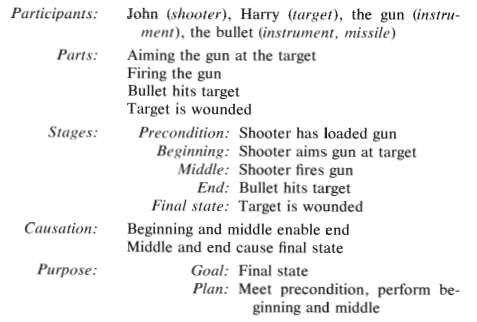

“约翰向哈里开枪了”这句话通常这句话会唤起一种“枪击某人”的格式塔联想。或者，在其他语境中，它也可能唤起其他同样复杂的经验格式塔联想（例如，“表演马戏团节目”）。但是，如果不借助某种更大的格式塔联想来具体说明自然维度的正常范围（例如，目的），这句话几乎不可能被单独理解。（例如，阶段等）。无论唤起哪种格式塔，我们都能理解到比句子直接表达的更多的内容。每一种格式塔都为我们理解句子提供了一个背景，使我们能够用对我们而言有意义的方式去理解句子，也就是说，用我们文化中的经验范畴来理解句子。

The sentence “John fired the gun at Harry” typically evokes a SHOOTING SOMEONE gestalt of this form. Or it could, in other contexts, evoke other equally complex experiential gestalts (e.g., PERFORMING A CIRCUS ACT). But the sentence is virtually never understood on its own terms without the evocation of some larger gestalt that specifies the normal range of natural dimensions (e.g., purpose, stages, etc.). Whichever gestalt is evoked, we understand much more than is given directly in the sentence. Each such gestalt provides a background for understanding the sentence in terms that make sense to us, that is, in terms of an experiential category of our culture.

除了句子所引发的更广泛的体验类别之外，我们还根据信息丰富性对“开火”和“枪”这两个词进行分类。原型。除非语境另有规定，否则我们通常将枪理解为原型枪，具有典型的原型*感知、运动、功能*和*用途*属性。除非语境另有说明，否则我们联想到的并非雨伞枪或手提箱枪，而开枪时使用的运动程序是水平握枪并扣动扳机。这是既符合“开火”又符合“枪”的正常运动程序。除非情境被刻意安排，否则我们不会想象一个鲁布·戈德堡机械装置，其中扳机用绳子系在比如说门把手上。

In addition to the larger category of experience evoked by the sentence, we also categorize FIRING and GUN in terms of information-rich prototypes. Unless the context forces us to do otherwise, we understand the gun to be a prototypical gun, with the usual prototypical *perceptual, motor, functional,* and *purpose* properties. Unless the context specifies otherwise, the image evoked is not that of an umbrella gun or a suitcase gun, and the motor program used in firing is holding the gun horizontal and squeezing the trigger, which is the normal motor program that fits both FIRING and GUN. Unless the context is rigged, we do not imagine a Rube Goldberg device in which the trigger is tied by a string to, say, a door handle.

我们理解这句话，要从这些格式塔元素如何组合在一起的角度来理解，包括“较小”的格式塔元素（枪、开火、瞄准等）和“较大”的格式塔元素（射杀某人或表演马戏）。只有相对于这样的理解，真理问题才会出现。当我们用这些术语理解句子与我们对已发生事件的理解足够吻合时，真理问题就很容易解决。但是，当我们对句子的*通常*理解与我们对事件的理解之间存在差异时，会发生什么呢？例如，假设约翰巧妙地……就像鲁布·戈德堡机械一样，把枪架好，使枪口对准哈利可能出现的位置，然后在扳机上系了一根绳子。我们来看两个例子：

We understand the sentence in terms of the way these gestalts fit together, both the “smaller” gestalts (GUN, FIRING, AIMING, etc.) and the “larger” gestalts (SHOOTING SOMEONE or PERFORMING A CIRCUS ACT). Only relative to such understandings do issues of truth arise. The issue of truth is straightforward when our understanding of the sentence in these terms fits closely enough our understanding of the events that have occurred. But what happens when there is a discrepancy between our *normal* understanding of the sentence and our understanding of the events? Say, for example, that John, in an ingenious Rube Goldberg fashion, set up the gun so that it would be aimed at a point where Harry would be at some time and then tied a string to the trigger. Let’s take two cases:

*A.*约翰挠耳朵导致枪向哈利走火。

*A.* John’s scratching his ear causes the gun to fire at Harry.

*B.*哈利打开门导致枪向哈利走火。

*B.* Harry’s opening the door causes the gun to fire at Harry.

在案例*A 中，*约翰的行为导致了枪击；而在案例*B 中，*哈里的行为导致了枪击。因此，*A更优。*情况 A比情况*B*更接近我们对这句话的通常理解。因此，如果非要我们表态，我们或许会说*A*是一个“约翰向哈利开枪”的说法为真的例子。然而*，情况 B*与我们对“开枪”的典型理解相去甚远，以至于我们可能不会说“约翰向哈利开枪”这句话为真。但我们也不会毫无保留地说它是真的。也不尽然，因为约翰才是枪击事件的主要责任人。我们应该解释清楚，而不仅仅是回答“对”或“错”。这种情况通常发生在我们对事件的理解与我们对句子的通常理解不符时，因为这种理解可能与原型有所偏差。

In case *A,* John’s action is responsible for the firing, while, in *B,* Harry’s action is. This makes *A* closer than *B* to our normal understanding of the sentence. Thus, we might, if pressed, be willing to say that *A* is a case where it would be true to say “John fired the gun at Harry.” Case *B,* however, is so far from our prototypical understanding of firing that we would probably not want to say that it was true that “John fired the gun at Harry.” But we would not want to say that it was unqualifiedly false either, since John was primarily responsible for the shooting. Instead, we’d want to explain, not just answer “True” or “False.” This is what typically happens when our understanding of the events does not fit our normal understanding of the sentence because of some deviation from a prototype.

本节结果可总结如下：

We can summarize the results of this section as follows:

1. 将句子理解为在特定情况下，要判断某句话是否正确，需要理解这句话的意思，也需要理解这句话所指的情况。

1. Understanding a sentence as being true in a given situation requires having an understanding of the sentence and having an understanding of the situation.

2. 当我们对句子的理解与我们对情况的理解足够接近时，我们就认为这个句子是正确的。

2. We understand a sentence as being true when our understanding of the sentence fits our understanding of the situation closely enough.

3. 要理解某种情况，使其符合我们对句子的理解，可能需要：

3. Getting an understanding of a situation of the sort that could fit our understanding of a sentence may require:

a. 展现方向指向没有固有方向的事物（例如，将山视为有正面）

a. Projecting an orientation onto something that has no inherent orientation (e.g., viewing the mountain as having a front)

b. 将实体结构投射到没有明确边界的事物上（例如，雾、山）

b. Projecting an entity structure onto something that is not bounded in any clear sense (e.g., the fog, the mountain)

c. 提供句子意义所需的背景信息，即唤起一种经验整体感（例如，枪击某人、表演马戏团节目）并理解从整体上看，情况是这样的

c. Providing a background in terms of which the sentence makes sense, that is, calling up an experiential gestalt (e.g., SHOOTING SOMEONE, PERFORMING A CIRCUS ACT) and understanding the situation in terms of the gestalt

d. 根据原型定义的类别（例如，枪，开火）对句子进行“正常”理解，并尝试用相同的类别来理解情境。

d. Getting a “normal” understanding of the sentence in terms of its categories (e.g., GUN, FIRING), as defined by prototype, and trying to get an understanding of the situation in terms of the same categories

要理解一个传统的比喻是真实的，需要具备哪些条件？

What Does It Take to Understand a Conventional Metaphor as Being True?

我们已经了解了理解一个简单句子（不含比喻）所涉及的要素。我们认为这是真的。现在我们想指出，添加传统的比喻并不会改变任何事情。我们对它们的理解基本相同，都认为它们是真的。以“通货膨胀上升了”这句话为例。要理解这句话可能成立的情况，需要进行两项推断。我们必须找出通货膨胀的实例，并将它们视为构成某种物质的要素，我们可以……然后进行量化，从而将其视为增长。此外，我们还必须将增长视为一种向上的趋势。这两种预测构成了两种传统的隐喻：通货膨胀是一种物质（本体论隐喻）和更多即向上（方向性隐喻）。本例与上述案例中对情况的预测存在一个主要区别，即““雾在山前。” 就*“雾”而言，*我们是在用另一个更清晰、界限分明的物理对象（有边界的物理对象）来模拟某种物理现象（雾）。就“*山前”而言，*我们是在用另一个物理方向（我们身体的方向）来模拟山的物理方向。在这两种情况下，我们都在理解某种物理现象。我们用*另一种**同样*是物质的事物来理解事物。换句话说，我们用*同类事物来理解事物。但在传统的比喻中，我们用**不同类型的*事物来理解事物。例如，在“通货膨胀上升”这句话中，我们用物质来理解*通货膨胀*（它是抽象的），我们用物质来理解通货膨胀的增加。通货膨胀（同样是抽象的）可以从物理方向（向上）的角度来理解。唯一的区别在于，我们的投射涉及的是*同类*事物还是*不同*类事物。

We have seen what is involved in understanding a simple sentence (without metaphor) as being true. We now want to suggest that adding conventional metaphors changes nothing. We understand them as being true in basically the same way. Take a sentence like “Inflation has gone up.” Understanding a situation as one in which this sentence could be true involves two projections. We have to pick out instances of inflation and view them as constituting a substance, which we can then quantify and thereby view as increasing. In addition we have to project an UP orientation on the increase. These two projections constitute two conventional metaphors: INFLATION IS A SUBSTANCE (an ontological metaphor) and MORE IS UP (an orientational metaphor). There is one principal difference between the projections onto the situation in this case and in the case given above, namely, “The fog is in front of the mountain.” In the case of *fog,* we are understanding something physical (fog) on the model of something else physical but more clearly delineated—a bounded physical object. In the case of *front,* we are understanding the physical orientation of the mountain in terms of another physical orientation—that of our bodies. In both cases, we are understanding something that is physical in terms of something *else* that is *also* physical. In other words, we are understanding one thing in terms of something else *of the same kind.* But in conventional metaphor, we are understanding one thing in terms of something else *of a different kind.* In “Inflation has gone up,” for example, we understand *inflation* (which is abstract) in terms of a physical substance, and we understand an increase of inflation (which is also abstract) in terms of a physical orientation (up). The only difference is whether our projection involves the *same* kinds of things or *different* kinds of things.

当我们理解“通货膨胀上升了”这句话是正确的，我们会这样做：

When we understand a sentence like “Inflation has gone up” as being true, we do the following:

1. 我们可以通过两种方式运用隐喻投射来理解这种*情况：*

1. We understand the *situation* by metaphorical projection in two ways:

a. 我们将通货膨胀视为一种实质（通过本体论隐喻）。

a. We view inflation as a SUBSTANCE (via an ontological metaphor).

b. 我们认为MORE是向上（通过方向隐喻）的。

b. We view MORE as being oriented UP (via an orientational metaphor).

2. 我们用同样的两个比喻来理解这*句话。*

2. We understand the *sentence* in terms of the same two metaphors.

3. 这使我们能够将对句子的理解与对情况的理解相匹配。

3. This allows us to fit our understanding of the sentence to our understanding of the situation.

因此，从隐喻投射的角度理解真理，与从其他角度理解真理，本质上并无不同。非隐喻投射与隐喻投射的唯一区别在于，隐喻投射是指用一种事物来理解另一种事物。也就是说，隐喻投射涉及两种不同的事物，而非隐喻投射只涉及一种事物。

Thus an understanding of truth in terms of metaphorical projection is not essentially different from an understanding of truth in terms of nonmetaphorical projection. The only difference is that metaphorical projection involves understanding one kind of thing in terms of another kind of thing. That is, metaphorical projection involves two different kinds of things, while nonmetaphorical projection involves only one kind.

结构隐喻也同样如此。例如，“约翰在争论中捍卫了自己的立场”。正如我们前面所见，争论的体验部分地以“战争”的格式塔结构来构建，这源于“争论即战争”的隐喻。由于争论是一种隐喻性的体验，由“争论即战争”这一传统隐喻构建，因此，存在争论的情境可以用这些隐喻术语来理解。我们对争论情境的理解也由此而来。这将涉及同时从“对话”和“战争”两个层面来审视它。如果我们对情况的理解使得对话的一部分符合“战争”层面上的有效辩护，那么我们对这句话的理解就与我们对情况的理解相符，我们会认为这句话是正确的。

The same holds for structural metaphors, also. Take a sentence like “John defended his position in the argument.” As we saw above, the experience of arguing is structured partially in terms of the WAR gestalt, by virtue of the ARGUMENT IS WAR metaphor. Since argument is a metaphorical kind of experience, structured by the conventional metaphor ARGUMENT IS WAR, it follows that a situation in which there is an argument may be understood in these metaphorical terms. Our understanding of an argument situation will involve viewing it simultaneously in terms of both the CONVERSATION gestalt and the WAR gestalt. If our understanding of the situation is such that a portion of the conversation fits a successful defense in the WAR gestalt, then our understanding of the sentence will fit our understanding of the situation and we will take the sentence to be true.

无论是比喻意义上的还是非比喻意义上的例如，我们对真理的理解取决于我们对情境的理解。鉴于隐喻本质上是概念性的，而非情境性的……“仅仅从语言角度来看”，我们自然而然地会用隐喻的方式来理解情境。正因为我们能够用隐喻的方式来理解*情境，所以包含隐喻的**句子*才有可能被认为是恰当的。我们所理解的各种情况。

In both the metaphorical and nonmetaphorical cases, our account of how we understand truth depends on our account of how we understand situations. Given that metaphor is conceptual in nature rather than a matter of “mere language,” it is natural for us to conceptualize situations in metaphorical terms. Because we can conceptualize *situations* in metaphorical terms, it is possible for *sentences* containing metaphors to be taken as fitting the situations as we conceptualize them.

我们如何理解新的隐喻是真实的？

How Do We Understand New Metaphors as Being True?

我们刚刚看到，传统的比喻与非比喻性的句子一样，都能符合我们对真理的理解。在这两种情况下，理解一个句子在特定情境下为真，都意味着将我们对句子的理解与我们对该情境的理解相匹配。因为我们对……的理解有些情况下可能涉及传统隐喻，而包含传统隐喻的句子并不会对我们的真理观构成特殊挑战。这表明，同样的真理观也应该适用于新的或非常规的隐喻。

We have just seen that conventional metaphors fit our account of truth in the same way as nonmetaphorical sentences do. In both cases, understanding a sentence as true in a given situation involves fitting our understanding of the sentence to our understanding of the situation. Because our understanding of situations may involve conventional metaphor, sentences with conventional metaphors raise no special problems for our account of truth. This suggests that the same account of truth should work for new, or nonconventional, metaphors.

为了理解这一点，让我们考虑两个相关的比喻，一个是传统的，一个是非传统的：

To see this, let us consider two related metaphors, one conventional and one nonconventional:

请讲述*你的人生故事。*（传统说法）

Tell me the *story of your life.* (conventional)

人生……是一个故事出自一个白痴之口，充满喧嚣和狂怒，却毫无意义。（非传统）

Life’s . . . a tale told by an idiot, full of sound and fury, signifying nothing. (nonconventional)

让我们从“告诉我你的人生故事”开始，这句话包含了“人生如戏”这一传统比喻。这个比喻深深植根于我们的文化之中。人们普遍认为每个人的人生都像一个故事，而整个传记和自传传统都建立在这一假设之上。假设如果有人请你讲述你的人生故事，你会怎么做？你会构建一个连贯的叙事，从你的童年早期一直延续到现在。通常，这样的叙事会包含以下几个特点：

Let us start with “Tell me the story of your life,” which contains the conventional metaphor LIFE IS A STORY. This is a metaphor rooted deep in our culture. It is assumed that everyone’s life is structured like a story, and the entire biographical and autobiographical tradition is based on this assumption. Suppose someone asks you to tell your life story. What do you do? You construct a coherent narrative that starts early in your life and continues up to the present. Typically the narrative will have the following features:

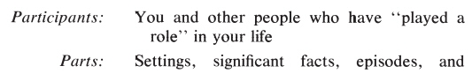

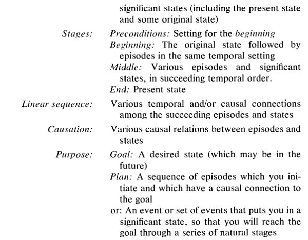

这是一种过于简化的典型体验式格式塔模型，它通过将人生视为一个故事来赋予其连贯性。我们省略了许多复杂因素，例如每个阶段本身可能就是一个结构相似的连贯子叙事。并非所有的人生故事都会包含所有这些结构维度。

This is a much oversimplified version of a typical experiential gestalt for giving coherence to one’s life by viewing it as a STORY. We have omitted various complexities, such as the fact that each episode may in itself be a coherent sub-narrative with a similar structure. Not all life stories will contain all of these dimensions of structure.

注意，从以下角度理解你的生活一个连贯的人生故事会着重突出某些*人物*和*部分*（事件和状态），而忽略或隐藏其他部分。它意味着将你的人生视为不同的*阶段，分析*各部分之间的因果关系，并制定*计划*来实现一个或多个*目标*。总的来说，人生故事会为你生活中被着重强调的元素构建一个连贯的结构。

Notice that understanding your life in terms of a coherent life story involves highlighting certain *participants* and *parts* (episodes and states) and ignoring or hiding others. It involves seeing your life in terms of *stages, causal connections* among the parts, and *plans* meant to achieve a *goal* or a set of goals. In general, a life story imposes a coherent structure on elements of your life that are highlighted.

如果你讲述这样一个故事，那么，如果你确实认为文中重点提及的人物和事件是重要的，并且确实认为它们能够按照文中描述的方式连贯地结合在一起，那么你就可以理直气壮地说：“这就是我的人生故事。”叙事结构。此案例中的真相问题在于，叙事所提供的连贯性是否与事实相符。你在生活中看到的连贯性。正是你在生活中看到的这种连贯性赋予了它意义和价值。

If you tell such a story and then say, “That is the story of my life,” you will legitimately see yourself as telling the truth if you do, in fact, view the highlighted participants and events as the significant ones and do, in fact, perceive them as fitting together coherently in the way specified by the structure of the narrative. The issue of truth in this case is whether the coherence provided by the narrative matches the coherence you see in your life. And it is the coherence that you see in your life that gives it meaning and significance.

现在让我们来探讨一下，理解“人生……就像一个白痴讲的故事，充满喧嚣和愤怒，却毫无意义”这一非传统隐喻的真谛究竟包含哪些要素。这个非传统隐喻呼应了“人生如戏”这一传统隐喻。最显著的事实是……傻瓜讲的故事往往缺乏连贯性。它们开头看似条理清晰，有阶段、因果关系和整体目的，但随后却反复变换方向，让人难以找到任何逻辑，也找不到任何整体的连贯性。这样的人生故事对我们来说毫无逻辑可言，因此也无法赋予任何意义。或者说，对我们的人生而言，这些事件毫无意义。你无法将人生中的事件凸显为意义重大，也就是说，无法将其视为具有某种目的、与其他重要事件存在因果关系、符合人生阶段等等。如果将人生视为一个故事，“喧嚣与骚动”的片段代表着狂热、痛苦挣扎，甚至暴力的时期。在一个典型的人生故事中，这类事件……这些事件可能被视为意义重大——无论是创伤性的、具有宣泄作用的、灾难性的还是高潮性的。但“毫无意义”这一修饰语否定了所有这些意义的可能性，反而表明这些事件不能从因果关系、目的或某种连贯整体中可识别的阶段来理解。

Let us now ask what is involved in understanding as true the nonconventional metaphor “Life’s . . . a tale told by an idiot, full of sound and fury, signifying nothing.” This non-conventional metaphor evokes the conventional metaphor LIFE IS A STORY. The most salient fact about stories told by idiots is that they are not coherent. They start off as if they were coherent stories with stages, causal connections, and overall purposes, but they suddenly shift over and over again, making it impossible to find coherence as you go along or any coherence overall. A life story of this sort would have no coherent structure for us and therefore no way of providing meaning or significance to our lives. There would be no way of highlighting events in your life as being significant, that is, as serving a purpose, having a causal connection to other significant events, fitting stages, etc. In a life viewed as a tale, episodes “full of sound and fury” would represent periods of frenzy, agonized struggle, and perhaps violence. In a typical life story, such events would be viewed as momentous—either traumatic, cathartic, disastrous, or climactic. But the modifier “signifying nothing” negates all these possibilities for significance, suggesting instead that the episodes cannot be viewed in terms of causal connections, purposes, or identifiable stages in some coherent whole.

如果我们真的以这种方式看待自己和他人的生活，那么我们就会采取隐喻的真谛在于，我们通常用“人生如戏”的隐喻来理解人生经历，因此，我们很多人之所以能认同这个隐喻，是因为我们常常用这个隐喻来理解自己的人生。我们不断地在生活中寻找意义，试图找到能够构成某种连贯人生故事的契合点。我们也不断地讲述这样的故事，并依循着这些故事生活。随着环境的变化，我们逐渐意识到这一点。的我们的生活不断变化，我们不断修改自己的人生故事，寻求新的连贯性。

If we in fact view our lives and the lives of others in this way, then we would take the metaphor as being true. What makes it possible for many of us to see this metaphor as true is that we usually comprehend our life experiences in terms of the LIFE IS A STORY metaphor. We are constantly looking for meaning in our lives by seeking out coherences that will fit some sort of coherent life story. And we constantly tell such stories and live in terms of them. As the circumstances of our lives change, we constantly revise our life stories, seeking new coherence.

“人生就像一个白痴讲的故事”这个比喻，或许很适合那些生活环境变化剧烈、迅速且出乎意料的人，以至于他们似乎永远无法讲述一个连贯的人生故事。

The metaphor LIFE’S . . . A TALE TOLD BY AN IDIOT may well fit the lives of people whose life circumstances change so radically, rapidly, and unexpectedly that no coherent life story ever seems possible for them.

尽管我们已经看到，这种新的、非常规的隐喻符合我们对真理的一般解释，我们应该再次强调，在隐喻研究中，真理问题是最不相关、最无趣的问题之一。“人生……一个白痴讲的故事”这个隐喻的真正意义在于，它促使我们尝试理解它为何可能是真的，从而使我们对生活有了新的认识。它凸显了这样一个事实：我们始终生活在一种预期之下。我们总是希望能够将自己的人生经历融入一个连贯的人生故事中，但这种期望却可能不断落空，因为那些人生中最显著的经历——那些充满喧嚣与激情的人生经历——无法融入任何连贯的整体，因此也就失去了意义。通常，为了追求连贯性，我们在构建人生故事时会舍弃许多极其重要的经历。 “人生……一个白痴讲的故事”这个比喻，旨在唤起“人生如戏”的意象，后者强调的是人们总是期望将人生中的重要片段拼凑成一个连贯的整体——一个完整的人生故事。这个比喻的效果在于唤起这种期望，并指出，在现实中，这种期望可能会不断落空。

Although we have seen that such new, nonconventional metaphors will fit our general account of truth, we should stress again that issues of truth are among the least relevant and interesting issues that arise in the study of metaphor. The real significance of the metaphor LIFE’S . . . A TALE TOLD BY AN IDIOT is that, in getting us to try to understand how it could be true, it makes possible a new understanding of our lives. It highlights the fact that we are constantly functioning under the expectation of being able to fit our lives into some coherent life story but that this expectation may be constantly frustrated when the most salient experiences in our lives, those full of sound and fury, do not fit any coherent whole and, therefore, signify nothing. Normally, when we construct life stories, we leave out many extremely important experiences for the sake of finding coherence. What the LIFE’S . . . A TALE TOLD BY AN IDIOT metaphor does is to evoke the LIFE IS A STORY metaphor, which involves living with the constant expectation of fitting important episodes into a coherent whole—a sane life story. The effect of the metaphor is to evoke this expectation and to point out that, in reality, it may be constantly frustrated.

了解情况：概要

Understanding a Situation: A Summary

在本章中，我们我们一直在发展一种基于经验的真理观。我们对真理的理解基于理解。这一理论的核心在于我们对理解情境意义的分析。以下是我们迄今为止对此问题的总结：

In this chapter we have been developing the elements of an experiential account of truth. Our account of truth is based on understanding. What is central to this theory is our analysis of what it means to understand a situation. Here is a summary of what we have said on the matter so far:

*直接即时理解*

*Direct Immediate Understanding*

我们作为个体，通过直接的身体参与，可以直接理解很多事情。与我们周围环境密不可分的一部分。

There are many things that we understand directly from our direct physical involvement as an inseparable part of our immediate environment.

*实体结构：*我们把自己理解为有界实体，我们也直接体验到我们直接接触的某些对象也是有界实体。

*Entity structure:* We understand ourselves as bounded entities, and we directly experience certain objects that we come into direct contact with as bounded entities, too.

*方位结构：*我们理解自身和其他物体相对于我们所处环境具有某些方位（上下、内外、前后、开/关等）。ETC。）。

*Orientational structure:* We understand ourselves and other objects as having certain orientations relative to the environments we function in (up-down, in-out, front-back, on-off, etc.).

*经验维度：*在与他人以及我们所处的物质和文化环境的直接互动中，我们大部分时间都以经验维度为框架。我们根据这些维度对直接接触的事物和直接体验进行分类。

*Dimensions of experience:* There are dimensions of experience in terms of which we function most of the time in our direct interactions with others and with our immediate physical and cultural environment. We categorize the entities we directly encounter and the direct experiences we have in terms of these categories.

*经验格式塔：*我们的客体和物质范畴是格式塔。至少具有以下维度：*感知、运动活动、部分/整体、功能、目的性。*我们对直接行动、活动、事件和经验的分类是格式塔，至少具有以下维度：*参与者、部分、运动活动、感知、阶段、线性序列（部分）、因果关系、目的（*行动的目标/计划和事件的*最终状态*）。这些构成了我们直接经验的自然维度。并非所有维度都会在每一种直接经验中发挥作用，但总的来说，大多数维度都会发挥某种作用。

*Experiential gestalts:* Our object and substance categories are gestalts that have at least the following dimensions: *perceptual, motor activity, part/whole, functional, purposive.* Our categories of direct actions, activities, events, and experiences are gestalts that have at least the following dimensions: *participants, parts, motor activities, perceptions, stages, linear sequences (of parts), causal relations, purpose (goals/plans* for actions and *end states* for events). These constitute the natural dimensions of our direct experience. Not all of them will play a role in every kind of direct experience, but, in general, most of them will play some role or other.

*背景：*经验整体通常作为理解我们所体验到的事物的背景，这些体验被视为该整体的一个方面。因此，人或物可以被理解为*参与者。*在格式塔中，一个动作可以被理解为格式塔的*一部分*。一个格式塔可能预设另一个格式塔的存在，而后者又可能预设其他格式塔的存在，以此类推。其结果通常会形成一个极其丰富的背景结构，这对于全面理解任何特定情况都至关重要。这大部分背景都与……有关。结构永远不会被注意到，因为它是预设好的。在我们日常生活的许多活动和经历中。

*Background:* An experiential gestalt will typically serve as a background for understanding something we experience as an aspect of that gestalt. Thus a person or object may be understood as *a participant* in a gestalt, and an action may be understood as a *part* of a gestalt. One gestalt may presuppose the presence of another, which may, in turn, presuppose the presence of others, and so on. The result will typically be an incredibly rich background structure necessary for a full understanding of any given situation. Most of this background structure will never be noticed, since it is presupposed in so many of our daily activities and experiences.

*重点突出：*将情境理解为体验格式塔的一个实例，意味着要挑选出符合格式塔维度的情境元素——例如，挑选出体验的各个方面，例如*参与者、部分、阶段*等等。这突出了情境的这些方面，同时弱化或隐藏了其他方面。不符合整体格局的情况。

*Highlighting:* Understanding a situation as being an instance of an experiential gestalt involves picking out elements of the situation as fitting the dimensions of the gestalt—for example, picking out aspects of the experience as being *participants, parts, stages,* etc. This highlights those aspects of the situation and downplays or hides aspects of the situation that do not fit the gestalt.

*交互属性：*我们直接体验到的物体或事件所具有的属性，是我们与它们在环境中互动的结果。也就是说，它们可能并非物体或体验*本身固有的属性，而是**交互*属性。

*Interactional properties:* The properties we directly experience an object or event as having are products of our interactions with them in our environment. That is, they may not be *inherent* properties of the object or experience but, instead, *interactional* properties.

*原型：*每个类别都以原型为基础进行构建，并且包含某些内容。由于与原型具有家族相似性，因此被视为该类别的一员。

*Prototypes:* Each category is structured in terms of a prototype, and something counts as a member of the category by virtue of the family resemblances it bears to the prototype.

*间接理解*

*Indirect Understanding*

我们刚才描述了我们如何理解那些在我们直接经验中相当清晰界定的情境方面。但我们在整部作品中已经看到，我们经验的许多方面无法用自然涌现的维度来清晰界定。我们的经验往往如此。这通常适用于人类的情感、抽象概念、心理活动、时间、工作、人类制度、社会实践等等，甚至包括那些没有固有边界或方向的物理对象。虽然其中大多数都可以被直接*体验*，但它们本身却无法被完全理解。相反，我们必须从其他角度去理解它们。实体和体验，通常是其他*类型*的实体和体验。

We have just described how we understand aspects of a situation that are fairly clearly delineated in our direct experience. But we have seen throughout this work that many aspects of our experience cannot be clearly delineated in terms of the naturally emergent dimensions of our experience. This is typically the case for human emotions, abstract concepts, mental activity, time, work, human institutions, social practices, etc., and even for physical objects that have no inherent boundaries or orientations. Though most of these can be *experienced* directly, none of them can be fully comprehended on their own terms. Instead, we must understand them in terms of other entities and experiences, typically other *kinds* of entities and experiences.

正如我们所见，要理解雾气位于山前的这种情况，我们需要将雾气和山视为两个独立的实体。这还需要我们赋予山一种前后方向的概念。投射是我们感知能力的固有组成部分。我们感知雾气和山脉……我们感知到山峰有正面，雾气笼罩着它。我们感知到的山峰的前后方向显然是一种交互属性，雾气和山峰作为实体的状态也是如此。这里我们遇到的是一种间接理解，即我们通过其他更清晰界定的物理现象来理解物理现象。

As we saw, understanding a situation where we see the fog as being in front of the mountain requires us to view the fog and the mountain as entities. It also requires us to project a front-back orientation upon the mountain. These projections are built into our very perception. We perceive the fog and the mountain as entities and we perceive the mountain as having a front, with the fog in front of it. The front-back orientation that we perceive for the mountain is obviously an interactional property, as is the status of the fog and the mountain as entities. Here we have a case of indirect understanding, where we are understanding physical phenomena in terms of other more clearly delineated physical phenomena.

间接理解的本质在于运用直接理解的资源。以雾和山为例，我们运用了实体结构和方位结构。在这种情况下，我们始终局限于单一领域，即物理对象领域。但我们大多数的间接理解都涉及用*一种实体或经验来理解**另一种*实体或经验——也就是说，理解通过隐喻。正如我们所见，所有用于直接、即时理解的资源，都通过隐喻被运用到间接理解中。

What we do in indirect understanding is to use the resources of direct understanding. In the case of the fog and the mountain, we are using entity structure and orientational structure. In this case we stayed within a single domain, that of physical objects. But most of our indirect understanding involves understanding *one kind* of entity or experience in terms of *another kind*—that is, understanding via metaphor. As we have seen, all of the resources that are used in direct, immediate understanding are pressed into service in indirect understanding via metaphor.

*实体结构：*实体和物质结构是通过本体论隐喻强加的。

*Entity structure:* Entity and substance structure is imposed via ontological metaphor.

*方向结构：*方向结构是通过方向隐喻来构建的。

*Orientational structure:* Orientational structure is imposed via orientational metaphor.

*经验的维度：*结构隐喻涉及用一种事物或经验来构建另一种事物或经验，但两者都使用了相同的经验自然维度（例如，*部分、阶段、目的*等）。

*Dimensions of experience:* Structural metaphor involves structuring one kind of thing or experience in terms of another kind, but the same natural dimensions of experience are used in both (e.g., *parts, stages, purposes,* etc.).

*体验格式塔：*结构隐喻涉及将一个格式塔结构的一部分强加于另一个格式塔结构之上。

*Experiential gestalts:* Structural metaphor involves imposing part of one gestalt structure upon another.

*背景：*经验格式塔在隐喻理解中扮演着背景的角色，正如它们在非隐喻理解中一样。理解。

*Background:* Experiential gestalts play the role of a background in metaphorical understanding, just as they do in non-metaphorical understanding.

*突出显示：*隐喻式突出显示的运作机制与非隐喻式格式塔相同。也就是说，通过隐喻叠加在情境中的经验格式塔会挑选出符合其自身维度的情境元素——它会挑选出自身的参与者、部分和阶段。等等。这些是比喻所强调的，也是比喻所没有强调的。被淡化或隐藏。

*Highlighting:* Metaphorical highlighting works by the same mechanism as that for nonmetaphorical gestalts. That is, the experiential gestalt that is superimposed in the situation via the metaphor picks out elements of the situation as fitting its dimensions—it picks out its own participants, parts, stages, etc. These are what the metaphor highlights, and what is not highlighted is downplayed or hidden.

由于新的隐喻突出了我们正常概念结构通常不会突出的事物，因此它们已成为最受赞誉的突出例子。

Since new metaphors highlight things not usually highlighted by our normal conceptual structure, they have become the most celebrated examples of highlighting.

*互动属性：*我们经验的所有维度本质上都是互动性的，所有经验整体都包含互动属性。这一点适用于隐喻性的和非隐喻性的体验。概念。

*Interactional properties:* All of the dimensions of our experience are interactional in nature, and all experiential gestalts involve interactional properties. This holds for both metaphorical and nonmetaphorical concepts.

*原型：*隐喻范畴和非隐喻范畴都是根据原型构建的。

*Prototypes:* Both metaphorical and nonmetaphorical categories are structured in terms of prototypes.

*真理源于理解*

*Truth Is Based on Understanding*

我们已经看到，构成我们概念系统直接理解情境的八个方面，在间接理解中也发挥着类似的作用。无论我们是在理解还是在理解，我们通常都会运用这些概念系统方面。用比喻或非比喻的方式理解情境。正因为我们用自身的概念体系来理解*情境*，我们才能理解运用该概念体系的*陈述*是否为*真，*也就是说，这些陈述是否符合我们所理解的情境。因此，真理是我们概念体系的一个函数。正因为我们的许多概念本质上都是比喻性的，因为我们用这些概念来理解情况，所以这些比喻可能是真的，也可能是假的。

We have seen that the same eight aspects of our conceptual system that go into direct immediate understanding of situations play parallel roles in indirect understanding. These aspects of our normal conceptual system are used whether we are understanding a situation in metaphorical or non-metaphorical terms. It is because we understand *situations* in terms of our conceptual system that we can understand *statements* using that system of concepts as being *true,* that is, as fitting or not fitting the situation as we understand it. Truth is therefore a function of our conceptual system. It is because many of our concepts are metaphorical in nature, and because we understand situations in terms of those concepts, that metaphors can be true or false.

经验主义真理观的本质

The Nature of the Experientialist Account of Truth

*当我们对某个陈述的理解与我们对该情况的理解足够接近，能够满足我们的目的时，我们就认为该陈述在特定情况下是正确的。*

*We understand a statement as being true in a given situation when our understanding of the statement fits our understanding of the situation closely enough for our purposes.*

这就是我们经验主义真理理论的基础，具有以下特点。

This is the foundation of our experientialist theory of truth, which has the following characteristics.

*首先，我们的理论与符合*论有一些共同之处。根据最基本的符合论观点，一个陈述具有客观意义，它明确规定了陈述为真的条件。真理在于陈述与世界中某种事物状态之间的直接契合（或对应）。

First, our theory has some elements in common with a *correspondence* theory. According to the most rudimentary correspondence view, a statement has an objective meaning, which specifies the conditions under which it is true. Truth consists of a direct fit (or correspondence) between a statement and some state of affairs in the world.

我们反对这种简单化的观点。主要是因为这种观点忽略了真理建立在理解之上这一事实。我们提出的经验主义观点在以下意义上是一种符合论：

We reject such a simplistic picture, primarily because it ignores the way in which truth is based on understanding. The experientialist view we are proposing is a correspondence theory in the following sense:

真理理论是指在特定情况下理解一个陈述为真或为假的意义的理论。

A theory of truth is a theory of what it means to understand a statement as true or false in a certain situation.

我们所说的话与世界上的某些事情之间的任何对应关系，总是受到某种因素的调节。我们对陈述和事态的理解。当然，我们对情况的理解源于我们与情况本身的互动。但我们之所以能够对世界做出真（或假）的陈述，是因为*我们对陈述的理解*有可能与我们对陈述所处*情境的理解*相符（或不符） 。

Any correspondence between what we say and some state of affairs in the world is always mediated by our understanding of the statement and of the state of affairs. Of course, our understanding of the situation results from our interaction with the situation itself. But we are able to make true (or false) statements about the world because it is possible for *our understanding of a statement* to fit (or not fit) *our understanding of the situation* in which the statement is made.

因为我们理解就我们的概念体系而言，对于各种情况和陈述，真理总是相对于该概念体系而言的。同样，由于理解总是片面的，我们无法获得“全部真理”或对现实的任何最终解释。

Since we understand situations and statements in terms of our conceptual system, truth for us is always relative to that conceptual system. Likewise, since an understanding is always partial, we have no access to “the whole truth” or to any definitive account of reality.

其次，理解事物需要将其纳入一个连贯的框架，相对于一个概念系统而言。因此，真理总是部分取决于……关于相干性。这为我们提供了*相干性理论的要素。*

Second, understanding something requires fitting it into a coherent scheme, relative to a conceptual system. Thus, truth will always depend partly on coherence. This gives us elements of a *coherence theory.*

第三，理解也需要以经验为基础。从经验主义的角度来看，我们的概念体系源于我们在物质和文化环境中不断成功运作的经验。我们的经验范畴及其构成维度不仅源于我们的经验，而且……通过持续的成功不断接受考验它由我们文化中的所有成员共同发挥作用。这为我们提供了*实用主义理论的要素。*

Third, understanding also requires a grounding in experience. On the experientialist view, our conceptual system emerges from our constant successful functioning in our physical and cultural environment. Our categories of experience and the dimensions out of which they are constructed not only have emerged from our experience but are constantly being tested through ongoing successful functioning by all the members of our culture. This gives us elements of a *pragmatic theory.*

第四，经验主义真理论与古典实在论有一些共同之处*，*但并不包括它对绝对真理的坚持。相反，它假定：

Fourth, the experientialist theory of truth has some elements in common with classical *realism,* but these do not include its insistence on absolute truth. Instead, it takes as given that:

物质世界就是物质世界，文化就是文化。人就是人。

The physical world is what it is. Cultures are what they are. People are what they are.

人们能够成功地与所处的物理和文化环境进行互动。他们不断地与现实世界互动。

People successfully interact in their physical and cultural environments. They are constantly interacting with the real world.

人类的分类受到现实的限制，因为它以经验的自然维度为特征，而这些自然维度又不断地通过身体和文化互动来检验。

Human categorization is constrained by reality, since it is characterized in terms of natural dimensions of experience that are constantly tested through physical and cultural interaction.

古典现实主义关注的是物理现实，而不是物理现实。比起文化和个人现实，社会、政治、经济和宗教制度以及在其中运作的人们，其真实性丝毫不亚于树木、桌子或石头。由于我们对真理的阐释既涉及社会和个人现实，也涉及物质现实，因此它可以被视为对现实主义传统的拓展。

Classical realism focuses on physical reality rather than cultural and personal reality. But social, political, economic, and religious institutions and the human beings who function within them are no less real than trees, tables, or rocks. Since our account of truth deals with social and personal reality as well as physical reality, it can be considered an attempt to extend the realist tradition.

经验主义理论与古典主义有所不同客观实在论的基本观点如下：人类概念并不对应于事物固有的属性，而仅对应于事物的互动属性。这很自然，因为概念本质上可以是隐喻性的，并且会因文化而异。

The experientialist theory varies from classical objective realism in the following basic way: Human concepts do not correspond to inherent properties of things but only to interactional properties. This is natural, since concepts can be metaphorical in nature and can vary from culture to culture.

第五，与我们概念体系截然不同的人，对世界的理解方式可能与我们大相径庭。因此，他们可能……与我们拥有的真理体系截然不同，甚至对真理和现实的评判标准也不同。

Fifth, people with very different conceptual systems than our own may understand the world in a very different way than we do. Thus, they may have a very different body of truths than we have and even different criteria for truth and reality.

从以上描述可以看出，我们对真理的阐述并没有什么根本性的新内容。它包含了现象学传统的一些核心见解，例如对认识论基础主义的否定，以及强调身体在构建……中的核心地位。我们的经验，以及这方面的重要性理解的结构。我们的观点也与维特根斯坦后期哲学的一些关键要素相一致：对分类的家族相似性解释、对意义的图像理论的否定、对意义的构建模块理论的否定，以及强调意义相对于语境和个人概念体系而言的重要性。

It should be obvious from this description that there is nothing radically new in our account of truth. It includes some of the central insights of the phenomenological tradition, such as the rejection of epistemological foundationalism, the stress on the centrality of the body in the structuring of our experience, and the importance of that structure in understanding. Our view also accords with some of the key elements of Wittgenstein’s later philosophy: the family-resemblance account of categorization, the rejection of the picture theory of meaning, the rejection of a building-block theory of meaning, and the emphasis on meaning as relative to context and to one’s own conceptual system.

“客观真理”理论中的人类理解要素

Elements of Human Understanding in Theories of “Objective Truth”

基于理解的真理理论显然不是“纯粹客观真理”的理论。我们不相信存在绝对真理，也认为试图构建绝对真理的理论毫无意义。然而，西方哲学传统上假定绝对真理是可能的，并试图对其进行研究。为了对此进行阐述，我们想指出，当前最主要的解决这一问题的方法是如何将人类理解的某些方面纳入其中的，而这些方面恰恰是它们声称要排除的。

A theory of truth based on understanding is obviously not a theory of “purely objective truth.” We do not believe that there is such a thing as absolute truth, and we think that it is pointless to try to give a theory of it. However, it is traditional in Western philosophy to assume that absolute truth is possible and to undertake to give an account of it. We would like to point out how the most prominent contemporary approaches to the problem build in aspects of human understanding, which they claim to exclude.

最明显的例子是模型论方法中对真理的阐述，例如克里普克和蒙塔古传统中的那些方法。这些模型是在一个话语宇宙中构建的。这被视为一个*实体集合。*相对于这个实体集合，我们可以定义世界状态，其中所有实体的属性以及它们之间的所有关系都被明确规定。我们假设世界状态的概念足够通用，可以应用于任何可以想象的情况，包括现实世界。在这样的系统中，诸如“雾在前面……”之类的句子如果用“山”来表示雾，就不会有问题，因为会有一个实体对应*雾，*一个实体对应*山，并且两者**之间*存在关联。但这样的模型并不对应脱离人类理解的现实世界，因为现实世界中并不存在明确定义的实体分别对应*山*和*雾*。没有固有的*雾*在山前。实体结构和前后方位是由人类理解所决定的。任何试图用模型论的术语来解释“雾在山前”这一真理的尝试，都无法解释*客观的、绝对的*真理，因为它涉及到将人类理解的要素融入模型之中。

The most obvious case is the account of truth given within model-theoretic approaches, say, for example, those done within the Kripke and Montague traditions. The models are constructed out of a universe of discourse that is taken to be a set of *entities.* Relative to this set of entities, we can define world states, in which all the properties that the entities have and all the relations among them are specified. It is assumed that this concept of a world state is sufficiently general to apply to any conceivable situation, including the real world. In such a system, sentences like “The fog is in front of the mountain” would present no problem, since there would be an entity corresponding to *the fog,* an entity corresponding to *the mountain,* and a relation *in front of,* relating the two entities. But such models do not correspond to the world in itself, free of human understanding, since there are in the world no well-defined entities corresponding to *the mountain* and *the fog* and there is no inherent *front* to the mountain. The entity structure and the front-back orientation are imposed by virtue of human understanding. Any attempt to give an account of the truth of “The fog is in front of the mountain” in such model-theoretic terms will not be an account of *objective, absolute* truth, since it involves building elements of human understanding into the models.

同样的道理也适用于尝试。提出一种符合经典塔斯基真理定义约束的真理理论：

The same can be said of attempts to provide a theory of truth meeting the constraints of the classic Tarski truth definition:

*“S”*为真当且仅当*S* ...

*“S”* is true if and only if *S* . . .

或更新的版本，例如：

or more up-to-date versions like:

*“S”*为真当且仅当*p*（其中*p*是某种普遍适用的逻辑语言中的一个语句）

*“S”* is true if and only if *p* (where *p* is a statement in some universally applicable logical language)

此类理论的原型，即老生常谈的……

The prototype for such theories, the well-worn

“雪是白色的”这句话为真，当且仅当雪是白色的。

“Snow is white” is true if and only if snow is white.

看起来合情合理。因为人们完全可以合理地认为，雪在某种意义上是可以客观识别的，而且它本身就是白色的。但是，如果……呢？

seems reasonable enough, since there could reasonably be thought to be a sense in which snow is objectively identifiable and in which it is inherently white. But what about

“雾在山前”这句话为真，当且仅当雾在山前。

“The fog is in front of the mountain” is true if and only if the fog is in front of the mountain.

由于世界上不存在*像雾*和*山这样清晰可辨的实体，*而且山也没有固有的正面，因此该理论……这种方法只有在人类对山脉前沿的理解以及对*雾*和*山脉的某种区分的基础上才能奏效。*问题更加棘手，因为并非所有人对山脉前沿的判断都相同。因此，必须引入一些人类理解的要素，才能使真理的定义成立。

Since the world does not contain clearly identifiable entities *the fog* and *the mountain,* and since mountains don’t have inherent fronts, the theory can work only relative to some human understanding of what a front is for a mountain and to some delineation of *fog* and *mountain.* The problem is even trickier, since not all human beings have the same way of projecting fronts onto mountains. Here some elements of human understanding must be brought in to make the truth definition work.

我们的账户与其它账户还有另一个重要的区别。就理解而言的真理，以及试图对真理做出不受人类因素影响的解释的标准做法。理解。对真理的不同解读会产生对意义的不同解读。对我们而言，意义取决于理解。除非你理解它，否则一个句子对你来说没有任何意义。此外，意义总是*对*某些人而言的意义。句子本身并不存在所谓的“意义”。句子本身独立于任何人群。当我们谈论一个句子的意义时，它始终是指这个句子对某个人的意义，这个人可以是真实的，也可以是某个语言社群中假想的典型成员。

There is another important difference between our account of truth in terms of understanding and the standard attempts to give an account of truth free of human understanding. The different accounts of truth give rise to different accounts of meaning. For us, meaning depends on understanding. A sentence can’t mean anything to you unless you understand it. Moreover, meaning is always meaning *to* someone. There is no such thing as a meaning of a sentence in itself, independent of any people. When we speak of the meaning of a sentence, it is always the meaning of the sentence to someone, a real person or a hypothetical typical member of a speech community.

我们的理论与标准的意义理论有着根本的不同。标准理论假定，可以对真理本身做出解释，使其脱离人类的理解，意义理论将建立在真理理论之上。我们认为任何此类方案都行不通，唯一的解决办法是将意义理论和真理理论都建立在理解理论之上。隐喻，无论是传统的还是非传统的，在这种方案中都扮演着核心角色。隐喻本质上是理解的工具，其本身与意义关系不大。这与客观现实无关，如果客观现实存在的话。我们的概念体系本质上是隐喻性的，我们用隐喻的方式理解世界、思考和行动，而且隐喻不仅可以被理解，还可以具有意义和真实性——所有这些事实都表明，对意义和真理的充分解释只能建立在理解之上。

Here our theory differs radically from standard theories of meaning. The standard theories assume that it is possible to give an account of truth in itself, free of human understanding, and that the theory of meaning will be based on such a theory of truth. We see no possibility for any such program to work and think that the only answer is to base both the theory of meaning and the theory of truth on a theory of understanding. Metaphor, both conventional and nonconventional, plays a central role in such a program. Metaphors are basically devices for understanding and have little to do with objective reality, if there is such a thing. The fact that our conceptual system is inherently metaphorical, the fact that we understand the world, think, and function in metaphorical terms, and the fact that metaphors can not merely be understood but can be meaningful and true as well—these facts all suggest that an adequate account of meaning and truth can only be based on understanding.

25

25

客观主义和主观主义的神话

The Myths of Objectivism and Subjectivism

我们的文化所提供的选择

The Choices Our Culture Offers

我们已经阐述了真理如何建立在理解之上。我们论证了真理总是相对于某个概念体系而言的，任何人类概念体系本质上大多是隐喻性的，因此，不存在完全客观、无条件或绝对的真理。对于许多被……提升的人来说在科学文化或其他将绝对真理视为理所当然的亚文化中，这会被视为向主观性和任意性屈服——向“我选择它意味着什么，它就意味着什么，不多也不少”这种“蛋壳”式的观念屈服。出于同样的原因，那些认同浪漫主义传统的人可能会将任何战胜客观主义的胜利视为想象力的胜利。战胜科学——这是一种观点的胜利，即每个人都可以不受任何限制地创造自己的现实。

We have given an account of the way in which truth is based on understanding. We have argued that truth is always relative to a conceptual system, that any human conceptual system is mostly metaphorical in nature, and that, therefore, there is no fully objective, unconditional, or absolute truth. To many people raised in the culture of science or in other subcultures where absolute truth is taken for granted, this will be seen as a surrender to subjectivity and arbitrariness—to the Humpty-Dumpty notion that something means “just what I choose it to mean—neither more nor less.” For the same reason, those who identify with the Romantic tradition may see any victory over objectivism as a triumph of imagination over science—a triumph of the view that each individual makes his own reality, free of any constraints.

这两种观点都是一种误解，它们基于一种错误的文化假设，即客观主义的唯一替代方案是彻底的主观主义——也就是说，要么你相信绝对真理，*要么*你可以按照自己的意愿塑造世界。如果你不保持*客观，*你就是在……*主观性*是存在的，没有第三种选择。我们认为，我们为客观主义和主观主义的神话提供了第三种选择。

Either of these views would be a misunderstanding based on the mistaken cultural assumption that the only alternative to objectivism is radical subjectivity—that is, either you believe in absolute truth *or* you can make the world in your own image. If you’re not being *objective,* you’re being *subjective,* and there is no third choice. We see ourselves as offering a third choice to the myths of objectivism and subjectivism.

顺便一提，我们使用“神话”一词并无任何贬义。神话为我们理解经验提供了途径；它们赋予我们的生活秩序。如同隐喻一样，神话对于理解世间万物至关重要。我们周围。所有文化都有神话，人们也都有。神话离不开，正如隐喻离不开一样。正如我们常常把自身文化中的*隐喻当作真理一样，我们也常常把自身文化中的**神话*当作真理。客观主义的神话在这方面尤其具有隐蔽性。它不仅声称自己并非神话，而且还将神话和隐喻都贬低和嘲讽：根据……客观主义神话、神话和隐喻都不能被认真对待，因为它们并非客观真理。正如我们将看到的，客观主义神话本身也并非客观真理。但这并不意味着它应该被鄙视或嘲笑。客观主义神话是这个文化中每个成员日常运作的一部分。它需要被审视和理解。我们也认为它需要我们需要补充的，不是其对立面——主观主义的神话，而是一种新的经验主义神话，我们认为这种新神话更符合我们经验的现实。为了清楚地了解经验主义的替代方案究竟是什么，我们首先需要详细审视客观主义和主观主义的神话。

Incidentally, we are not using the term “myth” in any derogatory way. Myths provide ways of comprehending experience; they give order to our lives. Like metaphors, myths are necessary for making sense of what goes on around us. All cultures have myths, and people cannot function without myth any more than they can function without metaphor. And just as we often take the *metaphors* of our own culture as truths, so we often take the *myths* of our own culture as truths. The myth of objectivism is particularly insidious in this way. Not only does it purport not to be a myth, but it makes both myths and metaphors objects of belittlement and scorn: according to the objectivist myth, myths and metaphors cannot be taken seriously because they are not objectively true. As we will see, the myth of objectivism is itself not objectively true. But this does not make it something to be scorned or ridiculed. The myth of objectivism is part of the everyday functioning of every member of this culture. It needs to be examined and understood. We also think it needs to be supplemented—not by its opposite, the myth of subjectivism, but by a new experientialist myth, which we think better fits the realities of our experience. In order to get clear about what an experientialist alternative would be like, we first need to examine the myths of objectivism and subjectivism in detail.

客观主义的神话

The Myth of Objectivism

客观主义的神话认为：

The myth of objectivism says that:

1. 世界是宇宙由物体构成。它们拥有独立于任何体验它们的人类或其他生物的属性。例如，一块石头。它是一个独立的物体，而且是坚硬的。即使宇宙中不存在人类或其他生物，它仍然是一个独立的物体，并且仍然是坚硬的。

1. The world is made up of objects. They have properties independent of any people or other beings who experience them. For example, take a rock. It’s a separate object and it’s hard. Even if no people or other beings existed in the universe, it would still be a separate object and it would still be hard.

2. 我们通过体验世界中的事物并了解它们的属性来获得对世界的认知。物体具有哪些特性，以及这些物体之间是如何相互关联的。例如，我们通过观察、触摸、移动等方式发现石头是一个独立的物体。我们通过触摸、挤压、踢、用较软的物体敲击等方式发现石头是坚硬的。

2. We get our knowledge of the world by experiencing the objects in it and getting to know what properties the objects have and how these objects are related to one another. For example, we find out that a rock is a separate object by looking at it, feeling it, moving it around, etc. We find out that it’s hard by touching it, trying to squeeze it, kicking it, banging it against something softer, etc.

3. 我们根据类别和概念来理解我们世界中的事物。这些类别和概念对应于事物自身（固有）的属性以及事物之间的关系。因此，我们有“岩石”这个词，它对应于“岩石”这个概念。给定一块岩石，我们可以判断它属于“岩石”这一类别，而钢琴、树木或老虎则不属于。岩石具有独立于任何生物的固有属性：它们是固体、坚硬、致密的，并且天然存在。等等。我们从这些特性的角度来理解“岩石”是什么。

3. We understand the objects in our world in terms of categories and concepts. These categories and concepts correspond to properties the objects have in themselves (inherently) and to the relationships among the objects. Thus, we have a word “rock,” which corresponds to a concept ROCK. Given a rock, we can tell that it is in the category ROCK and that a piano, a tree, or a tiger would not be. Rocks have inherent properties independent of any beings: they’re solid, hard, dense, occur in nature, etc. We understand what a “rock” is in terms of these properties.

4. 客观现实是存在的，我们可以就此说出客观、绝对、无条件的真话和假话。但是，作为人类，我们难免会犯错，例如错觉、感知错误、判断错误、情绪以及个人和文化偏见。我们不能依赖主观判断。科学并非基于个人判断，而是提供了一种方法论，使我们能够超越主观局限，从一个普遍有效且公正的视角获得理解。科学最终能够对现实给出正确、明确且普遍的解释，并且通过其方法论，它正不断朝着这个目标迈进。

4. There is an objective reality, and we can say things that are objectively, absolutely, and unconditionally true and false about it. But, as human beings, we are subject to human error, that is, illusions, errors of perception, errors of judgment, emotions, and personal and cultural biases. We cannot rely upon the subjective judgments of individual people. Science provides us with a methodology that allows us to rise above our subjective limitations and to achieve understanding from a universally valid and unbiased point of view. Science can ultimately give a correct, definitive, and general account of reality, and, through its methodology, it is constantly progressing toward that goal.

5. 词语具有固定的含义。也就是说，我们的语言表达了我们思考时所使用的概念和范畴。为了正确地描述现实，我们需要含义清晰、精确的词语，需要与现实相符的词语。这些词语可能是自然产生的，也可能是科学理论中的专业术语。

5. Words have fixed meanings. That is, our language expresses the concepts and categories that we think in terms of. To describe reality correctly, we need words whose meanings are clear and precise, words that fit reality. These may be words that arise naturally, or they may be technical terms in a scientific theory.

6. 人们可以保持客观，也可以客观地说话，但前提是他们使用的语言是……清晰明确、言简意赅、符合现实。只有这样，人们才能准确地交流外部世界，并做出可以被客观判断真假的陈述。

6. People can be objective and can speak objectively, but they can do so only if they use language that is clearly and precisely defined, that is straightforward and direct, and that can fit reality. Only by speaking in this way can people communicate precisely about the external world and make statements that can be judged objectively to be true or false.

7. 在客观论述中，应始终避免使用比喻和其他诗意、奇幻、修辞或比喻性的语言，而且应该避免使用。应避免，因为它们这些含义不清晰、不精确，而且与现实没有任何明显的契合之处。

7. Metaphor and other kinds of poetic, fanciful, rhetorical, or figurative language can always be avoided in speaking objectively, and they should be avoided, since their meanings are not clear and precise and do not fit reality in any obvious way.

8. 保持客观通常是一件好事。只有客观的知识才是真正的知识。只有从客观、无条件的视角出发，我们才能真正理解自己、他人和外部世界。客观性使我们能够超越个人偏见和成见，做到公平公正，并且对世界持客观公正的态度。

8. Being objective is generally a good thing. Only objective knowledge is really knowledge. Only from an objective, unconditional point of view can we really understand ourselves, others, and the external world. Objectivity allows us to rise above personal prejudice and bias, to be fair, and to take an unbiased view of the world.

9. 客观就是理性；主观就是非理性，屈服于情感。

9. To be objective is to be rational; to be subjective is to be irrational and to give in to the emotions.

10. 主观性可能很危险，因为它会导致脱离现实。主观性可能不公平，因为它带有个人视角，因此可能存在偏见。主观性是自我放纵的，因为它夸大了事物的重要性。个人。

10. Subjectivity can be dangerous, since it can lead to losing touch with reality. Subjectivity can be unfair, since it takes a personal point of view and can, therefore, be biased. Subjectivity is self-indulgent, since it exaggerates the importance of the individual.

主观主义的神话

The Myth of Subjectivism

主观主义神话认为：

The myth of subjectivism says that:

1. 在大多数日常实践活动中，我们依赖感官并培养出值得信赖的直觉。当重要问题出现时，无论他人怎么说，我们自身的感官和直觉都是我们行动的最佳指南。

1. In most of our everyday practical activities we rely on our senses and develop intuitions we can trust. When important issues arise, regardless of what others may say, our own senses and intuitions are our best guides for action.

2. 我们生活中最重要的东西是我们的情感、审美情趣，道德实践和精神觉悟，这些纯粹是主观的，没有哪一项是纯粹理性或客观的。

2. The most important things in our lives are our feelings, aesthetic sensibilities, moral practices, and spiritual awareness. These are purely subjective. None of these is purely rational or objective.

3. 艺术和诗歌超越了理性与客观，使我们触及到更重要的情感和直觉的现实。我们通过想象而非理性获得这种意识。

3. Art and poetry transcend rationality and objectivity and put us in touch with the more important reality of our feelings and intuitions. We gain this awareness through imagination rather than reason.

4. 想象力的语言，尤其是比喻，对于……至关重要表达我们经历中独特且最具个人意义的方面。在个人理解方面，词语通常被认可的含义是行不通的。

4. The language of the imagination, especially metaphor, is necessary for expressing the unique and most personally significant aspects of our experience. In matters of personal understanding the ordinary agreed-upon meanings that words have will not do.

5. 客观性可能很危险，因为它忽略了什么对个人而言，客观性最为重要且意义非凡。客观性可能并不公平，因为它必须忽略我们经验中最相关的领域，而偏重于……抽象、普遍、非人格化。正因如此，客观性也可能显得冷酷无情。我们无法通过客观理性的手段来了解我们的情感、审美感受等等。在关乎我们生命中最重要的事情上，科学也无能为力。

5. Objectivity can be dangerous, because it misses what is most important and meaningful to individual people. Objectivity can be unfair, since it must ignore the most relevant realms of our experience in favor of the abstract, universal, and impersonal. For the same reason, objectivity can be inhuman. There are no objective and rational means for getting at our feelings, our aesthetic sensibilities, etc. Science is of no use when it comes to the most important things in our lives.

对隐喻的恐惧

Fear of Metaphor

客观主义和主观主义相互依存，彼此依存。它们各自通过与……的对立来定义自身。客观主义视对方为敌人，而主观主义则以情感、直觉、想象力、人性、艺术和“更高层次”的真理为盟友。二者各自在其领域内占据主导地位，并认为自己的领域优于其他领域。它们共存，但处于不同的领域。我们每个人都拥有自己的领域。在他的人生中，哪些领域适合客观，哪些领域适合主观。我们生活中受客观主义和主观主义支配的部分因人而异，也因文化而异。有些人甚至试图完全按照某种神话或神话来生活。

Objectivism and subjectivism need each other in order to exist. Each defines itself in opposition to the other and sees the other as the enemy. Objectivism takes as its allies scientific truth, rationality, precision, fairness, and impartiality. Subjectivism takes as its allies the emotions, intuitive insight, imagination, humaneness, art, and a “higher” truth. Each is master in its own realm and views its realm as the better of the two. They coexist, but in separate domains. Each of us has a realm in his life where it is appropriate to be objective and a realm where it is appropriate to be subjective. The portions of our lives governed by objectivism and subjectivism vary greatly from person to person and from culture to culture. Some of us even attempt to live our entire lives totally by one myth or the other.

在整个西方文化中，客观主义无疑是最强大的力量。它声称至少在名义上主宰着科学、法律、政府、新闻、道德、商业、经济和学术领域。但是，正如我们所论证的，客观主义是一个神话。

In Western culture as a whole, objectivism is by far the greater potentate, claiming to rule, at least nominally, the realms of science, law, government, journalism, morality, business, economics, and scholarship. But, as we have argued, objectivism is a myth.

自古希腊时期以来，西方文化中就存在着真理与艺术之间的张力，艺术被视为一种幻象，并通过与诗歌和戏剧的联系而与真理相联系。雄辩的公共演说传统。柏拉图对诗歌和修辞抱有怀疑态度，并在他的理想国中禁止诗歌。因为它本身并不提供任何真理，反而煽动情绪，从而蒙蔽了人类的双眼，使人看不到真正的真理。柏拉图是一位典型的善于说服的作家，他运用强有力的修辞手法——寓言——阐述了真理是绝对的，艺术不过是幻象的观点。亚里士多德的洞穴寓言至今仍主导着西方哲学，以其微妙而优雅的表达方式阐述了他认为真理绝对的观点。另一方面，亚里士多德则认为诗歌具有积极的价值：“恰当运用诗歌形式固然重要，……但最伟大的莫过于精通隐喻”（*《诗学》* 1459a）；“普通的词语只能传达…… ”我们已经知道；通过比喻，我们可以最好地获得一些新鲜的东西”（*《修辞学》* 1410b）。

Since the time of the Greeks, there has been in Western culture a tension between truth, on the one hand, and art, on the other, with art viewed as illusion and allied, via its link with poetry and theater, to the tradition of persuasive public oratory. Plato viewed poetry and rhetoric with suspicion and banned poetry from his utopian Republic because it gives no truth of its own, stirs up the emotions, and thereby blinds mankind to the real truth. Plato, typical of persuasive writers, stated his view that truth is absolute and art mere illusion by the use of a powerful rhetorical device, his Allegory of the Cave. To this day, his metaphors dominate Western philosophy, providing subtle and elegant expression for his view that truth is absolute. Aristotle, on the other hand, saw poetry as having a positive value: “It is a great thing, indeed, to make proper use of the poetic forms, . . . But the greatest thing by far is to be a master of metaphor” (*Poetics* 1459a); “ordinary words convey only what we know already; it is from metaphor that we can best get hold of something fresh” (*Rhetoric* 1410b).

尽管亚里士多德关于隐喻运作机制的理论是*经典*观点，但他对隐喻启发洞察力的能力的赞扬却从未被现代哲学思想所继承。随着经验科学作为真理模式的兴起，对诗歌和修辞的怀疑态度逐渐占据主导地位。在西方思想中，隐喻和其他比喻手法再次成为人们鄙夷的对象。例如，霍布斯认为隐喻荒谬且具有误导性的情感色彩；它们是*“愚昧之火；*对它们进行推理如同在无数荒谬之中徘徊；它们的最终结果是争论、煽动叛乱或蔑视”（*《利维坦》，*第一部分，第五章）。霍布斯认为“隐喻的使用”本身就是一种荒谬，用修辞格和其他修辞手法代替真正的词语。例如，虽然在日常口语中可以说*“路通”、“引向此地”、“引向彼地”；谚语说这样或那样，*而“路”本身不会“通行”，谚语也不会“说话”；然而，在计算和寻求真理时，这样的言语是不允许的”（同上）。

But although Aristotle’s theory of how metaphors work is *the* classic view, his praise of metaphor’s ability to induce insight was never carried over into modern philosophical thought. With the rise of empirical science as a model for truth, the suspicion of poetry and rhetoric became dominant in Western thought, with metaphor and other figurative devices becoming objects of scorn once again. Hobbes, for example, finds metaphors absurd and misleadingly emotional; they are *“ignes fatui;* and reasoning upon them is wandering amongst innumerable absurdities; and their end, contention and sedition, or contempt” (*Leviathan,* pt. 1, chap. 5). Hobbes finds absurdity in “the use of metaphors, tropes, and other rhetorical figures, instead of words proper. For though it be lawful to say, for example in common speech, *the way goeth, or leadeth hither, or thither; the proverb says this or that,* whereas ways cannot go, nor proverbs speak; yet in reckoning, and seeking of truth, such speeches are not to be admitted” (ibid.).

洛克继承了经验主义传统，表现出同样的蔑视。他认为比喻性修辞是一种修辞工具，也是真理的敌人：

Locke, continuing the empiricist tradition, shows the same contempt for figurative speech, which he views as a tool of rhetoric and an enemy of truth:

……如果我们想如实谈论事物，就必须承认，修辞艺术除了秩序和清晰之外；所有……雄辩家们人为地、比喻性地运用词语，其目的无非是暗示错误的观念，煽动情绪，从而误导判断；事实的确如此。它们是彻头彻尾的骗子：因此，无论雄辩的口才在演说和大众演讲中如何将它们美化或允许，在所有旨在提供信息或指导的论述中，它们都绝对应该完全避免；而当涉及到真理和知识时，无论是语言本身还是使用它们的人，都必然会被视为一种重大缺陷……显而易见，人们是多么喜爱它们。欺骗与被欺骗，因为修辞学——这种强大的谬误和欺骗工具——拥有成熟的教授群体，公开授课，并且一直享有盛誉。[ *《人类理解论》，*第三卷，第十章]

. . . if we would speak of things as they are, we must allow that all the art of rhetoric, besides order and clearness; all the artificial and figurative application of words eloquence hath invented, are for nothing else but to insinuate wrong ideas, move the passions, and thereby mislead the judgment; and so indeed are perfect cheats: and therefore, however laudable or allowable oratory may render them in harangues and popular addresses, they are certainly, in all discourses that pretend to inform or instruct, wholly to be avoided; and where truth and knowledge are concerned, cannot but be thought a great fault, either of the language or person that makes use of them. . . . It is evident how much men love to deceive and be deceived, since rhetoric, that powerful instrument of error and deceit, has its established professors, is publicly taught, and has always been had in great reputation. [*Essay Concerning Human Understanding,* bk. 3, chap. 10]

经验主义传统中对隐喻和修辞的恐惧，实际上是对主观主义的恐惧——是对情感和想象力的恐惧。语言被视为具有……真理只能用“恰当的意义上”来表达。以隐喻的方式使用词语，就是以不恰当的方式使用它们，以此激发想象力，进而煽动情绪，最终使我们偏离真理，走向幻象。塞缪尔·帕克对经验主义者不信任和恐惧隐喻的精辟总结如下：

The fear of metaphor and rhetoric in the empiricist tradition is a fear of subjectivism—a fear of emotion and the imagination. Words are viewed as having “proper senses” in terms of which truths can be expressed. To use words metaphorically is to use them in an improper sense, to stir the imagination and thereby the emotions and thus to lead us away from the truth and toward illusion. The empiricist distrust and fear of metaphor is wonderfully summed up by Samuel Parker:

哲学中所有那些仅用比喻表达的理论术语并非真正的真理，而仅仅是想象的产物，如同孩童的婴儿一般，披上了华丽空洞的外衣……因此，它们肆意妄为、繁复浮夸的幻想攀上理性的温床，不仅以不纯洁、不正当的拥抱玷污了它，而且，它们灌输的不是对事物的真实概念和认知，而是虚幻缥缈、虚无缥缈的幻象。[*对柏拉图哲学的自由公正批判*（1666）]

All those Theories in Philosophy which are expressed only in metaphorical Termes, are not real Truths, but the meer products of Imagination, dress’d up (like Childrens babies) in a few spangled empty words. . . . Thus their wanton and luxuriant fancies climbing up into the Bed of Reason, do not only defile it by unchaste and illegitimate Embraces, but instead of real conceptions and notices of Things, impregnate the mind with nothing but Ayerie and Subventaneous Phantasmes. [*Free and Impartial Censure of the Platonick Philosophy* (1666)]

随着科技的进步和工业革命带来的非人化现实，诗人、艺术家以及偶尔的哲学家们产生了一种反抗情绪：浪漫主义传统由此发展起来。华兹华斯和柯勒律治欣然放弃了理性、科学和……对非人化的经验主义者而言，客观性至关重要。浪漫主义者崇尚想象力，认为它是通往更高真理的更人道的途径，情感则是自我理解的自然指引。他们认为，科学、理性和技术使人与自身及其自然环境疏离；诗歌、艺术和回归自然是人类重拾失去的人性之道。艺术和诗歌并非理性的产物，而是……“强烈情感的自然流露。”这种浪漫主义观点的结果是艺术家和诗人与主流社会的疏离。

As science became more powerful via technology and the Industrial Revolution became a dehumanizing reality, there occurred a reaction among poets, artists, and occasional philosophers: the development of the Romantic tradition. Wordsworth and Coleridge gladly left reason, science, and objectivity to the dehumanized empiricists and exalted imagination as a more humane means of achieving a higher truth, with emotion as a natural guide to self-understanding. Science, reason, and technology had alienated man from himself and his natural environment, or so the Romantics alleged; they saw poetry, art, and a return to nature as a way for man to recover his lost humanity. Art and poetry were seen, not as products of reason, but as “the spontaneous overflow of powerful feelings.” The result of this Romantic view was the alienation of the artist and poet from mainstream society.

浪漫主义传统拥抱主观主义，强化了真理与理性、艺术与想象之间的二元对立。浪漫主义者放弃理性，正中客观主义神话的下怀。此后，主观主义的影响力持续增长。然而，浪漫主义者确实为自己开辟了一片领域，主观主义至今仍占据主导地位。但与客观主义相比，这片领域显得贫乏。就我们社会中的实际权力而言——在科学、法律、政府、商业和媒体领域——客观主义的神话占据绝对主导地位。主观主义也已在各个领域开辟了自己的天地。艺术，或许还有宗教，都是如此。在这个文化中，大多数人将其视为客观主义领域的附属品，是情感和想象力的避难所。

The Romantic tradition, by embracing subjectivism, reinforced the dichotomy between truth and reason, on the one hand, and art and imagination, on the other. By giving up on rationality, the Romantics played into the hands of the myth of objectivism, whose power has continued to increase ever since. The Romantics did, however, create a domain for themselves, where subjectivism continues to hold sway. It is an impoverished domain compared to that of objectivism. In terms of real power in our society—in science, law, government, business, and the media—the myth of objectivism reigns supreme. Subjectivism has carved out a domain for itself in art and perhaps in religion. Most people in this culture see it as an appendage to the realm of objectivism and a retreat for the emotions and the imagination.

第三种选择：经验主义综合

The Third Choice: An Experientialist Synthesis

我们在经验主义的理解和真理观中提出的另一种选择，否认主观性和客观性是我们仅有的选择。我们拒绝客观主义。我们认为存在绝对且无条件的真理，而不采纳主观主义的观点，即真理只能通过想象获得，不受外部环境的约束。我们之所以如此关注这一点，是因为我们坚持这种观点。隐喻的精髓在于它将理性与想象力结合起来。理性至少包含分类、蕴含和推理。想象力在其众多方面之一，隐喻涉及用一种事物来理解另一种事物——我们称之为隐喻思维。因此，隐喻是一种*富有想象力的理性。*由于我们日常思维的范畴在很大程度上是隐喻性的，而我们日常的推理也涉及隐喻性的蕴含和推论，因此，日常理性本质上就是富有想象力的。鉴于我们对诗意的理解从隐喻蕴含和推论的角度来看，我们可以看出，诗歌想象的产物，出于同样的原因，本质上是部分理性的。

What we are offering in the experientialist account of understanding and truth is an alternative which denies that subjectivity and objectivity are our only choices. We reject the objectivist view that there is absolute and unconditional truth without adopting the subjectivist alternative of truth as obtainable only through the imagination, unconstrained by external circumstances. The reason we have focused so much on metaphor is that it unites reason and imagination. Reason, at the very least, involves categorization, entailment, and inference. Imagination, in one of its many aspects, involves seeing one kind of thing in terms of another kind of thing—what we have called metaphorical thought. Metaphor is thus *imaginative rationality.* Since the categories of our everyday thought are largely metaphorical and our everyday reasoning involves metaphorical entailments and inferences, ordinary rationality is therefore imaginative by its very nature. Given our understanding of poetic metaphor in terms of metaphorical entailments and inferences, we can see that the products of the poetic imagination are, for the same reason, partially rational in nature.

隐喻是我们最重要的工具之一，它帮助我们部分地理解那些无法完全理解的事物：我们的情感、审美体验、道德实践和精神意识。这些都是想象力的探索。并非缺乏理性；由于它们运用了比喻，因此它们运用了一种想象的理性。

Metaphor is one of our most important tools for trying to comprehend partially what cannot be comprehended totally: our feelings, aesthetic experiences, moral practices, and spiritual awareness. These endeavors of the imagination are not devoid of rationality; since they use metaphor, they employ an imaginative rationality.

经验主义方法也使我们能够弥合客观主义和主观主义关于公正性和公平客观性的迷思之间的鸿沟。这些迷思所提供的两种选择分别是绝对客观性和纯粹的主观直觉。我们已经看到，真理是相对于理解而言的，这意味着不存在一个绝对的立场，可以从中获得关于世界的绝对客观真理。但这并不意味着真理不存在；它仅仅意味着真理是相对于我们的概念体系而言的，而这个概念体系植根于我们自身的经验，并在我们日常互动中与同文化其他成员的经验不断受到检验。与他人以及我们的物质和文化环境。

An experientialist approach also allows us to bridge the gap between the objectivist and subjectivist myths about impartiality and the possibility of being fair and objective. The two choices offered by the myths are absolute objectivity, on the one hand, and purely subjective intuition, on the other. We have seen that truth is relative to understanding, which means that there is no absolute standpoint from which to obtain absolute objective truths about the world. This does not mean that there are no truths; it means only that truth is relative to our conceptual system, which is grounded in, and constantly tested by, our experiences and those of other members of our culture in our daily interactions with other people and with our physical and cultural environments.

虽然不存在绝对的客观性，但相对于某种文化的概念体系而言，可以存在一种客观性。社会公正和公平的要点在于……关键在于超越相关的*个人*偏见。科学实验中客观性的意义在于消除*个人*错觉的影响。以及错误。这并非意味着我们总能，甚至永远能够完全消除个人偏见，从而在概念体系和文化价值观方面达到完全客观。这仅仅意味着，纯粹的主观直觉并非我们唯一的选择。这也不是说特定文化的概念和价值观构成了最终的评判标准。文化内部的公平观念。通常情况下，跨文化的概念和价值观会定义一种与特定文化截然不同的公平标准。例如，纳粹德国眼中的公平，在国际社会看来可能并不公平。就我们自身而言，也经常有涉及不同亚文化间公平问题的法庭案件，这些亚文化之间存在着冲突。价值观。在这里，主流文化通常会根据*自身的*价值观来定义公平，但这些主流文化价值观会随着时间推移而改变，并且常常受到其他文化的批评。

Though there is no absolute objectivity, there can be a kind of objectivity relative to the conceptual system of a culture. The point of impartiality and fairness in social matters is to rise above relevant *individual* biases. The point of objectivity in scientific experimentation is to factor out the effects of *individual* illusion and error. This is not to say that we can always, or even ever, be completely successful in factoring out individual biases to achieve complete objectivity relative to a conceptual system and a cultural set of values. It is only to say that pure subjective intuition is not always our only recourse. Nor is this to say that the concepts and values of a particular culture constitute the final arbiter of fairness within the culture. There may be, and typically are, transcultural concepts and values that define a standard of fairness very different from that of a particular culture. What was fair in Nazi Germany, for example, was not fair in the eyes of the world community. Closer to home, there are court cases that constantly involve issues of fairness across subcultures with conflicting values. Here the majority culture usually gets to define fairness relative to *its* values, but these mainstream cultural values change over time and are often subject to criticism by other cultures.

客观主义和主观主义的共同之处在于，它们都忽略了我们通过与世界的*互动来**理解*世界的方式。客观主义忽略了这样一个事实：理解，以及由此而来的真理，客观主义必然与我们的文化概念体系相关，它无法被纳入任何绝对或中立的概念体系。客观主义也忽略了人类概念体系本质上是隐喻性的，它涉及用一种事物来理解另一种事物的想象性过程。主观主义尤其忽略的是，我们的理解，即使是我们最具想象力的理解，也必然受到文化概念体系的影响。理解是基于一个概念体系而给出的，这个概念体系植根于我们在物质和文化环境中成功运作的能力。它也忽略了隐喻理解包含隐喻蕴含这一事实，而隐喻蕴含是一种想象性的理性形式。

What the myths of objectivism and subjectivism both miss is the way we *understand* the world through our *interactions* with it. What objectivism misses is the fact that understanding, and therefore truth, is necessarily relative to our cultural conceptual systems and that it cannot be framed in any absolute or neutral conceptual system. Objectivism also misses the fact that human conceptual systems are metaphorical in nature and involve an imaginative understanding of one kind of thing in terms of another. What subjectivism specifically misses is that our understanding, even our most imaginative understanding, is given in terms of a conceptual system that is grounded in our successful functioning in our physical and cultural environments. It also misses the fact that metaphorical understanding involves metaphorical entailment, which is an imaginative form of rationality.

26

26

西方哲学和语言学中的客观主义神话

The Myth of Objectivism in Western Philosophy and Linguistics

我们对客观主义神话的挑战

Our Challenge to the Myth of Objectivism

从前苏格拉底时期到今天，客观主义的神话一直主导着西方文化，尤其是西方哲学。认为我们能够获得关于世界的绝对且无条件的真理，是西方哲学传统的基石。客观性在理性主义和经验主义传统中都得到了发展，二者在这方面的区别仅在于对我们如何获得绝对真理的解释。对于理性主义者而言，只有我们与生俱来的推理能力才能使我们了解事物的真实面貌。而对于经验主义者而言，我们对世界的所有认识都源于我们的感官知觉（无论是直接的还是间接的）。它是由感觉的要素构成的。尽管康德声称不可能对事物本身有任何认识，但他对理性主义和经验主义的综合也属于客观主义传统。康德之所以成为客观主义者，是因为他认为，相对于所有人类通过感官所能体验到的事物（他的经验主义遗产），我们可以运用普遍理性（他的理性主义遗产）获得普遍有效的知识和普遍有效的道德法则。西方哲学中的客观主义传统至今仍保存在逻辑实证主义者的后裔、弗雷格传统、胡塞尔传统中，以及在语言学领域，源于乔姆斯基传统的新理性主义中。

The myth of objectivism has dominated Western culture, and in particular Western philosophy, from the Presocratics to the present day. The view that we have access to absolute and unconditional truths about the world is the cornerstone of the Western philosophical tradition. The myth of objectivity has flourished in both the rationalist and empiricist traditions, which in this respect differ only in their accounts of how we arrive at such absolute truths. For the rationalists, only our innate capacity to reason can give us knowledge of things as they really are. For the empiricists, all our knowledge of the world arises from our sense perceptions (either directly or indirectly) and is constructed out of the elements of sensation. Kant’s synthesis of rationalism and empiricism falls within the objectivist tradition also, despite his claim that there can be no knowledge whatever of things as they are in themselves. What makes Kant an objectivist is his claim that, relative to the kinds of things that all human beings can experience through their senses (his empiricist legacy), we can have universally valid knowledge and universally valid moral laws by the use of our universal reason (his rationalist legacy). The objectivist tradition in Western philosophy is preserved to this day in the descendants of the logical positivists, the Fregean tradition, the tradition of Husserl, and, in linguistics, in the neorationalism that came out of the Chomsky tradition.

我们的账户隐喻的使用违背了这一传统。我们认为隐喻对于人类理解至关重要，也是我们在生活中创造新意义和新现实的机制。这使我们与大多数西方哲学传统相悖，后者将隐喻视为主观主义的工具，因此认为它破坏了对绝对真理的追求。此外，我们对传统隐喻的看法——即它渗透到我们的概念体系中，是理解的主要机制——这使我们与当代关于语言、意义、真理和理解的观点相悖，这些观点主导了近期的英美分析哲学，并在现代语言学和其他学科中也几乎未受质疑。以下列举了一些关于语言、意义的典型假设：真理和理解。并非所有客观主义哲学家和语言学家都接受所有这些观点，但最具影响力的人物似乎接受其中的大部分。

Our account of metaphor goes against this tradition. We see metaphor as essential to human understanding and as a mechanism for creating new meaning and new realities in our lives. This puts us at odds with most of the Western philosophical tradition, which has seen metaphor as an agent of subjectivism and, therefore, as subversive of the quest for absolute truth. In addition, our views on conventional metaphor—that it pervades our conceptual system and is a primary mechanism for understanding—put us at odds with the contemporary views of language, meaning, truth, and understanding that dominate recent Anglo-American analytic philosophy and go unquestioned in much of modern linguistics and other disciplines as well. The following is a representative list of these assumptions about language, meaning, truth, and understanding. Not all objectivist philosophers and linguists accept all of them, but the most influential figures seem to accept most of them.

真理就是用恰当的语言来描述这个世界。

Truth is a matter of fitting words to the world.

自然语言意义理论是基于真理理论的，而真理理论与人们理解和使用语言的方式无关。

A theory of meaning for natural language is based on a theory of truth, independent of the way people understand and use language.

意义是客观的、非物质的，独立于人类。理解。

Meaning is objective and disembodied, independent of human understanding.

句子是具有内在结构的抽象对象。

Sentences are abstract objects with inherent structures.

句子的含义可以从其组成部分的含义和句子的结构中得出。

The meaning of a sentence can be obtained from the meanings of its parts and the structure of the sentence.

沟通是指说话者将具有固定含义的信息传递给听话者的过程。

Communication is a matter of a speaker’s transmitting a message with a fixed meaning to a hearer.

一个人如何理解一个句子，以及这个句子*对他而言意味着什么，*取决于这个句子的客观含义。以及说话者对世界和说话语境的看法。

How a person understands a sentence, and what it means *to him,* is a function of the objective meaning of the sentence and what the person believes about the world and about the context in which the sentence is uttered.

我们对传统隐喻的解释与所有这些假设都不相符。句子的意义是通过概念结构来表达的。正如我们所看到的，自然界中大部分的概念结构语言本质上是比喻性的。概念结构根植于……身体和文化经验，如同传统的隐喻一样。因此，意义绝非脱离身体或客观存在，而是始终根植于概念系统的习得和运用。此外，真理总是相对于概念系统及其构成隐喻而言的。因此，真理并非绝对或客观，而是基于理解。由此可见，句子并非……内在的、客观赋予的意义，以及沟通不能仅仅是传递这些意义。

Our account of conventional metaphor is inconsistent with all of these assumptions. The meaning of a sentence is given in terms of a conceptual structure. As we have seen, most of the conceptual structure of a natural language is metaphorical in nature. The conceptual structure is grounded in physical and cultural experience, as are the conventional metaphors. Meaning, therefore, is never disembodied or objective and is always grounded in the acquisition and use of a conceptual system. Moreover, truth is always given relative to a conceptual system and the metaphors that structure it. Truth is therefore not absolute or objective but is based on understanding. Thus sentences do not have inherent, objectively given meanings, and communication cannot be merely the transmission of such meanings.

我们对这些问题的解释为何与标准的哲学和语言学立场如此不同，这一点并不十分明显。根本原因似乎在于，所有标准立场都建立在客观主义的神话之上，而我们对隐喻的解释与之相悖。这种与主流理论在如此基本问题上的根本分歧需要解释。一种关于隐喻的解释怎么可能质疑西方哲学传统主流思潮中关于真理、意义和理解的基本假设呢？要回答这个问题，就需要对客观主义假设进行更为详细的阐述。关于语言、真理和意义，我们需要比目前为止阐述得更详细。这需要我们更详细地说明：（*a*）客观主义的假设是什么；（*b*）这些假设是如何产生的；以及（*c*）这些假设对语言、真理和意义的一般性解释有何影响。

It is not at all obvious why our account of these matters is so different from the standard philosophical and linguistic positions. The basic reason seems to be that all of the standard positions are based on the myth of objectivism, while our account of metaphor is inconsistent with it. Such a radical divergence from the dominant theories of such basic matters calls for explanation. How could it be possible for an account of metaphor to call into question the fundamental assumptions about truth, meaning, and understanding that have emerged from the dominant trends in the Western philosophical tradition? An answer to this requires a far more detailed account of the objectivist assumptions about language, truth, and meaning than we have given so far. It requires stating in more detail (*a*) what the objectivist assumptions are, (*b*) how they are motivated, and (*c*) what their implications are for a general account of language, truth, and meaning.

这项分析的目的不仅在于将我们对语言的看法与标准观点区分开来，更在于通过实例展示其影响力。客观主义的迷思以我们通常难以察觉的方式存在于西方文化中。更重要的是，我们想指出，我们文化中的许多问题可能源于对客观主义迷思的盲目接受，而除了诉诸彻底的主观主义之外，还有另一种选择。

The point of this analysis is not merely to distinguish our views on language from the standard views but to show by example how influential the myth of objectivism is in Western culture in ways that we usually don’t notice. More importantly, we want to suggest that many of the problem areas for our culture may come from a blind acceptance of the myth of objectivism and that there is another alternative short of recourse to radical subjectivity.

标准意义理论如何根植于客观主义神话

How Standard Theories of Meaning Are Rooted in the Myth of Objectivism

客观主义的神话客观主义传统的基础，对意义理论有着非常具体的影响。我们希望阐明这些影响究竟是什么，它们如何源于客观主义的神话，以及为什么从经验主义的视角来看，它们是站不住脚的。并非所有客观主义者都持有以下所有观点，但客观主义者通常会持有其中大部分观点。形式或其他。

The myth of objectivism, which is the basis of the objectivist tradition, has very specific consequences for a theory of meaning. We would like to show just what these consequences are, how they arise from the myth of objectivism, and why they are untenable from an experientialist point of view. Not all objectivists hold all of the following positions, but it is common for objectivists to hold most of them in some form or other.

*意义即客观性*

*Meaning Is Objective*

客观主义者完全从客观真假的条件来界定意义。在客观主义看来，语言的惯例赋予每个句子一个*客观意义，*而这个意义决定了客观真假的条件，前提是存在一些被称为“指示词”的语境要素：说话者是谁、听众是谁、时间和地点。话语的客观意义，指的是诸如“that”、“this”等词语所指代的对象。因此，句子的客观意义并不取决于任何特定个体如何理解它，或者他是否理解它。例如，一只鹦鹉可能被训练说“It's raining”，而它完全不理解英语中“this”的含义。但这句话的客观意义仍然不变。这意味着这句话是鹦鹉说的还是人说的，如果碰巧下雨，这句话就是真的；如果不下雨，这句话就是假的。根据意义的客观主义解释，如果一个人理解了句子为真或为假的条件，那么他就理解了句子的客观意义。

The objectivist characterizes meaning purely in terms of conditions of objective truth or falsity. On the objectivist view, the conventions of the language assign to each sentence an *objective meaning,* which determines objective truth conditions, given certain elements of context called “indexicals”: who the speaker is, who his audience is, the time and place of the utterance, the objects referred to by words like “that,” “this,” etc. Thus, the objective meaning of a sentence does not depend on the way any given person happens to understand it or on whether he understands it at all. For example, a parrot might be trained to say “It’s raining” without any understanding at all of the meaning of this in English. But the sentence has the same objective meaning whether it is said by a parrot or a person, and it will be true if it happens to be raining and false if it isn’t raining. Given the objectivist account of meaning, a person understands the objective meaning of a sentence if he understands the conditions under which it would be true or false.

客观主义者不仅假定客观真假的条件存在，而且假定……人们都能拿到铅笔。这似乎是显而易见的。环顾四周。如果地板上有一支铅笔，那么“地板上有一支铅笔”这句话就是真的，而且，如果你会说英语，如果你能感知到地板上的铅笔，你就会正确地认为它是真的。人们假定这类句子客观上是真或假，并且你可以接触到无数这样的真理。既然人们能够理解一个句子在什么条件下才具有客观意义，那么一种语言就有可能拥有将此类客观意义赋予句子的约定俗成的规则。因此，从客观主义的观点来看，一种语言将句子与客观意义配对的约定俗成取决于该语言的使用者是否能够理解该句子。具有客观意义。因此，当客观主义者谈到理解句子的（字面）意义时，他指的是理解是什么使一个句子客观上为真或为假。一般来说，客观主义的理解概念仅限于理解真假的条件。

The objectivist assumes not only that conditions of objective truth and falsity exist but that people have access to them. This is taken as being obvious. Look around you. If there is a pencil on the floor, then the sentence “There is a pencil on the floor” is true, and, if you speak English and can perceive the pencil on the floor, you will correctly take it as being true. It is assumed that such sentences are objectively true or false and that you have access to innumerable such truths. Since people can understand the conditions under which a sentence can be objectively true, it is possible for a language to have conventions by which such objective meanings are assigned to sentences. Thus, on the objectivist view, the conventions that a language has for pairing sentences with objective meanings will depend upon speakers of the language being able to understand the sentence as having that objective meaning. Thus, when the objectivist speaks of understanding the (literal) meaning of a sentence, he is speaking of understanding what makes a sentence objectively true or false. In general, the objectivist notion of understanding is limited to understanding conditions of truth or falsity.

这*并非*我们所说的“理解”。当我们说客观主义者观点意味着独立于理解，我们这里所说的“理解”是我们自己的理解，而不是他所说的理解。

This is *not* what we have meant by “understanding.” When we say that the objectivist views meaning as being independent of understanding, we are taking “understanding” in our sense and not his.

*意义是脱离肉体的*

*Meaning Is Disembodied*

在客观主义观点中，客观意义并非*对*任何人而言的意义。只有当自然语言中的表达独立于人类的任何行为（无论是言语还是行动）时，才能说该表达具有客观意义。也就是说，意义必须是……脱离肉体的。例如，弗雷格区分了“意义”（*Sinn*），即符号的客观含义，以及“观念”，后者是产生的。

In the objectivist view, objective meaning is not meaning *to* anyone. Expressions in a natural language can be said to have objective meaning only if that meaning is independent of anything human beings do, either in speaking or in acting. That is, meaning must be disembodied. Frege, for example, distinguishes the “sense” (*Sinn*), the objective meaning for a sign, from the “idea,” which arises

从我所拥有的记忆和感官印象，以及我所进行的内在和外在行为中……观念是主观的……鉴于此，谈论感官感受时无需顾虑*，*而谈论观念时……严格来说，必须补充说明所有权归属以及归属时间。[弗雷格，1966，第59-60页]

from memories and sense impressions that I have had and acts, both internal and external, which I have performed. . . . The idea is subjective. . . . In the light of this, one need have no scruples in speaking simply of *the* sense, whereas in the case of an idea one must, strictly speaking, add to whom it belongs and at what time. [Frege, 1966, pp. 59–60]

弗雷格的“意义”是客观的、脱离物质层面的意义。语言中的语言表达具有脱离具体事物的意义。这让人联想到“管道”的比喻，即“意义就在文字之中”。

Frege’s “sense” is objective disembodied meaning. Each linguistic expression in a language has a disembodied meaning associated with it. This is reminiscent of the CONDUIT metaphor, where “The meaning is right there in the words.”

弗雷格的传统在其门徒的作品中延续至今。理查德·蒙塔古和其他许多人也持相同观点。在所有这些语义学研究中，句子的意义都不取决于人类的理解方式。正如蒙塔古所说：“和唐纳德·戴维森一样，我认为构建真理理论——或者更确切地说，在任意解释下构建更普遍的真理概念——是严肃的句法和语义学的基本目标。”（1974，第188页）。这里的关键在于“任意解释”。蒙塔古认为意义和真理的理论纯粹是数学活动，他的目标是保持一种“任意解释”，不受任何与人类相关的因素影响，尤其是不受人类心理或理解的影响。他希望自己的著作能够适用于任何情况。宇宙中任何一种存在形式，以及不受任何特定存在形式所施加的任何限制。

The Fregean tradition continues to this day in the work of the disciples of Richard Montague and many others as well. In none of this work on semantics is the meaning of the sentence taken to depend in any way on the way a human being would understand it. As Montague puts it, “Like Donald Davidson, I regard the construction of a theory of truth—or rather, of the more general notion of truth under an arbitrary interpretation—as the basic goal of a serious syntax and semantics” (1974, p. 188). The important words here are “arbitrary interpretation.” Montague assumed that theories of meaning and truth are purely mathematical enterprises, and his goal was to maintain an “arbitrary interpretation,” untainted by anything at all having to do with human beings, especially matters of human psychology or human understanding. He intended his work to be applicable to any kind of being at all in the universe and to be free of any limitation imposed by any particular kind of being.

*将文字与世界生硬地套用，却忽略了人性和人类的理解。*

*Fitting the Words to the World without People or Human Understanding*

客观主义传统将语义学视为研究语言表达如何直接契合世界，而无需人类理解的介入。或许对这一立场最清晰的阐述是……作者：大卫·刘易斯

The objectivist tradition views semantics as the study of how linguistic expressions can fit the world directly, without the intervention of human understanding. Perhaps the clearest statement of this position is given by David Lewis:

我的提议也不符合那些在分析意义时立即转向语言使用者心理学和社会学的人的预期：即转向意图、感官经验和心理观念，或者转向社会规则、惯例和规律。我区分两个主题：首先，将可能的语言或语法描述为抽象的语义系统，由此符号与世界的各个方面相关联；其次，对心理和情感的描述社会学事实表明，某个人或群体使用的是某种特定的抽象语义系统。将这两个概念混为一谈只会造成混乱。[Lewis 1972, p. 170]

My proposals will also not conform to the expectations of those who, in analyzing meaning, turn immediately to the psychology and sociology of language users: to intentions, sense-experience, and mental ideas, or to social rules, conventions, and regularities. I distinguish two topics: first, the description of possible languages or grammars as abstract semantic systems whereby symbols are associated with aspects of the world; and second, the description of the psychological and sociological facts whereby a particular one of these abstract semantic systems is the one used by a person or population. Only confusion comes of mixing these two topics. [Lewis 1972, p. 170]

在这里，刘易斯效仿蒙塔古的做法，试图解释语言如何能够适应……世界——“符号如何与世界的各个方面联系起来”——这足够普遍，也足够任意，以至于可以适用于任何可以想象的关于人们如何使用语言以及如何理解语言的心理或社会学事实。

Here Lewis follows the practice of Montague in trying to give an account of how language can fit the world—”how symbols are associated with aspects of the world”—that is sufficiently general and sufficiently arbitrary that it could fit any conceivable psychological or sociological facts about how people use language and how they understand it.

*意义理论建立在真理理论之上*

*A Theory of Meaning Is Based on a Theory of Truth*

客观真理的解释，独立于任何人类理解之外的可能性，构成了一种理论。客观意义是可能的。根据客观主义的真理观，一个句子本身可能符合世界，也可能不符合世界。如果符合，则为真；如果不符合，则为假。这直接引出了一种基于真理的客观主义意义观。正如大卫·刘易斯所言：“句子的意义决定了句子成立的条件。”是真还是假” （1972 年，第 173 页）。

The possibility of an account of objective truth, independent of any human understanding, makes a theory of objective meaning possible. Under the objectivist account of truth, it is possible for a sentence by itself to fit the world or not. If it does, it is true; if not, it is false. This gives rise directly to an objectivist account of meaning as based on truth. Again, David Lewis puts it most clearly: “A meaning for a sentence is something that determines the conditions under which the sentence is true or false” (1972, p. 173).

Lakoff (1972) 和 Lewis (1972) 的方法将这一概念推广到赋予诸如命令和承诺之类的行为性语句以意义。该方法使用“符合世界”的真理定义，而“符合世界”在技术上是由模型中满足的条件来定义的。言语行为的恰当条件也以类似的方式定义。满足条件，或者说“适应世界”。当我们在下文中谈到“真”与“假”时，应该理解我们是在谈论满足条件，并且我们既包括言语行为也包括陈述。

This has been generalized to give meanings for performative sentences, like orders and promises, by the technique in Lakoff (1972) and Lewis (1972). The technique uses the definition of truth in terms of “fitting the world, “ which is technically defined by conditions of satisfaction in a model. Felicity conditions of speech acts are similarly defined in terms of conditions of satisfaction, or “fitting the world.” When we speak of “truth” and “falsity” below, it should be understood that we are speaking in terms of conditions of satisfaction and that we are including speech acts as well as statements.

*含义独立于使用*

*Meaning Is Independent of Use*

客观主义的真理观要求意义也必须是客观的。如果意义要客观，它就必须排除主观因素。 所有主观因素——即特定语境、文化或理解方式所特有的任何因素。正如唐纳德·戴维森所说：“字面意义和真值条件可以脱离特定的使用语境而赋予词语和句子”（1978，第33页）。

The objectivist account of truth requires that meaning, too, be objective. If meaning is to be objective, it must exclude all subjective elements—that is, anything peculiar to a particular context, culture, or mode of understanding. As Donald Davidson puts it: “Literal meaning and truth conditions can be assigned to words and sentences apart from particular contexts of use” (1978, p. 33).

*意义是组合性的——构建模块理论*

*Meaning Is Compositional—The Building-Block Theory*

根据客观主义的神话，世界是由物体构成的；它们事物具有明确定义的固有属性，独立于任何体验它们的个体，并且在任何特定时刻，它们之间都存在固定的关系。客观主义神话的这些方面催生了一种意义的构建模块理论。如果世界是由明确定义的对象构成的，我们就可以用语言给它们命名。如果对象具有明确定义的固有属性，我们我们可以拥有一个语言，其中包含与每个属性相对应的单位置谓词。如果对象之间存在固定的关系（至少在任何给定时刻都是如此），我们还可以拥有一个语言，其中包含与每种关系相对应的多位置谓词。

According to the myth of objectivism, the world is made up of objects; they have well-defined inherent properties, independent of any being who experiences them, and there are fixed relations holding among them at any given point in time. These aspects of the myth of objectivism give rise to a building-block theory of meaning. If the world is made up of well-defined objects, we can give them names in a language. If the objects have well-defined inherent properties, we can have a language with one-place predicates corresponding to each of those properties. And if the objects stand in fixed relations to one another (at least at any given instant), we can have a language with many-place predicates corresponding to each relation.

假设世界是这样的，并且我们拥有这样一种语言，那么我们可以利用这种语言的语法来构造句子。它可以直接对应世界上的任何情况。整个句子的意义就是它的真值条件，也就是句子能够适用于某种情况的条件。整个句子的意义完全取决于其组成部分的意义以及它们如何组合在一起。组成部分的意义将明确哪些名称可以指代哪些对象以及什么。谓词可以选择哪些属性和关系。

Assuming that the world is this way and that we have such a language, we can, using the syntax of this language, construct sentences that can correspond directly to any situation in the world. The meaning of the whole sentence will be its truth conditions, that is, the conditions under which the sentence can be fitted to some situation. The meaning of the whole sentence will depend entirely on the meanings of its parts and how they fit together. The meanings of the parts will specify what names can pick out what objects and what predicates can pick out what properties and relations.

客观主义的意义理论本质上都是构成性的——也就是说，它们都是构建模块理论——而且它们必然如此。原因在于，对客观主义者而言，世界*是*由构建模块构成的：可定义的对象以及清晰界定的固有属性和关系。此外，该语言的每个句子都必须包含所有必要的构成要素都已具备，因此，除了语法之外，无需其他任何东西即可满足句子的真值条件。这里排除的“其他东西”指的是任何形式的人类理解。

Objectivist theories of meaning are all compositional in nature—that is, they are all building-block theories—and they have to be. The reason is that, for the objectivist, the world *is* made up of building blocks: definable objects and clearly delineated inherent properties and relations. Moreover, every sentence of the language must contain all of the necessary building blocks so that, together with the syntax, nothing more is needed to provide the truth conditions of the sentence. The “something more” that is ruled out is any kind of human understanding.

*客观主义允许本体论相对性而无需人类理解*

*Objectivism Permits Ontological Relativity without Human Understanding*

逻辑实证主义者（例如卡尔纳普）试图通过构建来实施客观主义纲领。一种具有上述所有基本属性以及我们迄今为止讨论过的所有其他特征的通用形式（逻辑）语言。理查德·蒙塔古（1974）声称他提供了一种“通用语法”，可以将自然语言映射到这种通用形式语言上。

The logical positivists (e.g., Carnap) attempted to carry out an objectivist program by trying to construct a universally applicable formal (logical) language that had all of the building-block properties mentioned above and all of the other characteristics we have discussed so far. Richard Montague (1974) claimed to have provided a “universal grammar” that would map natural languages onto such a universally applicable formal language.

奎因针对这种普遍主义主张提出反驳，认为每种语言都应具有普遍性。语言本身就蕴含着自身的本体论，而构成对象、属性或关系的要素在不同的语言中可能有所不同。这种观点被称为“本体论相对性”论题。

Quine, reacting to such universalist claims, argued that each language has its own ontology built into it, and what counts as an object, property, or relation may vary from language to language. This position is known as the “ontological relativity” thesis.

在客观主义纲领的框架内，无需诉诸人类理解或文化差异，就有可能坚持本体论相对性论题。这种相对主义立场赋予它质疑构建一种普遍适用的逻辑语言的可能性，这种语言能够将所有自然语言充分地翻译成其他语言。相反，它认为每种自然语言都以不同的方式划分世界——总是挑选出真正存在的对象、属性和关系。但由于不同的语言*可能*具有不同的本体论，因此……内置的机制并不能保证任何两种语言通常都是可比拟的。

It is possible to maintain an ontological relativity thesis within the confines of the objectivist program without any recourse to human understanding or cultural difference. Such a relativistic position gives up on the possibility of constructing a single universally applicable logical language into which all natural languages can be translated adequately. It claims instead that each natural language carves up what is in the world in different ways—always picking out objects that are really there and properties and relations that are really there. But since different languages *may* have different ontologies built in, there is no guarantee that any two languages will, in general, be commensurable.

因此，相对主义的客观意义论认为，意义和真值条件是客观存在的，并非普遍意义上的，而是相对于特定语言而言的。这种相对主义的客观论仍然成立。客观主义的神话在于声称真理是客观的，并且世界上存在着具有固有属性的物体。但是，根据相对主义客观主义，一种语言能够表达的真理可能无法翻译成另一种语言，因为每种语言对世界的划分方式可能不同。然而，无论语言选择何种实体，它们都客观地存在于世界中。在这种解释下，真理和意义仍然是客观的（尽管是相对的）。对于特定语言而言），人类的理解仍然被认为与意义和真理无关。

The relativistic version of the objectivist account of meaning thus claims that meaning and truth conditions are objectively given, not in universal terms, but only relative to a given language. This relativistic objectivism still holds to the myth of objectivism in claiming that truth is objective and that there are objects in the world with inherent properties. But, according to relativistic objectivism, truths expressible in one language may not be translatable into another, since each language may carve up the world in different ways. But whatever entities the language picks out exist in the world objectively as entities. Truth and meaning are still objective in this account (though relative to a given language), and human understanding is still ruled out as irrelevant to meaning and truth.

*语言表达是对象：客观主义语言学的前提*

*Linguistic Expressions Are Objects: The Premise of Objectivist Linguistics*

根据客观主义的神话，物体本身具有属性，它们彼此之间的关系独立于任何理解它们的存在而存在。当文字和句子被写下来时，它们很容易被视为客体。这正是客观主义语言学自古至今的立论前提：语言表达是具有自身属性的客体，它们彼此之间存在固定的关系，独立于任何说话或理解它们的人。作为客体，它们有组成部分——它们由基本单元构成：词由词根、前缀、后缀和中缀构成；句子由词和短语构成；语篇由句子构成。在一种语言中，各个组成部分之间的关系取决于它们的构成单元和固有属性。对构成单元结构、组成部分的固有属性以及它们之间关系的研究，就是语言学的理论。其中传统上被称为*语法。*

According to the myth of objectivism, objects have properties in and of themselves and they stand in relationships to one another independently of any being who understands them. When words and sentences are written down, they can be readily looked upon as objects. This has been the premise of objectivist linguistics from its origins in antiquity to the present: Linguistic expressions are objects that have properties in and of themselves and stand in fixed relationships to one another, independently of any person who speaks them or understands them. As objects, they have parts—they are made up of building blocks: words are made up of roots, prefixes, suffixes, infixes; sentences are made up of words and phrases; discourses are made up of sentences. Within a language, the parts can stand in various relationships to one another, depending upon their building-block structure and their inherent properties. The study of the building-block structure, the inherent properties of the parts, and the relationships among them has traditionally been called *grammar.*

客观主义语言学认为自身是唯一*科学的*语言学方法。研究对象必须能够独立于语境或人们的理解方式进行分析。正如客观主义哲学一样，客观主义语言学也存在经验主义和理性主义两种传统。语言学。经验主义传统，其代表。布卢姆菲尔德、哈里斯及其追随者所代表的后期美国结构主义，将文本作为唯一的科学研究对象。而以雅各布森等欧洲结构主义者和萨丕尔、沃尔夫、乔姆斯基等美国结构主义者为代表的理性主义传统，则认为语言具有心理现实性，语言表达本身也是心理现实的对象。

Objectivist linguistics sees itself as the only *scientific* approach to linguistics. The objects must be capable of being analyzed in and of themselves, independently of contexts or the way people understand them. As in objectivist philosophy, there are both empiricist and rationalist traditions in linguistics. The empiricist tradition, represented by the latter-day American structuralism of Bloomfield, Harris, and their followers, took texts as the only objects of scientific study. The rationalist tradition, represented by European structuralists such as Jakobson and American figures like Sapir, Whorf, and Chomsky, viewed language as having mental reality, with linguistic expressions as mentally real objects.

*语法独立于意义与理解*

*Grammar Is Independent of Meaning and Understanding*

我们刚刚看到，客观主义的神话如何导致了一种语言观，在这种语言观中，语言表达是具有内在属性、基本结构以及对象间固定关系的客体。根据客观主义的神话，存在的语言对象——以及它们的基本结构、属性和关系——是语法研究可以独立于人们对它们的理解方式。基于这种将语言表达视为对象的观点，我们可以认为语法研究可以独立于意义或人类理解而进行。

We have just seen how the myth of objectivism gives rise to a view of language in which linguistic expressions are objects with inherent properties, a building-block structure, and fixed relationships among the objects. According to the myth of objectivism, the linguistic objects that exist—and their building-block structure, their properties, and their relations—are independent of the way people understand them. It follows from this view of linguistic expressions as objects that grammar can be studied independently of meaning or human understanding.

诺姆·乔姆斯基的语言学正是这一传统的典型代表，他始终坚持认为语法是纯粹的形式问题，独立于意义或人类理解。语言的任何方面……涉及人类理解的语言，从定义上讲，就超出了这种意义上的语法研究范畴。乔姆斯基使用“能力”而非“表现”一词，意在将语言的某些方面定义为他所认为的科学语言学的唯一合法研究对象——也就是说，我们称之为理性主义模式下的客观主义语言学，它只包含……纯粹的形式，排除一切与人类理解和语言使用相关的因素。虽然乔姆斯基将语言学视为心理学的一个分支，但对他而言，语言学是一个*独立的*学科，它完全不依赖于人们实际理解语言的方式。

This tradition is epitomized by the linguistics of Noam Chomsky, who has steadfastly maintained that grammar is a matter of pure form, independent of meaning or human understanding. Any aspect of language that involves human understanding is for Chomsky by definition outside the study of grammar in this sense. Chomsky’s use of the term “competence” as opposed to “performance” is an attempt to define certain aspects of language as the only legitimate objects of what he considers scientific linguistics—that is, what we have called objectivist linguistics in the rationalist mode, including only matters of pure form and excluding all matters of human understanding and language use. Though Chomsky sees linguistics as a branch of psychology, it is for him an *independent* branch, one that is in no way dependent on the way people actually understand language.

*客观主义传播理论：一种* “管道” *隐喻*

*The Objectivist Theory of Communication: A Version of the* CONDUIT *Metaphor*

在客观主义语言学和哲学中，意义和语言表达是独立存在的客体。这种观点引出了一种与“管道”隐喻非常契合的传播理论：

Within objectivist linguistics and philosophy, meanings and linguistic expressions are independently existing objects. Such a view gives rise to a theory of communication that fits the CONDUIT metaphor very closely:

意义即对象。

Meanings are objects.

语言表达是客体。

Linguistic expressions are objects.

语言表达方式本身具有意义。

Linguistic expressions have meanings (in them).

在交流中，说话者通过与某个含义相关的语言表达方式，向听话者传递一个固定的含义。

In communication, a speaker sends a fixed meaning to a hearer via the linguistic expression associated with that meaning.

因此，它客观地表达你的意思并非不可能，沟通失败是主观错误造成的：因为意思客观地就存在于词语之中，要么是你没有用正确的词语来表达你的意思，要么是你被误解了。

On this account it is possible to objectively say what you mean, and communication failures are matters of subjective errors: since the meanings are objectively right there in the words, either you didn’t use the right words to say what you meant or you were misunderstood.

*客观主义的理解观会是什么样的*

*What an Objectivist Account of Understanding Would Be Like*

我们已经阐述了客观主义者所说的“理解”的含义。句子的字面客观意义，即理解一个句子在客观上为真或为假的条件。然而，客观主义者也承认，在特定语境下，一个人对句子的理解可能并非其字面客观意义。这种其他意义通常被称为“说话者意义”或“表达者意义”，而客观主义者通常认为，任何对理解的全面解释都必须考虑到这些情况（参见 Grice 1957）。

We have already given an account of what the objectivist means by understanding the literal objective meaning of a sentence, namely, understanding the conditions under which a sentence would be objectively true or false. Objectivists recognize, however, that a person may understand a sentence in a given context as meaning something other than its literal objective meaning. This other meaning is usually called the “speaker’s meaning” or the “utterer’s meaning,” and objectivists typically recognize that any full account of understanding will have to account for these cases, too (see Grice 1957).

例如，在明显带有讽刺意味的语境中说出“他真是个天才”这句话。按照客观主义的观点， “他真是个天才”这句话本身就具有*客观意义*，即他拥有卓越的智力。但是，在说出这句话时，语境中显然带有讽刺意味。说话者带有讽刺意味，意在表达相反的意思。也就是说，他是个彻头彻尾的白痴。*说话者的意思*与句子的客观含义正好相反。

Take, for example, the sentence “He’s a real genius,” uttered in a context where sarcasm is clearly indicated. On the objectivist account, there is an *objective meaning* of the sentence “He’s a real genius,” namely, that he has great intellectual powers. But in uttering the sentence sarcastically, the speaker intends to convey the opposite meaning, namely, that he’s an utter idiot. The *speaker’s meaning* here is the opposite of the objective meaning of the sentence.

在恰当的讽刺语境中，说话者的意思可以这样表述：

This account of speaker’s meaning could be represented, in the appropriate sarcastic context, as follows:

(A) 在说出句子 S（S = “他真是个天才”）时，该句子的客观含义为 M（M = 他有说话者虽然拥有强大的智力，但他意图向听者传达客观含义 M′（M′ = 他是个真正的白痴）。

(A) In uttering a sentence S (S = “He’s a real genius”), which has the objective meaning M (M = he has great intellectual powers), the speaker intends to convey to the hearer objective meaning M′ (M′ = he’s a real idiot).

这就是在客观主义框架下解释“*对*某人而言”意义的方式。句子（A）在特定语境下可能客观为真或为假。如果（A）为真，那么句子S（“他真是个天才”）对说话者和被说话者而言都可能意味着*他是个白痴。*如果听者能够理解说话者的意图，那么听者就能理解。

This is how meaning *to* someone might be accounted for in an objectivist framework. Sentence (A) is something that could be objectively true or false in a given context. If (A) is true, then the sentence S (“He’s a real genius”) can mean *he’s a real idiot* to both the speaker and the hearer if the hearer recognizes the speaker’s intentions.

这种技巧起源于言语行为理论家，已被客观主义传统所借鉴，成为一种从句子的客观意义（即客观真假条件）中获取意义的方法。其技术诀窍在于同时使用两个客观意义 M 和 M′ *。*通过分析句子 (A)（它也具有客观意义），我们可以了解说话者的意义和听话者的意义，也就是*对*某人的意义。当然，这需要承认说话者的意图是客观存在的，而一些客观主义者可能会否认这一点。

This technique, which originated with the speech-act theorists, has been adapted to the objectivist tradition as a way of getting meaning *to* someone out of the objective meaning of the sentence, that is, out of its conditions for objective truth or falsity. The technical trick here involves using two objective meanings, M and M′, together with sentence (A), which also has an objective meaning, in such a way as to get an account of speaker’s meaning and hearer’s meaning, that is, meaning *to* someone. This, of course, involves recognizing a speaker’s intentions as being objectively real, which some objectivists might deny.

我们举的例子是反讽的例子，其中 M 和 M′ 的含义相反，也就是说，它们代表相反的真理。条件。字面意义上的解释就是 M = M′ 的情况。客观主义方案认为这是一种解释所有人为理解的含义的通用方法*，*尤其适用于说话者言不由衷的情况：夸张、轻描淡写、暗示、反讽以及所有比喻性语言——特别是隐喻。实施该方案需要制定一般原则。这样就能回答以下问题：

The example we have given is one of sarcasm, where M and M′ have opposite meanings, that is, opposite truth conditions. Speaking literally would be a case where M = M′. The objectivist program sees this as a general technique for accounting for all cases of meaning *to* a person, especially where a speaker says one thing and means something else: exaggeration, understatement, hints, irony, and all figurative language—in particular, metaphor. Carrying out the program would involve formulating general principles that would answer the following question:

给定句子 S 及其*字面*客观含义 M，并结合相关的上下文知识，有哪些具体原则可以让我们预测*说话者在此上下文中的含义*M′ 是什么？

Given sentence S and its *literal* objective meaning M, and given the relevant knowledge of the context, what specific principles allow us to predict what the *speaker’s meaning* M′ will be in this context?

尤其在比喻的情况下，这一点更为适用。例如，“这个理论是用廉价灰泥做的”这句话，按照客观主义的观点，就具有字面意义。客观意义（M）为假，即“*这个理论是用廉价的砂浆砌成的”。*字面意义上的客观意义为假，因为理论根本不可能用砂浆砌成。然而，“这个理论是用廉价的灰泥砌成的”这句话可能包含说话者意图表达的含义（M′），即“*这个理论很薄弱”。*在这种情况下，问题在于如何给出一般性的结论。解释原则，听者可以通过客观意义M（这个理论是用廉价的砂浆做的）从句子 S（“这个理论*是用廉价的灰泥做的”）过渡到说话者想要表达的意义 M（**这个理论很薄弱*） 。

In particular, this applies in the case of metaphor. For example, “This theory is made of cheap stucco” would, on the objectivist account, have a literal objective meaning (M) which is false, namely, *this theory is made of inexpensive mortar.* The literal objective meaning is false because theories are not the kind of thing that can be made up of mortar at all. However, “This theory is made of cheap stucco” could have an intended speaker’s meaning (M′) which might be true, namely, *this theory is weak.* In this case, the problem would be to give general principles of interpretation by which a hearer could move from the sentence S (“This theory is made of cheap stucco”) to the intended speaker’s meaning M (*this theory is weak*) via the objective meaning M (*this theory is made of inexpensive mortar*).

客观主义者将所有隐喻都视为间接意义的案例，其中 M ≠ M′。所有包含隐喻的句子都具有客观意义，即：通常情况下，要么是彻头彻尾的错误（例如，“这个理论是廉价的粉饰”），要么是彻头彻尾的正确（例如，“墨索里尼是个禽兽”）。将一个句子（例如，“这个理论是廉价的粉饰”）理解为比喻，总是意味着间接地理解它传达了一个客观意义 M′（*这个理论很薄弱），这与字面意义上的客观意义 M（**这个理论*本身）不同。*由廉价砂浆制成*）。

The objectivist sees all metaphors as cases of indirect meaning, where M ≠ M′. All sentences containing metaphors have objective meanings that are, in the typical case, either blatantly false (e.g., “The theory is made of cheap stucco”) or blatantly true (e.g., “Mussolini was an animal”). Understanding a sentence (e.g., “The theory is made of cheap stucco”) as metaphorical always involves understanding it indirectly as conveying an objective meaning M′ (*the theory is weak*) which is different from the literal objective meaning M (*the theory is made of in-expensive mortar*).

因此，客观主义的理解理论总是建立在其对客观真理的解释之上。它包含两种理解：直接理解和间接理解。直接理解是指根据句子能够客观为真的条件来理解其字面意义上的客观意义。间接理解则涉及对句子意义的理解，即理解其客观含义的理解。当扬声器发出声音时用一句话来表达间接含义，而所表达的含义可以根据客观真理条件*直接理解。*

The objectivist account of understanding is thus always based on its account of objective truth. It includes two kinds of understanding, direct and indirect. Direct understanding is understanding a literal objective meaning of a sentence in terms of the conditions under which it can be objectively true. Indirect understanding involves figuring out when the speaker is using one sentence to convey an indirect meaning, where the conveyed meaning can be *understood directly* in terms of objective truth conditions.

客观主义对隐喻的解释必然会产生以下四个后果：

There are four automatic consequences of the objectivist account of metaphor:

*根据定义，不存在隐喻概念或隐喻意义。*意义是客观的，它规定了客观真理的条件。它们是由……构成的。定义是描述世界现状或可能状态的方式。客观真理的条件本身并不提供用一种事物来解释另一种事物的方法。因此，客观意义不可能是隐喻性的。

*By definition, there can be no such thing as a metaphorical concept or metaphorical meaning.* Meanings are objective and specify conditions of objective truth. They are by definition ways of characterizing the world as it is or might be. Conditions of objective truth simply do not provide ways of viewing one thing in terms of another. Hence, objective meanings cannot be metaphorical.

*既然隐喻不能关乎意义，它就只能关乎语言。*从客观主义的角度来看，隐喻充其量只能为我们提供一种间接的方式来*谈论*某些客观事物。意思是 M′，使用字面意义上用来谈论其他客观事物 M 的语言，这通常是明显错误的。

*Since metaphor cannot be a matter of meaning, it can only be a matter of language.* A metaphor, on the objectivist view, can at best give us an indirect way of *talking* about some objective meaning M′ by using the language that would be used literally to talk about some other objective meaning M, which is usually false in a blatant way.

*根据定义，不存在字面意义上的（约定俗成的）隐喻。*当 M′ = M 时，即说话者的意思与客观含义相同时，句子才被字面理解。隐喻只能在 M′ ≠ M 时产生。因此，根据……客观主义的定义是，字面意义上的隐喻是自相矛盾的，字面意义上的语言不可能是隐喻。

*Again by definition, there can be no such thing as literal (conventional) metaphor.* A sentence is used literally when M′ = M, that is, when the speaker’s meaning is the objective meaning. Metaphors can only arise when M′ ≠ M. Thus, according to the objectivist definition, a literal metaphor is a contradiction in terms, and literal language cannot be metaphorical.

*只有当我们看到客观的相似之处，即客观意义M和M′之间的相似之处时，隐喻才能有助于理解。*这些相似之处必须基于对象共有的*内在属性*——对象本身就真实存在的属性。

*Metaphor can contribute to understanding only by making us see objective similarities, that is, similarities between the objective meanings M and M′.* These similarities must be based on shared *inherent properties* of objects—properties that the objects really have, in and of themselves.

因此，客观主义对意义的解释与本书中我们提出的所有观点完全背道而驰。这种意义观和隐喻观自古希腊时期就已存在。它符合“管道”（ CONDUIT）隐喻（“意义就在词语之中”），也符合客观主义的神话。

Thus, the objectivist account of meaning is completely at odds with everything we have claimed in this book. This view of meaning and of metaphor has been with us since the time of the Greeks. It fits the CONDUIT metaphor (“The meaning is right there in the words”) and it fits the myth of objectivism.

27

27

隐喻如何揭示客观主义神话的局限性

How Metaphor Reveals the Limitations of the Myth of Objectivism

客观主义哲学传统的核心直接源于客观主义神话：世界由彼此独立的对象构成，这些对象在任何时刻都具有固有属性，且彼此之间的关系是固定的。我们基于语言学证据（尤其是隐喻）论证，客观主义哲学未能解释……因为它关系到我们理解自身经验、思想和语言的方式。我们认为，一个充分的解释需要……

The heart of the objectivist tradition in philosophy comes directly out of the myth of objectivism: the world is made up of distinct objects, with inherent properties and fixed relations among them at any instant. We argue, on the basis of linguistic evidence (especially metaphor), that the objectivist philosophy fails to account for the way we understand our experience, our thoughts, and our language. An adequate account, we argue, requires

——仅将物体视为与我们和世界的互动以及我们对它的投射相关的实体。

—viewing objects only as entities relative to our interactions with the world and our projections on it

将属性视为交互作用而非固有属性

—viewing properties as interactional rather than inherent

——将类别视为通过原型定义的体验式整体，而不是将其视为僵化固定的、有定义的。通过集合论

—viewing categories as experiential gestalts defined via prototype instead of viewing them as rigidly fixed and defined via set theory

我们认为，与自然语言意义以及人们理解自身语言和经验的方式相关的问题，都是经验性问题，而非先验的哲学假设和论证问题。我们从可能与这些问题相关的证据领域中选择了隐喻及其理解方式。我们重点关注……我之所以用隐喻，原因有四：

We view issues having to do with meaning in natural language and with the way people understand both their language and their experiences as empirical issues rather than matters of a priori philosophical assumptions and argumentation. We have selected metaphor and the way we understand it from among the possible domains of evidence that could bear on these issues. We have focused on metaphor for the following four reasons:

在客观主义传统中，隐喻充其量只是边缘性的，它完全被排除在语义学（客观意义）的研究之外。它被认为与真理的解释只有微不足道的关联。

In the objectivist tradition, metaphor is of marginal interest at best, and it is excluded altogether from the study of semantics (objective meaning). It is seen as only marginally relevant to an account of truth.

然而，我们发现隐喻无处不在，并非如此。仅仅在我们的语言中，而且在我们的概念体系中。这对我们来说似乎是不可思议的。任何对我们的概念体系如此重要的现象，都不可能是解释真理和意义的核心。

Yet we have found that metaphor is pervasive, not merely in our language but in our conceptual system. It seems inconceivable to us that any phenomenon so fundamental to our conceptual system could not be central to an account of truth and meaning.

我们观察到，隐喻是我们理解自身经验的最基本机制之一。这与客观主义观点相悖，客观主义认为隐喻在意义和真理的解释中仅具有边缘意义，充其量在理解中只扮演微不足道的角色。

We observed that metaphor is one of the most basic mechanisms we have for understanding our experience. This did not jibe with the objectivist view that metaphor is of only peripheral interest in an account of meaning and truth and that it plays at best a marginal role in understanding.

我们发现，隐喻可以创造新的意义，建立相似性，从而定义一种新的现实。这种观点在标准的客观主义世界观中毫无立足之地。

We found that metaphor could create new meaning, create similarities, and thereby define a new reality. Such a view has no place in the standard objectivist picture of the world.

客观主义对约定俗成隐喻的解释

The Objectivist Account of Conventional Metaphor

我们讨论的许多事实在客观主义传统中早已为人所知，但它们的解释与我们完全不同。

Many of the facts that we have discussed have long been known in the objectivist tradition, but they have been given an entirely different interpretation from ours.

我们日常概念体系中赖以构建的传统隐喻概念，在客观主义者看来却并不存在。对他们而言，隐喻仅仅是语言问题；根本不存在所谓的隐喻概念。

The conventional metaphorical concepts we take as structuring our everyday conceptual system are taken by the objectivists to be nonexistent. Metaphors, for them, are matters of mere language; there are no such things as metaphorical concepts.

我们视为比喻概念的词语和表达方式（例如，“我无法消化所有这些事实”中的“*消化”），在客观主义者看来则不然。*因为它们根本不是生动的隐喻。在他们看来，“ *digest”*一词有两个截然不同的字面（客观）含义—— *“digest* <sub>1”</sub>指食物，*“digest* <sub>2”</sub>指思想。如此一来，就会出现两个同音异义词*“digest* ”，就像*“bank”*（*河岸*和*放钱的银行*）一样。

Words and expressions that we have taken as instances of metaphorical concepts (e.g., *digest* in “I can’t digest all those facts”) would be taken by objectivists as not being instances of live metaphor at all. For them the word *digest* would have two different and distinct literal (objective) meanings—*digest*<sub>1</sub> for food and *digest*<sub>2</sub> for ideas. On this account, there would be two words *digest* which are homonyms, like the two words *bank* (*bank of a river* and *bank where you put your money*).

客观主义者或许会承认，*某种观点**曾经*是一种比喻，但是……他会声称这不再是比喻。对他来说，这是一个“死的比喻”，一个已经变得约定俗成，并有了自己的字面含义。也就是说，有两个同音词都叫*“digest”。*

An objectivist might grant that *digest an idea* was *once* a metaphor, but he would claim that it is no longer metaphorical. For him it is a “dead metaphor,” one that has become conventionalized and has its own literal meaning. This is to say that there are two homonymous words *digest.*

客观主义者可能会承认*摘要*<sub>1</sub>和*摘要*<sub>2</sub>含义相似，而这种相似性正是最初比喻的基础。他会说，这解释了为什么……同一个词用来表达两种不同的含义；它曾经是一个比喻，后来成为语言中约定俗成的一部分；它消亡并被冻结，将其旧的比喻意义变成了新的字面意义。

The objectivist would probably grant that *digest*<sub>1</sub> and *digest*<sub>2</sub> have similar meanings and that the similarity is the basis for the original metaphor. This, he would say, explains why the same word is used to express two different meanings; it was once a metaphor, it became a conventionalized part of the language; it died and became frozen, taking its old metaphorical meaning as a new literal meaning.

客观主义者会指出，死气沉沉的比喻所依据的相似之处，在今天很多情况下仍然可以被感知到。

The objectivist would observe that the similarities upon which the dead metaphor was based can in many cases still be perceived today.

根据客观主义对隐喻的解释，最初的比喻关乎用法和说话者的意图，而非字面意义上的客观含义。它必然是说话者运用一般含义公式来表达的，而该公式在此语境下*仅指*食物：

According to the objectivist account of metaphor, the original metaphor was a matter of use and speaker’s meaning, not literal objective meaning. It would have to have arisen by the general speaker’s meaning formula applied to this case (where *digest* referred only to food):

说出一个句子 S（S = “我无法理解他的想法”），其字面客观含义为 M（M = 我无法通过化学和肌肉作用转化他的想法）。（消化道，变成我的身体可以吸收的形式），说话者意图向听者传达说话者的意思 M′（M′ = 我无法通过心理活动将他的想法转化为我的思维可以吸收的形式）。

In uttering a sentence S (S = “I couldn’t digest his ideas”) with literal objective meaning M (M = I couldn’t transform his ideas, by chemical and muscular action in the alimentary canal, into a form my body could absorb), the speaker intends to convey to the hearer the speaker’s meaning M′ (M′ = I couldn’t transform his ideas, by mental action, into a form my mind could absorb).

要使这种客观主义解释成立，必须满足两个条件。首先，说话者所指的含义 M′（即概念）必须是客观赋予的含义，具有客观性。真理条件。换句话说，以下关于心灵和观念的描述，必须因其固有属性而*客观为真：*

Two things have to be true in order for this objectivist account to hold. First, the intended speaker’s meaning M′, referring to ideas, must be an objectively given meaning, having objective truth conditions. In other words, the following must be *objectively* true of the mind and ideas by virtue of their inherent properties:

思想由于其固有的属性，必然是能够具有形式、能够被转化、能够被吸收到头脑中的那种事物。

Ideas must, by virtue of their inherent properties, be the kind of thing that can have a form, be transformed, and be absorbed into the mind.

心灵，凭借其固有的属性，必然是那种能够执行心理活动的事物，转化并将各种想法吸收进自身。

The mind must, by virtue of its inherent properties, be the kind of thing that can perform mental actions, transform ideas, and absorb them into itself.

其次，这个比喻最初必定是基于M和M′之间预先存在的相似性而提出的。也就是说，思维和消化道必然具有一些共同的*内在*属性，正如思想和食物必然具有一些共同的*内在*属性一样。

Second, the metaphor must have been originally based on preexisting similarities between M and M′. That is, the mind and the alimentary canal must have *inherent* properties in common, just as ideas and food must have *inherent* properties in common.

*总而言之：对文摘*的死隐喻解释会声称如下：

To summarize: the dead-metaphor account of *digest* would claim the following:

*“摘要”*一词最初指的是到一个食品概念。

The word *digest* originally referred to a food concept.

通过“活的”比喻，根据食物和思想之间预先存在的客观相似性，将“*消化”*一词转移到了思想领域中预先存在的客观含义。

By a “live” metaphor, the word *digest* was transferred to a preexisting objective meaning in the realm of ideas, on the basis of preexisting objective similarities between food and ideas.

最终，这种隐喻“消亡”了，“*消化”一词*的隐喻用法也变得约定俗成。 “消化”*一词*由此获得了第二个字面意义上的客观含义，即M′中出现的含义。这一点可见，从客观主义的角度来看，这是一种典型的为那些缺乏对应词汇表达的既有含义提供词语的方式。所有此类情况都被视为同音异义词。

Eventually the metaphor “died,” and the metaphorical use of *digest an idea* became conventional. *Digest* thus obtained a second literal objective meaning, the one occurring in M′. This is seen, on the objectivist account, as a typical way of providing words for preexisting meanings that lack words to express them. All such cases would be considered homonyms.

一般来说，客观主义者必须根据同音异义立场（通常是弱同音异义）或抽象立场来处理我们*所有*的约定俗成的隐喻数据。这两种立场都依赖于存在基于固有属性的预先存在的相似性。

In general, an objectivist would have to treat *all* of our conventional-metaphor data according to either the homonymy position (typically the weak version) or the abstraction position. Both of these positions depend on the existence of preexisting similarities based on inherent properties.

客观主义观点的问题出在哪里？

What’s Wrong with the Objectivist Account

正如我们刚才所见，客观主义对传统隐喻的解释要么需要抽象观点，要么需要同音异义观点。此外，客观主义对传统隐喻和非传统隐喻的解释都基于预先存在的内在相似性。我们已经提出了详细的论证。反对所有这些观点。这些论点现在显得尤为重要。*它们不仅表明客观主义的隐喻观是* *不仅如此，整个客观主义纲领都建立在错误的假设之上。*为了了解客观主义对隐喻的解释究竟有哪些不足之处，让我们回顾一下我们反对抽象、同音异义和相似性的论证的相关部分。就客观主义对*传统*隐喻的解释而言，这些观点具有重要意义。

As we have just seen, the objectivist account of conventional metaphor requires either an abstraction view or a homonymy view. Moreover, the objectivist account of both conventional and nonconventional metaphor is based on preexisting inherent similarities. We have already presented detailed arguments against all of these positions. These arguments take on a special importance now. *They show not only that the objectivist view of metaphor is* *inadequate but that the entire objectivist program is based on erroneous assumptions.* To see just where the objectivist account of metaphor is inadequate, let us recall the relevant parts of our arguments against the abstraction, homonymy, and similarity views as they pertain to the objectivist account of *conventional* metaphor.

*相似位置*

*The Similarity Position*

我们在讨论“思想是食物”这一比喻时看到，尽管这一比喻基于相似性，但这些相似性本身并非内在的，而是基于其他比喻——特别是“心灵是容器”、“思想是物体”以及“管道”等比喻。这种观点认为……“是客体”这一观点，是通过本体论隐喻将实体状态投射到心理现象上。“心灵是容器”这一观点，则是将具有内外导向的实体状态投射到我们的认知能力上。这些并非观念和心灵*固有的客观属性，而是**互动属性，反映了我们通过认知能力来**理解*心理现象的方式。比喻。

We saw in our discussion of the IDEAS ARE FOOD metaphor that, although the metaphor was based on similarities, the similarities themselves were not inherent but were based on other metaphors—in particular, THE MIND IS A CONTAINER, IDEAS ARE OBJECTS, and the CONDUIT metaphors. The view that IDEAS ARE OBJECTS is a projection of entity status upon mental phenomena via an ontological metaphor. The view that THE MIND IS A CONTAINER is a projection of entity status with in-out orientation onto our cognitive faculty. These are not *inherent objective properties* of ideas and of the mind. They are *interactional properties,* and they reflect the way in which we *conceive* of mental phenomena by virtue of metaphor.

同样的道理也适用于我们的“时间”和“爱”这两个概念。我们理解“行动的时刻已经到来”和“我们需要合理安排时间”这样的句子，分别是基于“时间是一个移动的物体”和“时间就是金钱”这两个隐喻。但在客观主义的解释下，这样的隐喻并不存在。*“到来”*和*“安排时间”*在这些句子中就成了死隐喻，也就是同音异义词。这些概念源于历史上曾经鲜活的隐喻。这些曾经鲜活的隐喻必然基于时间与运动物体之间、时间与金钱之间固有的相似性。但是，正如我们所见，这种相似性并非固有的；它们本身是通过本体论隐喻而建构出来的。

The same holds in the case of our concepts TIME and LOVE. We understand sentences like “The time for action has arrived” and “We need to budget our time” in terms of the TIME IS A MOVING OBJECT and TIME IS MONEY metaphors, respectively. But on the objectivist account there would be no such metaphors. *Arrive* and *budget* in these sentences would be dead metaphors, that is, homonyms, deriving historically from once-live metaphors. These once-live metaphors would have to have been based on inherent similarities between time and moving objects, on the one hand, and time and money, on the other. But, as we have seen, such similarities are not inherent; they are themselves created via ontological metaphors.

要论证固有相似性分析的合理性就更加困难了。对于涉及“爱”的概念的表达，例如“这段关系不会有结果的”，“我们之间有一种吸引力”，以及“这段关系正在走向终结”。“爱”这个概念本身并没有明确的定义。我们的文化通过传统的比喻，例如“爱是一段旅程”、“爱是一种力量”等等，赋予我们看待爱情体验的传统方式，而我们的语言也反映了这些传统。但根据客观主义的解释（基于僵化的隐喻、弱同音异义或抽象概念），“爱”的概念必须在其固有属性方面得到充分定义，才能与旅程、电磁和引力现象、病人等事物具有内在的相似性。在此，客观主义者不仅要承担声称爱具有类似固有属性的举证责任。他还必须声称，就旅行、电磁现象和病人而言，爱是有足够清晰定义的，因此这些相似之处才会存在。

It is even more difficult to make a case for an inherent-similarity analysis for expressions involving the concept LOVE, such as “This relationship isn’t going anywhere,” “There was a magnetism between us,” and “This relationship is dying.” The concept LOVE is not inherently well defined. Our culture gives us conventional ways of viewing love experiences via conventional metaphors, such as LOVE IS A JOURNEY, LOVE IS A PHYSICAL FORCE, etc., and our language reflects these. But according to the objectivist account (based either on dead metaphor, weak homonymy, or abstraction), the concept LOVE must be sufficiently well defined in terms of inherent properties to bear inherent similarities to journeys, electromagnetic and gravitational phenomena, sick people, etc. Here the objectivist must not only bear the burden of claiming that love has inherent properties similar to the inherent properties of journeys, electromagnetic phenomena, and sick people; he must also claim that love is sufficiently clearly defined in terms of these inherent properties so that those similarities will exist.

总之，通常对这些现象的客观主义解释（死隐喻、同音异义或抽象）都依赖于基于内在本质的预先存在的相似性。属性。一般来说，相似性确实存在，但它们不能基于*固有*属性。相似性源于*概念*隐喻，因此必须被视为*交互*属性而非固有属性的相似性。然而，承认交互属性的存在与客观主义哲学的基本前提相矛盾。这相当于放弃了……的神话。客观主义。

In summary, the usual objectivist accounts of these phenomena (dead metaphor, homonymy with similarities, or abstraction) all depend on preexisting similarities based on inherent properties. In general, similarities do exist, but they cannot be based on *inherent* properties. The similarities arise as a *result* of conceptual metaphors and thus must be considered similarities of *interactional,* rather than inherent, properties. But the admission of interactional properties is inconsistent with the basic premise of objectivist philosophy. It amounts to giving up the myth of objectivism.

*客观主义者的默认立场：“这不是我们的工作”*

*The Objectivist Default: “It’s Not Our Job”*

对于客观主义者而言，唯一剩下的选择就是放弃对“ *digest”*一词在“食物”和“观念”两个含义之间任何相似性的解释（包括否认它曾经存在过任何隐喻），转而接受强同音异义论。根据这种观点，只有一个词*“digest”*，却有两个完全不同的含义。*以及毫不相关的含义——就像punt*（*踢球）*的两种含义截然不同一样。 （例如足球和*一种两端方正的敞篷平底船）。正如我们在*第18章中看到的，强同音异义词位置无法解释以下情况：

The only remaining alternative for the objectivist is to give up any account of any relationship between the FOOD and IDEA senses of *digest* in terms of similarity (including denial that there was ever a metaphor at all) and to turn to the strong homonymy position. According to this view there is one word *digest* with two entirely different and unrelated meanings—as different as the two meanings of *punt* (*a kick* in football and *an open, flat-bottomed boat with square ends*). As we have seen (in chapter 18), the strong homonymy position cannot account for:

内部系统性

Internal systematicity

外部系统

External systematicity

比喻的延伸

Extensions of the used portion of the metaphor

运用具体经验来构建抽象经验

The use of concrete experience to structure abstract experience

相似之处事实上，我们看到了*“消化”一词的两种含义之间的区别，*这是基于用食物来比喻概念而得出的。

The similarities that we, in fact, see between the two senses of *digest,* based on metaphorically conceptualizing ideas in terms of food.

当然，客观主义哲学家或语言学家可能会承认，他无法充分解释这种系统性、相似性以及用更具体的事物来理解不太具体的事物的方式。这或许丝毫不会让他感到困扰。毕竟，他可以……他认为，解释这类事情并非他的职责。这类事情应由心理学家、神经生理学家、语言学家或其他专家来处理。这与弗雷格将“意义”与“观念”区分开来，以及刘易斯将“抽象语义系统”与“心理学和社会学事实”区分开来的做法一脉相承。他们可能会声称，同音异义论的观点足以满足他们的目的。作为客观主义者，他们的任务是为语言表达提供客观真理条件，并以此解释字面意义上的客观意义。他们认为，对于*“摘要”*一词的两种含义，可以独立地完成这项工作，而无需考虑系统性、相似性、理解等因素。相对于他们工作的这种理解而言，*“摘要”一词的传统隐喻用法*他们只涉及同音异义词，完全不涉及任何隐喻，无论是死的还是活的。他们唯一认可的隐喻是非传统的隐喻（例如，“你的想法是用廉价的灰泥做的”或“爱是一件合作的艺术品”）。他们认为，由于这些隐喻属于说话者的意图问题，而非句子的字面客观含义，因此由此产生的真理和意义问题应由……来处理。对上述发言者含义的解释。

Of course, an objectivist philosopher or linguist could grant that he cannot adequately account for such systematicities, similarities, and ways of understanding the less concrete in terms of the more concrete. This might not disturb him in the slightest. After all, he could claim, accounting for such things is not his job. Such things are matters for the psychologist, the neurophysiologist, the philologist, or someone else. This would be in the tradition of Frege’s separating off “sense” from “ideas” and Lewis’s separating off “abstract semantic systems” from “psychological and sociological facts.” The homonymy view, they could claim, is adequate for their proper purposes as objectivists, namely, to provide objective truth conditions for linguistic expressions and to give an account of literal objective meaning in terms of them. This, they assume, could be done independently for the two senses of *digest* without having to account for systematicity, similarity, understanding, etc. Relative to this conception of their job, conventional metaphorical uses of *digest* involve merely homonyms and not metaphors at all, dead or alive. The only metaphors they recognize are nonconventional metaphors (e.g., “Your ideas are made of cheap stucco” or “Love is a collaborative work of art”). Since these, they would claim, are matters of speaker’s meaning, not the literal objective meaning of a sentence, issues of truth and meaning arising from them are to be handled by the account of speaker’s meaning given above.

总之，唯一内在逻辑自洽的客观主义观点认为，我们主要关注的问题——传统隐喻的属性以及我们在理解中运用它们的方式——根本不在它们的范畴之内。它们会坚持认为，它们对此类问题不负有责任，而且任何相关事实都与此无关。关于传统隐喻的各种说法，可能对客观主义纲领或客观主义者的信仰产生任何影响。

In summary, the only internally consistent objectivist view of conventional metaphor would be that the issues we have been primarily concerned with—the properties of conventional metaphors and the way we use them in understanding—are simply outside their purview. They would insist that they are not responsible for such matters and that no facts of this sort concerning conventional metaphor could possibly have any bearing on the objectivist program or on what they, as objectivists, believe.

这类客观主义者甚至可能承认，我们对隐喻的研究正确地表明，*互动属性*和*经验整体*实际上是解释人类如何通过隐喻理解自身经验的必要条件。但即便承认这一点，即便如此，他们仍然可以基于以下理由继续无视我们所做的一切：他们可以简单地说，经验主义者仅仅关心人类在各种局限性下如何理解现实，而客观主义者关心的不是人们如何*理解某事为真，而是某事为**真*意味着什么。

Such objectivists might even grant that our investigations of metaphor correctly show that *interactional properties* and *experiential gestalts* are, in fact, necessary to account for how human beings understand their experience via metaphor. But even granting this, they could still continue to ignore everything we have done on the following grounds: they could say simply that experientialists are merely concerned with how human beings happen to understand reality, given all of their limitations, whereas the objectivist is concerned not with how people *understand* something as being true but rather with what it means for something to *actually be true.*

这种客观主义的回应完美地凸显了客观主义和经验主义之间的根本区别。这种客观主义的回应归根结底是重申了他们对“绝对真理”和“客观意义”的根本关注，而这些关注完全独立于任何与人类行为或理解相关的事物。对此，我们一直坚持认为，没有任何理由我们不相信存在任何绝对真理或客观意义。相反，我们认为，真理和意义只能相对于人们在世界中的运作方式和理解方式而言。我们与这些客观主义者所处的哲学世界截然不同。

This objectivist response perfectly highlights the fundamental difference between objectivism and experientialism. Such an objectivist reply boils down to a reaffirmation of their fundamental concern with “absolute truth” and “objective meaning,” entirely independent of anything having to do with human functioning or understanding. Against this, we have been maintaining that there is no reason to believe that there is any absolute truth or objective meaning. Instead, we maintain that it is possible to give an account of truth and meaning only relative to the way people function in the world and understand it. We are simply in a different philosophical universe from such objectivists.

*客观主义哲学与人类关切的无关性*

*The Irrelevance of Objectivist Philosophy to Human Concerns*

我们身处同一个哲学宇宙。就像那些认为客观存在的人一样，并且与他们存在真正的分歧。可以对人类的理解、我们的概念系统和自然语言做出充分的客观主义解释。我们详细论证了传统隐喻在人类语言和人类概念系统中普遍存在，并且是理解的主要途径。我们认为，一个充分的解释理解需要互动属性和经验整体。由于所有客观主义解释都要求事物具有内在属性，而且大多数解释都需要集合论的分类方法，因此它们无法充分解释人类如何概念化世界。

We are in the same philosophical universe as, and have real disagreements with, those objectivists who think that there can be an adequate objectivist account of human understanding, of our conceptual system and our natural language. We have argued in detail that conventional metaphor is pervasive in human language and the human conceptual system and that it is a primary vehicle for understanding. We have argued that an adequate account of understanding requires interactional properties and experiential gestalts. Since all objectivist accounts require inherent properties and most of them require a set-theoretical account of categorization, they fail to give an adequate account of how human beings conceptualize the world.

*客观主义哲学之外的客观主义模型*

*Objectivist Models Outside of Objectivist Philosophy*

古典数学包含一个客观主义的世界观。它包含彼此之间界限分明的实体，例如数字。数学实体具有固有属性，例如，*3*是奇数。这些实体之间存在固定的关系，例如，*9*是3的平方*。*数理逻辑的发展是为了给经典数学奠定基础。形式语义学也是从这项事业中发展而来的。形式语义学中使用的模型是我们称之为“客观主义模型”的例子——这些模型适用于话语宇宙，其中存在具有固有属性的不同实体，并且实体之间存在固定的关系。

Classical mathematics comprises an objectivist universe. It has entities that are clearly distinguished from one another, e.g., numbers. Mathematical entities have inherent properties, e.g., *three* is odd. And there are fixed relationships among those entities, e.g., *nine* is the square of *three.* Mathematical logic was developed as part of the enterprise of providing foundations for classical mathematics. Formal semantics also developed out of that enterprise. The models used in formal semantics are examples of what we will call “objectivist models”—models appropriate to universes of discourse where there are distinct entities which have inherent properties and where there are fixed relationships among the entities.

但现实世界并非一个客观主义的宇宙，尤其是现实世界中与人类相关的方面：人类经验，人类制度、人类语言、人类概念体系。所谓铁杆客观主义者，就是声称存在一个客观主义模型，能够真实地反映世界的本来面目。我们刚刚论证了客观主义哲学在经验上是错误的，因为它对语言、真理、理解和人类概念体系做出了错误的预测。基于此，我们认为客观主义哲学为人文科学提供了不充分的基础。然而，许多极具洞察力的数学家、逻辑学家、语言学家、心理学家和计算机科学家已经设计出用于人文科学的客观主义模型。难道我们是在说所有这些工作都毫无价值，客观主义模型在人文科学中完全没有立足之地吗？

But the real world is not an objectivist universe, especially those aspects of the real world having to do with human beings: human experience, human institutions, human language, the human conceptual system. What it means to be a hard-core objectivist is to claim that there is an objectivist model that fits the world as it really is. We have just argued that objectivist philosophy is empirically incorrect in that it makes false predictions about language, truth, understanding, and the human conceptual system. On the basis of this we have claimed that objectivist philosophy provides an inadequate basis for the human sciences. Nonetheless, a lot of remarkably insightful mathematicians, logicians, linguists, psychologists, and computer scientists have designed objectivist models for use in the human sciences. Are we claiming that all of this work is worthless and that objectivist models have no place at all in the human sciences?

我们并未提出这样的主张。我们认为，作为数学实体的客观主义模型并不一定需要与客观主义哲学挂钩。人们可以相信，客观主义模型在人文科学领域可以发挥作用——甚至是发挥重要作用——而无需接受客观主义的前提，即存在一个能够完全且准确地拟合真实世界的客观主义模型。确实如此。但如果我们否定这个前提，那么客观主义模型还有什么用处呢？

We are claiming no such thing. We believe that objectivist models as mathematical entities do not necessarily have to be tied to objectivist philosophy. One can believe that objectivist models can have a function—even an important function—in the human sciences without adopting the objectivist premise that there is an objectivist model that completely and accurately fits the world as it really is. But if we reject this premise, what role is left for objectivist models?

在回答这个问题之前，我们需要了解本体论隐喻和结构隐喻的一些特性：

Before we can answer this question, we need to look at some of the properties of ontological and structural metaphors:

本体论隐喻是我们理解自身经验的最基本工具之一。每个结构隐喻都有一组与之相符的本体论隐喻作为其子部分。要使用一组本体论隐喻，运用隐喻来理解特定情境，就是将一种实体结构强加于该情境之上。例如，“爱是一段旅程”就为“爱”本身赋予了一种实体结构，包括起点、终点、路径、你在路径上的距离等等。

Ontological metaphors are among the most basic devices we have for comprehending our experience. Each structural metaphor has a consistent set of ontological metaphors as subparts. To use a set of ontological metaphors to comprehend a given situation is to impose an entity structure upon that situation. For example, LOVE IS A JOURNEY imposes on LOVE an entity structure including a beginning, a destination, a path, the distance you are along the path, and so on.

每个结构隐喻本身都具有内在一致性，并为其所构建的概念赋予一致的结构。例如，“争论即战争”这一比喻，将一种内在一致的“战争”结构强加于“争论”这一概念之上。同样，当我们仅仅用“爱是一段旅程”这一比喻来理解爱时，我们也是在将一种内在一致的“旅程”结构强加于“爱”这一概念之上。

Each individual structural metaphor is internally consistent and imposes a consistent structure on the concept it structures. For example, the ARGUMENT IS WAR metaphor imposes an internally consistent WAR structure on the concept ARGUMENT. When we understand love only in terms of the LOVE IS A JOURNEY metaphor, we are imposing an internally consistent JOURNEY structure on the concept LOVE.

尽管对同一概念的不同隐喻通常并不一致，但仍然可以找到一些隐喻组合，这些隐喻组合彼此之间具有一致性。*它们*彼此一致。我们不妨称这些*为一致的隐喻集。*

Although different metaphors for the same concept are not in general consistent with each other, it is possible to find sets of metaphors that *are* consistent with each other. Let us call these *consistent sets of metaphors.*

因为每个比喻本身都是内在一致的，所以每个一套连贯的隐喻使我们能够从定义明确的实体结构的角度来理解一个情境，并且实体之间的关系是一致的。

Because each individual metaphor is internally consistent, each consistent set of metaphors allows us to comprehend a situation in terms of a well-defined entity structure with consistent relations between the entities.

一套连贯的隐喻如何通过一组关系来构建实体结构。实体之间的关系可以用客观主义模型来表示。在该模型中，实体是由本体论隐喻所赋予的，而实体之间的关系则是由结构隐喻的内部结构所赋予的。

The way that a consistent set of metaphors imposes an entity structure with a set of relations between the entities can be represented by an objectivist model. In the model, the entities are those imposed by the ontological metaphors, and the relations between the entities are those given by the internal structures of the structural metaphors.

总而言之：试图用这样一套连贯的隐喻来构建某种情境，在某种程度上就如同试图构建该情境本身。从客观主义模型的角度来看，被忽略的是隐喻的经验基础以及隐喻所掩盖的内容。

To summarize: Trying to structure a situation in terms of such a consistent set of metaphors is in part like trying to structure that situation in terms of an objectivist model. What is left out are the experiential bases of the metaphors and what the metaphors hide.

那么，自然而然会问：人们是否真的会用一套连贯的隐喻体系来思考和行动？一个特例是，人们确实会这样做，那就是在构建科学理论时，例如生物学、心理学或语言学领域。正式的科学理论就是尝试……为了持续扩展一套本体论和结构隐喻。但除了科学理论之外，我们认为人们在各种情况下都会尝试用一套连贯的隐喻体系来思考和行动。在这些情况下，人们或许可以被视为试图将客观主义模型应用于他们的经验。

The natural question to ask, then, is whether people actually think and act in terms of consistent sets of metaphors. A special case where they do is in the formulation of scientific theories, say, in biology, psychology, or linguistics. Formal scientific theories are attempts to consistently extend a set of ontological and structural metaphors. But in addition to scientific theorizing, we feel that people do try to think and act in terms of consistent sets of metaphors in a wide variety of situations. These are cases where people might be viewed as trying to apply objectivist models to their experience.

人们有充分的理由去尝试看待生活。用客观主义模型来解释这种情况，也就是用一套前后一致的隐喻来解释。原因很简单，如果我们能做到这一点，我们就能对情况做出彼此不冲突的推断。也就是说，我们就能推断出互不冲突的预期和行为建议。而拥有一个前后一致的世界观，会让人感到安心——非常安心。明确的预期，以及在应该做什么方面不存在任何冲突。客观主义模式确实很有吸引力——原因也最符合人性。

There is an excellent reason for people to try to view a life situation in terms of an objectivist model, that is, in terms of a consistent set of metaphors. The reason is, simply, that if we can do this, we can draw inferences about the situation that will not conflict with one another. That is, we will be able to infer nonconflicting expectations and suggestions for behavior. And it is comforting—extremely comforting—to have a consistent view of the world, a clear set of expectations and no conflicts about what you should do. Objectivist models have a real appeal—and for the most human of reasons.

我们无意轻视此次上诉。它与……在生活中或某些人生经历中寻找连贯性具有吸引力。拥有期望和行动的基础对生存至关重要。但强加单一的客观主义是一回事。在某些特定情况下，模型可以发挥作用，并能根据该模型进行操作——或许成功；但要得出该模型能准确反映现实的结论，则是另一回事。我们的概念体系中对同一概念存在不一致的隐喻是有充分理由的。原因在于，没有一个隐喻能够完全适用。每个隐喻都对概念的某个方面提供了特定的理解。这种概念掩盖了其他概念。仅仅依靠一套固定的隐喻体系运作，会掩盖现实的诸多方面。在日常生活中，要想成功运作，似乎需要不断地转换隐喻。如果我们想要理解日常生活的种种细节，就必须使用许多彼此矛盾的隐喻。

We do not wish to belittle this appeal. It is the same as the appeal of finding coherence in your life or in some range of life experiences. Having a basis for expectation and action is important for survival. But it is one thing to impose a single objectivist model in some restricted situations and to function in terms of that model—perhaps successfully; it is another to conclude that the model is an accurate reflection of reality. There is a good reason why our conceptual systems have inconsistent metaphors for a single concept. The reason is that there is no one metaphor that will do. Each one gives a certain comprehension of one aspect of the concept and hides others. To operate only in terms of a consistent set of metaphors is to hide many aspects of reality. Successful functioning in our daily lives seems to require a constant shifting of metaphors. The use of many metaphors that are inconsistent with one another seems necessary for us if we are to comprehend the details of our daily existence.

这项研究的一个显而易见的用途是形式客观主义模型在人文科学中的作用在于，它们能帮助我们理解，*在一定程度上，*人们如何运用一套连贯的隐喻进行推理和运作。这是一种常见的活动，也是一项重要的理解活动。它还能让我们看到，强加一致性要求可能存在的问题——任何一套连贯的隐喻都极有可能隐藏着某些东西。现实的许多方面——只有通过与现实不相符的其他隐喻才能突出这些方面。

One obvious utility for the study of formal objectivist models in the human sciences is that they can allow us to understand, *in part,* the ability to reason and function in terms of a consistent set of metaphors. This is a common activity and an important one to understand. It can also allow us to see what can be wrong with imposing a requirement of consistency—to see that any consistent set of metaphors will most likely hide indefinitely many aspects of reality—aspects that can be highlighted only by other metaphors that are inconsistent with it.

形式模型的一个明显局限性在于，就我们所能想象的而言，它们没有提供任何方法来纳入隐喻的经验基础，因此也无法解释隐喻概念如何使我们能够理解我们的经验。由此可以推导出一个问题，那就是计算机是否能够像人类一样理解事物。我们的答案是否定的——原因很简单，理解需要经验，而计算机没有身体，也没有人类的经验。

One obvious limitation of formal models is that, so far as we can imagine, they provide no means for including the experiential basis for a metaphor and therefore provide no way of accounting for the way in which metaphorical concepts permit us to comprehend our experience. There is a corollary of this that has to do with the issue of whether a computer could ever understand things the way people do. The answer we give is no—simply because understanding requires experience, and computers don’t have bodies and don’t have human experiences.

然而，对计算模型的研究或许能够让我们对人类的智力能力有更深入的了解，尤其是在……方面。在人们部分地运用客观主义模型进行推理和活动的领域，形式化研究展现出潜力。此外，计算机科学领域当前的形式化技术有望提供对*不一致*隐喻集合的表征。这或许能够帮助我们深入了解人们如何运用连贯但不一致的隐喻概念进行推理和活动。形式化研究的局限性似乎也显而易见。处于我们概念体系经验基础的领域。

However, the study of computational models might nevertheless tell us a great deal about human intellectual capacities, especially in the areas where people reason and function partly in terms of objectivist models. Moreover, current formal techniques in computer science show promise of providing representations of *inconsistent* sets of metaphors. This could conceivably lead to insights about the way that people reason and function in terms of coherent, but inconsistent, metaphorical concepts. The limits of formal study seem to be in the area of the experiential bases of our conceptual system.

概括

Summary

我们的总体结论是，客观主义纲领无法对人类的理解以及任何需要此类解释的问题做出令人满意的解释。这些问题包括：

Our general conclusion is that the objectivist program is unable to give a satisfactory account of human understanding and of any issues requiring such an account. Among these issues are:

人类概念体系与人类理性本质

—the human conceptual system and the nature of human rationality

人类语言和交流

—human language and communication

——尤其是人文科学。心理学、人类学、社会学和语言学

—the human sciences, especially psychology, anthropology, sociology, and linguistics

—道德和审美价值

—moral and aesthetic value

——通过人类概念系统获得的科学理解

—scientific understanding, via the human conceptual system

——任何以人类理解为基础的数学原理

—any way in which the foundations of mathematics have a basis in human understanding

经验主义理解论的基本要素——互动属性、经验格式塔和隐喻概念——似乎对任何理解都是必要的。妥善处理这些人类问题。

The basic elements of an experientialist account of understanding—interactional properties, experiential gestalts, and metaphorical concepts—seem to be necessary for any adequate treatment of these human issues.

28

28

主观主义神话的一些不足之处

Some Inadequacies of the Myth of Subjectivism

在西方文化中，客观主义的主要对立面传统上被认为是主观主义。我们认为，客观主义的神话不足以解释人类的理解、人类的语言、人类的价值观、人类的社会和文化制度，以及人文科学所研究的一切。因此，根据这种二分法……如果我们的文化强加给我们某种东西，我们最终只会剩下一种激进的主观性，这种主观性否定了任何对人类现实进行科学的“规律性”解释的可能性。

In Western culture, the chief alternative to objectivism has traditionally been taken to be subjectivism. We have argued that the myth of objectivism is inadequate to account for human understanding, human language, human values, human social and cultural institutions, and everything dealt with by the human sciences. Thus, according to the dichotomy that our culture would foist upon us, we would be left only with a radical subjectivity, which denies the possibility of any scientific “lawlike” account of human realities.

但我们认为主观主义并非客观主义的唯一替代方案，我们提出了第三种选择：经验主义神话，我们认为它能够提供一种充分的哲学和方法论解释。这是人文科学的基础。我们已经将这种替代方案与客观主义纲领区分开来，同样重要的是，也要将其与主观主义纲领区分开来。

But we have claimed that subjectivism is not the only alternative to objectivism, and we have been offering a third choice: the experientialist myth, which we see as making possible an adequate philosophical and methodological basis for the human sciences. We have already distinguished this alternative from the objectivist program, and it is equally important to distinguish it from a subjectivist program.

让我们简要探讨一些关于人们如何理解自身经验和语言的主观主义观点。这些观点主要源于浪漫主义传统，并可在当代诠释中找到（可能）。 *对近期欧陆哲学，尤其是现象学和存在主义传统的误解（或误读）屡见不鲜*。这类主观主义的解读大多是通俗化之作，它们断章取义地选取反客观主义的欧陆哲学元素，却往往忽略了欧陆思想中某些思潮为人文科学奠定基础的严肃尝试。这些主观主义的解读……职位列表以下这些内容可以统称为“咖啡馆现象学”。它们包括：

Let us consider briefly some subjectivist positions on how people understand their experience and their language. These flow mainly from the Romantic tradition and are to be found in contemporary interpretations (probably *mis*-interpretations) of recent Continental philosophy, especially the traditions of phenomenology and existentialism. Such subjectivist interpretations are largely popularizations that pick and choose elements of antiobjectivist Continental philosophy, often ignoring what makes certain trends in Continental thought serious attempts to provide a basis for the human sciences. These subjectivist positions, listed below, might be characterized jointly as “café phenomenology.” They include:

*意义是私人的：*意义始终取决于*对*个人而言什么有意义、什么重要。一个人认为什么重要，以及它对他意味着什么，*都*取决于直觉、想象、感觉和个人经验。某件事对一个人的意义永远无法被完全了解。不会透露给其他人。

*Meaning is private:* Meaning is always a matter of what is meaningful and significant *to* a person. What an individual finds significant and what it means *to* him are matters of intuition, imagination, feeling, and individual experience. What something means to one individual can never be fully known or communicated to anyone else.

*体验是纯粹的整体性的：*我们的体验本身并无自然结构。我们或他人强加于体验的任何结构都是完全人为的。

*Experience is purely holistic:* There is no natural structuring to our experience. Any structure that we or others place on our experience is completely artificial.

*意义没有天然的结构：*对个人而言，意义取决于其私人的感受、经历、直觉和价值观。这些是纯粹整体性的，它们没有天然的结构。因此，意义没有天然结构。

*Meanings have no natural structure:* Meaning to an individual is a matter of his private feelings, experiences, intuitions, and values. These are purely holistic; they have no natural structure. Thus, meanings have no natural structure.

*语境是无结构的：*理解话语所需的语境——物理语境、文化语境、个人语境和人际语境——没有自然的结构。

*Context is unstructured:* The context needed for understanding an utterance—the physical, cultural, personal, and interpersonal context—has no natural structure.

*意义无法自然或充分地表达：*这是因为意义没有自然结构，永远无法被完全了解或传达给他人，而且理解它们所需的背景信息是无结构的。

*Meaning cannot be naturally or adequately represented:* This is a consequence of the facts that meanings have no natural structure, that they can never be fully known or communicated to another person, and that the context needed to understand them is unstructured.

这些主观主义立场都基于一个基本假设，即经验没有自然结构，因此，意义和真理不可能受到任何自然的外部约束。我们的回应直接源于我们对概念体系基础的阐述。我们已经论证，我们的经验是整体性地构建的。就经验整体而言，这些整体具有并非任意的结构。相反，构成整体结构的各个维度自然地源于我们的经验。

These subjectivist positions all hinge on one basic assumption, namely, that experience has no natural structure and that, therefore, there can be no natural external constraints upon meaning and truth. Our reply follows directly from our account of how our conceptual system is grounded. We have argued that our experience is structured holistically in terms of experiential gestalts. These gestalts have structure that is not arbitrary. Instead, the dimensions that characterize the structure of the gestalts emerge naturally from our experience.

这并非否认这样一种可能性：某件事物对我而言的意义可能基于我所经历过而你所没有经历过的*体验*，因此，我将……无法*完全*和*充分地**向你传达这种含义。然而，隐喻提供了一种部分*传达未曾共享经验的方式，而正是我们经验的自然结构使得这一切成为可能。

This is not to deny the possibility that what something means to me may be based on *kinds* of experiences that I have had and you have not had and that, therefore, I will not be able to *fully* and *adequately* communicate that meaning to you. However, metaphor provides a way of *partially* communicating unshared experiences, and it is the natural structure of our experience that makes this possible.

29

29

体验主义的另一种选择：赋予古老的神话新的意义

The Experientialist Alternative: Giving New Meaning to the Old Myths

主观主义和客观主义的迷思在西方文化中根深蒂固，这表明它们各自都发挥着重要的作用。每一种迷思都源于真实合理的考量，并且都植根于我们的文化经验之中。

The fact that the myths of subjectivism and objectivism have stood for so long in Western culture indicates that each serves some important function. Each myth is motivated by real and reasonable concerns, and each has some grounding in our cultural experience.

经验主义保留了哪些驱动因素客观主义

What Experientialism Preserves of the Concerns That Motivate Objectivism

客观主义神话的核心关注点在于个体之外的世界。这一神话正确地强调了这样一个事实：存在着独立于我们而存在的真实事物，它们既制约着我们与它们的互动方式，也制约着我们理解它们的方式。客观主义对真理和事实知识的关注，源于此类知识对于成功运作的重要性。在我们的物质和文化环境中。这种神话的产生也源于对公平和公正的关注，尤其是在那些公平和公正至关重要且能够以某种合理方式实现的情况下。

The fundamental concern of the myth of objectivism is the world external to the individual. The myth rightly emphasizes the fact that there are real things, existing independently of us, which constrain both how we interact with them and how we comprehend them. Objectivism’s focus on truth and factual knowledge is based on the importance of such knowledge for successful functioning in our physical and cultural environment. The myth is also motivated by a concern for fairness and impartiality in cases where that matters and can be achieved in some reasonable fashion.

我们一直在概述的经验主义神话也存在所有这些问题。然而，经验主义与客观主义在两个根本问题上存在分歧：

The experientialist myth, as we have been sketching it, shares all these concerns. Experientialism departs from objectivism, however, on two fundamental issues:

是否存在绝对真理？

Is there an absolute truth?

绝对真理为了满足上述关切——即对使我们能够成功运作的知识的关切，以及对公平和公正的关切——是否有必要？

Is absolute truth necessary to meet the above concerns—the concern with knowledge that allows us to function successfully and the concern with fairness and impartiality?

经验主义对这两个问题的回答都是否定的。真理是始终是相对于理解而言的，而理解又基于一个非普适的概念体系。但这并不妨碍满足人们对知识和公正性的合理关切。几个世纪以来，客观主义的神话一直被奉为圭臬。客观性依然存在，但其含义已然改变。客观性仍然意味着超越个人偏见，无论是在知识层面还是价值层面。然而，在合理的范围内，客观性并不要求存在绝对的、普遍适用的观点。客观性始终是相对于特定的概念体系和文化价值观而言的。当存在相互冲突的概念体系或相互冲突的文化价值观时，保持合理的客观性可能是不可能的，重要的是要能够承认这一点，并认识到这种情况何时发生。

Experientialism answers no to both questions. Truth is always relative to understanding, which is based on a nonuniversal conceptual system. But this does not preclude satisfying the legitimate concerns about knowledge and impartiality that have motivated the myth of objectivism for centuries. Objectivity is still possible, but it takes on a new meaning. Objectivity still involves rising above individual bias, whether in matters of knowledge or value. But where objectivity is reasonable, it does not require an absolute, universally valid point of view. Being objective is always relative to a conceptual system and a set of cultural values. Reasonable objectivity may be impossible when there are conflicting conceptual systems or conflicting cultural values, and it is important to be able to admit this and to recognize when it occurs.

根据经验主义神话，科学知识仍然是可能的。但放弃对绝对真理的追求可能会使科学实践更加负责任，因为会存在一个普遍的……人们逐渐意识到，科学理论可能隐藏的真相与它揭示的真相一样多。如果人们普遍认识到科学无法得出绝对真理，无疑会改变科学界的权力和声望，以及联邦政府的资助方式。其结果将是人们对科学知识的本质及其局限性做出更合理的评估。

According to the experientialist myth, scientific knowledge is still possible. But giving up the claim to absolute truth could make scientific practice more responsible, since there would be a general awareness that a scientific theory may hide as much as it highlights. A general realization that science does not yield absolute truth would no doubt change the power and prestige of the scientific community as well as the funding practices of the federal government. The result would be a more reasonable assessment of what scientific knowledge is and what its limitations are.

什么是体验主义保留了促使主观主义产生的关注点

What Experientialism Preserves of the Concerns That Motivate Subjectivism

主观主义的真正动力在于认识到，意义*对*每个人而言都是不同的意义。对我而言有意义的事物，取决于它对我而言是否具有重要意义。而对我而言重要的事物，并非仅仅取决于我的理性知识，而是取决于我的过往经历、价值观、情感和直觉洞察。意义并非可以割裂开来。枯燥乏味；这关乎想象力，也关乎构建连贯性。客观主义强调获得普遍适用的观点，却忽略了对个体而言重要、深刻且连贯的事物。

What legitimately motivates subjectivism is the awareness that meaning is always meaning *to* a person. What’s meaningful to me is a matter of what has significance for me. And what is significant for me will not depend on my rational knowledge alone but on my past experiences, values, feelings, and intuitive insights. Meaning is not cut and dried; it is a matter of imagination and a matter of constructing coherence. The objectivist emphasis on achieving a universally valid point of view misses what is important, insightful, and coherent for the individual.

经验主义神话认同理解确实包含所有这些要素。它强调互动及其属性，表明意义始终是意义。 *对*个人而言，它强调通过经验整体构建连贯性，从而解释了某事物对个人而言具有意义的含义。此外，它还解释了理解如何通过隐喻运用想象力的主要资源，以及如何赋予经验新的意义并创造新的现实。

The experientialist myth agrees that understanding does involve all of these elements. Its emphasis on interaction and interactional properties shows how meaning always is meaning *to* a person. And its emphasis on the construction of coherence via experiential gestalts provides an account of what it means for something to be significant to an individual. Moreover, it gives an account of how understanding uses the primary resources of the imagination via metaphor and how it is possible to give experience new meaning and to create new realities.

经验主义的分歧点主观主义的本质在于它否定了浪漫主义的观点，即想象力的理解是完全不受约束的。

Where experientialism diverges from subjectivism is in its rejection of the Romantic idea that imaginative understanding is completely unconstrained.

总之，我们认为经验主义神话能够满足主观主义和客观主义神话所引发的那些真实合理的关切，但它既没有客观主义对绝对真理的执着，也没有主观主义对想象力的坚持。完全不受限制。

In summary, we see the experientialist myth as capable of satisfying the real and reasonable concerns that have motivated the myths of both subjectivism and objectivism but without either the objectivist obsession with absolute truth or the subjectivist insistence that imagination is totally unrestricted.

**30**

**30**

理解

Understanding

我们发现，客观主义和主观主义的迷思背后都隐藏着同一个人类动机，那就是对理解的渴望。客观主义的迷思反映了人类为了在外部世界成功生存而需要理解*外部*世界的需求。主观主义的迷思则侧重于理解的*内在*层面——个体认为什么有意义，以及什么……这让他的生命更有意义。经验主义神话表明，这两者并非相互对立。它提供了一种视角，可以从中同时满足这两种需求。

We see a single human motivation behind the myths of both objectivism and subjectivism, namely, a concern for understanding. The myth of objectivism reflects the human need to understand the *external* world in order to be able to function successfully in it. The myth of subjectivism is focused on *internal* aspects of understanding—what the individual finds meaningful and what makes his life worth living. The experientialist myth suggests that these are not opposing concerns. It offers a perspective from which both concerns can be met at once.

古老的神话都持有一个共同的观点：人与环境是分离的。在客观主义的神话中，对真理的追求源于对成功运作的追求。鉴于这种将人视为与环境分离的观点，在环境中，成功运作被视为对环境的*掌控。因此，客观主义的隐喻*是“知识就是力量”和“科学能够控制自然”。

The old myths share a common perspective: man as separate from his environment. Within the myth of objectivism, the concern for truth grows out of a concern for successful functioning. Given a view of man as separate from his environment, successful functioning is conceived of as *mastery over* the environment. Hence, the objectivist metaphors KNOWLEDGE IS POWER and SCIENCE PROVIDES CONTROL OVER NATURE.

主观主义神话的核心主题是试图克服将人视为与其环境和他人分离的个体而产生的异化感。这其中包含着对自我——个体性的接纳。以及对个人情感、直觉和价值观的依赖。浪漫主义版本则沉浸于感官和情感之中，试图通过被动地欣赏自然来与自然融为一体。

The principal theme of the myth of subjectivism is the attempt to overcome the alienation that results from viewing man as separate from his environment and from other men. This involves an embracing of the self—of individuality and reliance upon personal feelings, intuition, and values. The Romanticist version involves reveling in the senses and the feelings and attempting to gain union with nature through passive appreciation of it.

经验主义神话将人视为环境的一部分，而不是与环境分离的个体。它着重于……与物理环境和其他因素的不断互动人与环境的互动被视为一种相互改变的过程。你无法在不改变环境或不被环境改变的情况下在环境中生存。

The experientialist myth takes the perspective of man as part of his environment, not as separate from it. It focuses on constant interaction with the physical environment and with other people. It views this interaction with the environment as involving mutual change. You cannot function within the environment without changing it or being changed by it.

在经验主义神话中，理解源于互动，源于与环境和他人的不断协商。它以如下方式产生：我们身体的本质以及我们的生理和文化特性。环境会根据我们讨论过的自然维度，对我们的经验施加一种结构。反复出现的经验会形成类别，这些类别是具有这些自然维度的经验格式塔。这些格式塔定义了我们经验的连贯性。当我们把经验视为由具有这些自然维度的格式塔以连贯的方式构建时，我们就直接理解了我们的经验。经验直接来源于我们与环境的互动。当我们运用一个经验领域的整体概念来构建另一个经验领域的经验时，我们就是在用隐喻的方式来理解经验。

Within the experientialist myth, understanding emerges from interaction, from constant negotiation with the environment and other people. It emerges in the following way: the nature of our bodies and our physical and cultural environment imposes a structure on our experience, in terms of natural dimensions of the sort we have discussed. Recurrent experience leads to the formation of categories, which are experiential gestalts with those natural dimensions. Such gestalts define coherence in our experience. We understand our experience directly when we see it as being structured coherently in terms of gestalts that have emerged directly from interaction with and in our environment. We understand experience metaphorically when we use a gestalt from one domain of experience to structure experience in another domain.

从经验主义的视角来看，真理取决于理解，而理解源于在世界中的实践。正是通过这种理解，经验主义的替代方案与客观主义的替代方案得以契合。对真理的解释的需求。正是通过对经验进行连贯的结构化，经验主义替代方案满足了主观主义者对个人意义和重要性的需求。

From the experientialist perspective, truth depends on understanding, which emerges from functioning in the world. It is through such understanding that the experientialist alternative meets the objectivist’s need for an account of truth. It is through the coherent structuring of experience that the experientialist alternative satisfies the subjectivist’s need for personal meaning and significance.

但经验主义提供的不仅仅是对客观主义和主观主义基本诉求的综合。经验主义对理解的解释提供了一个更丰富的视角。我们日常生活中一些最重要的经验领域：

But experientialism provides more than just a synthesis that meets the motivating concerns of objectivism and subjectivism. The experientialist account of understanding provides a richer perspective on some of the most important areas of experience in our everyday lives:

人际沟通和相互理解

Interpersonal communication and mutual understanding

自我理解

Self-understanding

仪式

Ritual

审美体验

Aesthetic experience

政治

Politics

我们认为，客观主义和主观主义对所有这些领域的理解都存在不足，因为它们都忽略了对方的根本关注点。它们在所有这些领域都忽略了一种互动性。基于经验和创造性的理解。让我们转向对这些领域中理解本质的经验主义解释。

We feel that objectivism and subjectivism both provide impoverished views of all of these areas because each misses the motivating concerns of the other. What they both miss in all of these areas is an interactionally based and creative understanding. Let us turn to an experientialist account of the nature of understanding in each of these areas.

人际沟通与相互理解

Interpersonal Communication and Mutual Understanding

当交谈双方文化背景、知识水平、价值观和假设各不相同时，相互理解就变得尤为困难。而通过协商意义，这种理解*才有可能实现。*要与他人协商意义，你必须意识到并尊重彼此背景的差异，以及这些差异在何时至关重要。你需要足够的文化和个人经验，才能意识到世界观的多样性及其可能的表现形式。此外，你还需要耐心、一定的世界观灵活性，以及对错误宽容的态度。这是一种天赋，它能够找到合适的比喻来传达未共享经历的相关部分，或者突出共同的经历，同时弱化其他经历。比喻想象力是建立融洽关系和沟通未共享经历本质的关键技能。这种技能在很大程度上取决于你能否灵活运用世界观，调整你对事物进行分类的方式。你的经验。相互理解方面的问题并不罕见；在所有需要相互理解的长时间对话中，都会出现这类问题。

When people who are talking don’t share the same culture, knowledge, values, and assumptions, mutual understanding can be especially difficult. Such understanding *is* possible through the negotiation of meaning. To negotiate meaning with someone, you have to become aware of and respect both the differences in your backgrounds and when these differences are important. You need enough diversity of cultural and personal experience to be aware that divergent world views exist and what they might be like. You also need patience, a certain flexibility in world view, and a generous tolerance for mistakes, as well as a talent for finding the right metaphor to communicate the relevant parts of unshared experiences or to highlight the shared experiences while deemphasizing the others. Metaphorical imagination is a crucial skill in creating rapport and in communicating the nature of unshared experience. This skill consists, in large measure, of the ability to bend your world view and adjust the way you categorize your experience. Problems of mutual understanding are not exotic; they arise in all extended conversations where understanding is important.